# Building a Secure Document Viewer

## Summary

- A build tool fetches libraries, compiles, tests, and packages the same way everywhere; Maven does it from `pom.xml`.
- The coordinates (`groupId`, `artifactId`, `version`) identify any library, and the parent supplies tested versions.
- Dependencies come from Maven Central, arrive with their own dependencies, and use scopes (`runtime`, `test`) to control where they are used.
- The Spring Boot plugin packages an executable JAR that holds the app, its libraries and the web server.
- `mvnw` pins Maven 3.9.16 so every machine builds alike; phases run in order, so `package` also compiles and tests.
- Pinning versions and scanning dependencies are how the project manages its supply chain, as the Tomcat override shows.
- Most build failures come from the Java version, `JAVA_HOME`, script permissions or line endings.

## Further reading

- *Apache Maven Project*, "Maven in 5 Minutes." https://maven.apache.org/guides/getting-started/maven-in-five-minutes.html
- *Apache Maven Project*, "Introduction to the Build Lifecycle." https://maven.apache.org/guides/introduction/introduction-to-the-lifecycle.html
- *Apache Maven Project*, "Introduction to the Dependency Mechanism." https://maven.apache.org/guides/introduction/introduction-to-dependency-mechanism.html
- *Apache Maven Project*, "Maven Wrapper." https://maven.apache.org/tools/wrapper/
- *Spring Boot Reference Documentation*, "Build Systems." https://docs.spring.io/spring-boot/reference/using/build-systems.html

# Chapter 7: Git and GitHub

The Secure Document Viewer was built in small steps, and every step is preserved. Git is the tool that keeps that history, and the seven `book-m` tags are the checkpoints you will use to follow this book. This chapter teaches enough Git to record your own work, get the project's code, look at any milestone, and experiment without losing anything. It also reads the project's real history, because a history is one of the best documents a project has.

## Learning objectives

By the end of this chapter, you will be able to:

- Explain what version control is and what a commit is.
- Create a repository, record changes with `git add` and `git commit`, and read the result with `git log` and `git diff`.
- Clone the project and read its history.
- Look at the code as it was at any milestone, using tags.
- Explain branches, merges, remotes, and pull requests, and follow the project's use of them.
- Explain why `.gitignore` exists and why secrets are never committed.
- Follow the book's milestones without breaking your own changes, and recover from the common mistakes.

## Prerequisites

- Chapter 2: The command line and your files

## Beginner tier: A save history

### 7.1 Version control as a save history

Imagine writing a long document and saving copies named `report-final`, `report-final-2`, and `report-really-final`. Within a week you cannot say which is newest, what changed between them, or which one you sent to your manager. Version control replaces that habit. A tool records every meaningful change, who made it, when, and why, and lets you return to any earlier state. **Git** is the version control tool this project uses, and it is the most widely used one in the world.

A Git project is a **repository**: your files plus a hidden folder named `.git` that holds the whole history. Each saved state is a **commit**: a snapshot of every tracked file at one moment, with a message describing the change and a unique identifier such as `08f3879`. Commits form a chain, and each one points to the commit before it. Because each snapshot is complete, you can reload any of them.

**Analogy.** A commit is a numbered save point in a video game; you can reload any one.

**Where the analogy breaks down:** in two ways. First, Git can hold several lines of work at once, each with its own chain of save points, and merge them later; a game has one save file in one timeline. Second, a game save stores your whole world every time, while Git stores the changes compactly and identifies each snapshot by a fingerprint of its contents, so the same identifier means the same content on every computer.

Why does this matter for a security project? Three reasons. History lets a reviewer see exactly what changed and why. It lets a team undo a mistake without guessing. And it makes the project's growth readable: the book uses it to give you seven checkpoints at known states.

### 7.2 Setting up Git

Check that Git is installed:

```bash
git --version
```

You should see something like `git version 2.x`. On Windows, Git for Windows (which also gives you Git Bash, Chapter 2) installs it. Before your first commit, tell Git who you are, so each commit records an author. Use your own name and an address you are comfortable seeing in a project's history:

```bash
git config --global user.name "Your Name"
git config --global user.email "you@example.com"
```

The `--global` flag stores these once for your whole computer. The address in the second command is a placeholder; a real one is written into every commit you make and travels with the repository, so choose accordingly.

### 7.3 Your first repository, step by step

The fastest way to understand Git is to use it on something small. Make a scratch folder outside the project and turn it into a repository:

```bash
mkdir tile-notes
cd tile-notes
git init -b main
```

`git init -b main` creates the hidden `.git` folder, and `-b main` names the first branch `main`. Older Git versions call it `master`, so the flag keeps your output the same as this book's. You now have an empty repository. Create a file, then ask Git what it sees:

```bash
echo "Tiles are 512 px square." > notes.txt
git status
```

You should see something like this:

```
On branch main
No commits yet
Untracked files:
  notes.txt
```

**Untracked** means Git can see the file but is not recording it. Recording happens in two steps, and the reason for two steps is worth understanding. Git has three places where your work can be: the **working folder** (the files you edit), the **staging area** (a list of changes you have chosen to record next), and the repository (the saved history). You move changes from the first to the second with `git add`, and from the second to the third with `git commit`.

Figure 7.1 draws the three places and the commands that move changes between them.

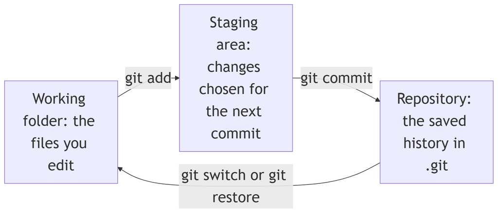

*Figure 7.1 — The three places your changes move through*

*Text description:* Three boxes: the working folder, the staging area, and the repository, with a labeled arrow from each to the next. `git add` moves changes from the working folder to the staging area, `git commit` moves them into the repository, and `git switch` or `git restore` brings files from the repository back to the working folder.

Nothing is recorded until it reaches the right-hand box. The middle box is what lets you commit only some of your edits.

```bash
git add notes.txt
git commit -m "Add notes about tile size"
```

`git add` puts the file in the staging area. `git commit` saves a snapshot of everything staged, and `-m` supplies the message. Why stage at all? Because it lets you make several edits and commit only the ones that belong together, so each commit tells one story. Look at your history:

```bash
git log
```

You should see something like this:

```
commit 3f2a9c1... (HEAD -> main)
Author: Your Name <you@example.com>
Date:   ...

    Add notes about tile size
```

The long hexadecimal number is the commit's identifier. Everyone abbreviates it to its first seven or so characters. `HEAD` is Git's name for "where you are now," and `main` is the name of the branch you are on (Section 7.6).

Now change the file and see what Git noticed:

```bash
echo "Edge tiles are cropped shorter." >> notes.txt
git diff
```

`>>` appends a line (Chapter 2). `git diff` shows the change as lines added (`+`) and removed (`-`) compared with the last commit. If the change is right, record it:

```bash
git add notes.txt
git commit -m "Note that edge tiles are cropped"
git log --oneline
```

`--oneline` compresses each commit to one line: its short identifier and its message. You should see two lines. Good commit messages matter more than beginners expect. Write what changed and, if it is not obvious, why. The project's own history reads well because its messages do that: "Fix review findings: X-Forwarded-For spoofing, role vs ownership, audit volume, UTC" tells you at a glance what the commit was for.

### 7.4 Getting the project

If you already followed Step 7 of Setting up your machine, you have cloned the project and can skip the `git clone` command shown in this section; this section explains what that step did. To get a copy of an existing repository, you **clone** it. The address comes from the project's repository page on GitHub, the website that hosts Git repositories: open the page, click the green *Code* button, and copy the address it shows. The project's repository is named `secure-doc-viewer` under its owner's account on GitHub, and it is **private**. You can open it, and its *Pull requests* tab (Section 7.7), only if its owner has given your GitHub account access. Ask the owner, or use the copy of the code you were given with this book. Substitute the address you copied:

```bash
git clone <repository-address>
cd secure-doc-viewer
```

A clone is a complete copy, including the whole history. You can now read it, offline, with `git log`:

```bash
git log --oneline
```

You should see something like this, newest first. The very top line depends on where the project's history stood when you cloned it; the line shown is the tip of `main` at `book-m6-final`:

```
d41e2b8 Merge pull request #12 from ...
ccc9b89 Bump jsdom from 28.1.0 to 30.0.1 in /frontend
...
df2bd6c Add secure document viewer: tiled rendering with signed URLs and per-viewer watermarking
```

The last line is the very first commit: the project began as a small tiled viewer, which is what `book-m0-mvp` marks. To see what one commit changed, use `git show`:

```bash
git show 08f3879 --stat
```

`--stat` summarizes which files changed. This commit, "Phase 5: Spring Boot 4 / Java 25, Docker stack, CI, and e2e tests", is the one that introduced the Dockerfile and the Maven wrapper from Chapter 6. (In that title, CI is continuous integration and e2e means end-to-end: tests that drive the whole running app.) It touched 28 files.

## Intermediate tier: Tags, branches, and pull requests

*On a first read you can skim this tier and return to it when you first work on a branch.*

### 7.5 Tags as bookmarks: the `book-m*` tags

A **tag** is a permanent name for one commit, like a bookmark. The project has seven, and they are this book's checkpoints (Table 7.1).

Table 7.1 — The milestone tags

| Tag | Milestone | Commit |
| --- | --- | --- |
| `book-m0-mvp` | Tiled viewer with signed URLs and watermarks | `df2bd6c` (the first commit) |
| `book-m1-accounts` | Accounts, roles, sessions, CSRF, sign-in throttling | `ad1a410` (merge of pull request 1) |
| `book-m2-documents` | Ownership, sharing, MySQL and Flyway, audit trail | `d88044e` (merge of pull request 2) |
| `book-m3-hardening` | Upload and API hardening, secrets, operations | `65a302e` (merge of pull request 3) |
| `book-m4-reading` | Reading experience, deep links, idle warning, watermark | `4af6338` (merge of pull request 4) |
| `book-m5-platform` | Spring Boot 4, Docker, CI, production hardening | `dbc5fcf` (merge of pull request 5) |
| `book-m6-final` | The finished app | `d41e2b8` (merge of pull request 12) |

A few words in the table are new. CSRF (Cross-Site Request Forgery) is an attack on signed-in users that Chapter 8 explains. CI (continuous integration) is a service that builds and tests every proposed change automatically, as Chapter 6 describes.

There is a subtlety worth knowing. Pull requests 1 to 4 were **stacked pull requests**: each branch started from the previous one, and all four were merged within about a minute of each other. So each tag marks a merge commit on `main`, and the code at each tag is the cumulative state of the project at that merge. That is exactly what a reader wants from a checkpoint. It also means you should always check what a tag contains with `git show`, and never assume from a pull request's title. Figure 7.2 shows the project's real history as branches and merges. Each phase branch started from the tip of the one before it, which is what "stacked" means, and each was then merged into `main`.

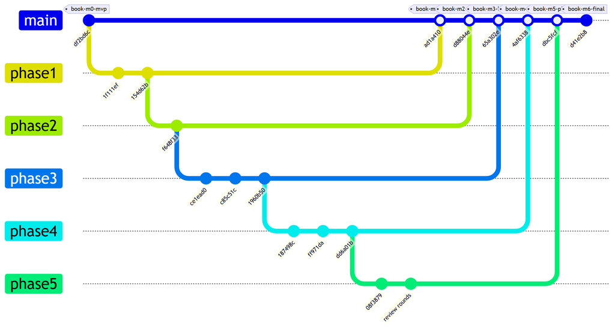

*Figure 7.2 — The project's history: stacked phase branches and the seven tags (simplified)*

*Text description:* A branching history drawn along a main line. The first commit on `main` carries the tag `book-m0-mvp`. Five branches then stack one on top of the next, each starting from the end of the previous one. `main` later merges them in order, and each merge commit carries one milestone tag from `book-m1-accounts` to `book-m5-platform`, followed by a final commit tagged `book-m6-final`.

The figure makes two simplifications. First, the branch names are shortened to `phase1` to `phase5`; the real ones are `hardening/review-findings`, `phase-2/documents` and so on. Second, the last box stands for the four small merges of pull requests 9 to 12, of which `d41e2b8` is the final merge. The box "review rounds" stands for the 14 further commits on the fifth branch. Notice that each `book-m` tag sits on a merge commit on `main`, except the first, which is the very first commit.

List the tags, and read any file as it was at a tag without changing anything on disk. (A fresh clone normally includes the tags; if `git tag` shows none, run `git fetch --tags`.)

```bash
git tag
git show book-m2-documents:src/main/resources/db/migration/V2__documents_shares_audit.sql
```

The form `git show <tag>:<path>` prints one file as it was at that tag. This is how the book's code listings are checked, and it is the safest way to look around: nothing in your folder changes. You can list a folder the same way, with `git ls-tree`:

```bash
git ls-tree --name-only book-m0-mvp src/main/java/com/example/securedocviewer/service
```

That command lists the files of one folder at the first milestone, before the app had accounts or a database. Comparing it with the same command at `book-m6-final` shows the growth in one glance.

### 7.6 Branches and merges

A **branch** is a movable name for a line of work. The default branch, `main`, holds the accepted history. To try something, you create a branch, commit there, and `main` stays untouched. When the work is good, you **merge** it back. Try it in your scratch repository:

```bash
git switch -c add-rate-note
echo "Rate limit: 180 tiles per minute." >> notes.txt
git add notes.txt
git commit -m "Note the rate limit"
git switch main
cat notes.txt
```

`git switch -c add-rate-note` creates a branch and moves to it (`-c` means create). After the commit, `git switch main` moves back, and `cat notes.txt` shows the file without the new line: on `main`, the change does not exist yet. Now merge:

```bash
git merge add-rate-note
cat notes.txt
```

The line appears. Because `main` had no new commits of its own, Git could move `main` forward to the branch's commit, which is called a **fast-forward**. When both branches have new commits, Git creates a **merge commit** that has two parents and joins the lines of work. The project's history is full of those: the messages that begin "Merge pull request #..." are merge commits made by GitHub.

If two branches change the same lines of the same file, Git cannot decide which version wins, and it stops with a **merge conflict**. It writes both versions into the file, between marker lines `<<<<<<<`, `=======` and `>>>>>>>`. You edit the file to keep what is right, delete the markers, `git add` the file and commit. Conflicts are normal and not a sign that you did something wrong.

### 7.7 Remotes, pull requests, and code review

A **remote** is a copy of the repository on another computer, usually GitHub. `git clone` sets one up for you, under the name `origin`. Three commands move commits between copies. To **push** is to send your commits to the remote (`git push`). To **fetch** is to download new commits without touching your files (`git fetch`). To **pull** is to fetch and then merge the new commits into your branch (`git pull`).

On GitHub, a **pull request** (PR) is a proposal to merge one branch into another. It shows the changes, lets others comment line by line, and runs automated checks before anything is merged. **Code review** is the practice of having someone else read the change before it lands. It catches mistakes the author cannot see, spreads knowledge, and leaves a record of why decisions were made.

This project used one pull request per phase, and the pull requests are a record of how it grew. For example, `book-m1-accounts` is the merge of pull request 1, "Phase 1: real accounts, roles, and admin lockdown". And `book-m5-platform` is the merge of pull request 5, "Phase 5: Spring Boot 4 / Java 25, Docker stack, CI, and e2e tests". Pull request 5 is the largest story: after it was opened, review rounds added fixes for problems the reviewers found, and about 15 commits landed on that branch before it was merged. In this project, the reviewers were AI review agents: a senior technical manager agent and a product owner agent. The technical manager agent gave a final recommendation to merge pull request 5, "subject to the product owner's approval," and it was the project's human owner who approved the merge. The agents advised; a person decided. Part V describes what they found. You can read the pull requests on the repository's *Pull requests* tab, or from the terminal with `gh pr view 5` if you have GitHub's command-line tool, `gh`, signed in. The pull requests in the public repository were recreated after personal data was removed from the commit history, so the dates GitHub shows on those pages are the recreation dates; the commits keep their original dates.

Not every pull request in the history is a feature. After pull request 5 merged, the automated checks failed once on `main` because one test was flaky: it sometimes failed and sometimes passed for the same code. The fix went through its own small pull request (number 9). Dependabot, a bot that proposes dependency updates, opened pull requests 6, 7 and 8 right after the merge. The project closed all three with an explanation, because they proposed unstable or non-LTS (long-term-support) versions. It then changed the bot's rules to propose only stable lines (pull request 10). Later Dependabot pull requests (11 and 12) were merged, which produced `book-m6-final`. One more pull request, number 13, was merged after that tag: it is documentation only, and it removed the stale mentions of a canvas from the README and from a comment in `PageInfo.java` (Chapter 4). So the tags stop at pull request 12, and `main` has one further commit than the last tag. The point for you: a pull request is the unit of change, whatever its size, and a healthy history has small ones.

### 7.8 `.gitignore` and why secrets never get committed

Some files must not be recorded: build output, editor settings, and above all secrets. The file `.gitignore` lists patterns Git skips. Excerpt:

**Listing 7.1 — `.gitignore` (book-m6-final, excerpt)**

```
# Build output
target/
!.mvn/wrapper/maven-wrapper.jar

# Generated tile storage — never commit ingested documents
storage/

# Local secrets (see .env.example)
.env
```

*Path: `.gitignore`*

Each non-comment line is a pattern. `target/` skips Maven's output (Chapter 6), `storage/` skips the uploaded documents' tiles (uploaded content must never enter history), and `.env` skips your secrets (Chapter 2). A line starting with `!` makes an exception, here keeping the Maven wrapper's jar file.

Why so strict? Git history is permanent and copied to everyone who clones. If you commit a password and delete it in the next commit, it is still in the history, and anyone can read it. The only safe practice is to never commit a secret, and to replace, or rotate, any secret that leaks. That is why the project ships `.env.example` with blanks and asks you to make your own `.env`.

The same care covers where the repository lives on your disk. The project's `.env.example` warns that the tile storage folder must be somewhere that is not synced by OneDrive, Dropbox or a similar service, because those would upload every rendered page to the cloud. The developer learned this the hard way: the project began inside a OneDrive folder, and the sync client copied the repository, the secrets and the tiles, and its file locks broke the moves and deletes the app performs. It was moved out to a plain local folder.

## Advanced tier: Working safely

*On a first read you can skip to "In this project"; Part IV uses the tags throughout.*

### 7.9 Following this book with tags without breaking your work

Two commands let you move to a milestone: `git checkout <tag>` and `git switch --detach <tag>`. Both put you in **detached HEAD** state. You are looking at an old commit and are not on any branch. Commits you make there belong to no branch, and can be lost when you switch away.

The safe routine:

1. Make sure your own work is saved: `git status` shows uncommitted changes. Commit them or set them aside first.
2. To read code, prefer `git show <tag>:<path>` (Section 7.5). It changes nothing.
3. To run or edit a milestone, create a branch from the tag and work there:

```bash
git switch -c my-m2 book-m2-documents
```

This creates and switches to a new branch `my-m2` that starts exactly at the tag. Your experiments live on `my-m2`; the tag and `main` stay intact. Exercises in this book always ask you to work on a branch like this, never directly on a tag. To go back: `git switch main`.

Being on a branch at an old tag does not make it runnable with the tools from your setup guide. The tags `book-m0-mvp` to `book-m4-reading` need a JDK 21 and a Maven you install yourself, because the Maven wrapper only arrives at `book-m5-platform` (Chapter 6, Section 6.7); Table IV.3 in Part IV lists what each tag needs. Until you have those, treat the older tags as read-only and use `git show`.

**We simplify here.** Git has many more commands, such as rebasing and stashing. The app's story does not need them, and you can look them up when you do.

### 7.10 Reading history to understand a project

History answers questions the code cannot. Three commands do most of the work.

`git log --oneline -- <path>` lists only the commits that touched one file. To find when the third database migration appeared:

```bash
git log --oneline --diff-filter=A -- src/main/resources/db/migration/V3__tile_versions_and_account_security.sql
```

`--diff-filter=A` keeps only commits that **added** the file. The answer is a commit titled "Atomic PDF replace via versioned tiles; bounded rendering", made during the review rounds of pull request 5. So the reason for the `tile_version` column in Chapter 9 is a replace-a-PDF bug found in review, which Chapter 30 tells in full. The history led you to the story. `git blame <file>`, called **blame** for short, shows, line by line, which commit last changed each line. It is not for blaming people; it is the quickest route from a puzzling line to the commit message that explains it. And `git log --stat` shows which files each commit touched, so you can see the size and shape of a change before you read it.

### 7.11 Common mistakes

**"fatal: not a git repository."** You ran a Git command outside a repository. Use `pwd` (Chapter 2) to check where you are, and `cd` into the project.

**You edited a file but the change is not in the commit.** You forgot `git add`. `git status` lists changes "not staged for commit" and tells you what to do.

**Your changes vanished after switching to a tag.** You committed while in detached HEAD, then switched away. If you have not yet switched, save the work with `git switch -c rescue` while you are still there. If you have already switched, ask Git for the lost commit's identifier with `git reflog`, the **reflog**, which lists where `HEAD` has been, then `git switch -c rescue <id>`.

**"LF will be replaced by CRLF" warnings on Windows.** (LF and CRLF are the Unix and Windows line endings from Chapter 2.) This is Git converting line endings (Chapter 2) between the Windows and Unix styles. It is normal. If a script such as `mvnw` fails with a strange `\r` error, the conversion went too far for that file (Chapter 6).

**You committed a secret.** Do not rely on deleting it in a new commit. Treat it as leaked: replace the secret with a new one first, since that is what actually protects you. Then, if the repository is shared, ask an experienced colleague about rewriting history, which is possible but affects everyone.

**A merge conflict.** Read the file, decide which lines are right, remove the marker lines, `git add`, and commit. `git status` tells you which files still conflict.

## In this project

- The seven `book-m*` tags, and the pull requests behind them (`gh pr view 1` to `gh pr view 5`).
- `.gitignore` and `.env.example`: the secrets rule and the warning about synced folders.
- `.github/workflows/ci.yml`: the automated checks that run on every pull request (Chapter 36).
- `.github/dependabot.yml`: a bot that opens pull requests to update dependencies.
- The project's history is short enough to read: at `book-m6-final` it holds 38 commits and pull requests 1 to 12, and milestone 5 alone is 15 of the commits. A documentation-only pull request, number 13, was merged after the tag.

## Try it

### Exercise 7.1 ★ Read the first commit

Run `git log --oneline` and find the oldest commit. Then run `git show <id> --stat`. Which folder holds most of the changed files?

*Solution:* Appendix C, Exercise 7.1.

### Exercise 7.2 ★ Time travel without moving

Print `pom.xml` as it was at `book-m0-mvp` and at `book-m6-final`. Which lines mention the Java version, and how do they differ?

*Solution:* Appendix C, Exercise 7.2.

### Exercise 7.3 ★★ Your own branch

Create a branch from `book-m2-documents`, add a file `notes.txt`, commit it, then switch back to `main` and confirm the file is gone. Switch back to your branch and confirm it returned.

*Solution:* Appendix C, Exercise 7.3.

### Exercise 7.4 ★ Two commits in a scratch repository

In a new folder, run `git init`, create a file, commit it, change it, view the change with `git diff`, and commit again. Then use `git log --oneline` to confirm you have two commits.

*Solution:* Appendix C, Exercise 7.4.

### Exercise 7.5 ★★ Find when a file appeared

Use `git log --diff-filter=A --oneline -- <path>` to find the commit that added `Dockerfile`, and the commit that added `V2__documents_shares_audit.sql`. For each, read the commit message and say which milestone it belongs to.

*Solution:* Appendix C, Exercise 7.5.

### Exercise 7.6 ★★★ Cause and resolve a conflict

In your scratch repository, create two branches that change the same line of `notes.txt` differently. Merge one, then the other, and resolve the conflict by hand. Write down, in your own words, what each of the three marker lines means.

*Solution:* Appendix C, Exercise 7.6.

## Summary

- Git records a project's history as commits; the working folder, staging area, and repository are the three places your changes move through.
- `git add` stages, `git commit` saves, `git diff` and `git log` show what changed.
- Tags are permanent names for commits; `git show <tag>:<path>` reads any file at any milestone without changing your files.
- Branches isolate work and merges join it; pull requests propose merges and trigger review and checks.
- `.gitignore` keeps build output and secrets out of history, which is permanent; keep repositories out of synced folders.
- To run or edit a milestone, create a branch from its tag; when in doubt, `git reflog` remembers where you have been.

## Further reading

- *Pro Git*, by Scott Chacon and Ben Straub, "Git Basics" and "Git Branching." https://git-scm.com/book/en/v2
- *Git Reference Manual*, `git-show`, `git-log` and `gitignore`. https://git-scm.com/docs
- *GitHub Docs*, "About pull requests." https://docs.github.com/en/pull-requests

# Chapter 8: How the web works

The browser and the backend of the Secure Document Viewer talk in a language called HTTP. Every protection in the app, from sign-in to signed tile URLs, is expressed in that language, so you need to read it fluently. This chapter teaches requests and responses, methods, and status codes, headers, JSON, cookies, security headers, the same-origin rule, and HTTPS, and shows you how to watch real traffic. Real bugs from this project appear along the way, because most of them were bugs about exactly these ideas.

## Learning objectives

By the end of this chapter, you will be able to:

- Describe an HTTP request and response and name their parts.
- Choose the right method for an action and explain the common status codes.
- Read and write a small JSON document, and explain how the app's records become JSON.
- Explain what a cookie is, how the app uses one for sign-in, and what the CSRF token adds.
- Explain what the security headers the app sets are for.
- Explain the same-origin rule and why browsers enforce it.
- Explain, in one paragraph, what HTTPS adds.
- Inspect traffic with the browser's developer tools and `curl`.

## Prerequisites

- Chapter 1: The big picture
- Chapter 2: The command line and your files

## Beginner tier: Requests and responses

### 8.1 Browsers, servers, requests, and responses

Chapter 1 introduced clients and servers. **HTTP** (Hypertext Transfer Protocol) is the set of rules they follow to talk. A **protocol** is an agreed format for a conversation, like the rules of a phone call: who speaks first, how you say goodbye. The conversation is always the same shape: the client sends a **request**, and the server sends back one **response**. The server never speaks first.

*Pattern note: This request and response exchange is the client-server pattern (Chapter 39, Section 39.4).*

A request names *what* the client wants and *how*; the response says whether that worked and carries the result. Everything on a web page, from the text to each image, arrives through separate exchanges like this. When a reader looks at one page of a document in the app, the browser makes about a dozen tile requests, one for each tile.

Follow what happens when you type an address such as `https://docs.example.com/` into a browser:

1. The browser asks the **DNS** (Domain Name System), the internet's phone book (unlike a printed one, its entries change, and each lookup takes a fraction of a second), which number address belongs to the name `docs.example.com`.
2. It opens a connection to that address, on a port (Chapter 2). For `https`, the default port is 443; for `http`, 80.
3. It sends a request.
4. The server sends a response.
5. The browser uses the response (draws the page, or shows an image) and may then make more requests for the things the page mentions.

Figure 8.1 shows one exchange, written out the way it travels.

```
GET /api/documents HTTP/1.1
Host: localhost:8080
Cookie: SDV_SESSION=<session-id>
Accept: application/json

HTTP/1.1 200 OK
Content-Type: application/json

[{"documentId":"...","title":"Quarterly report"}]
```

*Figure 8.1 — One request and its response (teaching example, abbreviated)*

*Text description:* Two blocks of plain text. The upper block is a request: a request line saying `GET /api/documents HTTP/1.1`, then header lines for host, cookie and accepted type. The lower block is the response: a status line `HTTP/1.1 200 OK`, a `Content-Type` header, an empty line, and a JSON body.

The top block is the request: a **request line** (method, path, protocol version), then **headers**, one per line. The bottom is the response: a **status line**, headers, an empty line, and the **body**. The id and title values are placeholders for illustration. Notice that everything is plain text. You can write a request by hand, and Section 8.10 does.

Figure 8.2 shows the five numbered steps of this section as a conversation between three parties.

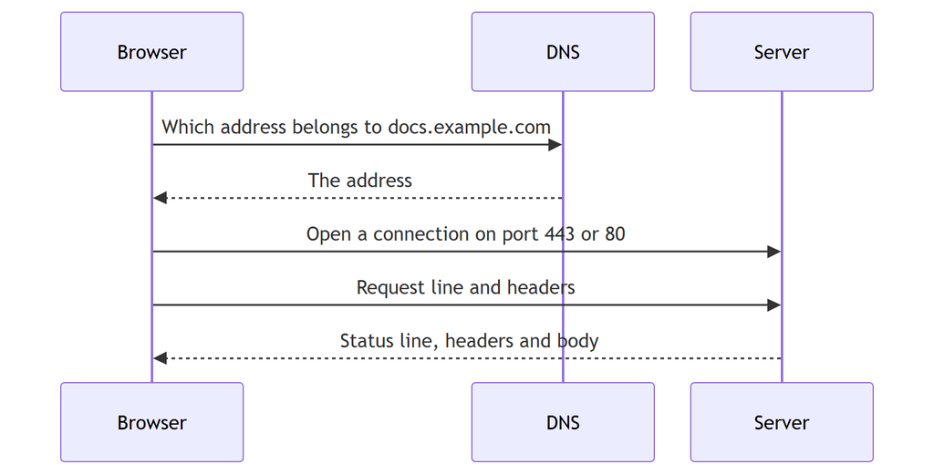

*Figure 8.2 — What happens between typing an address and getting a response*

*Text description:* A sequence read top to bottom among three parties: Browser, DNS, and Server. The browser asks DNS for the address of a name and receives it, then opens a connection to the server, sends a request, and receives a response. Notice that only the last two messages are HTTP.

Only the last two arrows are HTTP. The first two are the lookup that makes the name usable.

### 8.2 URLs, methods, and status codes

A URL has parts. Take `https://docs.example.com:8080/api/tiles?token=<signed-token>`:

- `https` is the scheme (the protocol, with encryption, Section 8.9);
- `docs.example.com` is the host, the computer to contact;
- `8080` is the port (Chapter 2);
- `/api/tiles` is the path, chosen by the app;
- `?token=<signed-token>` is the **query string**: extra named values after a question mark, in `name=value` pairs joined by `&`.

The path can also carry a value. The app's document endpoints use `/api/documents/{documentId}`, where `{documentId}` stands for a real identifier, so `/api/documents/123e4567-e89b-12d3-a456-426614174000` names one document. The app's real identifiers are random UUIDs, so they cannot be guessed by counting upward. A path that names a thing is called a **resource**, and the design style of naming resources by path and acting on them with methods is called **REST**, for Representational State Transfer (Chapter 12).

The method says what the client wants to do. Table 8.1 lists the ones the app uses, with real examples from `DocumentController`.

Table 8.1 — HTTP methods in the app

| Method | Meaning | Example in the app |
| --- | --- | --- |
| `GET` | Read something; changes nothing | `GET /api/documents` lists your documents |
| `POST` | Create something or submit an action | `POST /api/documents` uploads a PDF |
| `PUT` | Replace something | `PUT /api/documents/{id}/file` replaces a PDF |
| `PATCH` | Change part of something | `PATCH /api/documents/{id}` renames it |
| `DELETE` | Remove something | `DELETE /api/documents/{id}` |

Two properties explain why the methods differ. A method is a **safe method** if it does not change anything on the server: `GET` is safe, so a browser may repeat it, cache it or prefetch it freely. A method is **idempotent** if doing it twice has the same effect as once: `PUT` and `DELETE` are, since replacing a file twice with the same file, or deleting an already deleted document, leaves the same end state. `POST` is neither, which is why browsers warn before resubmitting one.

The response's **status code** is a three-digit number telling the client what happened. They come in families: 2xx success, 3xx redirect, 4xx the client's request was wrong, 5xx the server failed. Table 8.2 lists the codes this app produces, each taken from its error handler, plus `412`, which the app does not send but which Part VII needs.

Table 8.2 — Status codes the app uses

[output not shown]

Two rows deserve comment. Despite its name, `401 Unauthorized` really means "not authenticated": the server does not know who you are. `403 Forbidden` means the server knows who you are and refuses. And a document you may not see gets `404`, not `403`, so that nobody can probe which documents exist. The app's own exception comments say this explicitly.

### 8.3 Headers and bodies

**Headers** are name-and-value lines that add information about the message. A few matter in this app:

- `Content-Type` says what the body is (`application/json`, `image/png`);
- `Accept` (in a request) says what the client is willing to receive;
- `Cache-Control` tells caches whether they may keep a copy;
- `Retry-After` tells a client how many seconds to wait before trying again;
- `Cookie` and `Set-Cookie` carry cookies (Section 8.6).

A header in a request is a request header, and one in a response is a **response header**. The **body** carries the data. In a request, the data a client sends is the **request body**, such as the bytes of an uploaded PDF or a JSON document. In a response, the body is what the server returns: JSON for the app's API (application programming interface, the set of endpoints it offers; Section 8.4) or the bytes of an image for a tile. A `GET` request usually has no body.

The header names are case-insensitive, and there are dozens more, but these are enough to read almost everything the app sends. Section 8.7 covers a second group, the security headers.

## Intermediate tier: Data, cookies, and headers in the app

*On a first read you can skim this tier; Chapters 12, 15, and 16 return to cookies and headers.*

### 8.4 JSON

**JSON** (JavaScript Object Notation) is a text format for structured data. It has objects in braces with named fields, arrays in brackets, and values that are text in double quotes, numbers, `true`, `false` or `null`.

**Example 8.1 — A JSON object**

```json
{
  "title": "Quarterly report",
  "pageCount": 12,
  "visibility": "PRIVATE",
  "sharedWith": ["reader.one"]
}
```

The rules are strict, and breaking them is the commonest JSON mistake: field names need double quotes, text needs double quotes (not single), items are separated by commas, and there is no comma after the last item. A JSON document with any of these wrong is rejected as malformed, and the app then answers `400 Bad Request` with "Request body is missing or malformed."

The similarity to Chapter 4's records is deliberate. The app's record `DocumentSummary` becomes a JSON object with the same field names, automatically. A record with these fields (`documentId`, `title`, `pageCount`, `owner`, `visibility`, `createdAtEpochSeconds`, `updatedAtEpochSeconds`, `canManage`, `sharedWithCount`) is sent like this, with made-up values:

**Example 8.2 — A DocumentSummary as JSON (teaching values)**

```json
{
  "documentId": "123e4567-e89b-12d3-a456-426614174000",
  "title": "Quarterly report",
  "pageCount": 12,
  "owner": "pub.one",
  "visibility": "PRIVATE",
  "createdAtEpochSeconds": 1789776000,
  "updatedAtEpochSeconds": 1789776000,
  "canManage": false,
  "sharedWithCount": null
}
```

Each Java field became a JSON field of the same name; the `Visibility` enum became its name as text; and the `Integer sharedWithCount`, which the record fills in only for people who can manage the document, became `null`. Timestamps are plain numbers of seconds (Chapter 5), which every language can read. Every error the app sends is also JSON with one field, `error`, and the handler sets the `Content-Type` explicitly.

**Listing 8.1 — `GlobalExceptionHandler.java` (book-m6-final, excerpt: method `error`)**

```java
    private static ResponseEntity<Map<String, String>> error(HttpStatus status, String message) {
        return ResponseEntity.status(status)
                .contentType(MediaType.APPLICATION_JSON)
                .body(Map.of("error", message));
    }
```

*Path: `src/main/java/com/example/securedocviewer/controller/GlobalExceptionHandler.java`*

A `ResponseEntity` is Spring's object for a whole response: a status, headers, and a body. This helper builds one with the given status, marks it JSON, and puts the message in a map (Chapter 5), which becomes `{"error": "..."}`. Chapter 13 shows the full handler. Section 8.11 tells why the explicit content type is there.

### 8.5 Sending files: multipart uploads

JSON is for structured data. A PDF is a large block of bytes, and HTTP has a separate way to send one along with a few text fields: a **multipart** body, the format that HTML (the markup language of web pages) file-upload forms use. The body has several **parts**, each with its own headers, separated by a boundary marker. You do not write this format by hand. The app's upload endpoint declares what it expects, and the framework parses the parts.

**Listing 8.2 — `DocumentController.java` (book-m6-final, excerpt: method `upload` signature)**

```java
    @PostMapping
    public DocumentDetail upload(@RequestParam(value = "title", required = false) String title,
                                 @RequestParam(value = "visibility", required = false) Visibility visibility,
                                 @RequestParam("file") MultipartFile file,
                                 Authentication authentication,
                                 HttpServletRequest request) throws IOException {
```

*Path: `src/main/java/com/example/securedocviewer/controller/DocumentController.java`*

`@PostMapping` binds this method to `POST /api/documents`. Each `@RequestParam` names one part: an optional `title` and `visibility`, and a required `file`, which arrives as a `MultipartFile`. If the file part is missing the app answers `400` with "Missing required 'file'." If it is too big, the size limits apply: the settings cap a file at 50 MB, and the answer is `413 Content Too Large`. The limit exists at several layers, on purpose: the settings, the error handler's message, the frontend's own check, and the web server in front, so an oversized body is refused early, before the backend has spent effort on it.

### 8.6 Cookies, sessions, and the CSRF token

HTTP has no memory: each request stands alone. Yet after you sign in, the server must recognize you on the next request. The mechanism is a **cookie**: a small piece of text that the server asks the browser to store (with a `Set-Cookie` header) and that the browser then attaches to every later request to that server (with a `Cookie` header).

At sign-in, the server creates a session (Chapter 1) and sends its identifier as a cookie. The app's configuration names and protects it.

**Listing 8.3 — `application.yml` (book-m6-final, excerpt: session cookie)**

```yaml
  servlet:
    session:
      # Idle timeout: each request extends it, so an active reader is never
      # cut off mid-document, while an abandoned session still dies.
      timeout: 30m
      cookie:
        name: SDV_SESSION
        http-only: true
        same-site: strict
        # Must be true anywhere the app is served over HTTPS.
        secure: ${SESSION_COOKIE_SECURE:false}
```

*Path: `src/main/resources/application.yml`*

The cookie is named `SDV_SESSION`, and three settings protect it:

- `http-only: true` hides the cookie from JavaScript (the programming language that browsers run inside web pages; Part III covers its typed sibling, TypeScript) running in the page, so a script injected into the page (the attack is called **XSS**, for cross-site scripting) cannot steal it;
- `same-site: strict` sets the cookie's **SameSite** rule. It tells the browser to send the cookie only for requests that start on the app's own site, which blocks a class of forged-request attacks;
- `secure` makes the browser send it only over HTTPS. It is `false` by default so that local development over plain HTTP works, and the file's comment says it must be true wherever the app is served over HTTPS.

The `timeout: 30m` line means a session ends after 30 minutes without a request.

**Analogy.** The session cookie is a coat-check ticket. You hand over your coat at the desk (you sign in) and get a numbered ticket; whoever holds the ticket can collect the coat, which is why the ticket needs the three protections of Listing 8.3.

**Where the analogy breaks down:** in two ways. A coat-check ticket is used once, at the end, while the app checks the session again on every single tile request. And a coat-check ticket stays valid until the cloakroom closes, while a session ends after 30 idle minutes, and an administrator can cancel it at any time.

#### The forged-request problem and the second cookie

Browsers attach cookies automatically. That is convenient, and it is also the opening for **CSRF** (Cross-Site Request Forgery). A malicious page you visit in another tab makes your browser send a request to the app. Your session cookie goes along, so the app cannot tell the request from a real click. `same-site: strict` is one defense. The app adds a second: a **CSRF token**, a secret value that the app's own page reads and sends back in a header on every change (`POST`, `PUT`, `PATCH`, `DELETE`). A foreign page cannot read the value, so it cannot send it.

Figure 8.3 shows how the two cookies arrive during sign-in, in the order the project's own test drives them.

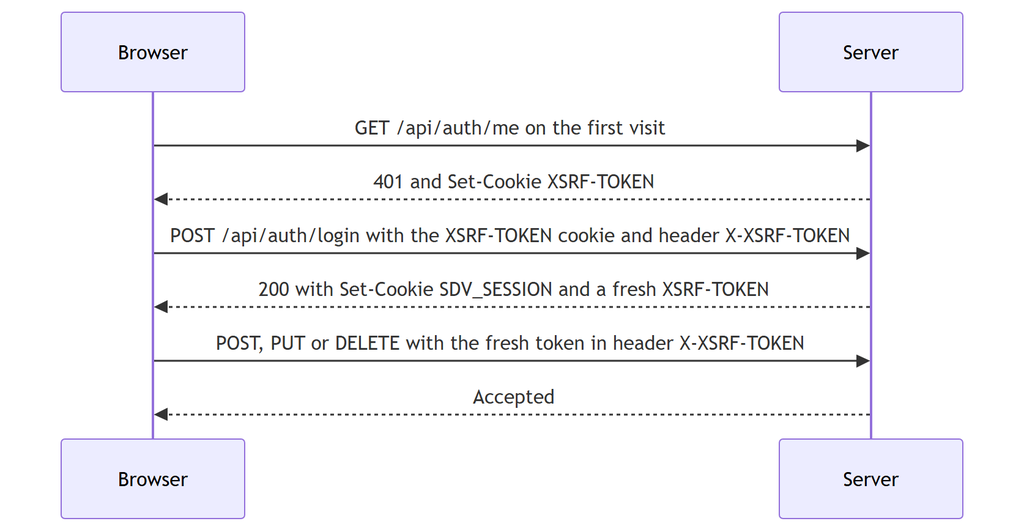

*Figure 8.3 — The session cookie and the CSRF token arriving during sign-in*

*Text description:* A sequence between Browser and Server, read top to bottom. A first visit gets a 401 answer that sets an `XSRF-TOKEN` cookie. The browser then signs in, sending that cookie and a matching header, and the answer sets the `SDV_SESSION` cookie and a fresh `XSRF-TOKEN`. A later change request carries the fresh token in a header and is accepted.

Notice the second reply: sign-in hands out a fresh CSRF token together with the session. The bug described in Section 8.11 was exactly a missing arrow here, a sign-in that deleted the CSRF cookie without issuing a new one.

The token travels in a second cookie, and this one is deliberately different.

**Listing 8.4 — `SecurityConfig.java` (book-m6-final, excerpt: the CSRF cookie)**

```java
    @Bean
    public CsrfTokenRepository csrfTokenRepository() {
        CookieCsrfTokenRepository repository = CookieCsrfTokenRepository.withHttpOnlyFalse();
        repository.setCookieCustomizer(cookie -> cookie.sameSite("Strict").path("/"));
        return repository;
    }
```

*Path: `src/main/java/com/example/securedocviewer/security/SecurityConfig.java`*

`withHttpOnlyFalse()` makes the CSRF cookie readable by the page's JavaScript, the opposite of the session cookie. That is intended: the Angular frontend must read the value to copy it into a header. Being readable is safe here because the value is useless without the session cookie, which stays hidden. Chapter 16 explains the design fully. What matters for now is that the app uses two cookies for two different jobs.

## Advanced tier: Trust, transport, and traffic

*On a first read you can skip to "In this project"; Chapter 16 comes back to security headers, and Chapter 33 to HTTPS.*

### 8.7 Security headers

The server also sends headers whose only job is to tell the browser to be stricter. The app sets a small set of them, and its own comments explain each.

**Listing 8.5 — `SecurityConfig.java` (book-m6-final, excerpt: security headers)**

```java
                .headers(headers -> headers
                        // The API only ever returns JSON and PNG tiles, so nothing it serves
                        // needs to run script, load resources or be framed.
                        .contentSecurityPolicy(csp -> csp.policyDirectives(
                                "default-src 'none'; frame-ancestors 'none'; base-uri 'none'; form-action 'none'"))
                        // Tile URLs carry signed tokens; never send them onward in a Referer.
                        .referrerPolicy(referrer -> referrer.policy(ReferrerPolicy.NO_REFERRER))
                        .permissionsPolicyHeader(permissions -> permissions.policy(
                                "camera=(), microphone=(), geolocation=(), payment=()")))
```

*Path: `src/main/java/com/example/securedocviewer/security/SecurityConfig.java`*

Reading them in turn:

- **Content-Security-Policy** (CSP) is an allow-list (a list of what is permitted, with everything else refused) that tells the browser what a response may do. `default-src 'none'` means "load nothing from anywhere"; `frame-ancestors 'none'` means "no other page may embed this one in a frame." Since the API returns only JSON and images, it needs no permissions, so it grants none. If an attacker ever got script into a response, the browser would refuse to run it.
- **Referrer-Policy**: `no-referrer` stops the browser from telling the next site which page the visitor came from. This matters because tile URLs carry signed tokens (Chapter 1). Without the policy, following a link from a page could leak a token in the `Referer` header.
- **Permissions-Policy** switches off browser features the app never uses (camera, microphone, location, payment), so nothing can request them.

The tile endpoint sets one more header, the one that matters most for the watermark.

**Listing 8.6 — `TileController.java` (book-m6-final, excerpt: the end of method `getTile`)**

```java
        return ResponseEntity.ok()
                // Deliberately not cacheable beyond a moment — a shared cache
                // holding onto a watermarked-for-someone-else tile would leak it.
                .cacheControl(CacheControl.noStore())
                .body(png);
```

*Path: `src/main/java/com/example/securedocviewer/controller/TileController.java`*

`Cache-Control: no-store` forbids any cache from keeping the response. A tile is watermarked for one viewer, so a shared cache (a proxy that many people use) that kept it could hand it to someone else. The cost is that tiles are never reused from a cache, which the README accepts on purpose.

### 8.8 Same origin, and why browsers are suspicious

An **origin** is the combination of scheme, host and port. `http://localhost:8080` and `http://localhost:4200` are different origins because the ports differ. Browsers apply the **same-origin policy**: a script loaded from one origin may not freely read responses from another. The rule exists because otherwise any web page you visit could silently read your email or your documents using your cookies.

The consequence for this project: the Angular frontend (the pages you see, built in Part III) and the backend must appear to the browser as one origin. A **proxy** is a program that receives a request on behalf of another server and forwards it. In development a small proxy forwards `/api` requests to the backend.

**Listing 8.7 — `proxy.conf.json` (book-m6-final)**

```json
{
  "/api": {
    "target": "http://localhost:8080",
    "secure": false,
    "changeOrigin": false,
    "logLevel": "warn"
  }
}
```

*Path: `frontend/proxy.conf.json`*

The Angular development server, on port 4200, forwards every request whose path starts with `/api` to the backend on 8080, so the browser sees only one origin. In the Docker stack a web server called nginx does the same job (Chapters 10 and 33). The project avoids opening cross-origin access (a browser feature called **CORS**, for cross-origin resource sharing) rather than granting it; there is no cross-origin configuration in the backend at `book-m6-final`. Figure 8.4 shows the two arrangements side by side. In both, the browser talks to one address only.

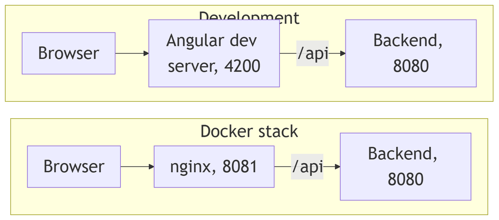

*Figure 8.4 — How the browser sees one origin in development and in the Docker stack*

*Text description:* Two rows, one above the other. In the top row, Development, the browser talks to the Angular development server on port 4200, which forwards paths starting with `/api` to the backend on port 8080. In the bottom row, the Docker stack, the browser talks to an nginx container published on port 8081, which forwards the same paths to a backend container on port 8080 that is not published.

The backend is never reached directly by the browser, so the browser sees a single origin and the same-origin rule is satisfied without any cross-origin exceptions.

### 8.9 HTTPS and TLS in one page

Plain HTTP travels as readable text, so anyone on the network path can read or change it, including the session cookie. HTTPS is HTTP inside an encrypted channel created by **TLS** (Transport Layer Security). TLS provides three things: **encryption** (eavesdroppers see noise), **integrity** (changes are detected), and authentication (a certificate proves you reached the real host). A **certificate** is a signed statement, issued by an authority the browser trusts, that a public key belongs to a given domain. (A public key is one half of a pair of numbers used for encryption: it can be shared freely, while its partner, the private key, stays secret on the server.)

The project's optional TLS frontend is a program called Caddy, and the setting `SESSION_COOKIE_SECURE=true` is what you turn on when you use it. The Caddy configuration adds one more header, `Strict-Transport-Security`, known as HSTS (HTTP Strict Transport Security), which tells the browser to use only HTTPS for this site from then on.

**Listing 8.8 — `deploy/Caddyfile` (book-m6-final, excerpt: the header block)**

```
    header {
        # Browsers must only ever use HTTPS for this site from now on. Add
        # "; includeSubDomains" via HSTS_POLICY only if every subdomain is HTTPS too.
        Strict-Transport-Security "{$HSTS_POLICY:max-age=31536000}"
        -Server
    }
```

*Path: `deploy/Caddyfile`*

`max-age=31536000` is one year in seconds. The braces-and-dollar form `{$HSTS_POLICY:max-age=31536000}` is Caddy's own way of reading an environment variable, with the text after the colon as the default. The `-Server` line removes the `Server` header, so responses do not advertise which software answers. Chapter 33 covers deployment and TLS in depth.

### 8.10 Looking at real traffic

You can watch everything in this chapter with tools you already have. The steps that involve the app itself need the app running, which you get in Chapter 10 (the database) and Part II (the backend). So this section has two parts: a first experiment that works right now against a public website, and a read-along or later-practice part for the app.

**Developer tools.** In a browser, press `F12`, open the *Network* tab, and load any page, for example `https://example.com`. Each row is one request; click it to see the method, status code, headers and body. When you later run the app, look for a `/api/tiles?token=...` row when a document page loads, and check its `Cache-Control` header.

**curl.** `curl` is a command-line program that sends requests. It is installed with Git Bash and with macOS, and Windows 10, and later includes it too. The `-i` flag prints the response headers as well. Try it now, against `example.com`, a website reserved for exactly this kind of demonstration:

```bash
curl -i https://example.com
```

You should see something like this: a status line, headers such as `Content-Type: text/html`, an empty line, and the page's HTML as the body. That is Figure 8.1 for real. Add `-v` to see the request `curl` sent as well as the response, or `-I` to send a `HEAD` request that returns only the headers.

#### Later practice: against your own copy of the app

The rest of this section is a read-along for now; come back to it after Chapter 10 and Part II have the app running on your machine. The app's health endpoint, from Chapter 10's health check, answers without signing in:

```bash
curl -i http://localhost:8080/actuator/health
```

You should see something like this:

```
HTTP/1.1 200
Content-Type: application/json
...
{"status":"UP"}
```

The exact `Content-Type` may be a longer vendor-specific type that ends in `+json`; the body is the important part.

Requests to the API without a session cookie get `401`, which is a useful experiment once the app runs:

```bash
curl -i http://localhost:8080/api/documents
```

You should see a `401` status line and a JSON body with an `error` field, and, in the headers, the security headers from Section 8.7. `curl -X DELETE` sends a different method. Only ever run such experiments against your own copy, not against someone else's deployment.

### 8.11 Real incidents from this project

Three bugs from the project's history are best understood with what you now know.

#### The tile endpoint that answered 500

**The problem.** In an early version, a request that was refused for being rate-limited or unauthenticated should have produced a clean `429` or `401`. Instead, some requests produced `500`.

**The cause.** It was found in the first round of testing the viewer in a browser and fixed in the same milestone as the frontend baseline (`book-m1-accounts`). The handler's own comment gives the mechanism. The tile endpoint's callers may send an `Accept` header that allows only images. Spring negotiates the format of an error body against that header, so when the app tried to send a JSON error, JSON was "not acceptable" for that request. The error handler itself then failed, and a clean `401` or `429` turned into a `500`.

**The fix.** Every error response now sets its `Content-Type` to JSON explicitly, so the response no longer depends on negotiation with the request's `Accept` header. That is why Listing 8.1 sets the type by hand, and why the handler's own comment starts by describing this problem.

**The lesson.** Error paths need tests as careful as success paths: the code that reports a failure can itself fail, and headers can influence more than the happy path.

#### The first write after sign-in that got 403

**The problem.** Right after signing in, the first change the user made (a `POST` or `PUT`) was refused with `403 Forbidden`.

**How it was found.** A live check against the real database in the first phase. Signing in caused the CSRF cookie of Section 8.6 to be deleted without a new one being issued, so the next change had no token to send.

**The fix.** Issue a fresh CSRF cookie at sign-in, and add a test of that whole flow. A related note in the project records why an earlier test hid the bug. The test helper that Spring provides for CSRF swaps the real token repository for its own. So a test that used it passed while the real cookie flow was broken.

**The lesson.** A test that replaces the thing under test can pass while the real thing is broken. Test the real flow at least once.

#### The security headers that appeared twice

**The problem.** When the frontend's web server (nginx) was added, browsers received two `Content-Security-Policy` headers, and a rule meant for static files also caught some API paths ending in `.js`.

**How it was found.** By the technical-manager review of the fifth pull request, an AI review agent.

**The fix.** Set the headers once per location, and match `/api` with a prefix rule so no other pattern can capture an API path. The nginx configuration's comments still explain it.

**The lesson.** When two layers both set the same header, the browser may receive both. Decide which layer owns each header.

### 8.12 Common mistakes

**A `401` you did not expect.** The session cookie is missing or expired. In `curl`, you did not send a cookie; in the browser, the session timed out (30 minutes idle) or was revoked.

**`403` on a change, but reads work.** The CSRF token is missing or wrong (Section 8.6), or your role does not allow the action. The error message says which.

**Confusing `404` and `403`.** In this app, `404` can mean "it does not exist" or "you may not know it exists." Do not assume a `404` means the id is mistyped.

**A cookie that never arrives.** Common causes are these. The cookie is marked `Secure` but you are on plain HTTP. Or `SameSite=Strict` blocks it on a request that came from another site. Or the request goes to a different origin than the one that set it.

**`415 Unsupported Media Type`.** You sent a body without the right `Content-Type`, for example JSON without `Content-Type: application/json`.

**`400` on a body that looks right.** Check for a trailing comma, single quotes, or a missing quote in your JSON.

**Stale results after a change.** Something cached an old response. The API sends no long-lived cache headers, but during development a browser may keep static files; do a hard reload or disable the cache in the developer tools' *Network* tab.

**A blocked cross-origin request.** The message mentions CORS. In this project, it means your page is not going through the proxy of Section 8.8.

## In this project

- `controller/DocumentController.java`: methods, paths, and the multipart upload.
- `controller/GlobalExceptionHandler.java`: status codes and the JSON error contract.
- `controller/TileController.java`: the tile endpoint, `Cache-Control: no-store`.
- `security/SecurityConfig.java`: the CSRF cookie and the security headers.
- `src/main/resources/application.yml`: the session cookie.
- `frontend/proxy.conf.json`, `frontend/nginx.conf`, `deploy/Caddyfile`: proxies and HTTPS.

## Try it

### Exercise 8.1 ★ Match the code

Which status code would you expect for: reading a document you do not have access to; uploading a 60 MB file; sending too many tile requests in a minute?

*Solution:* Appendix C, Exercise 8.1.

### Exercise 8.2 ★ Read a URL

Take `https://docs.example.com/api/tiles?token=abc` and name its scheme, host, path and query string.

*Solution:* Appendix C, Exercise 8.2.

### Exercise 8.3 ★★ Watch the cookie

After Chapter 10 and Part II have the app running locally (or as a read-along until then), sign in through the browser, open the developer tools, and find the `SDV_SESSION` cookie under *Application* (or *Storage*). Which flags are set? Compare with Listing 8.3.

*Solution:* Appendix C, Exercise 8.3.

### Exercise 8.4 ★ Write a request by hand

Write the request line and headers for a `GET` of the document list from `localhost:8080`, asking for JSON. Then say what response status you expect if you send it with no cookie.

*Solution:* Appendix C, Exercise 8.4.

### Exercise 8.5 ★★ Two cookies

After the app is running (Chapter 10 and Part II), sign in and list all cookies the app set. Until then, answer from Listings 8.3 and 8.4 alone. Which one is readable by JavaScript and which is not? Explain, using Section 8.6, why the design needs both.

*Solution:* Appendix C, Exercise 8.5.

### Exercise 8.6 ★★★ Explain the header

Choose one of the headers in Listing 8.5 or Listing 8.6 and write one paragraph for a non-technical product owner: what it protects against, what the app would risk without it, and what it costs.

*Solution:* Appendix C, Exercise 8.6.

## Summary

- HTTP is a request and response conversation; the server never speaks first.
- Methods say what to do, and safe and idempotent methods behave differently; status codes say what happened, and the app uses `404` to hide existence.
- Headers describe messages; the API's bodies are JSON, and uploads use multipart.
- A session cookie carries the sign-in, protected by `http-only`, `same-site`, and `secure`; a second, readable CSRF cookie defends against forged requests.
- Security headers (CSP, Referrer-Policy, Permissions-Policy, HSTS) and `Cache-Control: no-store` restrict what browsers and caches do.
- Browsers enforce the same-origin rule; HTTPS adds encryption, integrity, and authentication.
- Several of the project's real bugs were HTTP details: the `Accept` header, the CSRF cookie and duplicated headers.

## Further reading

- *MDN Web Docs*, "An overview of HTTP." https://developer.mozilla.org/en-US/docs/Web/HTTP/Guides/Overview
- *MDN Web Docs*, "HTTP response status codes." https://developer.mozilla.org/en-US/docs/Web/HTTP/Reference/Status
- *MDN Web Docs*, "Same-origin policy." https://developer.mozilla.org/en-US/docs/Web/Security/Same-origin_policy
- *MDN Web Docs*, "Content Security Policy (CSP)." https://developer.mozilla.org/en-US/docs/Web/HTTP/Guides/CSP
- RFC 9110, "HTTP Semantics." https://www.rfc-editor.org/rfc/rfc9110

# Chapter 9: SQL and MySQL

From milestone 2 on, the Secure Document Viewer keeps its accounts, documents, shares, and audit trail in a database, so they survive restarts and can be queried safely by many users at once. This chapter teaches the SQL language and the ideas behind relational databases, using the project's real migration files as examples. By the end you will be able to read every table definition in the project and write the queries the app needs.

## Learning objectives

By the end of this chapter, you will be able to:

- Explain tables, rows, columns, and keys.
- Read a `CREATE TABLE` statement, including types, and constraints.
- Write `INSERT`, `SELECT`, `UPDATE`, and `DELETE` statements, with `WHERE`, `ORDER BY`, and `LIMIT`.
- Explain foreign keys and write a join.
- Summarize rows with `COUNT` and `GROUP BY`.
- Explain what an index is and why the project adds them.
- Explain transactions and row locks.
- Explain what a migration is and why the schema is changed only through them.
- Diagnose the common SQL errors.

## Prerequisites

- Chapter 2: The command line and your files
- Chapter 8: How the web works

## Beginner tier: Tables and queries

### 9.1 Why a database

Files on disk are fine for a PDF, but a poor place to answer "which documents can `reader.one` open?". To answer that from files, you would read every file, parse it, and hope nobody changed one while you were reading. A database is a program that stores data in an organized form and answers questions about it quickly, safely, and for many users at once. This project uses **MySQL** 8.4, a **relational database**: one that stores data in tables and links them by keys. The language you use to talk to it is **SQL** (Structured Query Language, usually pronounced "sequel" or letter by letter).

What does the app keep in it? At `book-m6-final` there are six tables, listed in Table 9.1. Notice that the tiles themselves are not among them: images stay on disk, and the database holds the facts about them.

Table 9.1 — The app's tables at book-m6-final

| Table | What it holds | Created in |
| --- | --- | --- |
| `app_user` | Accounts: username, password hash, role | `V1` |
| `document` | One row per uploaded document | `V2` |
| `document_page` | One row per rendered page: its tile grid | `V2` |
| `document_share` | Who a private document is shared with | `V2` |
| `audit_event` | The append-only security trail | `V2` |
| `account_known_ip` | Recently used sign-in addresses (hashed) | `V3` |

The names `V1`, `V2`, and `V3` are the migration files that create them; Section 9.11 explains those.

### 9.2 Tables, rows, columns, keys

A **table** is like a spreadsheet: it has named **columns** (the kinds of facts) and **rows** (one entry each). The `app_user` table has a column for username and one for role, and one row per account.

A **primary key** is a column (or set of columns) whose value identifies each row uniquely. It cannot be empty or repeat. In `app_user`, the key is `id`. A **foreign key** is a column that holds the primary key of a row in another table, creating a link. In `document`, the column `owner_id` holds the `id` of the owner's row in `app_user`. Figure 9.1 draws the links between four of the tables.

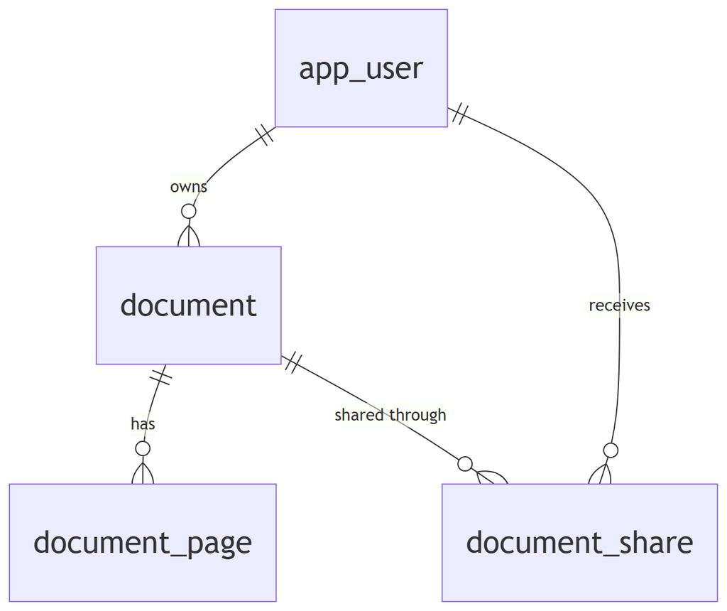

*Figure 9.1 — How four tables relate (crow's-foot notation: one on the left, many on the right)*

*Text description:* An entity-relationship diagram with four tables. A user owns zero or more documents, a document has zero or more pages and zero or more shares, and a user receives zero or more shares. Notice that the share table sits between documents and users, which is how many-to-many is expressed.

Read `app_user ||--o{ document` as "one user owns zero or more documents." The document-to-share and user-to-share links together make the many-to-many relationship that Section 9.6 explains.

**Analogy.** A table is a spreadsheet tab and a foreign key is a cell that says "see row 7 of the Users tab."

**Where the analogy breaks down:** a database enforces the link: it refuses to store an `owner_id` that points to nobody. A spreadsheet would let the bad reference sit there until something broke.

### 9.3 Trying SQL against the project's database

You can run every statement in this chapter yourself, but you need a running MySQL first. Chapter 10 is where Docker and the project's `docker-compose.yml` are taught. Docker itself was installed in the setup guide, and Chapter 10 explains what the commands do. So treat this section as a read-along now, and come back to it after Chapter 10; nothing in the rest of the chapter depends on running the commands. The steps, for when you are ready:

1. Copy `.env.example` to `.env` and fill in the password lines (Chapter 2), then start MySQL with `docker compose up -d` (Chapter 10).
2. Create the tables. Normally the app creates them itself through its migrations when it starts (Section 9.11), but the app is not running yet, so apply the three migration files yourself, in order. Each command reads one file and feeds it to the MySQL client inside the container, using the database name, user and password the container already holds, so you never type a password. (The command hands the password to the client through the `MYSQL_PWD` environment variable, which the MySQL 8.4 manual calls insecure and deprecated; that is acceptable for a throwaway practice database on your own machine, and Chapter 10 explains the stricter alternative.)

   ```bash
   for f in src/main/resources/db/migration/V*.sql; do
     docker compose exec -T mysql sh -c 'MYSQL_PWD="$MYSQL_PASSWORD" mysql -u "$MYSQL_USER" "$MYSQL_DATABASE"' < "$f"
   done
   ```

   The `V*.sql` pattern matches the files in order (`V1`, `V2`, `V3`). Run this at `book-m6-final`, where all three exist. Treat this as a practice database. If you later start the real app against it, the app's migration tool will refuse to run on tables it did not create. Reset first with `docker compose down -v`, which deletes the database's data (Chapter 10 explains).
3. Open a SQL prompt inside the container. The command asks for the password interactively (`-p` with no value) so it never appears on the command line or in your shell history:

   ```bash
   docker compose exec mysql mysql -u securedocs -p securedocs
   ```

   Here `securedocs` is the default username and, as the last word, the database name from `.env.example`; use your own values if you changed them. Type the password you chose in `.env` when asked. At the `mysql>` prompt, statements end with a semicolon. Try `SHOW TABLES;` and you should see the six tables of Table 9.1. Type `exit` to leave.

### 9.4 `CREATE TABLE`, types and constraints

Every table starts with a `CREATE TABLE` statement. Here is the very first migration of the project, the accounts table.

**Listing 9.1 — `V1__create_app_user.sql` (book-m2-documents, unchanged at book-m6-final)**

```sql
-- Accounts that can sign in. Usernames are stored lower-cased by the
-- application, so the unique constraint is effectively case-insensitive.
CREATE TABLE app_user (
    id            BIGINT       NOT NULL AUTO_INCREMENT,
    username      VARCHAR(64)  NOT NULL,
    password_hash VARCHAR(100) NOT NULL,
    role          VARCHAR(20)  NOT NULL,
    enabled       BOOLEAN      NOT NULL DEFAULT TRUE,
    created_at    DATETIME(6)  NOT NULL,
    PRIMARY KEY (id),
    CONSTRAINT uk_app_user_username UNIQUE (username)
);
```

*Path: `src/main/resources/db/migration/V1__create_app_user.sql`*

Line by line:

- `--` starts a comment.
- `CREATE TABLE app_user ( ... );` defines the table. Each line inside is a column: a name, a type, and optional rules.
- `BIGINT` is a large whole number; `VARCHAR(64)` is text up to 64 characters; `BOOLEAN` is true or false; `DATETIME(6)` is a date and time with microsecond precision.
- `NOT NULL` means the column cannot be empty. SQL's `NULL` means "unknown or missing," like Chapter 5's `null`.
- `AUTO_INCREMENT` makes the database assign the next number to `id`, so each new account gets a fresh key.
- `DEFAULT TRUE` supplies a value when the row does not give one.
- `PRIMARY KEY (id)` declares the key.
- `CONSTRAINT uk_app_user_username UNIQUE (username)` is a **constraint**, a rule the database enforces: no two accounts may share a username. Enforcing it in the database is safer than only checking in Java, because two simultaneous account-creation requests cannot both slip through.

Notice `password_hash`, not `password`. The database never stores the password itself, only a one-way scrambled form (Chapter 15). And notice that `role` is `VARCHAR(20)`: the Java enum `Role` from Chapter 4 is stored as its name, `READER`, `PUBLISHER` or `ADMIN`, as text.

Table 9.2 lists the types you will meet in the project's migrations.

Table 9.2 — Column types used in the migrations

| Type | Holds | Example column |
| --- | --- | --- |
| `INT`, `BIGINT` | Whole numbers (about 2 billion and about 9 quintillion at most) | `page_count`, `id` |
| `VARCHAR(n)` | Text up to `n` characters | `title`, `username` |
| `BOOLEAN` | true or false | `enabled` |
| `DATETIME(6)` | A date and time, to the microsecond | `created_at` |

Choosing a size is a design decision with consequences. `VARCHAR(64)` for a username means a 65th character is refused by the database. The app's Java code also checks such limits, but the database is the last line of defense.

### 9.5 INSERT, SELECT, UPDATE, DELETE

Four statements cover everyday work. Example 9.1 uses the `app_user` table of Listing 9.1; the values are made up for teaching, and in the app Java code sends these statements for you (Chapter 14).

**Example 9.1 — The four everyday statements**

```sql
INSERT INTO app_user (username, password_hash, role, created_at)
VALUES ('pub.one', '<password-hash>', 'PUBLISHER', NOW(6));

SELECT username, role FROM app_user WHERE enabled = TRUE ORDER BY username;

UPDATE app_user SET role = 'ADMIN' WHERE username = 'pub.one';

DELETE FROM app_user WHERE username = 'pub.one';
```

- `INSERT` adds a row; you name the columns and give matching values. Columns you leave out use their default (`enabled` becomes true). Text values use single quotes.
- `SELECT` reads. It lists columns, then `FROM` a table, then an optional `WHERE` filter and an `ORDER BY`.
- `UPDATE` changes existing rows, and `WHERE` decides which. Forget `WHERE` and every row changes.
- `DELETE` removes rows, with the same warning.

`SELECT` has more clauses worth knowing. `LIMIT` caps how many rows come back. `LIKE` matches text with wildcards, where `%` means "anything." `COUNT` counts rows. Combine them:

**Example 9.2 — More of SELECT**

```sql
SELECT COUNT(*) FROM app_user WHERE role = 'READER';

SELECT username FROM app_user WHERE username LIKE 'pub%' ORDER BY username LIMIT 20;
```

The first counts readers. The second lists up to 20 usernames that start with `pub`, in alphabetical order. That second query is exactly the shape of the app's share picker. Chapter 14 shows it being generated from a method name: `findTop20ByEnabledTrueAndUsernameStartingWithOrderByUsernameAsc` reads as "top 20, enabled true, username starting with, order by username ascending."

#### The danger of UPDATE and DELETE

The rule about `WHERE` is worth an example, because it is the way real data gets damaged. Suppose some audit rows were written five and a half hours ahead because a server used local time (a bug this project really had, Chapter 5). A fix would shift those rows back. The safe way is to look before you change:

**Example 9.3 — Look, then change (teaching example)**

```sql
SELECT COUNT(*) FROM audit_event WHERE occurred_at > NOW(6);

UPDATE audit_event
SET occurred_at = DATE_SUB(occurred_at, INTERVAL 330 MINUTE)
WHERE occurred_at > NOW(6);
```

Run the `SELECT` first, with the same `WHERE`, and check that the count is what you expect. Only then run the `UPDATE`. Never run a statement like this on data you care about without a backup, and note that `NOW(6)` uses the database server's own time zone setting, which is the very thing that caused the original problem. The real project did exactly one such one-off correction to a small number of rows after the owner approved it; the exact statement is not reproduced here.

## Intermediate tier: Relationships and speed

*On a first read you can skim this tier; Chapter 14 returns to relationships and queries.*

### 9.6 Relationships: foreign keys and joins

Documents and users are related: every document has one owner, and a document can be shared with many users, each of whom can see many documents. The second kind, **many-to-many**, needs a third table that holds pairs. The project's second migration creates these tables.

**Listing 9.2 — `V2__documents_shares_audit.sql` (book-m2-documents, unchanged at book-m6-final; simplified: two tables and the indexes omitted)**

```sql
CREATE TABLE document (
    id          VARCHAR(36)  NOT NULL,
    title       VARCHAR(200) NOT NULL,
    owner_id    BIGINT       NOT NULL,
    visibility  VARCHAR(20)  NOT NULL,
    page_count  INT          NOT NULL,
    tile_size   INT          NOT NULL,
    created_at  DATETIME(6)  NOT NULL,
    updated_at  DATETIME(6)  NOT NULL,
    PRIMARY KEY (id),
    CONSTRAINT fk_document_owner FOREIGN KEY (owner_id) REFERENCES app_user (id)
);

-- ...

CREATE TABLE document_share (
    document_id VARCHAR(36) NOT NULL,
    user_id     BIGINT      NOT NULL,
    PRIMARY KEY (document_id, user_id),
    CONSTRAINT fk_document_share_document FOREIGN KEY (document_id) REFERENCES document (id) ON DELETE CASCADE,
    CONSTRAINT fk_document_share_user FOREIGN KEY (user_id) REFERENCES app_user (id) ON DELETE CASCADE
);
```

*Path: `src/main/resources/db/migration/V2__documents_shares_audit.sql`*

Reading it:

- `document.id` is a `VARCHAR(36)`, not a number. Thirty-six characters is the length of a UUID (a randomly generated identifier such as `123e4567-e89b-12d3-a456-426614174000`), so document identifiers cannot be guessed by counting up, unlike an `AUTO_INCREMENT` number. That matters for a security product: a guessable id is an invitation to probe.
- `document.owner_id` is a foreign key to `app_user.id`. The database refuses a document whose owner does not exist.
- `document_share` is a **join table**: each row says "this user may open this document." Its primary key is the *pair* `(document_id, user_id)`, so the same share cannot be recorded twice. That is exactly Chapter 5's set behavior, enforced by the database.
- `ON DELETE CASCADE` means: when the referenced row is deleted, delete these rows too. Deleting a document removes its shares automatically, so no orphaned shares remain.

Note what is missing from `document`: a foreign key does not say what happens on `DELETE` for `owner_id`. By default the database refuses to delete a user who still owns documents. That is deliberate. The project never deletes users at all (it disables them), so their audit history and ownership stay meaningful.

A **join** combines rows from two tables in a query. This teaching query lists documents with their owners' usernames:

**Example 9.4 — A join**

```sql
SELECT d.title, u.username AS owner
FROM document d
JOIN app_user u ON u.id = d.owner_id
WHERE d.visibility = 'EVERYONE';
```

`d` and `u` are short aliases for the tables, and `ON` says how rows match: the document's `owner_id` equals the user's `id`. `AS owner` renames the output column. A plain `JOIN` keeps only rows that match on both sides. Its sibling `LEFT JOIN` keeps every row from the left table even with no match, which the app needs to list a document that has no shares.

The app writes such queries in a Java-flavored query language called JPQL (Java Persistence Query Language), and the framework translates it to SQL (Chapter 14). Here is the query behind the library page, so you can see joins in the project.

**Listing 9.3 — `DocumentRepository.java` (book-m6-final, excerpt: query `findVisibleTo`)**

```java
    @Query("""
            select distinct d from Document d
            join fetch d.owner
            left join d.sharedWith s
            where d.visibility = :everyone or d.owner.username = :username or s.username = :username
            order by d.createdAt desc
            """)
    List<Document> findVisibleTo(@Param("username") String username, @Param("everyone") Visibility everyone);
```

*Path: `src/main/java/com/example/securedocviewer/document/DocumentRepository.java`*

Read it as English. Take documents joined to their owner, and also, if there are any, to the users they are shared with (`left join`). Keep a document if it is visible to everyone, or the caller owns it, or the caller is one of the users it is shared with. Sort newest first. `distinct` removes duplicates that the join creates when a document has several shares. The words after a colon (`:username`) are placeholders the framework fills in safely; the next few paragraphs explain why that matters.

#### A word on SQL injection

Suppose a program builds its query by gluing text together, and a user types their name into a form:

**Example 9.5 — A dangerous way to build SQL (teaching example; never do this)**

```java
String sql = "SELECT * FROM app_user WHERE username = '" + name + "'";
```

If `name` is `pub.one`, the query is what you expect. But if a person types `x' OR '1'='1`, the text becomes `SELECT * FROM app_user WHERE username = 'x' OR '1'='1'`, and the condition `'1'='1'` is always true, so the query returns every account. The input has escaped from being data and become part of the SQL itself. This attack is called **SQL injection**, and it has caused some of the worst data breaches on record. The defense is to keep the SQL and the values separate: write the SQL with a placeholder, and hand the value over on its own, so the database treats it strictly as a value and never as SQL. That is what `:username` in Listing 9.3 does, and what every query in this project does. Chapter 14, on how the app talks to its database, shows the framework filling those placeholders in.

### 9.7 Summaries: COUNT and GROUP BY

Often you want a summary, not rows. `GROUP BY` collects rows that share a value and applies a function such as `COUNT` to each group. The audit trail is a natural place to use it.

**Example 9.6 — Counting events by type**

```sql
SELECT event_type, COUNT(*) AS events
FROM audit_event
GROUP BY event_type
ORDER BY events DESC;
```

The result has one row per kind of event (`SIGN_IN`, `PAGE_VIEWED`, `ACCESS_DENIED` and so on) with how many of each, largest first. The same idea answers "how many failed sign-ins did this user have?": add `WHERE username = 'reader.one' AND event_type = 'SIGN_IN_FAILED'` before the `GROUP BY`, or drop the `GROUP BY` and use a plain `COUNT(*)`.

### 9.8 Indexes: why some queries are fast

Without help, finding all documents for one owner means reading every row. An **index** is a sorted lookup structure on one or more columns, like the index of a book: the database jumps straight to matching rows. (Unlike a printed index, the database keeps its index up to date automatically, which is exactly the write cost mentioned next.) The cost is extra storage and slightly slower writes, because every insert must also update the index. So you add indexes for queries you actually run. The project's second migration adds several.

**Listing 9.4 — `V2__documents_shares_audit.sql` (book-m2-documents, unchanged at book-m6-final; excerpt: indexes)**

```sql
CREATE INDEX ix_document_owner ON document (owner_id);

CREATE INDEX ix_document_share_user ON document_share (user_id);

CREATE INDEX ix_audit_event_time ON audit_event (occurred_at);
CREATE INDEX ix_audit_event_user_time ON audit_event (username, occurred_at);
```

*Path: `src/main/resources/db/migration/V2__documents_shares_audit.sql`*

`ix_document_owner` speeds up "documents owned by this user," and `ix_document_share_user` speeds up "documents shared with this user," which the library page needs on every load. The audit table is append-only and grows without limit, so its indexes let an administrator filter by time or by user without scanning millions of rows. An index on `(username, occurred_at)` serves both "this user's events" and "this user's events in this time range." The reason is that the database can use the leftmost columns of a multi-column index on their own. A lookup by `username` alone can use the index `ix_audit_event_user_time`, while a lookup by `occurred_at` alone cannot. The migration also indexes `(document_id, occurred_at)` and `(event_type, occurred_at)`, for the audit page's other filters.

Primary keys and `UNIQUE` constraints create indexes automatically, which is why `username` is fast to look up without an explicit `CREATE INDEX`.

The per-tile access check runs for every single tile and is written to be, in the source's own words, "one indexed query, no entity loading." That comment is a performance promise: a page of 12 tiles triggers 12 of these checks, so each must be cheap.

If you want to see whether a query uses an index, put `EXPLAIN` in front of it. The output names the index it chose, or says it scans the whole table.

### 9.9 Design choices worth noticing

Two details in the migration files show real design thinking.

The first is a naming decision. The `document_page` table stores the tile grid, and its columns are called `tile_rows` and `tile_cols`. The migration's own comment says why: "Column names avoid ROWS, which is reserved in MySQL 8." A **reserved word** is a word SQL already uses, so it cannot be used as a plain name. The Java class `DocumentPage` keeps the natural name `rows` for its field. An annotation, `@Column(name = "tile_rows")` (Chapter 4's annotations), maps it to the column. The mapping absorbs the difference, so the record `PageInfo` that reaches the browser still says `rows`. The second is the audit table. Here is how it is described in the migration.

**Listing 9.5 — `V2__documents_shares_audit.sql` (book-m2-documents, unchanged at book-m6-final; excerpt: the audit table)**

```sql
-- Append-only security/audit trail. Deliberately denormalised (username and
-- document title are copied, not foreign keys) so records stay readable after
-- the account or document they mention is renamed or deleted.
CREATE TABLE audit_event (
    id             BIGINT       NOT NULL AUTO_INCREMENT,
    occurred_at    DATETIME(6)  NOT NULL,
    event_type     VARCHAR(40)  NOT NULL,
    username       VARCHAR(64)  NULL,
    session_handle VARCHAR(32)  NULL,
    client_ip      VARCHAR(45)  NULL,
    document_id    VARCHAR(36)  NULL,
    document_title VARCHAR(200) NULL,
    page_index     INT          NULL,
    tile_row       INT          NULL,
    tile_col       INT          NULL,
    detail         VARCHAR(255) NULL,
    PRIMARY KEY (id)
);
```

*Path: `src/main/resources/db/migration/V2__documents_shares_audit.sql`*

Everywhere else in the schema, tables point to each other with foreign keys. Here the table deliberately does not. **Denormalized** means storing a copy of information instead of a link. If `audit_event` pointed to `document` by foreign key, deleting a document would either be refused or erase its history; copying the title and username keeps the record readable forever, which is what an audit trail is for. Notice too that most columns are `NULL`: a sign-in event has no document, and a page view has no detail. The rule to take away is that normalization (keeping each fact in exactly one place, avoiding copies) is a default and not a law; break it when you can say why.

## Advanced tier: Safety over time

*On a first read you can skip to "In this project"; Chapter 14 comes back to transactions and migrations.*

### 9.10 Transactions and locks

A **transaction** groups several statements so they all succeed or none do. Replacing a PDF means writing new tile files, then switching the document to the new version; if it fails halfway, the reader must still see a consistent document. A transaction guarantees that: either the whole change is committed, or all of it is rolled back and the database is as if it never started.

Two people changing the same document at once is a second problem. A **lock** makes one wait for the other. The project asks the database for a **row lock** when replacing or deleting a document:

**Listing 9.6 — `DocumentRepository.java` (book-m6-final, excerpt)**

```java
    /** Row lock for replace/delete, so concurrent changes to one document are serialised. */
    @Lock(LockModeType.PESSIMISTIC_WRITE)
    @Query("select d from Document d where d.id = :id")
    Optional<Document> findByIdForUpdate(@Param("id") String id);
```

*Path: `src/main/java/com/example/securedocviewer/document/DocumentRepository.java`*

`PESSIMISTIC_WRITE` means "assume there will be a conflict and lock the row now." While one request holds the lock, a second request for the same document waits its turn. The chapter on JPA, the Java Persistence API (Chapter 14), covers the details and the alternatives. In SQL terms, this is `SELECT ... FOR UPDATE`.

The lock is part of a bigger design. When a PDF is replaced, the app renders the new tiles into a new version folder, and then, under this row lock, switches the document's row to the new version in one transaction. Readers holding old tile URLs then get a `410` instead of a mix of old and new tiles. That design (Chapter 30) exists because an early version of replace could show a page assembled from old and new tiles.

#### A real incident: the audit rows that were never saved

Transactions also caused a bug in the audit trail. The symptom: `ACCESS_DENIED` events, the record that someone asked for a document they may not see, were never saved. The cause was that the audit write shared the transaction of the request that was being refused. When that request failed with an error, its transaction rolled back, and the audit row went with it, so the events that most needed recording disappeared exactly when they mattered. A test caught it. The fix was to write audit events in their own, separate transaction, so a rollback of the request cannot erase the record of it. The lesson: audit records must not depend on the success of the thing they record.

### 9.11 Migrations: changing a schema safely over time

A **schema** is the set of tables and columns. It has to change as the app grows, and the changes must apply identically on your machine, in tests, and in production. A **migration** is a numbered SQL file that makes one change. **Flyway**, the migration tool the project uses, runs the files in order when the app starts, skips the ones it has already applied, and records what ran in its own table.

The project has three migrations, and the name pattern matters: `V1__create_app_user.sql`, `V2__documents_shares_audit.sql`, `V3__tile_versions_and_account_security.sql`. `V` plus a version, two underscores, and a description. The third one changes existing tables:

**Listing 9.7 — `V3__tile_versions_and_account_security.sql` (book-m6-final, excerpt)**

```sql
ALTER TABLE document ADD COLUMN tile_version INT NOT NULL DEFAULT 0;

-- Admin-set passwords (new accounts, resets) must be changed at first sign-in.
ALTER TABLE app_user ADD COLUMN must_change_password BOOLEAN NOT NULL DEFAULT FALSE;
ALTER TABLE app_user ADD COLUMN last_sign_in_at DATETIME(6) NULL;
```

*Path: `src/main/resources/db/migration/V3__tile_versions_and_account_security.sql`*

`ALTER TABLE ... ADD COLUMN` changes a table that already holds rows. The `DEFAULT` values matter: existing rows need something to put in the new column, and `NOT NULL` without a default would fail. (`V3` is part of `book-m5-platform` and later; `book-m2-documents` has `V1` and `V2` only.) The rule is: **never edit a migration that has already run somewhere.** Flyway checks that applied files have not changed and refuses to start if they have. To change the schema, add a new migration. The configuration sets `hibernate.ddl-auto: none` with the comment "Flyway owns the schema; Hibernate never alters it", so there is exactly one authority. Why this discipline? Consider the alternative: someone changes a column by hand on the production database and forgets to record it. Now no other environment matches, and a later deploy fails in a way nobody can reproduce. Migrations turn the schema into code that is reviewed, versioned in Git (Chapter 7), and tested like anything else.

The project tests its schema against two databases. Most tests use H2, a small in-memory database run in a mode that imitates MySQL, so they need nothing installed. A reviewer then asked for a test against the real engine, and the project added `MySqlIntegrationTest`, which starts an actual MySQL 8.4 in a container (Chapters 6 and 10) and runs the migrations there. That test also checks that timestamps survive a database server set to a different time zone. A migration that works on H2 is not proven to work on MySQL; the second test closes that gap.

### 9.12 Common mistakes

**`UPDATE` or `DELETE` without `WHERE`.** Every row changes or disappears. Run the same `WHERE` in a `SELECT` first and read the count.

**Double quotes around text.** In MySQL, text values use single quotes: `'PUBLISHER'`. Double quotes are for identifiers in some modes and cause confusing errors.

**Comparing to `NULL` with `=`.** `WHERE detail = NULL` matches nothing, because `NULL` is "unknown" and nothing equals it. Use `IS NULL` or `IS NOT NULL`.

**A reserved word as a column name.** A name such as `rows` or `order` fails with a syntax error. Pick another, as the project did with `tile_rows`.

**"Cannot delete or update a parent row: a foreign key constraint fails."** You tried to delete a row that other rows still reference. Delete or reassign the children first, or declare `ON DELETE CASCADE` where that is what you mean.

**"Duplicate entry ... for key ..."** You broke a unique constraint, such as a second user with the same username. It is the database doing its job; the app translates it into a friendly `409 Conflict` (Chapter 8).

**"Migration checksum mismatch."** (A checksum is a fingerprint of a file's contents, recorded when the migration first ran.) Someone edited a migration that Flyway had already applied. Restore the file to its original contents and put the change in a new migration.

**Forgetting the semicolon.** In the `mysql>` prompt, a statement is not run until you end it with `;`. The prompt changes to `->` while it waits.

**Times that look wrong.** A `DATETIME` has no time zone of its own. The project stores UTC everywhere (Chapter 5); reading it back in a different zone shifts it.

## In this project

- `src/main/resources/db/migration/`: the three migrations, `V1` to `V3`.
- `document/Document.java`, `account/AppUser.java`: Java classes that map onto `document` and `app_user`.
- `document/DocumentRepository.java`: queries, including the row lock.
- `docker-compose.yml`: starts MySQL 8.4 (Chapter 10).
- `MySqlIntegrationTest`: the real-database check of the migrations (Chapter 18).

## Try it

### Exercise 9.1 ★ Read a table

Open `V2__documents_shares_audit.sql` at `book-m2-documents` and find the column that records who owns a document. What is its type, and why can't it be empty?

*Hint:* look for `NOT NULL` and the foreign key.

*Solution:* Appendix C, Exercise 9.1.

### Exercise 9.2 ★ Write a query

Write a `SELECT` that lists the titles of all documents whose visibility is `PRIVATE`, newest first.

*Solution:* Appendix C, Exercise 9.2.

### Exercise 9.3 ★★ Write a migration

On a branch, write `V4__add_document_description.sql` that adds an optional `description` column of up to 500 characters to `document`. Why must the column allow `NULL`, or have a default?

*Solution:* Appendix C, Exercise 9.3.

### Exercise 9.4 ★★ Count and group

Write a query that shows, for each `role` in `app_user`, how many accounts have it. Then write one that shows how many are `enabled` and how many are not.

*Solution:* Appendix C, Exercise 9.4.

### Exercise 9.5 ★★ Join three tables

Using `document`, `document_share`, and `app_user`, write a query that lists each document title together with the usernames it is shared with. Which kind of join do you need if you also want documents that are shared with nobody?

*Solution:* Appendix C, Exercise 9.5.

### Exercise 9.6 ★★★ Design a table

The project might one day store comments on documents. Design a `document_comment` table: choose columns and types, a primary key, and foreign keys to `document` and `app_user`. Decide what should happen to comments when a document is deleted, and when a user is disabled, and defend your choices with reference to `ON DELETE` and to the audit table's denormalization.

*Solution:* Appendix C, Exercise 9.6.

## Summary

- A relational database stores data in tables linked by keys, and SQL is the language for it.
- `CREATE TABLE` defines types and constraints; the database enforces them.
- `INSERT`, `SELECT`, `UPDATE`, and `DELETE` cover everyday work; `WHERE` matters, and `COUNT` with `GROUP BY` summarizes.
- Foreign keys link tables, joins combine them, and indexes make chosen queries fast at a cost.
- Transactions and locks keep concurrent changes safe, and audit records need their own transaction.
- Migrations change the schema in numbered, never-edited steps, tested against the real database engine.

## Further reading

- *MySQL 8.4 Reference Manual*, "Data Types" and "SQL Statements." https://dev.mysql.com/doc/refman/8.4/en/
- *MySQL 8.4 Reference Manual*, "Keywords and Reserved Words." https://dev.mysql.com/doc/refman/8.4/en/keywords.html
- *Flyway Documentation*, "Migrations." https://documentation.red-gate.com/flyway

# Chapter 10: Containers and Docker

The app needs MySQL, and later a web server and more. Installing each by hand on every machine would be slow and error-prone. Docker lets you run each program in a sealed, repeatable package. This chapter teaches images, containers, volumes, and Docker Compose, using the project's real `docker-compose.yml` and `Dockerfile`, and finishes Part I. After it, you will be able to start the project's database with one command and read every line of the file that describes the whole stack.

## Learning objectives

By the end of this chapter, you will be able to:

- Explain why containers exist and how they differ from virtual machines.
- Distinguish an image, a container, a volume, and a network, and inspect each with a command.
- Start the project's MySQL database with Docker Compose and check that it is healthy.
- Read a Compose file, including ports, volumes, environment, profiles, networks, and health checks.
- Explain how secrets reach a container without being committed or baked into an image.
- Read a two-stage `Dockerfile` and explain why its steps are in that order.
- Diagnose the common Docker problems.

## Prerequisites

- Chapter 2: The command line and your files
- Chapter 8: How the web works
- Chapter 9: SQL and MySQL

## Beginner tier: Packages that run anywhere

### 10.1 Why containers exist

"It works on my machine" is a classic failure. The database version differs, a library is missing, a setting is different. **Docker** solves this by running programs in **containers**: isolated processes that bring their own files and settings. A container sees its own small filesystem and its own network, and cannot see your other files unless you allow it.

Compare this with a **virtual machine**, which pretends to be a whole computer and boots a whole operating system inside your computer. A container is lighter. It shares your computer's operating system core and starts in seconds, where a virtual machine takes a minute and gigabytes. The cost is weaker isolation than a virtual machine offers, which is one reason the project also hardens its images (Section 10.9).

**Analogy.** A container is a shipping container: it holds anything, looks the same to every ship and crane, and needs no knowledge of what is inside.

**Where the analogy breaks down:** in two ways. A shipping container is inert cargo, while a Docker container is a running program. And a shipping container is sealed from the outside, while a Docker container is open to exactly the doors (ports) and shared folders (volumes) you choose to give it.

What does this buy the project? Three things:

- **Repeatability.** The MySQL 8.4 you run is the same MySQL 8.4 that the automated checks run and that production runs.
- **Cleanliness.** You do not install MySQL on your computer. When you are finished, you remove the container and nothing is left behind.
- **A description you can read.** The whole stack is written down in a file, so nobody has to remember the setup steps.

### 10.2 Images, containers, volumes, and networks

Four words carry the whole idea.

- An **image** is a read-only template containing a program and everything it needs. `mysql:8.4` is an image.
- A container is a running instance of an image. You can start many containers from one image.
- A **volume** is storage that lives outside a container. A container's own files vanish when it is removed; a volume survives. The database's data must live in a volume, or every restart would erase the accounts.
- A **network** connects containers so they can reach each other by name.

Your own computer, which runs Docker, is called the **host**. The relationship is the same as a class and its objects in Chapter 4, though only partly (an image is built in layers and is read-only): an image is the blueprint and a container is one live copy. Figure 10.1 shows how the pieces of the project's local setup relate.

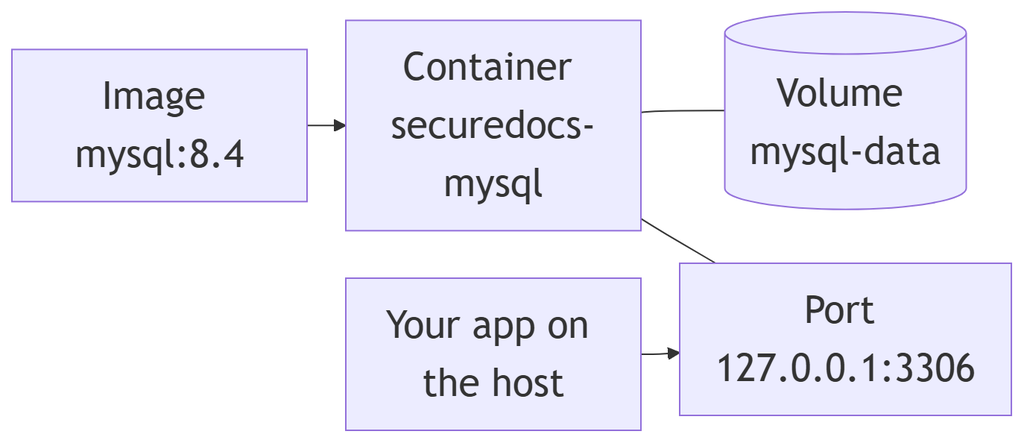

*Figure 10.1 — An image, its container, its volume and its published port*

*Text description:* Five boxes connected by lines. The image `mysql:8.4` starts the container `securedocs-mysql`. That container is attached to the volume `mysql-data` and to the published port `127.0.0.1:3306`, and your app running on the host connects to that port.

Docker fetches images from a **registry**, a public store; Docker Hub is the default. Images have a tag after the colon (`mysql:8.4`), the same idea as Chapter 7's Git tags but for images. An image is built in **layers**, each the result of one step. Docker stores each layer once and reuses it, which is why pulling a second image that shares layers is fast.

### 10.3 Your first containers

Install Docker Desktop (Windows and macOS) or Docker Engine (Linux) from docs.docker.com. Check that it works:

```bash
docker --version
docker run --rm hello-world
```

`docker run` starts a container from an image, downloading the image first if it is not on your computer. `hello-world` is a tiny image that prints a message and exits; `--rm` deletes the container afterward. You should see something like this:

```
Hello from Docker!
This message shows that your installation appears to be working correctly.
...
```

Now three commands that show what Docker holds:

```bash
docker images
docker ps
docker ps -a
```

`docker images` lists the images on your computer. `docker ps` lists running containers, and `docker ps -a` adds stopped ones. After the `--rm` run of `hello-world` in this section, `hello-world` shows in `docker images` but not in `docker ps -a`, because its container was removed and its image was not.

## Intermediate tier: Docker Compose

*On a first read you can skim this tier; Chapter 33 returns to the full stack.*

### 10.4 Running MySQL 8.4 with Docker

You could start MySQL with one long `docker run` command, but you would have to retype it exactly, and a long command invites typing mistakes. **Docker Compose** describes one or more containers in a file, `docker-compose.yml`, and starts them with one command. It is written in YAML, the indentation-based format from Chapter 2.

The database first appears at `book-m1-accounts`, where the file held only MySQL. Here it is, in full, exactly as it was at that milestone.

**Listing 10.1 — `docker-compose.yml` (book-m1-accounts)**

```yaml
# Local development database. Usage: `docker compose up -d` from this folder.
# Credentials come from the git-ignored .env file (copy .env.example).
services:
  mysql:
    image: mysql:8.4
    container_name: securedocs-mysql
    restart: unless-stopped
    environment:
      MYSQL_DATABASE: ${DB_NAME:-securedocs}
      MYSQL_USER: ${DB_USERNAME:-securedocs}
      MYSQL_PASSWORD: ${DB_PASSWORD:?Set DB_PASSWORD in .env}
      MYSQL_ROOT_PASSWORD: ${DB_ROOT_PASSWORD:?Set DB_ROOT_PASSWORD in .env}
    ports:
      # Bound to localhost only; the database is never exposed to the network.
      - "127.0.0.1:${DB_PORT:-3306}:3306"
    volumes:
      - mysql-data:/var/lib/mysql
    healthcheck:
      test: ["CMD", "mysqladmin", "ping", "-h", "localhost", "-u", "root", "-p${DB_ROOT_PASSWORD}"]
      interval: 5s
      timeout: 5s
      retries: 20

volumes:
  mysql-data:
```

*Path: `docker-compose.yml`*

From the repository folder, with your `.env` in place (Chapter 2), start it:

```bash
docker compose up -d
```

`up` starts what the file describes, and `-d` (detached) runs it in the background. The first time, Docker downloads the MySQL image. Then check on it:

```bash
docker compose ps
```

You should see something like this, with the state moving from `starting` to `healthy` after a few seconds:

```
NAME               IMAGE       ...   STATUS
securedocs-mysql   mysql:8.4   ...   Up 12 seconds (healthy)
```

To read what the database is saying, and to stop it when you are done:

```bash
docker compose logs mysql
docker compose down
```

Notice that Compose commands use the *service* name from the file (`mysql`), not the container name (`securedocs-mysql`). If you came here from Chapter 9's hands-on section, `docker compose up -d` is the command it needed.

`down` removes the containers but keeps the volume, so your data survives. Adding `-v` would delete the volumes too, and with them all the data, so use it only when you mean to.

The project chose this setup deliberately. When the implementer offered a zero-install embedded database (H2) as the recommended option for storage, the project's owner overrode it and asked for MySQL through Docker, because it is a real database engine of the kind used in production.

### 10.5 Reading the Compose file line by line

Here is the MySQL service from the final version of the file.

**Listing 10.2 — `docker-compose.yml` (book-m6-final, excerpt: service `mysql`)**

```yaml
services:
  mysql:
    image: mysql:8.4@sha256:85b9bf2e29cf836ecb8c2a15a935d4ba0c606631dff1dd79531a11983c638f2a
    container_name: securedocs-mysql
    restart: unless-stopped
    environment:
      MYSQL_DATABASE: ${DB_NAME:-securedocs}
      MYSQL_USER: ${DB_USERNAME:-securedocs}
      MYSQL_PASSWORD: ${DB_PASSWORD:?Set DB_PASSWORD in .env}
      MYSQL_ROOT_PASSWORD: ${DB_ROOT_PASSWORD:?Set DB_ROOT_PASSWORD in .env}
    ports:
      # Bound to localhost only; the database is never exposed to the network.
      - "127.0.0.1:${DB_PORT:-3306}:3306"
    volumes:
      - mysql-data:/var/lib/mysql
    healthcheck:
      # $$ defers expansion to the container, so the password never appears in
      # the stored command (docker inspect); MYSQL_PWD keeps it off the argv.
      test: ["CMD-SHELL", "MYSQL_PWD=\"$$MYSQL_ROOT_PASSWORD\" mysqladmin ping -h localhost -u root --silent"]
      interval: 5s
      timeout: 5s
      retries: 20
```

*Path: `docker-compose.yml`*

Line by line:

- `image: mysql:8.4@sha256:...` names the image, its tag, and a **digest**: a fingerprint of the exact image contents. A tag can be re-pointed to a newer image; a digest cannot. Pinning by digest means a rebuild gets exactly the reviewed image, as the project's own comment in the file explains.
- `restart: unless-stopped` restarts the container after a crash or reboot, unless you stopped it on purpose.
- `environment:` sets environment variables inside the container (Chapter 2). The MySQL image reads them on first start to create the database and user. `${DB_NAME:-securedocs}` means "the value of `DB_NAME` from `.env`, or `securedocs` if unset". `${DB_PASSWORD:?Set DB_PASSWORD in .env}` means "required": Compose stops with that message if the variable is missing.
- `ports: "127.0.0.1:3306:3306"` publishes container port 3306 to your computer's port 3306, but only on `127.0.0.1`. That means no other machine can connect (Chapter 2).
- `volumes: mysql-data:/var/lib/mysql` attaches a named volume at the folder where MySQL keeps its data. The volume is declared at the bottom of the file.
- `healthcheck` runs a command every 5 seconds to test whether MySQL is really answering. A container can be running but not yet ready; the health check tells other services when they can begin.

Compare the health check in Listing 10.1 with the one here. The early version passed the password on the command line as `-p${DB_ROOT_PASSWORD}`. The final version changed it: `$$` defers the variable's expansion until the command runs inside the container, and the password is passed through the environment variable `MYSQL_PWD`, not as an argument. The stated reason is that the password then never appears in the stored command (which `docker inspect` would reveal) or in the process's argument list (which other users of the machine could see). It is a small change with a general lesson: a secret on a command line is visible in more places than you expect.

Be honest about what the change achieves, though, because the MySQL 8.4 manual is blunt about `MYSQL_PWD`. It says that using `MYSQL_PWD` to specify a password "must be considered extremely insecure," because on some systems any user who can list processes can also see their environment. It also says that the variable "is deprecated as of MySQL 8.4" and may be removed in a future version. The trade the project made is narrower than "secure." The password is gone from the command line and from the stored command. Inside the container, only that container's own processes can see the environment. A stricter option is an **option file**, a small configuration file for the MySQL client that holds the password and is readable only by its owner (mode `400` or `600`); you point the client at it with `--defaults-extra-file`. The manual also describes `mysql_config_editor`, which stores credentials in an obscured login file. Chapter 34 uses `MYSQL_PWD` for its backup commands for the same reason as here, and you should treat either approach as a step up from `-p` on the command line, not as the last word.

### 10.6 Profiles, networks, and the full stack

A Compose file can hold several services. The final file adds `app` (the backend), `web` (the frontend server), and `tls` (an optional HTTPS frontend). It uses **profiles** so that you start only what you need. The header comment lists the three ways to run it:

**Listing 10.3 — `docker-compose.yml` (book-m6-final, excerpt: header comment)**

```yaml
# Local development:  `docker compose up -d`                    -> MySQL only (run the app with mvnw / ng serve)
# Full stack:         `docker compose --profile full up -d --build` -> MySQL + API + web at http://localhost:8081
# With HTTPS:         `docker compose --profile full --profile tls up -d --build` -> also https://localhost:8443
```

*Path: `docker-compose.yml`*

A service with `profiles: ["full"]` starts only when you ask for that profile, so plain `docker compose up -d` gives you only MySQL, which is what you want while developing. Here is the backend service.

**Listing 10.4 — `docker-compose.yml` (book-m6-final, excerpt: service `app`)**

```yaml
  app:
    profiles: ["full"]
    build: .
    container_name: securedocs-app
    restart: unless-stopped
    # The JVM sizes its heap from this (MaxRAMPercentage=75); rendering is bounded by
    # max-concurrent-renders, so a PDF can't take the host down with it.
    mem_limit: 1536m
    env_file: .env
    environment:
      DB_HOST: mysql
      DB_PORT: "3306"
      STORAGE_ROOT: /data/storage
      # Behind nginx: trust X-Forwarded-For so throttling and audit see real client IPs...
      FORWARD_HEADERS_STRATEGY: native
      # ...but only from nginx itself (its fixed address below). Any other container
      # on this network that talks to app:8080 directly is judged by its own address.
      TRUSTED_PROXY_REGEX: '172\.28\.0\.10'
    volumes:
      - app-storage:/data/storage
    depends_on:
      mysql:
        condition: service_healthy
    # Not published: only reachable through the web container.
    expose:
      - "8080"
    healthcheck:
      test: ["CMD", "curl", "-fsS", "-o", "/dev/null", "http://localhost:8080/actuator/health"]
      interval: 10s
      timeout: 5s
      start_period: 60s
      retries: 6
```

*Path: `docker-compose.yml`*

Several ideas appear at once, and each one connects to something you know.

- `build: .` means "build the image from the `Dockerfile` in this folder" (Section 10.8), instead of downloading one.
- `env_file: .env` passes every variable in your `.env` into the container, and `environment:` then adds or overrides some. Notice `DB_HOST: mysql`. Inside the Compose network, each service is reachable by its **service name**, so the backend finds the database at the host name `mysql`, not `localhost`. (Inside a container, `localhost` means the container itself.) That is what Docker's network from Section 10.2 does.
- `mem_limit: 1536m` caps the container's memory. The comment explains the interaction: the Java virtual machine (Chapter 3) sizes its heap (the memory a Java program uses for its objects) as a percentage of that limit, so a large PDF cannot exhaust the host.
- `volumes: app-storage:/data/storage` gives the backend a persistent place for tiles; without a volume the rendered tiles would vanish on every restart.
- `depends_on` with `condition: service_healthy` makes the backend wait until MySQL's health check passes. Without it, the backend would often start first and fail to connect.
- `expose` (not `ports`) makes port 8080 reachable by other containers but not from your computer. Only the web container is published to the host, so all outside traffic passes through it.
- The `healthcheck` here uses `curl` against the app's health endpoint from Chapter 8. `start_period: 60s` gives the app a minute to start before failures count.

The fixed address matters. The `web` service is pinned to `172.28.0.10` on a network whose subnet (a reserved block of network addresses) the file declares, and `TRUSTED_PROXY_REGEX` tells the backend to believe the client address in the **X-Forwarded-For** header (a header in which proxies list the client addresses a request has passed through) only when the request comes from that one address. Section 10.11 tells why.

### 10.7 Environment variables and secrets in containers

The Compose file contains no passwords. It reads `${DB_PASSWORD}` from `.env`, the Git-ignored file from Chapter 2, and passes it into the container. The `app` service uses `env_file: .env` for the same purpose. The result: secrets live in one local file, and the repository holds only the template.

A second protection keeps secrets out of images. When you build an image, Docker sends the project folder to the builder as the **build context**, and a careless `COPY . .` could copy `.env` into the image, where anyone who receives the image could read it. The file `.dockerignore` excludes files from the context, the same way `.gitignore` excludes them from Git.

**Listing 10.5 — `.dockerignore` (book-m6-final)**

```
# Never send secrets, data or build output into the image build context.
.env
storage/
target/
frontend/
.git/
.idea/
.vscode/
*.log
```

*Path: `.dockerignore`*

`.env` and `storage/` (uploaded content) are secrets and data; `target/` and `frontend/` are build output and a different project's files; `.git/` is history, which could contain more than you meant to ship. Keeping them out also makes builds faster, because Docker has less to copy.

**We simplify here.** An environment variable is visible to anyone who can inspect the container. For a small deployment that is acceptable; larger systems use a dedicated secrets store. Section 33.11 covers how the project handles secrets and configuration in a real deployment.

## Advanced tier: Building your own images

*On a first read you can skip to "In this project"; Chapter 33 comes back to image hardening.*

### 10.8 Building your own image (a first Dockerfile)

For MySQL you used a ready-made image. For the backend, the project builds its own from a **Dockerfile**: a recipe of steps. Each step adds a layer to the image, and Docker reuses layers that have not changed, which makes rebuilds fast. The project's file has two stages. The file's first comments give the commands: build with `docker build -t secure-doc-viewer-api .`, or, usually, through Compose with `docker compose --profile full up -d --build`.

**Listing 10.6 — `Dockerfile` (book-m6-final, simplified: image digests replaced by `<digest>`; comments omitted)**

```
FROM eclipse-temurin:25-jdk@sha256:<digest> AS build
WORKDIR /src
COPY mvnw pom.xml ./
COPY .mvn .mvn
RUN chmod +x mvnw && ./mvnw -B -q dependency:go-offline
COPY src src
RUN ./mvnw -B -q -DskipTests package

FROM eclipse-temurin:25-jre@sha256:<digest>
RUN apt-get update \
    && apt-get install -y --no-install-recommends fontconfig fonts-dejavu-core curl \
    && rm -rf /var/lib/apt/lists/* \
    && groupadd --system app && useradd --system --gid app --home /app app \
    && mkdir -p /app /data/storage && chown -R app:app /app /data
WORKDIR /app
COPY --from=build /src/target/secure-doc-viewer.jar app.jar
USER app
ENV STORAGE_ROOT=/data/storage \
    JAVA_TOOL_OPTIONS="-XX:MaxRAMPercentage=75 -Djava.awt.headless=true"
VOLUME /data/storage
EXPOSE 8080
ENTRYPOINT ["java", "-jar", "/app/app.jar"]
```

*Path: `Dockerfile`*

Reading it, stage by stage.

- `FROM` picks a base image. The first stage uses a full JDK (`25-jdk`) because building needs the compiler. `AS build` names it.
- `WORKDIR` sets the working folder. `COPY` brings files in. `RUN` executes a command at build time: here, the Maven wrapper from Chapter 6.
- The order is deliberate, and it is the most important idea in this chapter about performance. Copying `pom.xml` and downloading dependencies first means that layer is cached until `pom.xml` changes; copying `src` later means a code change does not repeat the downloads. The project's own comment says: "Dependencies first, so they stay cached until pom.xml changes." Swap the order and every one-line code change would download everything again.
- The second `FROM` starts a fresh image with only a JRE (`25-jre`, Java without the compiler). `COPY --from=build` takes only the finished JAR from the first stage. This is a **multi-stage build**: the final image is smaller and contains no build tools or source code, so there is less to attack.
- The long `RUN` installs three things the running app needs. `fontconfig` and `fonts-dejavu-core` are fonts, because the watermark and PDF rendering draw text with Java's graphics library, which needs real fonts even in a container with no screen. `curl` is for the health check from Listing 10.4. It also creates an unprivileged user and group named `app`, and makes the folders it will write to. The chained `&&` and the final `rm -rf /var/lib/apt/lists/*` keep the layer small by deleting package downloads in the same step that created them.
- `USER app` runs the program as that unprivileged user rather than as `root` (the administrator account of a Linux system, which can do anything). If an attacker takes over the program, they gain less.
- `ENV` sets variables: the storage folder, and JVM options that cap the heap at 75 percent of the container's memory and turn off graphics that need a screen (`java.awt.headless`). `VOLUME` marks where data lives, `EXPOSE` documents the port, and `ENTRYPOINT` is the command that starts the app.

The frontend has a Dockerfile of the same shape: build the Angular app in a Node image, then copy only the built files into a small web server image.

**Listing 10.7 — `frontend/Dockerfile` (book-m6-final, simplified: image digests replaced by `<digest>`; the header comment omitted)**

```
FROM node:24-alpine@sha256:<digest> AS build
WORKDIR /src
COPY package.json package-lock.json ./
RUN npm ci --no-audit --no-fund
COPY . .
RUN npx ng build --configuration production

# Unprivileged variant: nginx runs as a non-root user and listens on 8080.
FROM nginxinc/nginx-unprivileged:stable-alpine@sha256:<digest>
COPY nginx.conf /etc/nginx/conf.d/default.conf
COPY --from=build /src/dist/frontend/browser /usr/share/nginx/html
EXPOSE 8080
```

*Path: `frontend/Dockerfile`*

It follows the same cache logic (package files first, source later) and the same two-stage idea. The final image contains only nginx and the built site: no Node, no source, no `node_modules`. Chapter 20 explains `npm ci` and the build.

### 10.9 Choices that harden the stack

Collect the security choices scattered through this chapter's listings:

- **Digests, not only tags.** Every image is pinned by `sha256` digest, and Dependabot proposes updates, so a rebuild gets exactly the reviewed image and updates arrive as reviewable pull requests.
- **Non-root everywhere.** The backend runs as `app`, and the frontend uses the unprivileged nginx image.
- **Published on localhost only.** MySQL and the web port are bound to `127.0.0.1`; the backend is not published at all.
- **Resource limits.** `mem_limit` on the containers keeps one runaway process from taking the machine.
- **Health checks.** They let Compose start services in a safe order and let operators see real status.
- **Scanned images.** The project's CI builds the images and scans them for known vulnerabilities, failing on any high, or critical issue that has a fix (Chapter 36).

These were not all there at first. The review by the AI technical-manager reviewer listed "no Dockerfile, no CI, no Maven wrapper" as a finding. The Docker stack arrived in the fifth phase. It was then tightened over several review rounds, and non-root nginx and digest pinning came in the second round. A related decision concerns upgrades. When the bot Dependabot proposed moving MySQL from 8.4 to a release numbered 26.7, the project declined. It told the bot to ignore major-version bumps for the database. 8.4 is a long-term-support release, and 26.7 was an "innovation" release. Moving to the next long-term-support version would be a deliberate upgrade with a migration test.

### 10.10 Why Docker and not the obvious alternatives?

Two alternatives come to mind. You could **install MySQL directly** on your computer. That works, but the installation drifts: your version differs from a teammate's, uninstalling leaves files behind, and the steps live only in someone's head. Or you could use a virtual machine, which is heavier and slower for the same repeatability. The container's cost is that you must learn one more tool and keep Docker running; the benefit is that "the database" is one line, and it is the same line everywhere. For an application with a database, a web server, and an optional HTTPS frontend, that trade is strongly in favor of containers. Chapter 33 shows how the same images are deployed.

### 10.11 A real incident: the address the proxy forwarded

The fixed network address in Listing 10.4 exists because of a real bug found in review. The `web` container runs nginx, a **reverse proxy**: a server that sits in front of another one and forwards requests to it. Nginx passes each request to the backend and adds the client's address in a header called `X-Forwarded-For`. That header lets the backend's sign-in throttle and audit log see who is calling. The first version appended to whatever `X-Forwarded-For` the client had sent. A reviewer testing through nginx showed that any client could put a fake address in that header and reset its own sign-in lockout, and the audit log filled with invented addresses. The pull request's text had even claimed direct callers could not spoof it, which was false.

The fix came in stages: nginx now overwrites the header with the true peer address; then the Compose file fixed a subnet and gave nginx a fixed address, and the backend was told to trust the header only from that address. The lesson generalizes beyond Docker: a value that a client can influence, such as a header, is only as trustworthy as the last system you actually control. Chapter 16 tells the whole story.

### 10.12 Common mistakes

**"Cannot connect to the Docker daemon" or "docker: command not found."** (The daemon is Docker's background service.) Docker itself is not running or not installed. Start Docker Desktop and wait for it to say it is running. On Windows, Docker may also need the Windows Subsystem for Linux updated and virtualization enabled in the BIOS (the computer's low-level startup settings), as the project's owner found.

**"Set DB_PASSWORD in .env."** Compose printed the message from a `:?` placeholder. You have no `.env`, or the variable is blank. Copy `.env.example` to `.env` and fill it in (Chapter 2).

**"port is already allocated" or "address already in use."** Another program, perhaps a MySQL you installed by hand, is using port 3306. Stop it, or change `DB_PORT` in `.env`. Chapter 2 shows how to find the culprit.

**The database is empty after `down -v`.** The `-v` flag deletes volumes, and with them the data. Use plain `docker compose down` to keep it.

**The app cannot reach the database inside Compose.** Inside a container, `localhost` is the container itself. The backend must use the service name: `DB_HOST: mysql`, as Listing 10.4 sets.

**Changes to the code do not appear.** You changed the code but not the image. Rebuild with `docker compose --profile full up -d --build`.

**Disk fills up.** Old images and stopped containers accumulate. `docker system prune` removes unused ones; read its confirmation prompt first.

**A secret ended up in an image.** Check `.dockerignore` and any `COPY . .` step. Rebuild without it, and treat the leaked secret as exposed (Chapter 7).

## In this project

- `docker-compose.yml`: MySQL, and behind profiles the backend, web server, and TLS frontend. Milestone `book-m1-accounts` has the MySQL-only version; `book-m5-platform` added the full stack.
- `Dockerfile` and `frontend/Dockerfile`: the backend and frontend images.
- `.dockerignore`: keeps `.env`, `storage/`, and `target/` out of the build context, so secrets never enter an image. - `.env.example`: the template for the variables Compose reads.
- `deploy/Caddyfile`: the optional HTTPS frontend (Chapter 33).

## Try it

### Exercise 10.1 ★ Image or container?

For each, say image, container, volume, or network: `mysql:8.4`; the running `securedocs-mysql`; `mysql-data`.

*Solution:* Appendix C, Exercise 10.1.

### Exercise 10.2 ★ Start the database

Copy `.env.example` to `.env`, choose your own values for the two password variables (never reuse a real password), and run `docker compose up -d`. Use `docker compose ps` to see the health status. Then run `docker compose down`, start again, and explain why your data would survive.

*Solution:* Appendix C, Exercise 10.2.

### Exercise 10.3 ★★ Read the ports

In Listing 10.2, what would change if the ports line were `"3306:3306"`? Why did the project add the `127.0.0.1` prefix?

*Solution:* Appendix C, Exercise 10.3.

### Exercise 10.4 ★★ Compare two health checks

Read the `healthcheck` in Listing 10.1 and in Listing 10.2. List every difference, and explain in your own words why the final version is safer.

*Solution:* Appendix C, Exercise 10.4.

### Exercise 10.5 ★★ Trace a dependency

In Listing 10.4, find the lines that make the backend wait for MySQL. Then explain what would probably happen on a slow computer if they were removed.

*Solution:* Appendix C, Exercise 10.5.

### Exercise 10.6 ★★★ Reorder the Dockerfile

In Listing 10.6, imagine moving `COPY src src` above the `dependency:go-offline` step. Describe, step by step, what happens when you change one line of Java code and rebuild, before, and after the move. Which version is faster, and why?

*Solution:* Appendix C, Exercise 10.6.

## Summary

- Docker runs programs in isolated, repeatable containers created from images; it is lighter than a virtual machine.
- Volumes keep data across container removal; networks let containers reach each other by service name.
- Compose describes services in one file; profiles select which start; health checks say when a service is ready; `depends_on` orders them.
- Secrets come from a Git-ignored `.env`, never from the repository, and `.dockerignore` keeps them out of images.
- A multi-stage Dockerfile builds in one image and ships a smaller, non-root one, and its step order decides how well builds are cached.
- Pinning by digest, publishing on localhost only, and scanning images are the project's hardening choices, and each has a reason.

## Further reading

- *Docker Docs*, "Get started." https://docs.docker.com/get-started/
- *Docker Docs*, "Compose file reference." https://docs.docker.com/reference/compose-file/
- *Docker Docs*, "Dockerfile reference." https://docs.docker.com/reference/dockerfile/
- *Docker Docs*, "Building best practices." https://docs.docker.com/build/building/best-practices/
- *MySQL 8.4 Reference Manual*, "Deploying MySQL on Linux with Docker." https://dev.mysql.com/doc/refman/8.4/en/linux-installation-docker.html

# Part II: The backend

In Part I you learned the language (Java), the tools (Maven, Git, Docker), and the web and database basics the rest of the book stands on. Part II builds the server side of the Secure Document Viewer on top of them.

The backend is the part of the app users never see, and everything depends on it. It decides who you are, what you may open, and whether a request is honest. Anyone can bypass the browser by sending requests to the server with a script, so every rule that matters lives here and not in the user interface. That single idea explains most of the design you'll read in the next eight chapters, and it's why a good deal of this part is about refusing things politely and consistently.

## What the part covers

Table II.1 lists the chapters and says why the app needs each topic.

Table II.1 — The chapters of Part II

| Chapter | Topic | Why the app needs it |
| --- | --- | --- |
| 11 | Spring Boot foundations | The framework that starts the server and wires its classes together |
| 12 | REST controllers and JSON | Every action the browser takes arrives as an HTTP request to a controller method |
| 13 | Validation, configuration, and errors | Bad input must be refused, a broken configuration must stop the server, and every error has one shape |
| 14 | Storing data with JPA and Flyway | Accounts, documents, shares, and the audit trail live in MySQL |
| 15 | Spring Security I | The server must know who you are before it can decide anything |
| 16 | Spring Security II | Signed-in sessions, sign-in attempts, and proxies all need defenses |
| 17 | Files, images, PDFs, and signatures | The core of the product: pages become watermarked tiles behind unforgeable links |
| 18 | Testing the backend | Every promise the app makes is checked by a test |

## The path of one request

The chapters follow the route a request takes through the server, so it helps to see the whole route once. Figure II.1 shows it in the order the parts meet a request.

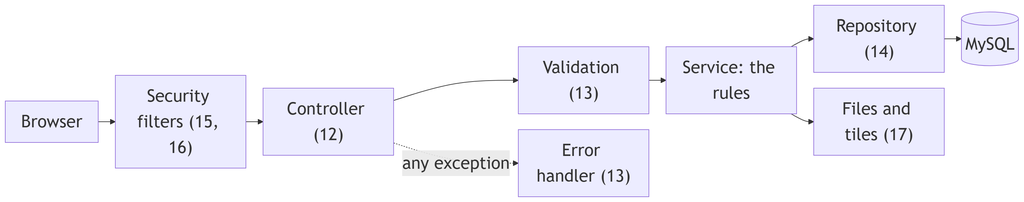

*Figure II.1 — The route of one request through the backend, with the chapters that teach each stop*

*Text description:* A browser sends a request that passes through the security filters (Chapters 15 and 16) to a controller (Chapter 12). The controller hands the input to validation (Chapter 13), then to a service that applies the rules. The service uses a repository (Chapter 14) to reach the MySQL database, and uses files and tiles (Chapter 17). A dotted line from the controller to the error handler (Chapter 13) shows that any exception ends there.

A request first meets the security filters (Chapters 15 and 16), which decide who is calling and whether they may go further. The controller (Chapter 12) reads the path, the query string, or the JSON body. Validation (Chapter 13) checks the input. The service applies the rules of the application, such as which documents a user may open, and uses repositories to read and write MySQL (Chapter 14) and, for documents, the files on disk (Chapter 17). If anything fails on the way, an exception handler (Chapter 13) turns it into the one JSON error shape the browser understands. Chapter 11 is the framework that connects all of these, and Chapter 18 shows how to test each stop.

## Why this order

Chapter 11 comes first because everything else is a Spring Boot idea: beans, configuration, and annotations. Chapter 12 adds the front door, the controller, so you can see something answer a request. Chapter 13 then teaches what a careful server does with what it receives, before the data layer arrives in Chapter 14. Chapters 15 and 16 come after the data layer because the accounts they protect live in the database. Chapter 17 gathers the image, signing, and file handling that the tile endpoint needs; it leans on ideas from Chapters 12, 13 and 15. Chapter 18 comes last because it tests everything before it.

## How each chapter is organized

Every chapter has three tiers. The **beginner tier** teaches the core idea with an analogy, defines the terms, and reads the setup code line by line. The **intermediate tier** shows how the pieces talk to each other and why this design was chosen over the obvious alternatives. The **advanced tier** covers security, performance, and architecture, with real incidents from this project's history: the audit rows that vanished, the sign-in guesses that all got through at once, the error that turned into a `500`. You can read only the beginner tier of each chapter on a first pass and return for the rest later; each later tier tells you what you can skip.

Code labeled *Listing* is copied from the repository at a named tag, such as `book-m6-final`, and you can print the same file with `git show <tag>:<path>`. Where a listing is shortened, the caption says what was left out. Code labeled *Example* is written for this book to teach an idea, and never carries a tag. Part II mostly quotes the final code (`book-m6-final`) because it is the most complete, and it says so when it quotes an earlier tag. Part IV then tells the story of how the app grew, milestone by milestone, so this part teaches the concepts and leaves most of the history to Part IV.

## Before you start

The backend uses Java 25, Spring Boot 4.1.1, Spring Security 7, Jackson 3, Hibernate 7, Flyway 12, and MySQL 8.4. You can read Part II with only the source code and this book. To try the exercises, you need the setup from the front matter and, for the chapters that touch the database, the MySQL container from Chapter 10. Exercises that change code tell you to work on your own branch (Chapter 7), never on a milestone tag.

## If you already know Spring

If you have used Spring before, skim Chapter 11 and read from Chapter 13. The project has a few choices that differ from a typical tutorial and are worth seeing:

- Constructor injection everywhere, and typed, validated configuration that stops startup when a secret is missing (Chapters 11 and 13).
- One JSON error shape for everything, including errors raised by the security filters (Chapter 13).
- Transactions managed by a `TransactionTemplate` in the document service, so a slow PDF render never holds a database connection (Chapter 14).
- Sessions and an `httpOnly` cookie rather than tokens, with a CSRF cookie the single-page app copies into a header (Chapters 15 and 16).
- Sign-in attempts counted before the password is checked, so that parallel guesses can't beat the limit (Chapter 16).

## What you will have at the end

By the end of Part II you'll be able to read any class in `src/main/java` and say what it is for, why it is built that way, and how it is tested. You won't have built the app yet: Part III does the same for the browser side, and Part IV assembles both into the finished viewer, one milestone at a time.

# Chapter 11: Spring Boot foundations

Everything the Secure Document Viewer does on the server (signing you in, listing documents, cutting a PDF page into tiles) runs inside one Java program built on Spring Boot. This chapter explains what a framework is, shows the smallest Spring Boot application in the repository, and teaches the two ideas the rest of Part II depends on: beans and dependency injection. It then shows how the program is configured from outside, what the one-line dependencies called starters bring in, how logging works, and why a well-built Spring program refuses to start rather than misbehave.

## Learning objectives

By the end of this chapter, you will be able to:

- Explain what a framework is and how it differs from a library.
- Describe what `@SpringBootApplication` does when the program starts.
- Explain what a bean is and how dependency injection supplies one to another class.
- Read a constructor-injected class such as `DocumentController` and name each of its dependencies.
- Configure the application through `application.yml`, environment variables, and profiles, and predict which value wins.
- Explain what a starter dependency and auto-configuration are, and where the project overrides a managed version.
- Write and read a log line, and choose the right level.

## Prerequisites

- Chapter 3: your first Java program (`main`, imports, `final`)
- Chapter 4: classes, objects, records and interfaces
- Chapter 6: Maven and the shape of a project
- Chapter 8: how the web works (HTTP requests and responses)

## Beginner tier: Someone else runs the show

### 11.1 What a framework is

Imagine you want to open a restaurant. You could build the building, wire the electricity, install plumbing, and only then start cooking. Or you could rent a fitted-out kitchen where the ovens, the extraction fans, and the fire alarms already exist, and you bring your recipes. A framework is the fitted-out kitchen: a large body of ready-made code that already knows how to start a program, listen for web requests and connect to a database. You supply the recipes, which are the pieces specific to your application.

A **library** is a single tool you pick up when you need it, such as a PDF reader. You call the library, and you decide when. With a framework, the direction reverses: the framework calls you. Your code sits in classes that the framework finds, creates and invokes at the right moment. This reversal has a name, **inversion of control**, and it explains most of what looks strange about Spring at first. Here is the difference as two tiny sketches. They are written to teach, so they are Examples, not project code.

**Example 11.1 — You call a library; a framework calls you (teaching example)**

```java
// A library: your code is in charge and decides when to call it.
public static void main(String[] args) {
    Report report = PdfLibrary.open("quarterly.pdf");   // you call it
    System.out.println(report.pageCount());
}

// A framework: you write a method and a label; the framework decides when to call it.
@GetMapping("/api/documents")
public List<DocumentSummary> list() {                   // the framework calls you
    return documents.list();
}
```

Nobody in the project writes code that says "when a request for `/api/documents` arrives, call `list`." You write the method and the label, and Spring does the waiting, the listening and the calling.

**Where the analogy breaks down:** a rented kitchen has walls you can see. A framework's structure is mostly invisible: it's made of rules such as "any class with this label gets created at startup." When something goes wrong, you often need to know the rule to understand the behavior. Much of Part II is these rules.

Spring is the framework the project uses. **Spring Boot** is a layer on top of it that chooses sensible defaults, so a program can start with almost no setup. The project uses Spring Boot 4.1.1 on Java 25 (`pom.xml`, tag `book-m6-final`). Two other pieces appear in this chapter. Maven downloads the libraries (Chapter 6). Tomcat is the web server built into the finished program, so running the app is one command and needs no separate server installation.

### 11.2 The first Spring Boot application

Listing 11.1 is the entire entry point of the server. It is short on purpose: nearly everything else is discovered by the framework.

**Listing 11.1 — `SecureDocViewerApplication.java` (`book-m6-final`)**

```java
package com.example.securedocviewer;

import org.springframework.boot.SpringApplication;
import org.springframework.boot.autoconfigure.SpringBootApplication;
import org.springframework.scheduling.annotation.EnableScheduling;

@SpringBootApplication
@EnableScheduling
public class SecureDocViewerApplication {
    public static void main(String[] args) {
        SpringApplication.run(SecureDocViewerApplication.class, args);
    }
}
```

*Path: `src/main/java/com/example/securedocviewer/SecureDocViewerApplication.java`*

Read it from the bottom up.

- `main` is the method Java runs first (Chapter 3). Its only job is to hand control to `SpringApplication.run`, which starts the framework. From this line on, Spring is in charge.
- Words that start with `@` are annotations: labels attached to a class or method that tell a tool how to treat it. They don't change what the code does by themselves; the framework reads them.
- `@SpringBootApplication` marks this class as the starting point. It switches on three behaviors. First, it tells Spring to search this package and every package beneath it (`com.example.securedocviewer...`) for classes to manage, which is called **component scanning**. Second, it allows this class to declare extra configuration. Third, it turns on **auto-configuration**, which Section 11.5 explains.
- `@EnableScheduling` turns on the feature that runs methods on a timer. The project uses it for cleanup jobs that Chapter 14 describes; for now, note that one annotation is enough to activate a whole capability.

What happens when you run the program? You start it with Maven's wrapper from the project folder (Chapter 6):

```bash
./mvnw spring-boot:run
```

Then `main` runs, and `SpringApplication.run` does roughly the following, in order. This is a simplified description; the real sequence has more steps, but this is the outline to keep in mind.

1. **Read the configuration:** `application.yml`, environment variables, and any active profile (Section 11.4).
2. **Scan for classes to manage:** every class in `com.example.securedocviewer` and below that carries a label such as `@Service` or `@RestController` (Section 11.3).
3. **Create the objects and connect them:** each managed class is instantiated, and its dependencies are supplied (Section 11.3). The database connection, the security filters, the web server, and the scheduler are created here too, by auto-configuration.
4. **Run startup tasks:** for example, `BootstrapAdmin` creates the first administrator on an empty database (Section 11.7).
5. **Start listening:** the embedded web server accepts requests on the port from `server.port` (8080 in `application.yml`).

If any step fails, the program stops with an error and never listens. That's deliberate, and Section 11.7 explains why.

### 11.3 Beans and dependency injection

When Spring starts, it creates one object of every class it finds that is labeled as a managed component (with annotations such as `@Component`, `@Service`, `@RestController`, or `@Configuration`). Each such object is a **bean**, and the box that holds them all is the **application context**. By default there is one instance of each bean, shared by the whole program.

*Pattern note: Constructor injection is the dependency injection pattern (Chapter 38, Section 38.2).*

The labels tell Spring, and the reader, what kind of class this is. Three kinds appear throughout the project, so it helps to name them now. A **controller** is a class that answers web requests; Chapter 12 is about them. A **service** is a class that holds the rules of the application, such as who may open a document. A repository is a class that reads and writes the database; Chapter 14 covers it.

Table 11.1 — The labels that create beans

| Label | Meant for | Example in the project |
| --- | --- | --- |
| `@RestController` | A class that answers web requests | `DocumentController` |
| `@Service` | A class holding business rules | `DocumentService`, `UserAccountService` |
| `@Component` | Any other managed class | `StorageJanitor`, `ViewerProperties` |
| `@Configuration` with `@Bean` methods | A class that builds beans by hand | `SecurityConfig` |

Why not write `new DocumentService(...)` wherever you need one? Because a `DocumentService` needs a `DocumentRepository`, which needs a database connection, which needs configuration. If every class built its own helpers, you'd repeat that wiring everywhere, and you couldn't swap a helper for a fake in a test. Instead, a class declares what it needs, and Spring hands it over. That is dependency injection. To keep the kitchen analogy going: the chef doesn't drive to the market. The chef writes a list ("flour, eggs, butter"), and a supplier delivers exactly those items before service begins. The class's constructor is the list, and Spring is the supplier.

Listing 11.2 shows it in the smallest useful example in the repository.

**Listing 11.2 — Constructor injection in `DocumentController.java` (`book-m6-final`, simplified: the two nested records after the class line are omitted; only the constructor and its fields are shown, and the methods are left out)**

```java
@RestController
@RequestMapping("/api/documents")
public class DocumentController {

    // ... two nested records omitted ...

    private final DocumentService documents;
    private final RequestActors actors;

    public DocumentController(DocumentService documents, RequestActors actors) {
        this.documents = documents;
        this.actors = actors;
    }

    // ... request-handling methods omitted ...
}
```

*Path: `src/main/java/com/example/securedocviewer/controller/DocumentController.java`*

The constructor lists two parameters. When Spring builds the controller, it looks in the application context for a bean of type `DocumentService` and one of type `RequestActors`, and passes them in. Nothing in the class says where they come from, which is the point: `DocumentController` only says what it needs. The fields are `final`, so once the object exists its dependencies can't change or be missing. This style is called constructor injection, and every controller and service in the project uses it.

Why constructor injection rather than marking a field and letting Spring fill it in afterward? Three reasons. The dependencies are visible in one place, the constructor, so you can see at a glance how much a class depends on; a class with twelve parameters is asking to be split. The `final` fields make it impossible to forget one. And a test can create the class by hand, with a fake in place of a real dependency, by calling `new`, with no Spring at all. Chapter 18 shows tests that do exactly this, such as `new SignedUrlService(properties)`.

Dependencies form a chain, and Spring works out the order. Figure 11.1 shows the part of the chain behind `DocumentController`.

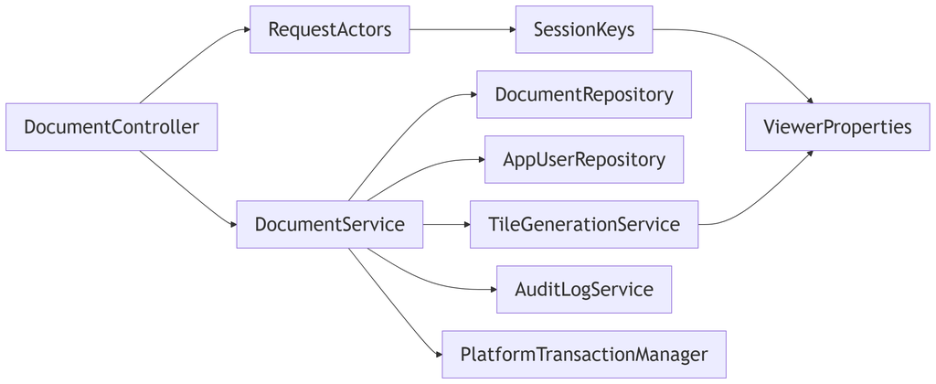

*Figure 11.1 — Part of the dependency chain behind `DocumentController`*

*Text description:* A left-to-right graph with `DocumentController` at the left, pointing to `DocumentService` and `RequestActors`. `RequestActors` points to `SessionKeys`, which points to `ViewerProperties`. `DocumentService` points to five things: two repositories, `TileGenerationService`, `AuditLogService`, and the transaction manager, and `TileGenerationService` also points to `ViewerProperties`. Notice that `ViewerProperties` sits at the right end of two branches, so one shared bean serves both.

Spring builds the leaves first: `ViewerProperties`, then `SessionKeys` and `TileGenerationService`, and so on up to the controller. If a bean can't be built or found, the program refuses to start and names the missing type, so a wiring mistake shows up at startup and never in front of a user.

Spring picks a dependency by type, not by name. If two beans of the same type exist, Spring can't choose without more information, and startup fails. `KnownDevices` shows a related detail. It has two constructors: a public one that Spring uses, and a second one, visible only inside its own package, which the unit tests use to supply a fixed clock. When there is more than one constructor, Spring needs to be told which to call, and the public one carries an explicit `@Autowired` label for that.

Not every bean can be created by labeling a class. Sometimes the class belongs to a library and you can't edit it. For those, a `@Configuration` class contains `@Bean` methods: each method builds an object, and its return value becomes a bean. `SecurityConfig` declares eight beans this way (a password encoder, a session registry, and so on), and Listing 11.3 shows one.

**Listing 11.3 — A hand-built bean in `SecurityConfig.java` (`book-m6-final`, excerpt: method `passwordEncoder`)**

```java
/** Delegating encoder stores "{bcrypt}..." so the algorithm can be upgraded later without a migration. */
@Bean
public PasswordEncoder passwordEncoder() {
    return PasswordEncoderFactories.createDelegatingPasswordEncoder();
}
```

*Path: `src/main/java/com/example/securedocviewer/security/SecurityConfig.java`*

Spring calls the method once, keeps the returned object, and hands it to every class that asks for a `PasswordEncoder`, such as `UserAccountService`. Chapter 15 explains what the encoder does.

## Intermediate tier: Configuring the program from outside

*If you're reading for the first time, Sections 11.4 and 11.5 are the important ones here; 11.6 is a short tour of logging.*

### 11.4 Configuration files: `application.yml`, profiles, environment variables

Some values must change between your laptop and a real server: the database address, a secret key, whether cookies require HTTPS. Hard-coding them would mean rebuilding the program for every machine, and putting secrets in code would mean publishing them with it. Spring Boot reads such values from outside the code, mainly from `src/main/resources/application.yml`, a file in the YAML format: indented `key: value` lines, where indentation means nesting. So this:

```yaml
server:
  servlet:
    session:
      timeout: 30m
```

sets the property named `server.servlet.session.timeout` to `30m`. Spring Boot defines many properties of its own (`server.port`, `spring.datasource.url`), and your own code can define more under a prefix of its choosing; the project's are under `secure-doc-viewer`.

Listing 11.4 shows two excerpts.

**Listing 11.4 — `application.yml` (`book-m6-final`, simplified: two excerpts, comments trimmed)**

```yaml
server:
  port: 8080
  servlet:
    session:
      timeout: 30m
      cookie:
        name: SDV_SESSION
        http-only: true
        same-site: strict
        secure: ${SESSION_COOKIE_SECURE:false}

spring:
  jpa:
    open-in-view: false
    hibernate:
      ddl-auto: none
```

*Path: `src/main/resources/application.yml`*

Three things to notice. First, `${SESSION_COOKIE_SECURE:false}` is a **property placeholder**: use the environment variable `SESSION_COOKIE_SECURE` if it exists, otherwise `false`. The same file therefore works on a laptop (plain HTTP, the default) and in production (the variable set to `true`). Second, keys like `server.servlet.session.timeout` are ones Spring Boot defines itself; you set them and the framework obeys. Third, values that come from `ddl-auto: none` and `open-in-view: false` are *decisions*: Chapter 14 explains why the project switched off two convenient defaults.

The database settings show the placeholder pattern at scale.

**Listing 11.5 — `application.yml` (`book-m6-final`, excerpt: the datasource; comments trimmed)**

```yaml
spring:
  datasource:
    url: jdbc:mysql://${DB_HOST:localhost}:${DB_PORT:3306}/${DB_NAME:securedocs}?connectionTimeZone=UTC&forceConnectionTimeZoneToSession=true
    username: ${DB_USERNAME:securedocs}
    password: ${DB_PASSWORD:}
```

*Path: `src/main/resources/application.yml`*

On a developer machine none of the `DB_` variables need to be set: the defaults point at MySQL on `localhost`. In Docker Compose (Chapter 10), the compose file sets `DB_HOST` to the name of the database container. The password has an *empty* default on purpose: there is no built-in password to guess, and a deployment must supply its own.

**Which value wins?** The same property can be given in several places, and Spring Boot applies a fixed order. The two you need to know: a value from an environment variable overrides the same property in `application.yml`, and a value from `application.yml` overrides a default written in code. The project adds one more source for local work, in `application.yml`:

```yaml
spring:
  config:
    import: optional:file:.env[.properties]
```

(`book-m6-final`, `application.yml`, excerpt.) This says: "if there is a file named `.env` next to the program, read it as a list of `NAME=value` lines." It is `optional`, so its absence is fine. The `.env` file is kept out of Git (Chapter 7), which is how a developer's secrets stay off GitHub. "Real environment variables win," says the comment beside it.

A profile is a named set of extra settings that you switch on. The tests use one: `@ActiveProfiles("test")` makes Spring also read `application-test.yml`, which overrides the datasource to point at an in-memory H2 database instead of MySQL. Chapter 14 and Chapter 18 cover why. The naming rule is always `application-<profile>.yml`.

**Relaxed binding.** One last convenience: Spring maps names loosely. The environment variable `SESSION_COOKIE_SECURE` is a legal way to set what the YAML calls `session.cookie.secure`, and `secure-doc-viewer.storage-root` in YAML maps to a `storageRoot` field in Java. That's why environment variables (upper case, underscores) and YAML (lower case, dashes) can describe the same setting.

In the project, most of the `secure-doc-viewer.*` settings are read into one typed Java class, `ViewerProperties`, which Chapter 13 explains. A few single values are read directly into a constructor with `@Value`, as in `BootstrapAdmin`:

**Listing 11.6 — `BootstrapAdmin.java` (`book-m6-final`, excerpt: the constructor)**

```java
public BootstrapAdmin(UserAccountService accounts,
                      @Value("${secure-doc-viewer.bootstrap-admin.username:admin}") String username,
                      @Value("${secure-doc-viewer.bootstrap-admin.password:}") String configuredPassword) {
    this.accounts = accounts;
    this.username = username;
    this.configuredPassword = configuredPassword;
}
```

*Path: `src/main/java/com/example/securedocviewer/account/BootstrapAdmin.java`*

`@Value` puts the value of one property into one parameter. The `:admin` after the property name is the default when nothing sets it, and the empty default after `password:` means "no password configured," which the class treats as "generate a random one" (Chapter 15). `@Value` is fine for one or two settings; for a group of related settings, a typed class is easier to read and validate.

### 11.5 Starters and auto-configuration

Look at the dependencies in `pom.xml` and you'll see names like `spring-boot-starter-webmvc`, `spring-boot-starter-security`, `spring-boot-starter-data-jpa`, and `spring-boot-starter-flyway`. A starter is a single dependency that pulls in a matched set of libraries for one job, at versions known to work together. Table 11.2 lists the ones the project uses.

Table 11.2 — The starters in `pom.xml` (`book-m6-final`) and what each brings

| Starter | What you get |
| --- | --- |
| `spring-boot-starter-webmvc` | Spring's web layer: controllers, JSON conversion, and the embedded Tomcat server |
| `spring-boot-starter-security` | Spring Security (Chapters 15 and 16) |
| `spring-boot-starter-validation` | Bean Validation annotations such as `@NotBlank` (Chapter 13) |
| `spring-boot-starter-data-jpa` | JPA, Hibernate, and Spring Data repositories (Chapter 14) |
| `spring-boot-starter-flyway` | Flyway database migrations (Chapter 14) |
| `spring-boot-starter-actuator` | Health and metrics endpoints (Chapter 35) |
| `spring-boot-starter-test` and friends | JUnit, Mockito, and the test tools (Chapter 18) |

A comment in the project's `pom.xml` notes that "Spring Boot 4 splits the old all-in-one starters into focused ones," which is why the web starter is named `webmvc` and Flyway has its own starter. Other dependencies (the MySQL driver, PDFBox, the Prometheus registry) are ordinary libraries with no starter.

**Where do the versions come from?** The top of the `pom.xml` declares `spring-boot-starter-parent` version `4.1.1` as its **parent POM**, a Maven project file that other projects inherit defaults from, such as a tested list of library versions. That parent contains a table of tested versions for hundreds of libraries, so most dependencies in the file have *no version number at all*: Maven takes it from the parent. Upgrading Spring Boot upgrades the whole tested set at once.

Auto-configuration is the second half of the trick. When Spring Boot starts, it looks at what is on the classpath and at your settings, and creates sensible beans for you. With the JPA (Jakarta Persistence) starter and a MySQL driver present and `spring.datasource.url` set, it builds the database connection pool and the transaction manager without you writing a line. With the Flyway starter present, it runs the migrations at startup (Chapter 14). With the web starter, it starts Tomcat. If you define your own bean of the same kind, yours takes priority: that's exactly what `SecurityConfig` does when it declares its own `PasswordEncoder` and `SecurityFilterChain` (Chapter 15). The rule of thumb is that Boot provides a default and you override only what you must.

We simplify here: the full list of what is auto-configured is long and changes between versions. You don't need to memorize it; you need to know that it exists, so that when a bean appears that you never wrote, you know where it came from.

### 11.6 Logging and startup output

A running server has no screen to show what it's doing, so it writes **log** lines to the console. Spring Boot configures logging by default, and the project writes to it through **SLF4J**, a common logging interface. Each class that logs declares a logger, and then calls a method named for the severity.

**Listing 11.7 — Logging in `BootstrapAdmin.java` (`book-m6-final`, excerpt: the logger and one call; the generated-password message is omitted)**

```java
private static final Logger log = LoggerFactory.getLogger(BootstrapAdmin.class);

// ...

log.info("Created initial admin account '{}' from BOOTSTRAP_ADMIN_PASSWORD.", username);
```

*Path: `src/main/java/com/example/securedocviewer/account/BootstrapAdmin.java`*

The logger is created once per class and tagged with the class name, so every line says which class wrote it. The `{}` in the message is a placeholder that SLF4J fills with the arguments that follow. Use placeholders, not string concatenation: the text is only assembled if that level is switched on, which is cheaper. That severity label is the **log level**: a label such as `error`, `warn`, `info`, or `debug` that says how important a log line is, so that you can filter them.

Table 11.3 — Log levels

| Level | Meant for | Example in the project |
| --- | --- | --- |
| `error` | Something failed that shouldn't have | `GlobalExceptionHandler` logs unexpected failures with a reference code (Chapter 13) |
| `warn` | Something suspicious, or something an operator must see | `BootstrapAdmin` prints a generated password once; `StorageJanitor` logs a folder it couldn't delete |
| `info` | A normal event worth recording | `BootstrapAdmin` creating the first admin; the audit purge reporting how many rows it deleted |
| `debug` | Detail for developers, off by default | (not used by the project's own code) |

**What must never be logged.** A log is copied, backed up and searched by many people, so secrets don't belong in it. The project logs a password in exactly one place, deliberately. When no bootstrap password is configured, `BootstrapAdmin` generates one and prints it *once*, because the operator has no other way to learn it. The account is flagged "must change password" at first sign-in (Chapter 15). Everywhere else, the audit log records that a sign-in *failed*, never what was typed.

This book doesn't reproduce a startup log, because its exact text depends on your machine and versions. When you run the app, read the output from the top. The framework reports which profile is active, the port it listens on, and any bean that failed to build. If startup fails, the last message in the output usually names the missing bean or the property that failed validation, and the lines above it show the chain of causes. When you're stuck, read the *last* "Caused by" line first: it's usually the root cause, and the earlier ones only describe how the failure travelled.

## Advanced tier: Failing early, and where the seams are

*You can skip to "In this project" on a first read; Part IV comes back to these ideas.*

### 11.7 Fail at startup, not at the first request

The most useful property of this wiring is that mistakes surface when the program starts. A missing dependency stops startup with an error naming the type. `ViewerProperties` goes further: its signing secret must be present and at least 32 characters, or the application refuses to start (Chapter 13 shows how). The source comment states the reason: startup fails "rather than failing on the first tile." A server that started with a broken secret would only fail later, in front of a user.

Startup is also the place for one-off setup. Some code must run once, after the beans exist but before the app accepts requests. `BootstrapAdmin` is the project's example. It implements `ApplicationRunner`, a Spring interface with one method that Spring calls once at the end of startup.

**Listing 11.8 — `BootstrapAdmin.run` (`book-m6-final`)**

```java
@Override
public void run(ApplicationArguments args) {
    if (accounts.hasAnyUsers()) {
        return;
    }
    boolean generated = configuredPassword == null || configuredPassword.isBlank();
    String password = generated ? randomPassword() : configuredPassword;
    // A generated password was printed to a log: it must be replaced at first sign-in.
    accounts.create(username, password, Role.ADMIN, generated);
    if (generated) {
        log.warn("\n\nCreated initial admin account '{}' with generated password: {}\n"
                + "Sign in and change it (or set BOOTSTRAP_ADMIN_PASSWORD before first start).\n", username, password);
    } else {
        log.info("Created initial admin account '{}' from BOOTSTRAP_ADMIN_PASSWORD.", username);
    }
}
```

*Path: `src/main/java/com/example/securedocviewer/account/BootstrapAdmin.java`*

Read it as a small story. If any account exists, do nothing: this code runs at *every* start, so it must be safe to run again, and "only on an empty database" is how it stays safe. Otherwise, decide whether a password was configured. If not (`generated`), make a random one. Create the administrator, flagging a generated password as "must change" (the fourth argument), because it is about to be printed. Then log which case happened. The class comment explains why the app needs it: "otherwise nobody could sign in to create anyone else." Note the design again: no credential is committed to the repository, and none is baked in.

### 11.8 Annotations are read by the framework, so calls matter

Annotations such as `@Transactional` work because Spring wraps the bean in a proxy, a stand-in object with the same methods that adds behavior (here, starting a database transaction) around your method. The consequence is that the wrapper only runs when the call comes from *outside* the bean, through the proxy. If a method calls another method on `this`, the proxy is bypassed and the annotation does nothing. Chapter 14 returns to this. The project's `DocumentService` doesn't use the annotation at all; it manages transactions explicitly, because rendering a PDF is slow and must run outside any database transaction (Chapter 14).

**Listing 11.9 — `pom.xml` (`book-m6-final`, excerpt: the `properties` block; indentation reduced)**

```xml
<properties>
    <java.version>25</java.version>
    <pdfbox.version>3.0.8</pdfbox.version>
        <tomcat.version>11.0.26</tomcat.version>
</properties>
```

*Path: `pom.xml`*

### 11.10 Common mistakes

- **Field injection and `new`.** Creating a service with `new` inside another class bypasses Spring: the object isn't a bean, its own dependencies aren't supplied, and annotations on it don't work.
- **Component scanning misses a class.** A class outside `com.example.securedocviewer` isn't found, so it silently isn't a bean. Keep application classes under the main package.
- **Two beans of one type.** Startup fails because Spring can't choose. Either remove one, or name the choice.
- **Secrets in `application.yml`.** Anything committed is published. Use a placeholder with an empty default and supply the value by environment variable or a git-ignored `.env`.
- **Forgetting that environment variables win.** A value in your shell overrides the file, so "I changed the YAML and nothing happened" often means a variable is set.
- **Misspelled property names.** A key Spring doesn't recognize is silently ignored unless a typed class validates it. Prefer `@ConfigurationProperties` for groups (Chapter 13).
- **Logging a secret or a whole request.** Log identifiers and outcomes, not credentials, or bodies.

## In this project

Table 11.4 — Where Chapter 11's ideas live (`book-m6-final`)

| Idea | File |
| --- | --- |
| Entry point, scheduling switch | `src/main/java/com/example/securedocviewer/SecureDocViewerApplication.java` |
| Constructor injection | `controller/DocumentController.java` and the other controllers |
| Beans built by hand | `security/SecurityConfig.java` |
| Settings, placeholders, `.env` import | `src/main/resources/application.yml` |
| Test profile | `src/test/resources/application-test.yml` |
| Starters, parent version, Tomcat override | `pom.xml` |
| Startup task | `account/BootstrapAdmin.java` |

Part IV's Chapter 25 tells how the project began; the configuration approach in this chapter is how the same program runs on a laptop, in tests, and in Docker.

## Try it

### Exercise 11.1 ★ Find the cookie settings

Open `application.yml` and find the session cookie name. Which line makes the cookie unreadable to JavaScript, and which placeholder controls whether it is sent only over HTTPS?

*Solution:* Appendix C, Exercise 11.1.

### Exercise 11.2 ★ List the dependencies

In `DocumentController`, list every dependency injected by the constructor. Then open `DocumentService` and list *its* constructor parameters. Draw the two levels as a diagram like Figure 11.1.

*Solution:* Appendix C, Exercise 11.2.

### Exercise 11.3 ★★ Find the `@Value` settings

`BootstrapAdmin` reads two settings with `@Value` rather than `ViewerProperties`. Find them, their default values, and the environment variable names the `application.yml` uses to set them.

*Solution:* Appendix C, Exercise 11.3.

### Exercise 11.4 ★★ Who wins?

Suppose `application.yml` says `server.port: 8080`. Predict the port when you start the program with the environment variable `SERVER_PORT=9090`. Then check your prediction on your own copy. What does this tell you about relaxed binding and about which source wins?

*Solution:* Appendix C, Exercise 11.4.

### Exercise 11.5 ★★★ Explain the `@Autowired` in `KnownDevices`

`KnownDevices` needs `@Autowired` on one constructor, while most of the project's classes don't. Explain why, what would happen if you removed the annotation, and why the second constructor exists.

*Solution:* Appendix C, Exercise 11.5 (a worked outline).

### Exercise 11.6 ★★★ Break the startup on purpose

On your own copy, make the application fail to start in three different ways (for example: unset the signing secret, give `server.port` a non-number, and delete a class's `@Service` label). For each, record the error message and say which step of Section 11.2's outline failed. Which message was easiest to act on, and why?

*Solution:* Appendix C, Exercise 11.6 (a worked outline).

## Summary

- A framework calls your code; a library is called by it.
- `@SpringBootApplication` starts component scanning and auto-configuration; `SpringApplication.run` starts everything, and a failed step stops the program before it listens.
- Managed objects are beans, held in the application context and supplied to each other by constructor injection, matched by type; `@Bean` methods build beans you can't label.
- `application.yml`, environment variables, a `.env` file, and profiles let one build run in many places; `${NAME:default}` placeholders bridge them, and an environment variable beats the file.
- Starters bundle dependencies, the parent pom manages their versions, and auto-configuration builds beans from what it finds; your own beans take priority.
- Logging goes through SLF4J with levels, and secrets are never logged.
- Mistakes in wiring or required settings stop the program at startup, which is where you want them; a startup runner is the place for one-time setup that must be safe to repeat.

## Further reading

- *Spring Boot Reference Documentation*, "Externalized Configuration." https://docs.spring.io/spring-boot/reference/features/external-config.html
- *Spring Framework Reference Documentation*, "The IoC Container." https://docs.spring.io/spring-framework/reference/core/beans.html
- *Spring Boot Reference Documentation*, "Auto-configuration." https://docs.spring.io/spring-boot/reference/using/auto-configuration.html
- *Spring Boot Reference Documentation*, "Logging." https://docs.spring.io/spring-boot/reference/features/logging.html
- *SLF4J Manual*. https://www.slf4j.org/manual.html

# Chapter 12: REST controllers and JSON

A controller is the class that receives one kind of web request and returns a response. Everything the browser asks the Secure Document Viewer to do, from signing in to listing documents to fetching one image tile, arrives at a controller method. In this chapter you learn to read and write controllers, using the real ones from the project. They include the document library, the endpoint that hands out signed tile URLs, the tile endpoint that sends PNG images, and the upload endpoint that receives a PDF. Along the way you learn how Java objects become JSON and back, and why the choice of a status code is a promise to the client.

## Learning objectives

By the end of this chapter, you will be able to:

- Explain what REST means and how this book uses the word.
- Write a controller method that maps an HTTP method and path to Java code.
- Read data from a path variable, a query parameter and a JSON request body, and say which to use when.
- Explain how Jackson turns records into JSON and JSON into records.
- Follow the requests the viewer makes to show one page, and say what each controller contributes.
- Describe how a controller returns binary data, accepts a file upload, and sets status codes, and headers.

## Prerequisites

- Chapter 4: classes, objects, records and interfaces
- Chapter 8: how the web works (requests, responses, status codes, JSON)
- Chapter 11: Spring Boot foundations (beans, annotations)

## Beginner tier: A method that answers a request

### 12.1 What REST means, and what this book means by it

Think of a library desk. You don't walk the shelves; you hand the clerk a request slip naming the thing you want and what you want done with it: "fetch book 42," "return book 42," "renew book 42." REST (representational state transfer) is a style of web API built the same way. Each thing the server holds is called a resource and has an address: `/api/documents/<document-id>` is one document. The HTTP method on the request says the action, and the response carries a *representation* of the resource, usually JSON.

Table 12.1 shows the methods the project uses, with real endpoints.

Table 12.1 — HTTP methods and the endpoints that use them (`book-m6-final`)

| Method | Meaning | Example endpoint |
| --- | --- | --- |
| `GET` | Read; changes nothing | `GET /api/documents` (the library), `GET /api/documents/{documentId}` |
| `POST` | Create, or run an action | `POST /api/documents` (upload), `POST /api/auth/login` |
| `PUT` | Replace a whole thing | `PUT /api/documents/{documentId}/file` (replace the PDF) |
| `PATCH` | Change part of a thing | `PATCH /api/documents/{documentId}` (rename, change visibility) |
| `DELETE` | Remove | `DELETE /api/documents/{documentId}` |

The path names *nouns* (documents, shares, sessions) and the method supplies the verb. Compare `DELETE /api/documents/abc` with an imaginary `POST /api/deleteDocument?id=abc`: the first uses the language HTTP already has, so any client, cache or log reader understands it without reading your documentation.

**Where the analogy breaks down:** a library clerk remembers you between visits. A pure REST server is meant to treat each request as self-contained, carrying everything needed to answer it. This project bends that rule on purpose: sign-in creates a server-side session, and later requests carry a cookie that identifies it (Chapter 15). This book calls the API "REST-style": resources, paths, and methods as in Table 12.1, JSON bodies, and honest status codes, but not the full academic definition (see Further reading).

### 12.2 A controller method: `@RestController`, `@GetMapping`

A controller is a class whose methods answer web requests. Listing 12.1 is the start of the class that handles the document library.

*Pattern note: Keeping controllers thin and putting the rules in a service is the service layer pattern (Chapter 38, Section 38.2; the whole arrangement is covered in Chapter 39, Section 39.5).*

**Listing 12.1 — `DocumentController.java` (`book-m6-final`, simplified: the nested records, fields, and constructor are omitted, see Listing 11.2; the other methods and the closing brace are left out)**

```java
@RestController
@RequestMapping("/api/documents")
public class DocumentController {

    // ...

    /** Only the documents the caller is allowed to open. */
    @GetMapping
    public List<DocumentSummary> list(Authentication authentication) {
        return documents.list(Viewer.of(authentication));
    }
```

*Path: `src/main/java/com/example/securedocviewer/controller/DocumentController.java`*

Reading it line by line:

- `@RestController` tells Spring this class is a bean whose methods answer web requests, and that whatever they return should be written into the response body (as JSON, for objects).
- `@RequestMapping("/api/documents")` puts a path prefix on every method in the class. Every endpoint in this class starts with `/api/documents`.
- `@GetMapping` on `list` means: when a `GET` request arrives at exactly `/api/documents`, call this method. There are matching annotations for the other methods: `@PostMapping`, `@PutMapping`, `@PatchMapping`, and `@DeleteMapping`.
- `Authentication authentication` is a parameter Spring fills in with the signed-in user (Chapter 15). You never call this method yourself. The framework calls it, and it decides what to pass, which is the inversion of control from Chapter 11. `HttpServletRequest`, which appears in other methods, is the raw request; you can mostly ignore it for now.
- The method body is one line. It hands the real work to `DocumentService` and returns the result. The class comment says: "Who may see or change what is decided in `DocumentService`; this layer only adapts HTTP."

That last point is a design rule worth stating: **keep controllers thin.** A controller's job is to translate between HTTP (paths, headers, JSON, status codes) and Java (method calls). The rules of the business, such as who may see which document, live in a service class. This keeps the rules testable without starting a web server (Chapter 18), and it means the same rule can't be accidentally implemented twice in two controllers. Dividing the code into levels like this, with controllers calling services, and services calling repositories, is called **layered architecture**.

The return type `List<DocumentSummary>` is turned into a JSON array automatically, as Section 12.4 explains.

### 12.3 Path variables, query parameters, request bodies

A request carries data in three places, and each has its own annotation.

Table 12.2 — Where request data comes from

| Where | Example | Annotation |
| --- | --- | --- |
| The path | `/api/documents/abc` | `@PathVariable` |
| The query string (the part after `?`) | `/api/tiles?token=<signed-token>` | `@RequestParam` |
| The body (JSON) | `{"title": "Q3 report"}` | `@RequestBody` |

Listing 12.2 shows the first and the last.

**Listing 12.2 — Excerpts from `DocumentController.java` (`book-m6-final`, simplified: three declarations from different places in the class; everything else omitted)**

```java
public record UpdateDocumentRequest(String title, Visibility visibility) {
}

@GetMapping("/{documentId}")
public DocumentDetail get(@PathVariable String documentId, Authentication authentication,
                          HttpServletRequest request) {
    return documents.get(documentId, Viewer.of(authentication), actors.of(request, authentication));
}

@PatchMapping("/{documentId}")
public DocumentDetail update(@PathVariable String documentId, @RequestBody UpdateDocumentRequest body,
                             Authentication authentication, HttpServletRequest request) {
    return documents.update(documentId, body.title(), body.visibility(),
            Viewer.of(authentication), actors.of(request, authentication));
}
```

*Path: `src/main/java/com/example/securedocviewer/controller/DocumentController.java`*

`{documentId}` in the path is a placeholder. When a request for `/api/documents/123e4567-e89b-12d3-a456-426614174000` arrives, `@PathVariable` copies that part of the real URL into the parameter, so `documentId` holds the identifier. The placeholder is called a **path variable**: a part of a URL path that a controller receives as a parameter. Use one to say *which resource*.

For `@RequestBody`, Spring reads the JSON body and builds an `UpdateDocumentRequest` from it. That class is a Java record (Chapter 4): a short way to declare a class that only carries data. Its component names, `title` and `visibility`, are the JSON keys the client must send. Use a body to say *what to change* or *what to create*.

Now the query string, which the tile endpoint uses: `TileController.getTile` declares `@RequestParam String token`, so a request for `/api/tiles?token=abc` gives the method the value `abc`. Another example is in `UserDirectoryController`, which serves the "share with" picker:

```java
@GetMapping
public List<String> search(@RequestParam(defaultValue = "") String q, Authentication authentication) {
```

(`book-m6-final`, `UserDirectoryController.java`, excerpt: the method signature.) Here `defaultValue = ""` means "if the caller leaves `q` out, treat it as empty" instead of failing. Without a default, a missing required parameter is an error. Chapter 13 turns it into a clean JSON `400` such as `Missing required 'token'.` Use a query parameter for *optional filters and small options*: the search text, the page size in the admin audit log.

**A worked example: from URL to method.** Follow one request all the way. The browser sends:

```
PATCH /api/documents/123e4567-e89b-12d3-a456-426614174000 HTTP/1.1
Content-Type: application/json

{"title": "Q3 report"}
```

1. Spring looks for a method whose path and HTTP method match. The class-level prefix `/api/documents` plus `/{documentId}` from `@PatchMapping("/{documentId}")` matches, and the method is `PATCH`, so `update` is chosen.
2. `documentId` is filled from the path: `123e4567-e89b-12d3-a456-426614174000`.
3. Jackson reads the body into `UpdateDocumentRequest`. The body has no `visibility`, so that component is `null`.
4. `update` calls `documents.update(documentId, "Q3 report", null, ...)`. The service changes only the fields that aren't `null` (`if (newTitle != null)`, `if (newVisibility != null)`), which is what makes `PATCH` a partial update: leave a field out and it stays unchanged.
5. The returned `DocumentDetail` becomes the JSON body of a `200` response.

Nothing in this trace runs unless the security rules in Chapter 16 allow it first. The request must pass authentication and any role rule *before* it reaches the method.

## Intermediate tier: JSON, several controllers, bytes, and files

*If you're reading for the first time, Sections 12.4 and 12.5 matter most; 12.6 and 12.7 cover the two endpoints that don't return JSON.*

### 12.4 Jackson: turning objects into JSON

You return a Java object; the client receives text. The library that converts between them is **Jackson**, and Spring Boot 4 uses Jackson 3, whose packages start with `tools.jackson` (`SecurityErrorResponses` imports `tools.jackson.databind.ObjectMapper`, for example). Converting an object to JSON is called **serialization**, and the reverse, **deserialization**. You rarely call Jackson yourself: Spring calls it when a method returns an object or takes a `@RequestBody`.

*Pattern note: A record that carries only the data of one JSON message is a data transfer object (Chapter 38, Section 38.2).*

For a record, the rule is simple: each component becomes a JSON key with the same name. Listing 12.3 is a record the project returns from the document list.

**Listing 12.3 — `DocumentSummary.java` (`book-m6-final`)**

```java
public record DocumentSummary(
        String documentId,
        String title,
        int pageCount,
        String owner,
        Visibility visibility,
        long createdAtEpochSeconds,
        long updatedAtEpochSeconds,
        boolean canManage,
        Integer sharedWithCount
) {
}
```

*Path: `src/main/java/com/example/securedocviewer/document/DocumentSummary.java`*

Written out, one element of the array returned by `GET /api/documents` looks like this. It is a teaching example with made-up values, not a capture from the project:

**Example 12.1 — One document summary as JSON (teaching example)**

```json
{
  "documentId": "123e4567-e89b-12d3-a456-426614174000",
  "title": "Quarterly report",
  "pageCount": 12,
  "owner": "pub.one",
  "visibility": "PRIVATE",
  "createdAtEpochSeconds": 1790000000,
  "updatedAtEpochSeconds": 1790000000,
  "canManage": true,
  "sharedWithCount": 2
}
```

Compare it with the record component by component. The text and numbers map directly. `Visibility` is a Java `enum` (a fixed set of names), and Jackson writes an enum as its name, `"PRIVATE"`. `boolean` becomes `true` or `false`. A `List<DocumentSummary>` becomes a JSON array of such objects.

Three design decisions are visible in this small record.

- **Timestamps are plain numbers.** `createdAtEpochSeconds` is the number of seconds since January 1, 1970 (UTC, Coordinated Universal Time). A number has no time zone, so the client can't misread it, and the browser can format it for the reader's own zone. The alternative, a text date such as `"2026-09-19T10:00:00"`, invites bugs about which zone is meant (Chapter 14 tells such a bug).
- *`Integer`, not `int`, for `sharedWithCount`.* `int` can't be `null`; `Integer` can. The comment on the record says the count is "only filled in for users who can manage it." For anyone else the value is `null`, and the key appears with the value `null`, so a reader can't learn how many people a document is shared with.
- *`canManage` is computed by the server.* The browser uses it to decide whether to show the *Share* button. This is a convenience, not the protection: the server checks the rule again when the request arrives (Chapter 16). Computing it on the server keeps the rule in one place.

Deserialization is the reverse. When the client sends `{"title": "Q3 report"}` for `UpdateDocumentRequest`, Jackson creates the record, filling components it finds in the JSON and leaving the rest `null` (for objects) or zero (for numbers). The names must match, and malformed JSON is refused with a `400` (the `HttpMessageNotReadableException` handler in Chapter 13).

### 12.5 One page view, four requests

To see how several controllers cooperate, follow what the viewer asks the server when you open a document and look at its first page. Figure 12.1 shows the sequence.

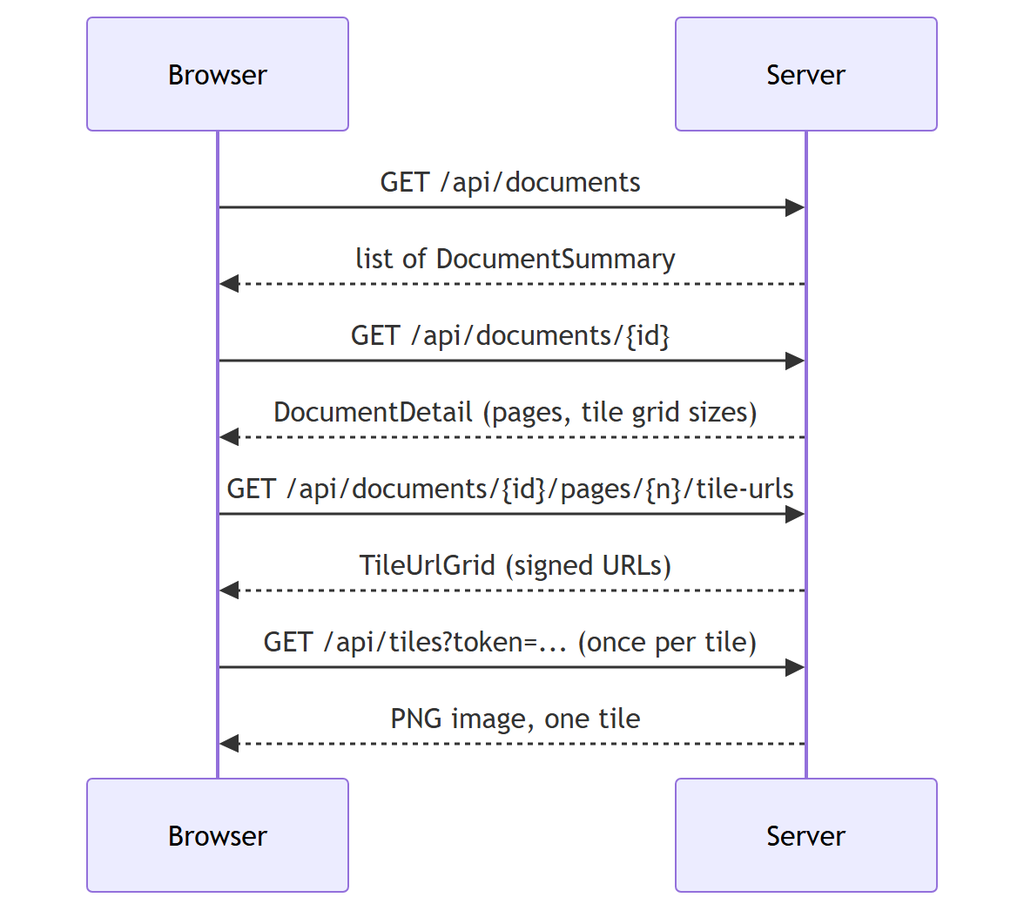

*Figure 12.1 — The requests behind viewing one page*

*Text description:* A sequence between a browser and a server, read from top to bottom. The browser asks for the document list and receives summaries. It asks for one document and receives its detail, with page and tile-grid sizes. It asks for the signed tile URLs of one page and receives a grid of URLs. Finally it asks for each tile with its token and receives one PNG image per request.

1. `GET /api/documents` (`DocumentController.list`): the library. The reader picks a document.
2. `GET /api/documents/{documentId}` (`DocumentController.get`): the `DocumentDetail`, which includes a list of pages, each with its number of tile rows and columns and its pixel size (`PageInfo`).
3. `GET /api/documents/{documentId}/pages/{page}/tile-urls`: a *new* controller, which asks the server to sign one URL per tile of that page.
4. `GET /api/tiles?token=...`, once per tile: the images themselves.

Step 3 is the one worth reading, because it shows how a class can carry *two* path variables and how a controller assembles its answer.

**Listing 12.4 — `PageTileUrlController.java` (`book-m6-final`, simplified: imports, the class comment, and the constructor are omitted)**

```java
@RestController
@RequestMapping("/api/documents/{documentId}/pages/{page}")
public class PageTileUrlController {

    // ... fields and constructor ...

    @GetMapping("/tile-urls")
    public ResponseEntity<TileUrlGrid> tileUrls(
            @PathVariable String documentId,
            @PathVariable int page,
            Authentication authentication,
            HttpServletRequest request) {

        DocumentService.IssuablePage issuable = documents.requirePage(documentId, page,
                Viewer.of(authentication), actors.of(request, authentication));
        PageInfo pageInfo = issuable.info();

        // Tokens carry a keyed binding to this session, never its id, so a
        // tile URL can be logged or leaked without leaking the credential.
        String sessionBinding = sessionKeys.tileBinding(request.getSession().getId());

        String[][] urls = new String[pageInfo.rows()][pageInfo.cols()];
        for (int row = 0; row < pageInfo.rows(); row++) {
            for (int col = 0; col < pageInfo.cols(); col++) {
                String token = signedUrlService.issueToken(documentId, page, row, col, issuable.tileVersion(), sessionBinding);
                urls[row][col] = "/api/tiles?token=" + token;
            }
        }

        return ResponseEntity.ok(new TileUrlGrid(page, pageInfo.rows(), pageInfo.cols(), pageInfo.tileSize(), issuable.tileVersion(), urls));
    }
}
```

*Path: `src/main/java/com/example/securedocviewer/controller/PageTileUrlController.java`*

The class-level path has two variables, `{documentId}` and `{page}`, and both are available to every method. `@PathVariable int page` shows something else: Spring converts the text in the path to the parameter's type, so `/pages/3/` gives the integer 3, and text that isn't a number is refused with `400` (Chapter 13's `MethodArgumentTypeMismatchException`).

The method asks the service whether this caller may view the page (`requirePage` throws a `404` if not, Chapter 16) and computes a session binding. It then builds a two-dimensional array of URLs, one for each `(row, col)`, by asking `SignedUrlService` for a token for each one (Chapter 17). It wraps the array with the grid's size in a `TileUrlGrid` record and returns it with `ResponseEntity.ok(...)`. The result is JSON like `{"page": 0, "rows": 3, "cols": 2, "tileSize": 512, "tileVersion": 1, "tileUrls": [["/api/tiles?token=...", ...], ...]}`, a `String[][]` becoming an array of arrays.

Notice what this controller does *not* do: it never returns a link to the document or a whole page, only individually signed links to single tiles. That's the security design of the whole app, expressed as the shape of one response.

### 12.6 Returning bytes: how `TileController` sends PNGs

Not every response is JSON. The tile endpoint sends an image. Listing 12.5 shows the parts that matter.

**Listing 12.5 — `TileController.java` (`book-m6-final`, simplified: the checks and rendering in the middle of the method are omitted)**

```java
@GetMapping(value = "/api/tiles", produces = MediaType.IMAGE_PNG_VALUE)
public ResponseEntity<byte[]> getTile(@RequestParam String token,
                                      Authentication authentication,
                                      HttpServletRequest request) throws Exception {
    // ... verify the token, session, rate limit and access; render the tile ...

    return ResponseEntity.ok()
            // Deliberately not cacheable beyond a moment — a shared cache
            // holding onto a watermarked-for-someone-else tile would leak it.
            .cacheControl(CacheControl.noStore())
            .body(png);
}
```

*Path: `src/main/java/com/example/securedocviewer/controller/TileController.java`*

`produces = MediaType.IMAGE_PNG_VALUE` declares that this method answers with `image/png`. The return type `ResponseEntity<byte[]>` lets the method control the whole response: the status (`ok()` is 200), the headers (`cacheControl(CacheControl.noStore())` sets `Cache-Control: no-store`) and the body (the PNG bytes, unchanged). Returning `byte[]` skips Jackson, because the bytes are already in their final format.

**ResponseEntity** is worth knowing. When a method returns a plain object, Spring assumes the answer is `200 OK` with default headers. When you need a different status or a header, you return a `ResponseEntity`, which is an object holding all three parts of a response: the status, the headers, and the body. The project returns plain objects when 200 is right (`DocumentController.list`) and `ResponseEntity` whenever it needs more.

The `no-store` header matters for security. Each tile has the viewer's name and a timestamp drawn into it, so no cache, in the browser or at any proxy in between, may keep it and hand it to someone else. There is a reason the content is at the *end* of the method: everything before it (which you'll read in Chapter 17) is a series of checks, and a request that fails any of them never gets a tile.

### 12.7 File uploads (multipart)

A PDF upload can't be JSON: JSON is text, and a PDF is binary. Browsers send files as **multipart form data**: one request whose body is divided into several named parts, each with its own content type, such as a text part called `title` and a file part called `file`. Listing 12.6 is the upload method.

**Listing 12.6 — `DocumentController.upload` (`book-m6-final`)**

```java
@PostMapping
public DocumentDetail upload(@RequestParam(value = "title", required = false) String title,
                             @RequestParam(value = "visibility", required = false) Visibility visibility,
                             @RequestParam("file") MultipartFile file,
                             Authentication authentication,
                             HttpServletRequest request) throws IOException {
    try (var in = file.getInputStream()) {
        return documents.upload(title, file.getOriginalFilename(), in, visibility,
                Viewer.of(authentication), actors.of(request, authentication));
    }
}
```

*Path: `src/main/java/com/example/securedocviewer/controller/DocumentController.java`*

The text parts `title` and `visibility` arrive through `@RequestParam` like query parameters: `required = false` makes them optional, and Spring converts the text `PRIVATE` into the `Visibility` enum, refusing a value that isn't one of its names. The file arrives as a `MultipartFile`. The method doesn't copy the whole file into memory: it takes `file.getInputStream()`, a stream, and passes that to the service. The `try (var in = ...)` closes the stream afterward even if something throws (Chapter 5). Streaming means a 50 MB PDF isn't held as one big array only to be handed on. The size limit is in `application.yml` (`spring.servlet.multipart.max-file-size: 50MB`), and Chapter 13 shows how an oversized upload becomes a clean `413` error.

You can try this endpoint from the command line against your own copy of the app, but a `curl` upload needs three steps: pick up the CSRF (cross-site request forgery) cookie, sign in, and then upload. Example 12.2 shows the sequence. It is a teaching example based on the "API" section of the project's `README.md` at `book-m6-final`, with a placeholder for the password. The browser does all of this for you, and Chapter 16 explains why the app asks for the token.

**Example 12.2 — Signing in and uploading a PDF with `curl` (teaching example)**

```bash
jar=$(mktemp)
xsrf() { awk '$6=="XSRF-TOKEN"{print $7}' "$jar"; }

# 1. Any request receives the XSRF-TOKEN cookie (this one answers 401, which is fine)
curl -s -c "$jar" http://localhost:8080/api/auth/me > /dev/null

# 2. Sign in, sending the cookie jar and echoing the token in a header
curl -s -b "$jar" -c "$jar" -H "X-XSRF-TOKEN: $(xsrf)" \
     -H 'Content-Type: application/json' \
     -d '{"username":"pub.one","password":"<password>"}' \
     http://localhost:8080/api/auth/login

# 3. Upload (read the token again: sign-in replaces it)
curl -s -b "$jar" -H "X-XSRF-TOKEN: $(xsrf)" \
     -F "title=Q3 report" -F "visibility=PRIVATE" -F "file=@report.pdf" \
     http://localhost:8080/api/documents
```

Step 1 works because the server sets the `XSRF-TOKEN` cookie on the first response, even an error. The helper function `xsrf` reads that cookie's value out of the jar file. In step 2, `-c "$jar"` saves the cookies the server sets (the session cookie and a fresh CSRF cookie), `-b "$jar"` sends the cookies you already have, and the header echoes the token, which is the double-submit defense from Chapter 16. Step 3 sends a multipart body: `-F` adds one part, and `file=@report.pdf` means "attach this file." The account must be a `PUBLISHER` or `ADMIN`, because the rule in `SecurityConfig` refuses a reader *before* the body is read. It must also not be waiting to change a temporary password. Until it has done so in the app, every request except the sign-in ones answers `403` with `passwordChangeRequired` (Chapter 16).

## Advanced tier: The contract is part of the design

*You can skip to "In this project" on a first read. Part IV comes back to these decisions.*

### 12.8 Status codes and headers as part of the contract

Clients, including the Angular app in Part III, decide what to do by looking at the status code before they read the body. So a controller's choice of status is a promise, and changing it later breaks callers. Table 12.3 lists the statuses this API uses and where they come from.

Table 12.3 — Status codes used by the API

| Status | When | Comes from |
| --- | --- | --- |
| `200 OK` | Success with a body | Returning an object |
| `201 Created` | An account was created | `UserAdminController.create` returns `ResponseEntity.status(HttpStatus.CREATED)` |
| `204 No Content` | Success, nothing to send back | `DocumentController.delete` returns `ResponseEntity.noContent().build()` |
| `400 Bad Request` | Bad input | Validation and `BadRequestException` (Chapter 13) |
| `401 Unauthorized` | Not signed in, or session ended | Security (Chapter 16) |
| `403 Forbidden` | Signed in but not allowed | Security and `ForbiddenException` |
| `404 Not Found` | No such thing, *or you may not know it exists* | `DocumentNotFoundException` and unknown routes |
| `409 Conflict` | Username already taken | `UsernameTakenException` |
| `410 Gone` | A tile from an older render of a replaced document | `TileGoneException` |
| `413 Content Too Large` | Upload over 50 MB | Multipart limit |
| `429 Too Many Requests` | Rate limit or lockout, with `Retry-After` | `RateLimitExceededException`, `LoginLockedException` |
| `503 Service Unavailable` | Server busy, with `Retry-After` | `ServiceBusyException` |

Two rules stand behind the table. First, **each status has one meaning the client can rely on**: the Angular app treats `429` and `503` as "wait and try again" and reads the `Retry-After` header for how long, while `410` means "reload the page's tiles." Second, **a document you can't see is `404`, never `403`**, so its existence isn't revealed (Chapter 16).

#### A real incident: the endless reload

The viewer answers a `410` by reloading the page's tiles, which is right when the document has been replaced. But a bug made a `410` appear for a different reason, and the viewer reloaded forever. *The problem:* if a tile file was missing on disk for the *current* render (for example after a mismatched restore from backup), the server reported "gone," the viewer reloaded, asked again, got "gone" again, and looped. *How it was found:* by a dry run of the code review that the team performed before the final release. *The fix:* the server now checks whether the document has really moved on to a newer render. Only then does it answer `410`; a missing tile of the *current* render is server damage, so it is a logged, generic `500` that the viewer doesn't retry forever. Listing 12.7 is that decision. **Listing 12.7 — `TileController.loadTile` (`book-m6-final`)**

```java
/**
 * A missing tile means "replaced" (410, the viewer reloads) only if the
 * document really has moved on to a newer render. A missing tile of the
 * current render is damage on the server (e.g. a mismatched restore): that
 * is a 500, never a 410 that would make the viewer reload the same thing forever.
 */
private BufferedImage loadTile(SignedTilePayload payload, TileAccess access, Authentication authentication)
        throws IOException {
    try {
        return tileGenerationService.loadRawTile(
                payload.documentId(), access.tileVersion(), payload.page(), payload.row(), payload.col());
    } catch (TileGoneException gone) {
        int current = documents.tileAccessIfViewable(payload.documentId(), Viewer.of(authentication))
                .map(TileAccess::tileVersion).orElse(-1);
        if (current == access.tileVersion()) {
            throw new IllegalStateException("Tile file missing for the current render of document "
                    + payload.documentId() + " (version " + current + ", page " + payload.page() + ")");
        }
        throw gone;
    }
}
```

*Path: `src/main/java/com/example/securedocviewer/controller/TileController.java`*

Read the comment first; it states the rule. The code catches "the tile file is gone," asks for the *current* version of the document, and compares. If the versions agree, the file is missing although the document hasn't changed, so it throws a plain `IllegalStateException`, which falls to the generic `500` handler from Chapter 13 (logged with a reference, no internals shown). Only if the versions differ does it rethrow the `410`. **The lesson:** a status code that triggers automatic client behavior needs a stop condition on *both* sides; every retry loop must have one.

### 12.9 Small controllers that don't leak

Two more design habits appear in the controllers.

**Limit what a helper endpoint reveals.** `UserDirectoryController` powers the "share with" picker. Its class comment records how it avoids being a directory of accounts: it's restricted to publishers and administrators, returns usernames only, and at most 20 per query. In the code, a search shorter than two characters returns an empty list, matches only enabled accounts, leaves out administrators ("they can already see every document") and leaves out the caller. A convenience endpoint is still an endpoint an attacker can call in a loop, so it returns the minimum.

**Build the audit "who" in one place.** Most methods take `actors.of(request, authentication)`, where `RequestActors` builds the audit record's actor: the username, a short session handle, and the client address. Because every controller calls the same helper, audit rows describe callers consistently, and a controller can't forget half the fields.

### 12.10 Common mistakes

- **Putting rules in the controller.** If the check "may this user open this document?" lives in one controller method, the next endpoint will forget it. Put the rule in the service (Chapter 16 shows `DocumentService`) and keep the controller thin.
- **Returning entities directly.** JPA (Jakarta Persistence) entities such as `Document` (Chapter 14) carry lazy links to other objects and internal fields. The project returns purpose-built records such as `DocumentSummary`, so what the client sees is decided deliberately, and the password hash in `AppUser` can never appear in a response.
- **Using `GET` for actions that change something.** Browsers, caches, and link checkers may repeat a `GET` freely. Anything that changes state uses another method, and, as Chapter 16 explains, changing methods are the ones protected by CSRF tokens.
- **Choosing a status code by feel.** If the client's behavior depends on the code, write down what each one means, as Table 12.3 does.
- **Forgetting the empty case.** A missing optional parameter and a missing body are different situations; use `required = false` or `defaultValue` deliberately.
- **Sending a response that tells too much.** A `500` with an exception message can leak the database layout (Chapter 13). Let the shared handler decide what errors say.

## In this project

Table 12.4 — Controllers in `book-m6-final`

| Controller | Path prefix | Purpose |
| --- | --- | --- |
| `AuthController` | `/api/auth` | Sign in, sign out, current user, password change |
| `DocumentController` | `/api/documents` | Library, upload, replace, rename, share, delete |
| `PageTileUrlController` | `/api/documents/{documentId}/pages/{page}` | Signed tile URLs for one page |
| `TileController` | `/api/tiles` | Watermarked PNG tiles |
| `UserDirectoryController` | `/api/users` | Username search for the share picker |
| `AdminController` | `/api/admin` | Sessions, audit log, rate limits |
| `UserAdminController` | `/api/admin/users` | Account management |

All live in `src/main/java/com/example/securedocviewer/controller/`. The endpoints appear in Part IV as they were added: sign-in in Chapter 26, documents in Chapter 27, the hardened upload in Chapter 28.

## Try it

### Exercise 12.1 ★ Match a request to a method

Which annotation and value make `DocumentController.get` respond to `GET /api/documents/{id}`? What fills the `documentId` parameter?

*Solution:* Appendix C, Exercise 12.1.

### Exercise 12.2 ★ Why `ResponseEntity`?

Find the methods in `DocumentController` that return `ResponseEntity` and explain, for each, why a plain object wouldn't do.

*Hint:* look at what each one returns to the client.

*Solution:* Appendix C, Exercise 12.2.

### Exercise 12.3 ★★ Read the JSON of your own copy

With your own copy of the app running and signed in (Chapter 8's developer tools work well), open the *Network* tab, load the document list, and find the response of `GET /api/documents`. Match each JSON key to a component of `DocumentSummary`. Which values are `null` for a reader, and why?

*Solution:* Appendix C, Exercise 12.3.

### Exercise 12.4 ★★ Rename a component

Suppose you rename `pageCount` to `pages` in `DocumentSummary`. List every place that would need to change on the server and on the client, and explain why the JSON key is a contract.

*Solution:* Appendix C, Exercise 12.4.

### Exercise 12.5 ★★★ Design an endpoint

The project owner asks for "the ten most recently updated documents." Design the endpoint: method, path, query parameters, response record, and status codes. Say which class would hold the rule (who may see which documents) and which would hold the HTTP details, and what you would test.

*Solution:* Appendix C, Exercise 12.5 (a worked outline).

### Exercise 12.6 ★★★ Follow the tile chain

Using a copy of the app and the browser's *Network* tab, open a document, and record the sequence of requests that produce the first page. Compare it with Figure 12.1. Then decode the `token` of one tile URL up to the dot with a base64url decoder (Chapter 17 explains the format) and list the fields you find. Which of them would you not want in a log, and which does the design make safe to leak?

*Solution:* Appendix C, Exercise 12.6 (a worked outline).

## Summary

- REST-style APIs map an HTTP method and a path to an action on a resource; this project bends statelessness for its session cookie and says so.
- `@RestController`, `@GetMapping`, and friends connect requests to methods; `@PathVariable` picks the resource, `@RequestParam` supplies options and `@RequestBody` supplies what to create or change.
- Controllers stay thin: they adapt HTTP, while services own the rules.
- Jackson 3 serializes records to JSON with the component names as keys; timestamps travel as epoch seconds, and `null` carries meaning.
- Viewing one page takes four requests across three controllers, and the response of the third is a grid of individually signed tile URLs.
- `ResponseEntity` gives full control of status, headers, and body, which is how PNG tiles and `204`, `201` and `Retry-After` responses are produced; multipart requests carry files that the service receives as a stream.
- Status codes are a contract: each has one meaning the client relies on, and any code that triggers a retry needs a stop condition.

## Further reading

- *Spring Framework Reference Documentation*, "Annotated Controllers." https://docs.spring.io/spring-framework/reference/web/webmvc/mvc-controller.html
- *Spring Framework Reference Documentation*, "Multipart Resolver." https://docs.spring.io/spring-framework/reference/web/webmvc/mvc-servlet/multipart.html
- Roy T. Fielding, *Architectural Styles and the Design of Network-based Software Architectures*, doctoral dissertation, University of California, Irvine, 2000, Chapter 5, "Representational State Transfer (REST)." https://ics.uci.edu/~fielding/pubs/dissertation/rest_arch_style.htm
- *RFC 9110*, "HTTP Semantics." https://www.rfc-editor.org/rfc/rfc9110

# Chapter 13: Validation, configuration properties, and errors

A server that accepts anything a client sends will eventually be hurt by it. This chapter teaches three habits the Secure Document Viewer applies from milestone 3 onward: check every input, refuse to start with a broken configuration, and answer every failure in one predictable JSON shape that never leaks internals. It ends with the layered limits that keep a hostile upload from taking the server down.

## Learning objectives

By the end of this chapter, you will be able to:

- Explain why a server must validate input that the user interface has already checked.
- Add Bean Validation annotations to a request record and to request parameters, and predict the resulting error.
- Explain how `ViewerProperties` makes the application fail at startup when a secret is missing.
- Describe how `GlobalExceptionHandler` maps exceptions to status codes and one JSON error body, and add a new mapping.
- Explain why the catch-all handler returns a reference code rather than the exception message.
- Name the layers of limits on an upload and the order in which they apply.

## Prerequisites

- Chapter 5: exceptions
- Chapter 11: Spring Boot foundations (beans, `application.yml`)
- Chapter 12: REST controllers and JSON

**A note on versions.** Most listings in this chapter are quoted at `book-m3-hardening` (Spring Boot 3.3.4, Java 21), where these features were added. Listings 13.1 and 13.2, the paging snippet, the two short excerpts in Section 13.5 and Listings 13.6 and 13.7 come from `book-m6-final` (Spring Boot 4.1.1, Java 25). At `book-m6-final`, `ViewerProperties` has more settings and different defaults (for example `tileRateLimitPerWindow` is 180, not 120), and `GlobalExceptionHandler` has extra handlers, but the parts quoted here are unchanged. One name changed with Spring 7: the constant for status 413 is `HttpStatus.PAYLOAD_TOO_LARGE` in the m3 code and `HttpStatus.CONTENT_TOO_LARGE` at `book-m6-final`; the status is the same.

Five terms are used here and explained where they appear:

- **Accept header:** the request header naming the content types the caller can receive (Chapter 8).
- **Stack trace:** the list of method calls at the moment of an exception (Chapter 3).
- **Log:** the server's running record of events (Chapter 11).
- **Retry-After:** a response header telling the client how many seconds to wait (Chapter 12).
- **UUID:** a randomly generated identifier, used here only to make a short reference code.

## Beginner tier: Never trust input

### 13.1 Never trust input

Picture a bank teller who checks that a deposit slip is filled in, but never looks at the check itself. The form is not the security; the teller's check is. The Angular app also checks what users type, so a mistake gets a friendly message immediately. But anyone can skip the app and send requests directly with a script, and the browser's checks are only code running on the user's machine, which the user controls. So the server must treat every request as untrusted, however it arrived.

**Where the analogy breaks down:** a teller sees the customer and can judge them. A server never does. It sees only bytes, and it must decide from the bytes alone.

Input arrives in every place Chapter 12 listed: the path, the query string, the body, the headers, and uploaded files. Each is a place a client can put something you didn't expect. Some examples the project's checks exist for:

- A username 10 MB long, which would be read into memory and then stored.
- A page size of `-1` or `1000000`, meant to make the admin screen load the whole audit table.
- A `type` filter that isn't one of the known event names.
- A password of 30 emoji (Chapter 15), which a hashing library refuses.
- A "PDF" that is really something else, or a real PDF built to be enormous once drawn (Section 13.9).

Validation has two jobs. It **protects the system**: a bad value never reaches the database or an expensive operation. And it **helps the caller**: an error message that says what to fix. The rest of the chapter is about doing both consistently.

### 13.2 Bean Validation annotations

**Bean Validation** is a standard set of annotations that state rules directly on the data, so the rule sits next to the thing it protects. Table 13.1 lists the ones the project uses.

Table 13.1 — Bean Validation annotations used in the project

| Annotation | Rule | Where |
| --- | --- | --- |
| `@NotBlank` | Not `null`, not empty, not only spaces | Sign-in and account requests |
| `@NotNull` | Not `null` | The `role` of a new account |
| `@Size(max = 64)` | Text length at most 64 (`min` also works) | Usernames, audit filters |
| `@Min(0)`, `@Max(500)` | A number's lower and upper bound | Paging of the audit log |

Spring runs the rules for you when a method parameter is marked `@Valid`. Listing 13.1 is the sign-in request.

**Listing 13.1 — The sign-in request record in `AuthController.java` (`book-m6-final`, simplified: only the record and the start of the method)**

```java
public record LoginRequest(@NotBlank @Size(max = 64) String username,
                           @NotBlank @Size(max = 128) String password) {
}

// ...

@PostMapping("/login")
public ResponseEntity<CurrentUser> login(@Valid @RequestBody LoginRequest body,
                                         HttpServletRequest request,
                                         HttpServletResponse response) {
```

*Path: `src/main/java/com/example/securedocviewer/controller/AuthController.java`*

Read the record first: a sign-in must have a username of 1 to 64 characters that isn't blank, and a password up to 128 characters that isn't blank. `@Valid` on the parameter tells Spring: "before you call this method, check the rules on this object." If a rule fails, the method is never called. That's the protection: the body of `login` can assume it has non-blank, bounded text.

**A worked example.** A script sends `POST /api/auth/login` with the body `{"username": "", "password": "x"}`. The steps:

1. Jackson builds a `LoginRequest` with an empty `username` (Chapter 12).
2. Because of `@Valid`, Spring validates it. `@NotBlank` on `username` fails.
3. Spring throws `MethodArgumentNotValidException` *instead of* calling `login`.
4. `GlobalExceptionHandler` (Section 13.5) catches it, takes the first field error, and answers `400 Bad Request` with `{"error": "username: must not be blank"}`. The words `must not be blank` are the standard message of `@NotBlank`; you can replace it with `@NotBlank(message = "...")`, as `ViewerProperties` does in Section 13.4.

The caller learns what to fix, and the sign-in code, the throttle and the audit log never see the request.

### 13.3 Rules on single parameters

Bodies aren't the only input. `AdminController.audit` restricts its paging parameters directly on the method:

```java
@RequestParam(defaultValue = "0") @Min(0) int page,
@RequestParam(defaultValue = "50") @Min(1) @Max(500) int size
```

(`book-m6-final`, `AdminController.java`, excerpt.) A caller can't ask for a page size of a million rows, which would otherwise load the audit table into memory. The rule sits in the signature, where a reader of the code sees it. A failure here raises a different exception, `HandlerMethodValidationException`, because Spring validates method parameters through a different path than request bodies.

There are, in fact, three related exception types. `MethodArgumentNotValidException` is for a validated request body. `HandlerMethodValidationException` is for rules on individual parameters like `page` and `size` in the audit endpoint. Jakarta's `ConstraintViolationException` is for rules checked elsewhere in the code. The handler class has one method for each, and they all answer with the same `400` shape, so a client never has to know which mechanism caught the problem.

The project's own tests show the whole set of cases. This one is real:

**Listing 13.2 — `SecurityIntegrationTest.java` (`book-m6-final`, excerpt: test `auditLimitIsValidated`; the test administrator's password is replaced by the placeholder `<test-admin-password>`, as this book never prints secret values)**

```java
@Test
void auditLimitIsValidated() throws Exception {
    MockHttpSession admin = login("admin", "<test-admin-password>");
    mvc.perform(get("/api/admin/audit").param("size", "0").session(admin)).andExpect(status().isBadRequest());
    mvc.perform(get("/api/admin/audit").param("size", "501").session(admin)).andExpect(status().isBadRequest());
    mvc.perform(get("/api/admin/audit").param("page", "-1").session(admin)).andExpect(status().isBadRequest());
    mvc.perform(get("/api/admin/audit").param("type", "NOT_A_TYPE").session(admin))
            .andExpect(status().isBadRequest());
    mvc.perform(get("/api/admin/audit").param("size", "10").session(admin)).andExpect(status().isOk());
}
```

*Path: `src/test/java/com/example/securedocviewer/security/SecurityIntegrationTest.java`*

The four refused cases are the boundaries: one below the minimum size, one above the maximum, a negative page, and a value that isn't in the enum. The last line is the control: a valid request still succeeds. A test that only checked refusals would pass for a server that refused everything. Note also the last refused case, `type=NOT_A_TYPE`: there is no annotation for it. Spring can't convert the text into the `AuditEventType` enum, raises a conversion error, and the handler in Section 13.5 answers `400` with `Invalid value for 'type'.`

## Intermediate tier: Failing early and speaking one language

*If you're reading for the first time, Sections 13.4 and 13.5 are the important ones here; 13.6 is a short bridge between the layers.*

### 13.4 Typed configuration (`ViewerProperties`) that fails fast

Chapter 11 showed the `secure-doc-viewer:` block of `application.yml`. `ViewerProperties` is the Java class that receives it. Listing 13.3 shows the parts that matter.

*Pattern note: Reading settings from the environment is twelve-factor configuration (Chapter 39, Section 39.12).*

**Listing 13.3 — `ViewerProperties.java` (`book-m3-hardening`, simplified: the other settings and all getters and setters are omitted)**

```java
@Component
@ConfigurationProperties(prefix = "secure-doc-viewer")
@Validated
public class ViewerProperties {

    private String storageRoot = "./storage";
    // ...
    /**
     * HMAC key for tile tokens and session-derived values. Supplied via the
     * SIGNING_SECRET environment variable; startup fails if it is missing or
     * too short to be a real key, rather than failing on the first tile.
     */
    @NotBlank(message = "SIGNING_SECRET must be set")
    @Size(min = 32, message = "SIGNING_SECRET must be at least 32 characters")
    private String signingSecret;
    // ...
}
```

*Path: `src/main/java/com/example/securedocviewer/config/ViewerProperties.java`*

`@ConfigurationProperties(prefix = "secure-doc-viewer")` tells Spring to copy each key under that prefix into the matching field. `storage-root` in the file becomes `storageRoot` in Java: Spring matches the two spellings (this is called **relaxed binding**), so YAML can use dashes while Java uses camel case. Defaults such as `"./storage"` apply when a key is absent. Types are converted for you: the file says `render-timeout: 3m` and `session-max-lifetime: 12h`, and the corresponding fields at `book-m6-final` are `Duration` objects, so a value that isn't a valid duration stops startup instead of silently becoming zero.

`@Validated` switches on the same Bean Validation rules from Section 13.2. So a missing or short `signingSecret` stops the program during startup, with the message you wrote in the annotation. The signing secret matters more than any other value here: it is the key that signs every tile URL (Chapter 17), so a blank or guessable one would let anyone forge links. The project's `application.yml` reads it from an environment variable, `signing-secret: ${SIGNING_SECRET:}`, with an *empty* default on purpose, so forgetting it is an error rather than a hidden weak default. The source comment states the intent: "startup fails if it is missing or too short to be a real key, rather than failing on the first tile."

Compare with reading each value by hand using `@Value("${...}")`, which the project still does for a few single settings (`BootstrapAdmin` reads two). A typed class gives you a name, a type, a default, and a rule in one place, and IDEs can autocomplete and check the names. It also fails early. A server that started without a signing secret would discover the problem only when it tried to sign its first tile URL, in front of a real user. The habit is worth copying: **make the program refuse to start rather than misbehave later.**

One subtlety. The rules apply when *Spring* fills the object from configuration. A unit test that writes `new ViewerProperties()` and calls setters skips validation entirely (Chapter 18 points out the trap). That's why the integration tests, which start the whole application, matter for configuration.

### 13.5 One JSON error shape: `GlobalExceptionHandler`

When something goes wrong, a client needs to know two things: the status code, and a message it can show. If every endpoint invented its own format, the Angular app would need many code paths. The project uses one: `{"error": "message"}`.

Java signals a failure by throwing an exception (Chapter 5). Spring lets you write a class of **exception handlers**, methods that catch a given exception type anywhere in the controllers and turn it into a response. The class is marked `@RestControllerAdvice`, and each method is marked `@ExceptionHandler`. Figure 13.1 shows the route an error takes from the moment something throws to the JSON the client receives.

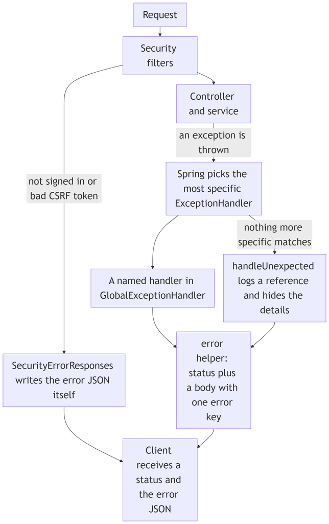

*Figure 13.1 — The path of an error from a thrown exception to the JSON body*

*Text description:* A top-down flow that starts with a request passing the security filters. From there two roads lead to a status and JSON error body. A filter failure (not signed in, a bad cross-site request forgery (CSRF) token) is written directly by `SecurityErrorResponses`. A failure in a controller or service throws an exception, Spring picks the most specific handler, and the catch-all handler is used only when nothing more specific matches.

Notice the two roads into the same JSON. Failures raised inside a controller or service travel down the middle of the figure: Spring chooses the handler whose exception type is the closest match, and the catch-all `Exception` handler is only the last resort. Failures raised earlier, in the security filters, never reach the handler class at all, so `SecurityErrorResponses` writes the same shape by hand (Section 13.6). Both roads end at a status and a body with one `error` key, which is why the browser app needs only one way to read a failure.

**Listing 13.4 — `GlobalExceptionHandler.java` (`book-m3-hardening`, simplified: imports and most handlers omitted)**

```java
@RestControllerAdvice
public class GlobalExceptionHandler {

    @ExceptionHandler(BadCredentialsException.class)
    public ResponseEntity<Map<String, String>> handleBadCredentials(BadCredentialsException e) {
        return error(HttpStatus.UNAUTHORIZED, "Invalid username or password.");
    }

    @ExceptionHandler({DocumentNotFoundException.class, ResourceNotFoundException.class})
    public ResponseEntity<Map<String, String>> handleNotFound(RuntimeException e) {
        return error(HttpStatus.NOT_FOUND, e.getMessage());
    }

    // ... more handlers ...

    private static ResponseEntity<Map<String, String>> error(HttpStatus status, String message) {
        return ResponseEntity.status(status)
                .contentType(MediaType.APPLICATION_JSON)
                .body(Map.of("error", message));
    }
}
```

*Path: `src/main/java/com/example/securedocviewer/controller/GlobalExceptionHandler.java`*

Each `@ExceptionHandler` names the exception types it catches. The second handler shows that one method can serve several types, and that it can use the exception's own message (`e.getMessage()`) when that message is safe to show. The helper at the bottom is where the shape is defined, once. It builds a response with the given status, an explicitly set JSON content type (the reason is the incident in Section 13.7), and a body that is a one-entry map, which Jackson writes as `{"error": "..."}`.

The project defines its own small exception classes, and their comments say what they mean. `BadRequestException` is "a request that is well-formed HTTP but breaks a business rule; mapped to 400." `LoginLockedException` is "Too many failed sign-ins; mapped to 429 with Retry-After." A service throws the one that fits. Here is a real one, from the document service:

```java
private static String validTitle(String title) {
    String trimmed = title == null ? "" : title.trim();
    if (trimmed.isEmpty() || trimmed.length() > MAX_TITLE_LENGTH) {
        throw new BadRequestException("Title must be 1-" + MAX_TITLE_LENGTH + " characters.");
    }
    return trimmed;
}
```

(`book-m6-final`, `DocumentService.java`.) This is validation the annotations can't do, because it depends on a rule that includes trimming. It throws `BadRequestException` with a message meant for the user, and the handler decides the rest. The service knows *what went wrong*; the handler decides *how HTTP says so*. Keeping HTTP details out of business code means a service can be called from a test, a scheduled job, or another service without a web server in sight.

Table 13.2 — A sample of the mapping (`GlobalExceptionHandler`)

| Exception | Status |
| --- | --- |
| `MethodArgumentNotValidException`, `HandlerMethodValidationException`, `ConstraintViolationException` | 400 |
| `HttpMessageNotReadableException` (body missing or malformed) | 400 |
| `MissingServletRequestParameterException`, `MissingServletRequestPartException`, `MissingRequestHeaderException` | 400 |
| `MethodArgumentTypeMismatchException` (wrong type, such as text for a number) | 400 |
| `BadCredentialsException`, `InvalidTokenException` | 401 |
| `ForbiddenException` | 403 |
| `DocumentNotFoundException`, `ResourceNotFoundException`, unknown route | 404 |
| `HttpRequestMethodNotSupportedException` | 405 |
| `UsernameTakenException` | 409 |
| `MaxUploadSizeExceededException` | 413 |
| `RateLimitExceededException`, `LoginLockedException` | 429 with `Retry-After` |
| any other `Exception` | 500 |

A validation handler picks only the first error. This is the real one for request bodies:

```java
@ExceptionHandler(MethodArgumentNotValidException.class)
public ResponseEntity<Map<String, String>> handleInvalidBody(MethodArgumentNotValidException e) {
    String message = e.getBindingResult().getFieldErrors().stream()
            .findFirst()
            .map(fieldError -> fieldError.getField() + ": " + fieldError.getDefaultMessage())
            .orElse("Invalid request.");
    return error(HttpStatus.BAD_REQUEST, message);
}
```

(`book-m6-final`, `GlobalExceptionHandler.java`, excerpt.) It builds the message `username: must not be blank` from the field name and the annotation's message, and returns only the first, so the client gets one clear sentence to fix at a time. `Optional`'s `orElse` supplies a fallback for the odd case with no field error.

**Adding a mapping is a three-step habit.** To add "409 when a document title already exists," you write a small exception class, throw it from the service where the rule is decided, and add one `@ExceptionHandler` method that calls `error(HttpStatus.CONFLICT, e.getMessage())`. No controller changes. Exercise 13.3 asks you to do it.

### 13.6 Errors raised before a controller runs

The advice class only sees exceptions thrown while a controller is handling a request. Failures inside the security filter chain (not signed in, or a missing CSRF token, the guard against forged requests that Chapter 16 explains) happen earlier, so the advice never sees them. `SecurityErrorResponses` writes the same `{"error": ...}` JSON itself, so a caller gets one shape whether the failure came from a controller or a filter (Chapter 16). It's a good example of a rule that had to be applied twice, in two places, because the framework has two paths.

## Advanced tier: Not leaking, and setting limits

*You can skip to "In this project" on a first read; Part IV's Chapter 28 tells how the hardening milestone added these.*

### 13.7 Not leaking internals (generic 500 with a reference)

A helpful error message can be dangerous. An unhandled exception might say `SELECT * FROM ... WHERE path='C:/internal'`, which tells an attacker the database, table, and file layout. Listing 13.5 is the last-resort handler.

**Listing 13.5 — The catch-all handler (`book-m3-hardening`)**

```java
/** Last resort: never leak internals, but make the failure traceable in the log. */
@ExceptionHandler(Exception.class)
public ResponseEntity<Map<String, String>> handleUnexpected(Exception e) {
    String reference = UUID.randomUUID().toString().substring(0, 8);
    log.error("Unhandled error, reference {}", reference, e);
    return error(HttpStatus.INTERNAL_SERVER_ERROR,
            "Something went wrong on our side. Reference: " + reference + ".");
}
```

*Path: `src/main/java/com/example/securedocviewer/controller/GlobalExceptionHandler.java`*

`Exception` is the parent of every exception, so this handler catches whatever the more specific handlers didn't; Spring picks the most specific match. The client gets a generic sentence and an eight-character reference made from a random UUID. The full exception, with its stack trace, goes to the server log next to the same reference (`log.error(..., reference, e)`). When a user reports "reference 3f9a1c22," an operator searches the log for it and finds exactly what happened. Nothing sensitive crosses the network, and the failure is still traceable.

`ErrorContractTest` proves this. It adds a controller that throws an exception whose message contains a fake SQL statement and a file path, calls it, and asserts that the response is `500`, starts with `Something went wrong on our side. Reference:`, and contains neither the SQL nor the path (Chapter 18, Listing 18.5). The test's fake secrets are on purpose: it checks by content, not only by status.

#### A real incident: the handler that failed on images

The class comment of `GlobalExceptionHandler` records a subtle bug. *The problem:* on the tile endpoint, which answers with PNG images, a clean `401` or `429` turned into a `500`. *How it was found:* during the first manual test pass of the running app in a browser, before the hardening milestone, and fixed then (it was already fixed at `book-m1-accounts`). *The cause:* Spring negotiates the content type of a response body against the request's `Accept` header, which lists what the caller is willing to receive. The tile endpoint's callers may accept *only images*, so a JSON error body was "not acceptable," the error handler itself failed, and the failure of the failure was a `500`. *The fix:* the `error(...)` helper always sets `MediaType.APPLICATION_JSON` explicitly, as in Listing 13.4. *The lesson:* error paths are code too, and they need tests as much as success paths do.

### 13.8 Do not trust a message you will show

Two smaller rules follow from the same idea. First, decide which exceptions carry messages meant for users. `BadRequestException` and friends are written with user-facing text, so their handlers show `e.getMessage()`. Anything else goes to the generic 500. Second, remember that some messages include a value the caller sent. Most of the project's messages are fixed text (`"Invalid username or password."`) or a field name (`"Missing required 'token'."`), but a few echo a name back, such as `"No user named '<name>'."`. The server returns these inside a JSON string with an explicit content type, so they are never interpreted as markup. But any client that displays an error message must treat it as plain text and never insert it into a page as HTML. Angular's templates escape text by default (Part III), which is the behavior you want.

### 13.9 Limits: upload size, page count, decompression bombs

Validation isn't only about shape; it's about *size and cost*. A PDF can be small on disk and enormous once drawn: a **decompression bomb**, a file crafted to expand into something that exhausts memory or time. So the project sets limits in layers, cheapest first, and each layer rejects with an ordinary error. The last layers deal with **concurrency**: several things happening at overlapping times, for example many requests handled by many threads.

Table 13.3 — The layers of upload limits (`book-m6-final`)

| Order | Limit | Where set | Result |
| --- | --- | --- | --- |
| 1 | Role: only publishers and administrators may upload | `SecurityConfig` | `403`, before the body is read |
| 2 | File size at most 50 MB | `spring.servlet.multipart.max-file-size` | `413` |
| 3 | Upload is streamed to a temporary file, never held in memory | `TileGenerationService.render` | (protects memory) |
| 4 | The file must start with `%PDF-` | `requirePdfSignature` | `400` |
| 5 | The PDF must open, have pages, and at most `max-pages` (500) | `requireWithinLimits` | `400` |
| 6 | Each rendered page at most `max-page-pixels` (40,000,000) | `requireWithinLimits` | `400` |
| 7 | At most `max-concurrent-renders` (2) at a time; others wait up to 30 seconds | `acquireRenderPermit` | `503` with `Retry-After` |
| 8 | A render longer than `render-timeout` (3 minutes) is abandoned | `render` | `400` |

Two of these are worth reading in code. The signature check is the first look inside the file:

**Listing 13.6 — `TileGenerationService.requirePdfSignature` (`book-m6-final`)**

```java
/** Cheap first check: real PDFs start with "%PDF-" (a few writers prepend junk, so allow 1 KB). */
private static void requirePdfSignature(Path file) throws IOException {
    byte[] head = new byte[1024];
    int read;
    try (InputStream in = Files.newInputStream(file)) {
        read = in.readNBytes(head, 0, head.length);
    }
    if (!new String(head, 0, read, StandardCharsets.ISO_8859_1).contains("%PDF-")) {
        throw new BadRequestException("The file is not a readable PDF.");
    }
}
```

*Path: `src/main/java/com/example/securedocviewer/service/TileGenerationService.java`*

It reads only the first kilobyte of the file and looks for the marker `%PDF-`. Nothing is trusted about the *filename* or the declared content type, which the client chooses; the file's own first bytes are what count. The check is cheap, so it goes first, and it doesn't prove the file is a good PDF; the next layers do more.

And the size-and-cost check:

**Listing 13.7 — `TileGenerationService.requireWithinLimits` (`book-m6-final`)**

```java
private void requireWithinLimits(PDDocument document) {
    int pageCount = document.getNumberOfPages();
    if (pageCount == 0) {
        throw new BadRequestException("The PDF has no pages.");
    }
    if (pageCount > properties.getMaxPages()) {
        throw new BadRequestException("The PDF has " + pageCount + " pages; the limit is "
                + properties.getMaxPages() + ".");
    }
    double scale = properties.getRenderDpi() / 72.0;
    for (int i = 0; i < pageCount; i++) {
        PDPage page = document.getPage(i);
        PDRectangle box = page.getCropBox();
        boolean rotated = page.getRotation() % 180 != 0;
        double width = (rotated ? box.getHeight() : box.getWidth()) * scale;
        double height = (rotated ? box.getWidth() : box.getHeight()) * scale;
        if (width * height > properties.getMaxPagePixels()) {
            throw new BadRequestException("Page " + (i + 1) + " is too large to render ("
                    + Math.round(width) + "x" + Math.round(height) + " px).");
        }
    }
}
```

*Path: `src/main/java/com/example/securedocviewer/service/TileGenerationService.java`*

This is the decompression-bomb defense. A PDF page has a size in points (72 to an inch), so the code can compute the *pixel size it would render to* (`scale = dpi / 72`) *without rendering it*, and compare the area with the limit. It even accounts for a page rotated by 90 degrees, which swaps width and height. A poster-sized page at 150 DPI (dots per inch) is refused up front with a message naming the page. The comments on the settings in `ViewerProperties` say the same: the limit is on the "Largest rendered page allowed (width x height at render DPI); stops decompression-bomb PDFs."

**The incident behind the layers.** The first version of the upload read the whole file into memory, had no limits and rendered synchronously, so one large or hostile file could take the server down. The AI technical-manager reviewer (Chapter 32 explains how the reviews worked) found it. The fix arrived in stages, each tied to a review round. Streaming to a temporary file, the `%PDF-` check, the page and pixel limits, and the `413` for oversized files came first. A cap of two concurrent renders (with `503` and `Retry-After`) followed. A *time* limit came last, after a review round asked what happens if a pathological PDF holds one of two render slots forever. The lesson is that limits come in several dimensions (size, count, area, concurrency, and time), and each protects a different resource.

Every limit here is a setting, not a constant. `application.yml` documents them, and the frontend has its own size check, so the user sees a refusal before waiting for a long upload. The comments in the file say to keep the three in step: the multipart limit, `GlobalExceptionHandler.MAX_UPLOAD_MB`, and the frontend.

### 13.10 Common mistakes

- **Trusting the interface's checks.** The browser's validation is a courtesy. The server's is the rule.
- **Validating only the shape.** A field can be the right type and still be a hundred megabytes. Bound sizes, counts, and ranges.
- **Returning the exception's message from an unexpected error.** It can contain SQL, file paths or secrets. Use a generic message and a log reference.
- **Different error shapes in different places.** The client must handle each one. One helper builds them all, including the ones written by the security filters.
- **Forgetting the content type of an error.** An error body without an explicit content type can fail in negotiation (Section 13.7).
- **Checking a limit after doing the expensive work.** Order the checks cheapest first: the role, the size, the signature, then the rendering.
- **Testing only the refusals.** Also test that a valid request passes, as in Listing 13.2.
- **Having a default for a secret.** A default signing key means a deployment that forgot to set one is silently insecure. Leave it empty and validate.

## In this project

Table 13.4 — Where Chapter 13's ideas live

| Idea | File | Tag |
| --- | --- | --- |
| Request validation | `controller/AuthController.java`, `controller/AdminController.java` | `book-m6-final` |
| Typed, validated settings | `config/ViewerProperties.java` | `book-m3-hardening` |
| Error mapping | `controller/GlobalExceptionHandler.java` | `book-m3-hardening` |
| Filter-chain errors | `security/SecurityErrorResponses.java` | `book-m6-final` |
| Error contract test | `src/test/.../controller/ErrorContractTest.java` | `book-m3-hardening` |
| Upload limits | `service/TileGenerationService.java`, `src/main/resources/application.yml` | `book-m6-final` |

## Try it

### Exercise 13.1 ★ Which rule stops a long username?

Which annotations stop a sign-in request whose username is 200 characters long, and what status and message does the client see? Check by reading Listing 13.1 and `GlobalExceptionHandler`.

*Solution:* Appendix C, Exercise 13.1.

### Exercise 13.2 ★ The reference code

What JSON does the server return for an unexpected exception? Which parts are safe to show a user, and where does the rest go?

*Solution:* Appendix C, Exercise 13.2.

### Exercise 13.3 ★★ Add an exception and a mapping

On your own branch, add a `ConflictException` and map it to `409` in the handler. Write a `MockMvc` test with a small test-only controller, like `ErrorContractTest`'s, that throws it, and check the status and the JSON. Where does the message text come from?

*Solution:* Appendix C, Exercise 13.3.

### Exercise 13.4 ★★ Start without the secret

On your own copy, unset `SIGNING_SECRET` (and check that a `.env` file isn't supplying it, because the project imports `.env` as a fallback) and start the application. Read the error. Which line of `ViewerProperties` produced it? Then set a 10-character value and start again, and compare the message.

*Solution:* Appendix C, Exercise 13.4.

### Exercise 13.5 ★★★ Design the limits

You are adding an image upload for user avatars, at most 2 MB. List the layers of limits you'd apply, in order, and for each say what status it returns and what resource it protects. Which of the project's PDF limits have no equivalent for a small image, and which are still needed?

*Solution:* Appendix C, Exercise 13.5 (a worked outline).

### Exercise 13.6 ★★★ Why three places?

The upload limit appears in `application.yml`, in `GlobalExceptionHandler.MAX_UPLOAD_MB`, and in the frontend. Explain what a user experiences if the frontend allows 100 MB while the server allows 50 MB, and propose a way to keep the three values from drifting apart.

*Solution:* Appendix C, Exercise 13.6 (a worked outline).

## Summary

- The server validates every input, whatever the UI already checked; validation protects the system and helps the caller.
- Bean Validation annotations (`@NotBlank`, `@Size`, `@Min`, `@Max`) plus `@Valid` state the rules next to the data; three related exception types cover bodies, parameters, and other checks, and all answer `400`.
- `@ConfigurationProperties` with `@Validated` turns configuration into a typed class and stops startup when a required value is wrong.
- `@RestControllerAdvice` maps exceptions to status codes and one `{"error": ...}` body, always with an explicit JSON content type; services throw meaning, and the handler decides the status.
- Unexpected errors return a generic message and a reference; details stay in the log.
- Upload limits come in layers (role, size, signature, page count, page area, concurrency, time), checked cheapest first, so a hostile file is refused before it can cost much.

## Further reading

- *Spring Framework Reference Documentation*, "Validation, Data Binding, and Type Conversion." https://docs.spring.io/spring-framework/reference/core/validation.html
- *Spring Boot Reference Documentation*, "Type-safe Configuration Properties." https://docs.spring.io/spring-boot/reference/features/external-config.html#features.external-config.typesafe-configuration-properties
- *Spring Framework Reference Documentation*, "Error Responses." https://docs.spring.io/spring-framework/reference/web/webmvc/mvc-ann-rest-exceptions.html
- *OWASP Cheat Sheet Series*, "Input Validation Cheat Sheet." https://cheatsheetseries.owasp.org/cheatsheets/Input_Validation_Cheat_Sheet.html
- *OWASP Cheat Sheet Series*, "File Upload Cheat Sheet." https://cheatsheetseries.owasp.org/cheatsheets/File_Upload_Cheat_Sheet.html

# Chapter 14: Storing data with JPA and Flyway

The Secure Document Viewer keeps accounts, documents, shares, and an audit trail in MySQL. This chapter shows how Java objects map to database tables and how the schema is created and changed safely. It then covers how transactions keep changes all-or-nothing, how a row lock stops two people from replacing the same PDF at once, and how timed cleanup jobs run. It also tells the real bugs that taught the project these lessons: audit rows that vanished, and timestamps that came out in the wrong time zone.

## Learning objectives

By the end of this chapter, you will be able to:

- Explain the mismatch between objects and tables and how an object-relational mapper (ORM) bridges it.
- Read an entity class and a Spring Data repository interface, including a query method whose name is a small sentence.
- Explain what a transaction is, and compare `@Transactional` with `TransactionTemplate`.
- Read a Flyway migration and explain why the schema is versioned SQL files, never edited after they run.
- Explain a row lock, and when `REQUIRES_NEW` is needed.
- Describe how `@Scheduled` runs the project's cleanup sweeps.
- Explain why tests use both H2 and a real MySQL, and why the project stores time in UTC (Coordinated Universal Time).

## Prerequisites

- Chapter 4: classes, objects, records
- Chapter 9: SQL and MySQL (tables, rows, keys, foreign keys)
- Chapter 11: Spring Boot foundations (beans, configuration)
- Chapter 12: REST controllers and JSON (why entities aren't returned directly)

**A note on versions.** The chapter belongs to milestones 1 and 2, but the entity and service listings are quoted from `book-m6-final`, where they're complete. The first two migrations are identical at `book-m2-documents` and `book-m6-final`; the third migration was added in milestone 5 (`book-m5-platform`).

## Beginner tier: Objects on one side, tables on the other

### 14.1 Objects and tables: the mismatch

Java code works with objects that hold other objects: a `Document` has an owner, a list of pages and a set of users it's shared with. A database holds flat tables of rows, linked by numbers called foreign keys. Imagine two ways of describing the same library. One is a set of index cards: each card is a book, and a colored sticker on it says which shelf it belongs to. The other is a set of rooms, where each room contains its shelves and each shelf contains its books. Java is the rooms, and SQL is the index cards. Translating between them by hand means writing SQL for every save and load and copying columns into fields, hundreds of times.

An **ORM** (object-relational mapper) does the translation from declarations you write once. The standard Java specification is **JPA** (Jakarta Persistence). **Hibernate** is the implementation the project uses (Hibernate 7 with Spring Boot 4). **Spring Data JPA** sits on top and writes the common queries for you.

**Where the analogy breaks down:** an ORM feels like a translator who makes the database disappear. It doesn't. Every property you map costs a column, and a careless mapping can run hundreds of queries behind one innocent line of Java. You still need to read the SQL it produces (Chapter 9), and this chapter points out the two places where the project has to be careful: lazy loading and transactions.

### 14.2 Entities and repositories

An **entity** is a class mapped to a table. Listing 14.1 is the account entity.

*Pattern note: A repository hides how objects are stored behind a collection-like interface (Chapter 38, Section 38.2).*

**Listing 14.1 — `AppUser.java` (`book-m6-final`, simplified: getters and setters after the constructors, and two columns, are omitted)**

```java
@Entity
@Table(name = "app_user")
public class AppUser {

    @Id
    @GeneratedValue(strategy = GenerationType.IDENTITY)
    private Long id;

    @Column(nullable = false, unique = true, length = 64)
    private String username;

    @Column(name = "password_hash", nullable = false, length = 100)
    private String passwordHash;

    @Enumerated(EnumType.STRING)
    @Column(nullable = false, length = 20)
    private Role role;

    @Column(nullable = false)
    private boolean enabled = true;

    @Column(name = "created_at", nullable = false)
    private Instant createdAt;

    // ... must_change_password and last_sign_in_at columns omitted ...

    protected AppUser() {
    }

    public AppUser(String username, String passwordHash, Role role) {
        this.username = username;
        this.passwordHash = passwordHash;
        this.role = role;
        this.createdAt = Instant.now();
    }
```

*Path: `src/main/java/com/example/securedocviewer/account/AppUser.java`*

Line by line:

- `@Entity` says "this class is stored in the database," and `@Table(name = "app_user")` names the table. Without `@Table`, Hibernate would guess a name from the class.
- `@Id` marks the primary key, the column that identifies a row. `@GeneratedValue(strategy = GenerationType.IDENTITY)` lets MySQL generate the value (`AUTO_INCREMENT`) when the row is inserted.
- `@Column` maps a field to a column and repeats constraints: `nullable = false` becomes `NOT NULL`, `unique = true` becomes a unique constraint, and `length = 64` is the `VARCHAR` size. The migration in Section 14.5 is where the schema is really defined; these declarations describe it to Hibernate, and mismatches show up as errors when the application runs.
- `@Enumerated(EnumType.STRING)` stores the role as the text `READER`, `PUBLISHER` or `ADMIN`. The alternative, the default, stores the *position* of the name in the enum: `READER` is 0, `PUBLISHER` is 1. Then reordering the enum, or inserting a new role in the middle, silently changes what every stored row means. Storing the name is safer and readable in the database.
- `Instant` is Java's type for a moment in time (Chapter 5). The project maps it to `DATETIME(6)`, and Section 14.9 explains how it's kept in UTC.
- The two constructors: the `protected` one with no parameters exists for Hibernate, which creates entities by calling it and then filling the fields. Your code uses the public one, which forces a caller to supply the required values.

A repository is an interface through which you load and save entities. You write no implementation.

**Listing 14.2 — `AppUserRepository.java` (`book-m6-final`)**

```java
public interface AppUserRepository extends JpaRepository<AppUser, Long> {

    Optional<AppUser> findByUsername(String username);

    boolean existsByUsername(String username);

    List<AppUser> findAllByOrderByUsernameAsc();

    List<AppUser> findTop20ByEnabledTrueAndUsernameStartingWithOrderByUsernameAsc(String prefix);
}
```

*Path: `src/main/java/com/example/securedocviewer/account/AppUserRepository.java`*

Extending `JpaRepository<AppUser, Long>` means "a repository of `AppUser` entities whose ids are `Long`," and it gives you `save`, `findById`, `count`, `delete`, and more without writing them. Each extra method is a **query method**: Spring reads the method's *name* and writes the SQL. Spring creates the implementation as a bean when the application starts, so you inject the interface like any other dependency (Chapter 11), and a name it can't understand stops startup with a clear error.

The last method has the longest name, and it's a good one to take apart. Read it as a sentence, word by word.

Table 14.1 — How Spring reads `findTop20ByEnabledTrueAndUsernameStartingWithOrderByUsernameAsc`

| Part of the name | Meaning | SQL idea |
| --- | --- | --- |
| `find` | Load entities | `select ...` |
| `Top20` | At most 20 results | `limit 20` |
| `By` | Conditions follow | `where` |
| `EnabledTrue` | The `enabled` field is true | `enabled = true` |
| `And` | Both conditions must hold | `and` |
| `UsernameStartingWith` | The username begins with the argument | `username like 'prefix%'` |
| `OrderByUsernameAsc` | Sort by username, ascending | `order by username asc` |

The `UserDirectoryController` (Chapter 12) calls it for the "share with" picker. Note also `Optional<AppUser> findByUsername`: the `Optional` (Chapter 5) forces the caller to decide what "no such user" means, instead of hitting a `null` later.

### 14.3 Relationships: `Document`

Accounts are one table. Documents are three linked tables, and the entity for them shows how JPA describes relationships.

**Listing 14.3 — `Document.java` (`book-m6-final`, excerpt: the relationship fields; other columns, constructors, and accessors omitted)**

```java
@Entity
@Table(name = "document")
public class Document {

    @Id
    @Column(length = 36)
    private String id;

    // ... title ...

    @ManyToOne(fetch = FetchType.LAZY, optional = false)
    @JoinColumn(name = "owner_id")
    private AppUser owner;

    // ... visibility, page_count, tile_size, tile_version, created_at, updated_at ...

    @ElementCollection
    @CollectionTable(name = "document_page", joinColumns = @JoinColumn(name = "document_id"))
    @OrderBy("pageIndex")
    private List<DocumentPage> pages = new ArrayList<>();

    @ManyToMany
    @JoinTable(name = "document_share",
            joinColumns = @JoinColumn(name = "document_id"),
            inverseJoinColumns = @JoinColumn(name = "user_id"))
    private Set<AppUser> sharedWith = new HashSet<>();
```

*Path: `src/main/java/com/example/securedocviewer/document/Document.java`*

Each relationship annotation matches a shape of table.

- `@ManyToOne` on `owner`: many documents have one owner. In the table, `document.owner_id` is a foreign key to `app_user.id` (`@JoinColumn(name = "owner_id")` names the column).
- `@ElementCollection` on `pages`: a list of small values that belong entirely to the document and have no life of their own. `DocumentPage` (a class marked `@Embeddable`) holds one page's tile grid. Its rows go in a table `document_page` with the document's id, and `@OrderBy("pageIndex")` keeps them in page order.
- `@ManyToMany` on `sharedWith`: many users can be shared many documents. That needs a third table, `document_share`, holding pairs of ids, which `@JoinTable` names and describes.

Notice `fetch = FetchType.LAZY`. **Lazy loading** means Hibernate doesn't load the owner when it loads the document; it loads it only when your code first calls `getOwner()`. That saves work when you don't need the owner, but it has a catch, described in Section 14.6: the object can only fetch it while a database *session* is still open.

There is also a design point in `replacePages` and `setTitle`: each setter calls `touch()`, which updates the `updatedAt` time. Putting that rule inside the entity means no caller can forget it.

### 14.4 One query, not thirty: `join fetch`

Lazy loading has a famous trap. Suppose you load 30 documents and then read each one's owner name. With lazy loading, Hibernate runs one query for the documents, then one more per document for its owner: 31 queries. This is called the **N+1 problem**, and it's the most common way an ORM makes an application slow. The project avoids it by writing the query explicitly, in JPQL, which is SQL's cousin that talks about entities and fields instead of tables and columns.

**Listing 14.4 — `DocumentRepository.java` (`book-m6-final`, excerpt: method `findVisibleTo`)**

```java
/** Everything a non-admin may open: own, shared with them, or visible to everyone. */
@Query("""
        select distinct d from Document d
        join fetch d.owner
        left join d.sharedWith s
        where d.visibility = :everyone or d.owner.username = :username or s.username = :username
        order by d.createdAt desc
        """)
List<Document> findVisibleTo(@Param("username") String username, @Param("everyone") Visibility everyone);
```

*Path: `src/main/java/com/example/securedocviewer/document/DocumentRepository.java`*

`join fetch d.owner` tells Hibernate to load each document *together with* its owner in the same query. `left join d.sharedWith s` joins the share table so the `where` clause can ask "is this user one of the people it's shared with?." `distinct` removes duplicates that the join creates (a document shared with three people appears in three joined rows). The `:username` and `:everyone` markers are named parameters, filled from the `@Param` arguments; they're passed to the database separately from the query text, which is what keeps them from being read as SQL (Chapter 13 discusses why that matters). The rule "which documents may this user see" is written once, here, in one query, and the list screen calls it (Chapter 12).

## Intermediate tier: Changing data safely

*If you're reading for the first time, Sections 14.5 and 14.6 are the important ones here.*

### 14.5 Flyway migrations (`V1`, `V2`, `V3`)

Someone has to create the tables. If Hibernate did it automatically, the schema would depend on whichever code last ran, and production changes would be guesses. Instead the project sets `spring.jpa.hibernate.ddl-auto: none` ("Flyway owns the schema; Hibernate never alters it," says the comment in `application.yml`) and uses Flyway. Flyway applies numbered SQL files in order and records what it applied in a table, so each file runs exactly once on each database.

**Listing 14.5 — `V1__create_app_user.sql` (`book-m2-documents`, identical at `book-m6-final`)**

```sql
-- Accounts that can sign in. Usernames are stored lower-cased by the
-- application, so the unique constraint is effectively case-insensitive.
CREATE TABLE app_user (
    id            BIGINT       NOT NULL AUTO_INCREMENT,
    username      VARCHAR(64)  NOT NULL,
    password_hash VARCHAR(100) NOT NULL,
    role          VARCHAR(20)  NOT NULL,
    enabled       BOOLEAN      NOT NULL DEFAULT TRUE,
    created_at    DATETIME(6)  NOT NULL,
    PRIMARY KEY (id),
    CONSTRAINT uk_app_user_username UNIQUE (username)
);
```

*Path: `src/main/resources/db/migration/V1__create_app_user.sql`*

Compare it with Listing 14.1: each column matches a field. The filename follows a rule that Flyway reads: `V` for a versioned migration, the version number `1`, two underscores, and a description. The `DATETIME(6)` type stores a date and time to the microsecond, with no time zone (Section 14.9).

Now the relationship tables from Section 14.3.

**Listing 14.6 — `V2__documents_shares_audit.sql` (`book-m2-documents`, identical at `book-m6-final`, excerpt: the share table and its index)**

```sql
-- Explicit per-user grants for PRIVATE documents.
CREATE TABLE document_share (
    document_id VARCHAR(36) NOT NULL,
    user_id     BIGINT      NOT NULL,
    PRIMARY KEY (document_id, user_id),
    CONSTRAINT fk_document_share_document FOREIGN KEY (document_id) REFERENCES document (id) ON DELETE CASCADE,
    CONSTRAINT fk_document_share_user FOREIGN KEY (user_id) REFERENCES app_user (id) ON DELETE CASCADE
);

CREATE INDEX ix_document_share_user ON document_share (user_id);
```

*Path: `src/main/resources/db/migration/V2__documents_shares_audit.sql`*

The **composite primary key** `(document_id, user_id)` means the same user can't be shared the same document twice. `ON DELETE CASCADE` means that deleting a document (or a user) automatically deletes their share rows, so no orphan rows are left pointing at nothing. The index on `user_id` exists because the list query in Listing 14.4 asks "which documents are shared with this user?," and without an index MySQL would scan the whole table for each user. The same migration creates `document`, `document_page`, and the `audit_event` table with four indexes on the columns the admin screen filters by.

The third migration shows how a real schema changes over time.

**Listing 14.7 — `V3__tile_versions_and_account_security.sql` (`book-m6-final`; added in `book-m5-platform`)**

```sql
-- Each render of a document's PDF lives in its own directory ({doc}/v{n});
-- the row points at the committed version, so replacing a PDF switches
-- versions atomically in one transaction. 0 = the original unversioned layout.
ALTER TABLE document ADD COLUMN tile_version INT NOT NULL DEFAULT 0;

-- Admin-set passwords (new accounts, resets) must be changed at first sign-in.
ALTER TABLE app_user ADD COLUMN must_change_password BOOLEAN NOT NULL DEFAULT FALSE;
ALTER TABLE app_user ADD COLUMN last_sign_in_at DATETIME(6) NULL;

-- Addresses an account has recently signed in from successfully (30 days).
-- They are exempt from the account-wide lockout, so failed guesses from
-- elsewhere cannot lock the real user out of their usual device. Stored as
-- a keyed hash of the address (IPv6 grouped by /64), never the raw IP.
CREATE TABLE account_known_ip (
    user_id         BIGINT      NOT NULL,
    ip_hash         VARCHAR(64) NOT NULL,
    last_success_at DATETIME(6) NOT NULL,
    PRIMARY KEY (user_id, ip_hash),
    CONSTRAINT fk_account_known_ip_user FOREIGN KEY (user_id) REFERENCES app_user (id) ON DELETE CASCADE
);
```

*Path: `src/main/resources/db/migration/V3__tile_versions_and_account_security.sql`*

Two habits show here. New columns on tables that already hold rows get a `DEFAULT`, so existing rows are valid the moment the column appears: `tile_version` defaults to `0`, "the original unversioned layout." And a change is a *new file*: nobody edited `V1`.

**Never edit a migration that has run.** Flyway stores a checksum of each applied file in its history table (`flyway_schema_history`, which `MySqlIntegrationTest` queries). If a file that already ran is changed, the checksums differ and Flyway refuses to start, which protects you from databases that silently disagree about their own schema. To change the schema, add `V4__...sql`. If a mistake in an earlier migration must be corrected, the correction is also a new migration.

### 14.6 Transactions: `@Transactional` and `TransactionTemplate`

A transaction groups several database changes so that either all succeed or none do: it either commits (makes them all permanent) or is rolled back. To **roll back** is to undo every change the transaction made. Without one, a crash halfway through "create the document row, then its page rows" would leave half a document. `UserAccountService` uses the simplest form: an annotation.

*Pattern note: `TransactionTemplate` is the template method idea with a callback (Chapter 38, Section 38.5).*

```java
@Transactional
public UserSummary create(String rawUsername, String password, Role role, boolean mustChangePassword) {
```

(`book-m6-final`, `UserAccountService.java`, signature only.) Spring wraps the method in a proxy (a stand-in object with the same methods; Chapter 11, Section 11.8): the proxy begins a transaction and runs your method. It commits if the method returns normally. It rolls back if the method throws an unchecked exception (a `RuntimeException` or an `Error`); a checked exception does not roll back unless you configure `rollbackFor`. The project never sets `rollbackFor`. Its services report failures with runtime exceptions such as `BadRequestException`, so a failed rule rolls back. `DocumentService.replaceFile` wraps a checked `IOException` in an `UncheckedIOException` inside its transaction for the same reason: a checked exception there would commit. Read-only methods use `@Transactional(readOnly = true)`, which lets the database and Hibernate skip work.

Inside a transaction, Hibernate *tracks* every entity it loaded. That's why `UserAccountService.update` can change a user with `user.setEnabled(enabled)` and never call `save`: at commit, Hibernate notices the field differs from what it loaded and writes an `UPDATE`. This is called **dirty checking**. It is convenient, and it surprises people: a setter called inside a transaction is a database write.

**Why entities stay inside the transaction.** The project sets `spring.jpa.open-in-view: false` in `application.yml`. By default Spring keeps the database session open for the whole web request, so a lazy field can be loaded even while the controller writes JSON, which hides performance problems and lets queries run in unexpected places. With it off, an entity's lazy fields work *only* inside the transaction. So `DocumentService` converts entities into plain records (`DocumentDetail`, `DocumentSummary`) *before* the transaction ends, and only records leave the service.

`DocumentService` doesn't use the annotation at all. It holds a `TransactionTemplate` and wraps only the parts that need it:

```java
this.tx = new TransactionTemplate(transactionManager);
// ...
return tx.execute(status -> detail(requireViewable(documentId, viewer, actor), viewer));
```

(`book-m6-final`, `DocumentService.java`, excerpts.) The reason is in the class comment: "Rendering a PDF is slow, so it runs outside any database transaction: render to staging, then commit tiles and metadata." A transaction holds a database **connection**, one of a limited pool the application shares. If uploads held a connection while a PDF rendered for seconds, a few uploads could use up the pool and every other request would wait. The template lets the service open a transaction only around the quick database work.

A **worked example**: the upload in `DocumentService.upload`. In order:

1. Check and normalize the title. (No database yet.)
2. Render the PDF into a staging folder. (Slow, no transaction.)
3. Move the tiles into the document's own directory.
4. `tx.execute(...)`: *inside* one short transaction, re-check that the uploader is still a publisher, load the owner, save the new `Document`, and return the record. If anything throws here, the transaction rolls back and the code that follows the `try` deletes the tiles it moved.
5. Record an audit event. (Its own transaction, Section 14.8.)

Files and rows can't be one transaction, so the code orders the steps so that a failure at any point leaves either nothing or something that a later cleanup removes (Section 14.10).

### 14.7 Locking rows, optimistic, and pessimistic

Two people replacing the same PDF at the same moment could overwrite each other or leave a mixture of old and new tiles. A row lock makes the second wait until the first finishes. `DocumentRepository` has:

```java
/** Row lock for replace/delete, so concurrent changes to one document are serialised. */
@Lock(LockModeType.PESSIMISTIC_WRITE)
@Query("select d from Document d where d.id = :id")
Optional<Document> findByIdForUpdate(@Param("id") String id);
```

(`book-m6-final`, `DocumentRepository.java`, excerpt.) A **pessimistic** lock assumes conflicts are likely and blocks up front: Hibernate adds `for update` to the `select`, so MySQL holds the row until the transaction ends and any other transaction wanting the same row waits. An **optimistic** approach lets both proceed and detects the conflict at save time, usually with a version number column, and one of the two fails and must retry. Optimistic is cheaper when conflicts are rare and retrying is cheap. The project chose pessimistic for replace and delete because a conflict would corrupt *files on disk*, which a retry can't cleanly undo, and because the rows involved are few.

The lock also gives a place for a re-check. `DocumentService.replaceFile` renders the PDF first (slow, no lock) and only then, inside the transaction, calls `findByIdForUpdate` and asks again whether the caller may still manage the document (`canManage(document, currentRoles(viewer))`). The reason is that a render can take a while, and the uploader may have been demoted, or the document handed to someone else, in the meantime. A final review found that this second check was missing; the fix re-reads the caller's current role, enabled state, and ownership under the lock. The lesson: **an authorization decision has a time of check, and the action has a time of use; if a slow step lies between them, check again at the moment of use.**

Figure 14.1 puts the whole replacement in order, so you can see where the slow work happens, where the lock is held, and what is deleted last.

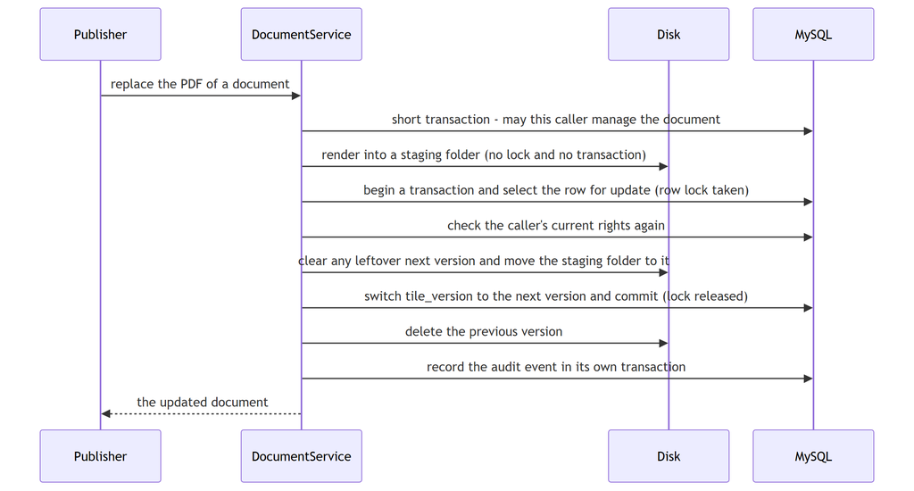

*Figure 14.1 — Replacing a PDF: render outside the lock, switch versions under it, delete the old version last*

*Text description:* A sequence with four participants: the publisher, `DocumentService`, the disk, and MySQL. Time runs downward. Rendering to a staging folder happens before the row lock is taken. The lock, the rights check, the move to the next version and the switch of `tile_version` happen inside one transaction. The previous version is deleted and the audit event written only after the commit.

Read the figure from top to bottom. The slow step, rendering, happens *before* the lock, so a second publisher isn't kept waiting while pages are drawn. The lock is held only for the short stretch from the `select ... for update` to the commit, which is where the version number changes. The old version is deleted *after* the commit, so a reader who still holds a link to it is never left with nothing on disk: at worst the link answers `410` (Chapter 17). The audit row is written last, in its own transaction (Section 14.8).

## Advanced tier: Separate transactions, cleanup, and real databases

*You can skip to "In this project" on a first read. Part IV tells when each of these was added.*

### 14.8 Separate transactions: `REQUIRES_NEW`

An audit trail must record failures, but a failure rolls back the caller's transaction, and with it any audit row written inside it. `AuditLogService` therefore writes in its own transaction:

```java
@Transactional(propagation = Propagation.REQUIRES_NEW)
public void record(AuditEventType type, Actor actor, Subject subject) {
    insert(Instant.now(), type, actor, subject);
}
```

(`book-m6-final`, `AuditLogService.java`.) **Propagation** says how a method joins a transaction that already exists. The default, `REQUIRED`, joins the caller's. `REQUIRES_NEW` suspends the caller's transaction, opens another, and commits it independently. The class comment gives the reason: the most important events (access denied, a failed operation) "are recorded just before the caller throws and rolls its own transaction back, and must not be rolled back with it."

**A real incident: the audit rows that vanished.** *The problem:* `ACCESS_DENIED` events were never saved. *How it was found:* an automated test written for the documents milestone caught it. *The cause:* the audit write shared the caller's transaction, and the request that was *denied* threw an exception, which rolled the whole transaction back, including the audit row that recorded the denial. *The fix:* audit writes run in their own transaction. The lesson: **the events you most need to keep are the ones that occur when something is failing.** Two cautions about this annotation. First, the wrapper sits *between beans*: it only runs when another bean calls the method. A method calling another method on `this` skips the proxy and the annotation does nothing. That is why `AuditLogService` also builds a `TransactionTemplate` with `PROPAGATION_REQUIRES_NEW` for `recordAtMostEvery`, its rate-limited variant, which decides in memory whether to write at all. That method is deliberately *not* annotated: the common case, an event suppressed as a repeat, uses no database connection. Second, the audit code uses plain `JdbcTemplate` SQL rather than JPA entities. Its rows are only inserted and searched, never updated, which is the pattern JPA helps least with, and there is no need to track objects that never change.

### 14.9 Time zones and UTC storage

A `DATETIME` column has no time zone. If a laptop in one zone and a container in another read the same stored value, they disagree about *which moment* it means. The project stores UTC everywhere: the JDBC (Java Database Connectivity) URL in `application.yml` ends with `connectionTimeZone=UTC&forceConnectionTimeZoneToSession=true`, and `hibernate.jdbc.time_zone: UTC` is set under `spring.jpa.properties`. The comment in the file explains: "DATETIME columns hold UTC regardless of the JVM's time zone, so a backend in UTC (Docker) and one in local time (a dev machine) read the same instant back."

**A real incident: audit events from the future.** *The problem:* audit events appeared with times five and a half hours in the future. *How it was found:* the AI product-owner reviewer (Chapter 32 explains how the reviews worked) noticed it while two copies of the backend shared one database. *The cause:* the development copy ran on a laptop in the Asia/Kolkata zone and wrote local time, while the Docker copy wrote UTC, so the same table held both. *The fix:* the team pinned the JDBC connection to UTC and showed UTC in the admin screen so it matches the watermark and the CSV export. It also added a test that runs the JVM in Asia/Kolkata against a MySQL server set to `-03:00` and checks that stored values are UTC. The test was verified to fail without the pinning. The lesson: **store instants in UTC, and test with a deliberately odd time zone**, because a test that runs in the developer's own zone can't fail.

### 14.10 Timed sweeps with `@Scheduled`

Some data must be cleaned up on a timer. Chapter 11 mentioned `@EnableScheduling`; with it on, a method marked `@Scheduled` runs by itself, on a background thread that Spring manages. The project has six.

Table 14.2 shows the sweeps as they are at `book-m6-final`. This chapter's own tag, `book-m2-documents`, has only three of the six: the audit purge, the sign-in throttle sweep, and the storage janitor. The others arrived in later milestones.

Table 14.2 — Scheduled sweeps (`book-m6-final`)

| Method | Schedule | Purpose |
| --- | --- | --- |
| `AuditLogService.purgeExpired` | cron `0 30 3 * * *` (daily, 03:30) | Delete audit events older than `audit-retention-days` (180 by default) |
| `AuditLogService.sweepThrottled` | fixed delay 1 hour | Forget idle throttle keys, first writing a summary of suppressed events |
| `KnownDevices.purgeExpired` | cron `0 45 3 * * *` (daily, 03:45) | Delete known-address rows older than 30 days (the `RETENTION` constant) |
| `LoginThrottle.sweep` | fixed delay 5 minutes | Drop sign-in counters whose failures have aged out |
| `TileRateLimiter.sweep` | fixed delay 5 minutes | Drop per-user tile windows with no recent requests |
| `StorageJanitor.sweep` | 2 minute initial delay, then every 6 hours | Remove tile directories nothing points to |

A **cron expression** lists second, minute, hour, day of month, month, and weekday: `0 30 3 * * *` means "second 0 of minute 30 of hour 3, every day." A **fixed delay** waits that long *after the previous run finishes*, so runs never overlap. The cron values are themselves configurable, as in `@Scheduled(cron = "${secure-doc-viewer.audit-retention-cron:0 30 3 * * *}")`, using the placeholder syntax from Chapter 11. Spring evaluates a cron in the server's time zone unless told otherwise, which is one more reason the app runs in UTC in its container.

The `StorageJanitor` is the most careful of the six, because it deletes files. It touches only directories whose names look like document ids and only ones older than an hour, "once they are old enough that no upload can still be in flight" (its class comment). It keeps every version of a document whose *current* version is missing from disk, because then the other versions may be the only surviving copy; a review of the backup design asked for that rule. Its test builds nine directories of different ages and checks exactly which are removed (Chapter 18). A good sweep is safe to run at any moment, safe to run twice, and logs and moves on when one item fails, so that one locked folder doesn't stop the rest.

### 14.11 Testing with H2 versus a real MySQL

Most tests run against H2, an in-memory database started in MySQL compatibility mode (`jdbc:h2:mem:securedocs;MODE=MySQL;DATABASE_TO_LOWER=TRUE`), so the same Flyway files run with no server. But H2 isn't MySQL. `MySqlIntegrationTest` runs the migrations, the row lock and the timestamp behavior against a real `mysql:8.4` container, and is skipped when Docker isn't available. Chapter 18 explains the tools in detail. The split is a trade: the fast tests run in seconds and catch most mistakes, and the slower one catches the mistakes only the real engine can make.

### 14.12 Common mistakes

- **Editing an applied migration.** Flyway refuses to start. Add a new file instead.
- **Letting Hibernate create the schema.** `ddl-auto: update` or `create` makes production depend on the code that last ran. Keep `none` and use migrations.
- **Ordering enums by position.** Use `EnumType.STRING`.
- **Returning entities from the service.** With `open-in-view: false`, lazy fields fail outside the transaction, and entities expose columns you didn't mean to show. Return records.
- **The N+1 query.** A loop that touches a lazy relationship runs one query per row. Load what you need with `join fetch`.
- **Holding a transaction during slow work.** Rendering a PDF, calling a remote server, or waiting on a file all belong outside it.
- **Calling a `@Transactional` method on `this`.** The proxy is bypassed and no transaction starts.
- **Writing audit rows inside the transaction that may fail.** Use `REQUIRES_NEW`.
- **Testing only in your own time zone.** Deliberately use an odd one.

## In this project

Table 14.3 — Where Chapter 14's ideas live (`book-m6-final`)

| Idea | File |
| --- | --- |
| Entities | `account/AppUser.java`, `document/Document.java`, `document/DocumentPage.java` |
| Repositories | `account/AppUserRepository.java`, `document/DocumentRepository.java` |
| Transactions | `account/UserAccountService.java`, `document/DocumentService.java`, `audit/AuditLogService.java` |
| Migrations | `src/main/resources/db/migration/V1`, `V2` (from `book-m2-documents`), `V3` (from `book-m5-platform`) |
| Sweeps | `AuditLogService`, `KnownDevices`, `LoginThrottle`, `service/StorageJanitor.java` |
| Settings | `src/main/resources/application.yml` (`ddl-auto`, `open-in-view`, JDBC URL, time zone) |

Part IV's chapters on milestones 1 and 2 (Chapters 26 and 27) tell how the schema grew; Chapter 34 covers backups of this database.

## Try it

### Exercise 14.1 ★ Why store the enum as text?

Which annotation stores the role as text, and why is that safer than the default? What would happen to existing rows if you inserted a new role between `READER` and `PUBLISHER` under the default?

*Solution:* Appendix C, Exercise 14.1.

### Exercise 14.2 ★ Find the audit indexes

Find the migration that creates `audit_event`. Which indexes does it define, and which admin filter does each one serve?

*Solution:* Appendix C, Exercise 14.2.

### Exercise 14.3 ★★ Read a query method

Without running anything, write the SQL you'd expect for `existsByUsername` and for `findAllByOrderByUsernameAsc`. Then find another query method in the project and take its name apart as in Table 14.1.

*Solution:* Appendix C, Exercise 14.3.

### Exercise 14.4 ★★ Annotation or template?

Explain why `DocumentService` uses `TransactionTemplate` while `UserAccountService` uses `@Transactional`. For each service, what would go wrong if you swapped the choice?

*Solution:* Appendix C, Exercise 14.4.

### Exercise 14.5 ★★★ Add a migration on a scratch copy

On a scratch branch and a scratch database (never your real one), write `V4` that adds a nullable column `notes VARCHAR(500)` to `document`. Start the app and confirm Flyway applied it. Then edit `V4` and start again, and read the error. What did Flyway check, and how do you make the change you wanted?

*Solution:* Appendix C, Exercise 14.5 (a worked outline).

### Exercise 14.6 ★★★ Predict the race

Two publishers replace the same document at the same moment. Walk through `DocumentService.replaceFile` and say what happens with and without the row lock, including what would be on disk afterward. Which test proves it, and why can't it run on H2?

*Solution:* Appendix C, Exercise 14.6 (a worked outline).

## Summary

- JPA and Hibernate map objects to tables; Spring Data writes common queries from method names; explicit `join fetch` queries avoid the N+1 problem.
- Entities describe tables and relationships (`@ManyToOne`, `@ElementCollection`, `@ManyToMany`); enums are stored as text.
- Flyway applies versioned SQL once each; Hibernate never alters the schema; an applied migration is never edited.
- Transactions make changes all-or-nothing; `TransactionTemplate` keeps slow work outside them, and `open-in-view: false` keeps entities inside them.
- `PESSIMISTIC_WRITE` serializes concurrent changes to one row, and a check made before a slow step must be repeated under the lock.
- `REQUIRES_NEW` commits audit rows even when the caller rolls back.
- `@Scheduled` runs cleanup sweeps that are safe to repeat; test with H2 for speed and real MySQL for truth; store time in UTC and test in an odd zone.

## Further reading

- *Spring Data JPA Reference Documentation*, "Query Methods." https://docs.spring.io/spring-data/jpa/reference/jpa/query-methods.html
- *Spring Framework Reference Documentation*, "Transaction Management." https://docs.spring.io/spring-framework/reference/data-access/transaction.html
- *Spring Framework Reference Documentation*, "Task Execution and Scheduling." https://docs.spring.io/spring-framework/reference/integration/scheduling.html
- *Hibernate ORM Documentation*. https://hibernate.org/orm/documentation/
- *Flyway Documentation*, "Migrations." https://documentation.red-gate.com/flyway

# Chapter 15: Spring Security I: who are you?

Before the Secure Document Viewer can decide what you may open, it must know who you are. This chapter covers authentication. You learn how the server checks a claim of identity and how passwords are stored so that even the database's owner can't read them. You also learn how a session cookie keeps you signed in, how roles say what an account is for, and why the sign-in endpoint gives the same answer for a wrong password and an unknown user. Chapter 16 then adds the defenses that protect all of this.

## Learning objectives

By the end of this chapter, you will be able to:

- Explain the difference between authentication and authorization.
- Describe what a servlet filter is and how Spring Security's filter chain uses it.
- Explain why passwords are hashed and salted, what BCrypt is, and what its 72-byte limit means in practice.
- Follow one sign-in through `AuthController`, step by step, and say why each step is where it is.
- Explain how a session cookie works, what `httpOnly` and `SameSite` do, and why the project chose sessions over tokens.
- Read `DatabaseUserDetailsService` and the three roles.
- Explain why sign-in reveals nothing about which accounts exist.

## Prerequisites

- Chapter 5: collections, lambdas, and exceptions
- Chapter 8: how the web works (cookies, headers)
- Chapter 11: Spring Boot foundations
- Chapter 12: REST controllers and JSON
- Chapter 13: Validation, configuration properties, and errors
- Chapter 14: Storing data with JPA and Flyway

**A note on versions.** The chapter belongs to milestone 1 (`book-m1-accounts`), but each listing is labeled with the tag it was copied from. `Role.java` and `DatabaseUserDetailsService.java` are identical at `book-m1-accounts` and `book-m6-final`. The 72-byte check, the full sign-in code, and the security chain shown here come from `book-m6-final`, because those files gained features after milestone 1.

## Beginner tier: Proving who you are

### 15.1 Authentication, authorization, and the difference

Authentication answers "who are you?" Authorization answers "what may you do?" Think of an office building with a front desk. Showing your badge to the guard is authentication. The badge reader on each door, which opens only some of them for you, is authorization. This chapter is about the guard; Chapter 16 is about the doors.

**Where the analogy breaks down:** a guard sees your face and remembers you. A server sees only a claim, a username and a password typed into a form, and it can't tell a person from a script. It must also re-check on every request, because HTTP has no memory of earlier requests unless you add one (Section 15.6). Nothing here identifies a *human*; it identifies someone who knows the password.

**Spring Security** is the part of the Spring family that does both jobs. You add one dependency, `spring-boot-starter-security`, and Spring Boot 4 with Spring Security 7 protects every endpoint until you say otherwise. That "closed by default" behavior is the right way around: you must open doors on purpose.

### 15.2 The filter chain

A **servlet** is Java's name for a piece of code that handles web requests, and the web server (Tomcat, in this project) hands each request to your application through a chain of **servlet filters**. A filter is code that every request passes through *before* it reaches a controller, and every response passes back through afterward. Each filter can look at the request, change it, stop it (by writing a response itself) or pass it on.

*Pattern note: A filter chain is the chain of responsibility pattern (Chapter 38, Section 38.3; pipes and filters, Chapter 39, Section 39.8).*

Spring Security is a chain of such filters, each with one job. One reads the session and works out who the caller is. One checks the cross-site request forgery (CSRF) token (Chapter 16). One decides whether the request is allowed. If any filter refuses, the controller never runs. You describe the chain in one place, a bean of type `SecurityFilterChain`. The project's begins like this.

**Listing 15.1 — `SecurityConfig.java` (`book-m6-final`, simplified: the method's other parameters are omitted, and only the opening lines and the last disabled features are shown)**

```java
@Configuration
@EnableWebSecurity
public class SecurityConfig {

    @Bean
    public SecurityFilterChain securityFilterChain(HttpSecurity http, ...) throws Exception {
        http
                // ... csrf, sessions, headers, authorization rules, custom filters ...
                .requestCache(cache -> cache.disable())
                .formLogin(AbstractHttpConfigurer::disable)
                .httpBasic(AbstractHttpConfigurer::disable)
                .logout(AbstractHttpConfigurer::disable);
        return http.build();
    }
```

*Path: `src/main/java/com/example/securedocviewer/security/SecurityConfig.java`*

`@Configuration` marks a class whose `@Bean` methods create beans by hand (Chapter 11). `@EnableWebSecurity` switches on the Spring Security machinery. The `HttpSecurity` parameter is a builder: you call methods on it to describe the chain, and `http.build()` produces the finished `SecurityFilterChain`.

The last three lines *turn off* features Spring Security would otherwise provide. `formLogin` is a ready-made HTML sign-in page, `httpBasic` is a browser pop-up asking for a username and password, and Spring's built-in `logout` handles a sign-out address. The project disables all three because the Angular app has its own sign-in screen and talks to its own endpoints, `/api/auth/login` and `/api/auth/logout`, that return JSON (Chapter 12). The middle of the chain, the CSRF and authorization rules, is Chapter 16.

Why write the chain by hand instead of using defaults? Because the defaults assume a server that renders web pages, while this app is an API used by a single-page application. Every default you leave on is a behavior you'd have to understand, test and defend, so the project turns on only what it uses.

### 15.3 Storing passwords: hashing, salting, BCrypt

The database must never contain passwords. Anyone who could read it, through a leaked backup, a stolen disk, or a mistake, would have every account, and people reuse passwords across sites. Instead the database stores a **hash**: the output of a one-way function that turns a password into a fixed-length string of characters. "One-way" means that given the hash you can't practically get back the password. To check a sign-in, the server hashes what was typed and compares the two hashes.

*Pattern note: A password encoder that can be swapped or upgraded is the strategy pattern (Chapter 38, Section 38.4).*

Plain hashing has two weaknesses. Two people with the same password would have the same hash, and attackers prepare tables of the hashes of common passwords. The fix for both is a **salt**: random data mixed into each password before hashing, so the same password produces a different hash every time. The salt isn't secret. It's stored beside the hash, and its job is to make precomputed tables useless.

The remaining problem is speed. Ordinary hash functions are designed to be fast, which helps an attacker trying billions of guesses per second. **BCrypt** is a hash function built for passwords. It includes the salt in its output, and it is deliberately slow: it repeats an expensive step many times, and the number of repetitions (the *work factor*) can be raised as computers get faster. Checking one password costs a fraction of a second, which nobody notices when signing in, and multiplies into an enormous cost for someone trying billions of guesses.

A BCrypt hash looks like a 60-character string beginning with something like `$2a$10$`. That prefix names the algorithm version and the work factor, and the rest holds the salt and the result. You'll see in the code that the project stores a slightly longer string, and Listing 15.2 shows why.

**Listing 15.2 — `SecurityConfig.passwordEncoder` (`book-m6-final`; identical logic at `book-m1-accounts`)**

```java
/** Delegating encoder stores "{bcrypt}..." so the algorithm can be upgraded later without a migration. */
@Bean
public PasswordEncoder passwordEncoder() {
    return PasswordEncoderFactories.createDelegatingPasswordEncoder();
}
```

*Path: `src/main/java/com/example/securedocviewer/security/SecurityConfig.java`*

A `PasswordEncoder` is Spring Security's interface for "turn a password into a hash" (`encode`) and "does this password match this hash?" (`matches`). The **delegating** encoder adds a label to what it stores, such as `{bcrypt}`, and later chooses the algorithm from the label. Suppose in five years the project wants a stronger algorithm. New passwords would be stored as `{newalgo}...`, and old `{bcrypt}...` hashes keep working, so nobody is forced to reset their password. The column that holds the hash is `VARCHAR(100)` (migration `V1`, Chapter 14), which fits the label plus a 60-character hash with room to spare.

#### Worked example: what "matching" means

Suppose an account has the password `<example-password>` (a placeholder: this book never prints real passwords). Table 15.1 shows what the app does, in order. The hash strings are placeholders, not real values.

Table 15.1 — Creating an account and signing in, from the password's point of view

| Step | What happens | What is stored or compared |
| --- | --- | --- |
| Create | `encode("<example-password>")` picks a random salt and hashes | `{bcrypt}$2a$10$<salt+hash-A>` saved in `password_hash` |
| Sign in | The user types the password again | Nothing is stored |
| Check | `matches("<example-password>", stored)` reads the salt out of the stored value and hashes the typed password with it | Equal, so the check passes |
| Second account, same password | `encode(...)` picks a *new* salt | `{bcrypt}$2a$10$<salt+hash-B>`, different from A |

The last row is what the salt buys: nobody reading the table can see that two accounts share a password.

BCrypt has a limit that surprises people. It reads only the first 72 **bytes** of a password, and current Spring Security refuses longer input rather than quietly ignoring the rest. `UserAccountService` handles this explicitly.

**Listing 15.3 — `UserAccountService.java` (`book-m6-final`, excerpt: the 72-byte constant and check)**

```java
/** BCrypt uses at most 72 bytes of a password and refuses longer ones. */
public static final int MAX_PASSWORD_BYTES = 72;

public static boolean fitsBcrypt(String password) {
    return password == null || password.getBytes(java.nio.charset.StandardCharsets.UTF_8).length <= MAX_PASSWORD_BYTES;
}
```

*Path: `src/main/java/com/example/securedocviewer/account/UserAccountService.java`*

The check counts bytes in UTF-8, not characters. A letter in the English alphabet is one byte, but an accented letter like `é` takes two, a Chinese character takes three, and an emoji takes four. A passphrase of 20 emoji looks short but is 80 bytes, so it doesn't fit. The rule is enforced when a password is set and again at sign-in (you'll see where in Section 15.5), so an over-long attempt is refused cleanly instead of failing deep inside the hashing library. A related rule in the same class limits passwords to between 12 and 128 characters. Length, more than complexity, is what makes a password hard to guess.

## Intermediate tier: Sessions, roles, and the sign-in

*If you're reading for the first time, Sections 15.4 and 15.5 are the heart of the chapter; 15.6 to 15.8 fill in the details.*

### 15.4 Loading users from the database

Spring Security needs one thing from you: given a username, return the account's stored hash and roles. That is a `UserDetailsService`.

**Listing 15.4 — `DatabaseUserDetailsService.java` (`book-m1-accounts`, identical at `book-m6-final`; imports omitted)**

```java
@Service
public class DatabaseUserDetailsService implements UserDetailsService {

    private final AppUserRepository repository;

    public DatabaseUserDetailsService(AppUserRepository repository) {
        this.repository = repository;
    }

    @Override
    public UserDetails loadUserByUsername(String username) {
        AppUser user = repository.findByUsername(UserAccountService.normalizeUsername(username))
                .orElseThrow(() -> new UsernameNotFoundException("Unknown user"));
        return User.withUsername(user.getUsername())
                .password(user.getPasswordHash())
                .roles(user.getRole().name())
                .disabled(!user.isEnabled())
                .build();
    }
}
```

*Path: `src/main/java/com/example/securedocviewer/security/DatabaseUserDetailsService.java`*

Line by line: the class is a `@Service` bean (Chapter 11) that implements the Spring Security interface `UserDetailsService`, whose one method is `loadUserByUsername`. It receives `AppUserRepository` by constructor injection (Chapter 14). It looks the user up by the *normalized* username, lower-cased and trimmed, so `Alice` and `alice` are the same account; the account-creation code enforces the same rule, which is why the `username` column's unique constraint works as a case-insensitive one. If nothing is found it throws `UsernameNotFoundException`, and Spring Security handles the rest.

`User.withUsername(...)` is a builder for Spring Security's own `UserDetails` object, which carries a username, a password *hash*, roles, and flags. Note that it holds the stored hash, never a password. `.roles("ADMIN")` becomes the **authority** string `ROLE_ADMIN`: Spring stores every permission as a text authority, and `roles(...)` is shorthand that adds the `ROLE_` prefix for you. `.disabled(!user.isEnabled())` marks a switched-off account, which makes authentication fail no matter how correct the password is.

What connects this service to the hash comparison? The `AuthenticationManager` bean in `SecurityConfig` wraps a `DaoAuthenticationProvider`, which is constructed with this service and the password encoder. When asked to authenticate, that provider calls `loadUserByUsername`, checks that the account isn't disabled, and calls the encoder's `matches`. Three small pieces, each with one job, produce the whole check.

### 15.5 Following one sign-in through `AuthController`

Now put the pieces together by reading what happens when the sign-in form is submitted. `AuthController.login` is long, so this section walks through it in three excerpts. Read them slowly; the *order* of the steps is where most of the design lives. Figure 15.1 gives the whole sequence first, so the excerpts have a map.

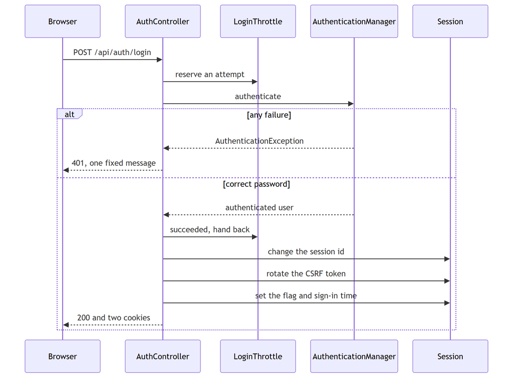

*Figure 15.1 — The sign-in sequence in `AuthController.login`*

*Text description:* A sequence between the browser, `AuthController`, `LoginThrottle`, the authentication manager, and the session. The controller first reserves an attempt from the throttle and then authenticates. A choice follows. A wrong password, unknown user, or disabled account gives one fixed `401`. A correct password hands the attempt back, changes the session id, rotates the CSRF token, sets two flags on the session and returns `200` with the cookies.

Two things to notice. The throttle is asked *before* the password is looked at, and the reservation is given back only on success. And every failure, whatever its cause, ends in the same `401`, while a success creates a session with a *new* id and a *new* CSRF token. The next three excerpts follow the figure step by step.

**Listing 15.5 — `AuthController.java` (`book-m6-final`, excerpt 1 of 3: `login`, start; indentation reduced and the lockout handling replaced by `// ...`)**

```java
@PostMapping("/login")
public ResponseEntity<CurrentUser> login(@Valid @RequestBody LoginRequest body,
                                         HttpServletRequest request,
                                         HttpServletResponse response) {
    String username = UserAccountService.normalizeUsername(body.username());
    String clientIp = request.getRemoteAddr();
    Actor attempted = new Actor(username, null, clientIp);
    boolean recognisedDevice = knownDevices.isRecognised(username, clientIp);
    Instant attempt;
    try {
        attempt = loginThrottle.reserve(username, clientIp, recognisedDevice);
    } catch (LoginLockedException e) {
        // ...
        throw e;
    }
```

*Path: `src/main/java/com/example/securedocviewer/controller/AuthController.java`*

**Step 1: validate and normalize.** `@Valid` applies the length rules from Chapter 13 (`username` at most 64 characters, `password` at most 128) before any code runs, and the username is normalized. **Step 2: reserve an attempt.** `loginThrottle.reserve` checks the sign-in limits and counts this attempt as a failure *in advance*. That surprising order is the subject of Chapter 16. For now, notice that the throttle runs before the password is looked at. A locked-out caller therefore learns nothing about whether their guess was right, and the refusal costs the server almost nothing.

**Listing 15.6 — `AuthController.java` (`book-m6-final`, excerpt 2 of 3: the authentication step; indentation reduced)**

```java
Authentication authentication;
try {
    // BCrypt only looks at 72 bytes and refuses longer input; no stored password is longer.
    if (!UserAccountService.fitsBcrypt(body.password())) {
        throw new BadCredentialsException("Password too long.");
    }
    authentication = authenticationManager.authenticate(
            UsernamePasswordAuthenticationToken.unauthenticated(username, body.password()));
} catch (AuthenticationException e) {
    // Same message for unknown user, wrong password and disabled
    // account, so the response doesn't reveal which accounts exist.
    // The failure was already counted by reserve().
    metrics.signIn(SignInOutcome.FAILURE);
    audit.record(AuditEventType.SIGN_IN_FAILED, attempted, Subject.none());
    throw new BadCredentialsException("Invalid username or password.");
}
```

*Path: `src/main/java/com/example/securedocviewer/controller/AuthController.java`*

**Step 3: authenticate.** The over-long password check (Section 15.3) comes first. Then `authenticationManager.authenticate(...)` is handed an *unauthenticated* token, a plain "someone claims to be this user with this password," and the manager (the `DaoAuthenticationProvider` from Section 15.4) either returns a fully authenticated `Authentication` object or throws an `AuthenticationException`. **Step 4: one answer for every failure.** Whatever went wrong, the code throws a *new* `BadCredentialsException` with a fixed message. Section 15.8 explains why.

In short, the third excerpt does this: *prove the password was right, then start a fresh session, then remember a few facts about it.* If you lose the thread in the details, hold on to that sentence.

**Listing 15.7 — `AuthController.java` (`book-m6-final`, excerpt 3 of 3: success; indentation reduced)**

```java
loginThrottle.succeeded(username, clientIp, attempt);
metrics.signIn(SignInOutcome.SUCCESS);
knownDevices.remember(username, clientIp);
boolean mustChangePassword = accounts.recordSignIn(username);

// Ensure a session exists, then rotate its id and register it.
request.getSession(true);
sessionAuthenticationStrategy.onAuthentication(authentication, request, response);
rotateCsrfToken(request, response);
SecurityContext context = SecurityContextHolder.createEmptyContext();
context.setAuthentication(authentication);
SecurityContextHolder.setContext(context);
securityContextRepository.saveContext(context, request, response);
HttpSession session = request.getSession();
session.setAttribute(PasswordChangeRequiredFilter.SESSION_ATTRIBUTE, mustChangePassword);
session.setAttribute(SessionLifetimeFilter.SIGNED_IN_AT, Instant.now());
sessionMetadata.recordSignIn(session.getId(), clientIp, request.getHeader("User-Agent"));
audit.record(AuditEventType.SIGN_IN, actors.of(request, username), Subject.none());

return ResponseEntity.ok(toCurrentUser(authentication, request));
```

*Path: `src/main/java/com/example/securedocviewer/controller/AuthController.java`*

**Step 5: hand back the reserved attempt** (`succeeded`), because the password was right, and record a few facts. One is a metric (a counter for the operators' dashboard, Chapter 35). Another is the address as a "known device" (an address this account has signed in from successfully; Chapter 16). The last is the account's last sign-in time. The value `mustChangePassword` says whether this account is still using a password an administrator set (Chapter 16, Section 16.7).

**Step 6: create the session.** `request.getSession(true)` makes sure a session exists. `sessionAuthenticationStrategy.onAuthentication` then changes the session's id and registers it, which prevents a **session fixation** attack in which an attacker plants a known id before you sign in (Chapter 16). `rotateCsrfToken` issues a fresh CSRF token. Then the code builds a `SecurityContext`, Spring Security's container for "who is signed in," puts the authenticated user in it, and saves it into the session with `securityContextRepository.saveContext`. From now on, the security filters find the user by reading the session, which is what "being signed in" means in this app.

**Step 7: remember a few things on the session** (whether a password change is pending, and the time of sign-in, used by the lifetime filter in Chapter 16). Then write an **audit event**, a row in the append-only record of who did what (Chapter 14's `REQUIRES_NEW` explained why audit rows survive failures, and Chapter 27 tells how the audit trail was built). Finally, return the current user's public details. The response never includes the session id. The class comment states the rule: it "travels only in the httpOnly session cookie set by the container."

Step 6 raises an obvious question: what *is* the session, and how does the browser present it on the next request?

### 15.6 Sessions and the session cookie (`SDV_SESSION`, httpOnly, SameSite)

HTTP forgets you between requests. Chapter 8 compared the session cookie to a coat-check ticket, and this section shows the real thing. After a successful sign-in, the server creates a session: a record kept on the server, holding the security context and the attributes from Step 7, and identified by a long random id. The server sends that id to the browser in a cookie (Chapter 8), and the browser returns the cookie with every later request. The server looks the id up and knows who is calling. Here is the relevant part of the sign-in response as it travels, written as an example rather than a capture from the project, with a placeholder id.

**Example 15.1 — A sign-in response that sets the session cookie (teaching example)**

```
HTTP/1.1 200 OK
Set-Cookie: SDV_SESSION=<session-id>; Path=/; HttpOnly; SameSite=Strict
Set-Cookie: XSRF-TOKEN=<csrf-token>; Path=/; SameSite=Strict
Content-Type: application/json

{"username":"reader.one","role":"READER",...}
```

The project configures the session cookie in `application.yml`.

**Listing 15.8 — `application.yml` (`book-m6-final`, excerpt: the session block, comments trimmed)**

```yaml
server:
  servlet:
    session:
      timeout: 30m
      cookie:
        name: SDV_SESSION
        http-only: true
        same-site: strict
        secure: ${SESSION_COOKIE_SECURE:false}
```

*Path: `src/main/resources/application.yml`*

- `name: SDV_SESSION` renames the container's default cookie so the app is recognizable in the browser's developer tools.
- `http-only: true` hides the cookie from JavaScript. If an attacker ever manages to run a script inside the page, they still can't read the session id.
- `same-site: strict` tells the browser to send the cookie only for requests that begin on the app's own site, which blocks a whole class of cross-site tricks (Chapter 16).
- `secure` means "send it only over HTTPS." It defaults to `false` for local development and is set to `true` wherever the app is served over HTTPS; the file's own comment says it "Must be true anywhere the app is served over HTTPS."
- `timeout: 30m` is the idle timeout: 30 minutes without a request ends the session.

**Sessions versus tokens.** The alternative to a server-side session is a token: a signed piece of text that the browser stores and sends with each request, usually in a header. One example is a **JWT** (JSON Web Token), a signed text holding your identity and an expiry. The server can check it without keeping any records. Table 15.2 compares the two for this project.

Table 15.2 — Sessions and tokens, for this app

| Question | Session cookie | Token in the browser |
| --- | --- | --- |
| Can the server end it instantly? | Yes: delete the session record | Not without extra work: it stays valid until it expires |
| Can JavaScript steal it? | Not with `httpOnly` | Often yes, because scripts must send it |
| Does the server store state? | Yes, one record per sign-in | No |
| Does the browser send it automatically? | Yes, which is why CSRF protection is needed | No, the app attaches it |

The project chose the session cookie. The features it wanted (an admin listing and revoking sessions, ending every session when a password changes, a fixed maximum lifetime) are all straightforward when the server owns the record, and awkward with tokens. The price is the CSRF protection you'll read about in Chapter 16 and the need to keep session state on the server: the project's session registry, for example, lives in the server's memory. Neither approach is universally better; the point is that the requirements chose.

### 15.7 Roles: READER, PUBLISHER, ADMIN

A role is a named set of permissions attached to an account. This app has three, defined in one small file.

**Listing 15.9 — `Role.java` (`book-m1-accounts`, identical at `book-m6-final`; the class comment is omitted)**

```java
public enum Role {
    READER,
    PUBLISHER,
    ADMIN
}
```

*Path: `src/main/java/com/example/securedocviewer/account/Role.java`*

The class comment explains them: every signed-in user can read documents they have access to, publishers can also upload, and administrators can additionally manage accounts, sessions and the audit log. The roles are cumulative on purpose: a `PUBLISHER` can do everything a reader can, plus upload. Chapter 16 shows the rules that enforce them.

Where do accounts come from? There is **no self-registration**. An administrator creates every account (`UserAccountService.create`), which checks the username against the pattern `[a-z0-9._-]{3,32}` and the password against the length rules, and sets "must change password" so the new user chooses their own at first sign-in. The very first administrator has to come from somewhere, and `BootstrapAdmin` supplies it. On a completely empty database it creates an account whose password comes from the `BOOTSTRAP_ADMIN_PASSWORD` setting. If that isn't set, the password is a random 20-character value that it prints to the log once. Its class comment compares this to what Spring Boot itself does for a default user. A generated password is flagged "must change," precisely because it appeared in a log. Once any account exists, the class does nothing.

### 15.8 Same answer for wrong password and unknown user

If the server said "no such user" in one case and "wrong password" in another, an attacker could try a list of names and learn which accounts exist. That is called **user enumeration**, and it is the first step in many attacks: guessing passwords for a known account is far easier than guessing both parts. `AuthController` (Listing 15.6) collapses every authentication failure into one message, and `GlobalExceptionHandler` turns it into a `401` with the single text `Invalid username or password.` (Chapter 13).

The test that guards it is `wrongPasswordAndUnknownUserGetTheSameAnswer` in `SecurityIntegrationTest` (Chapter 18). It signs in once with a real user and a wrong password, once with a name that doesn't exist, and asserts that the two response bodies are *equal*. The audit log records every failure with the attempted username (Chapters 14 and 27), so operators can see what an attacker sees only as silence.

We simplify one thing here: response *time* can also leak information, because hashing a password takes longer than failing to find a user. Spring Security's `DaoAuthenticationProvider` narrows this difference by hashing a dummy password when the user isn't found; the project adds nothing of its own on top. The sign-in throttle (Chapter 16) limits how many guesses anyone gets, which keeps the remaining leak from being useful in practice.

## Advanced tier: Keeping the credential itself out of reach

*You can skip to "In this project" on a first read; Part IV's chapters on sessions and accounts come back to these ideas.*

### 15.9 The session id never leaves the server

The session id is the real credential: whoever holds it *is* you. Look at where the app deliberately does not put it. It isn't in any JSON response, and it isn't in a URL. The admin session list shows sessions by an opaque **handle**, and tile URLs carry a value derived from the session id, not the id. Both come from one small class, `SessionKeys`.

**Listing 15.10 — `SessionKeys.java` (`book-m6-final`, excerpt: the class comment and two methods)**

```java
/**
 * Derives values from a session id that are safe to expose, so the id
 * itself (the real credential) never leaves the server:
 * <ul>
 *   <li>{@link #tileBinding} goes into signed tile URLs. A tile request
 *       must present both the URL and the session cookie it derives from,
 *       so a leaked URL alone is useless.</li>
 *   <li>{@link #adminHandle} identifies a session in the admin UI so it can
 *       be revoked. It can't be turned back into the id or used to sign in.</li>
 * </ul>
 * Each uses a different HMAC context, so one can't stand in for the other.
 */
@Component
public class SessionKeys {

    // ...

    public String tileBinding(String sessionId) {
        return derive("tile-binding:", sessionId, 16);
    }
    // ...
}
```

*Path: `src/main/java/com/example/securedocviewer/security/SessionKeys.java`*

The trick is an **HMAC** (hash-based message authentication code), a keyed fingerprint: a hash (Section 15.3) computed with a secret key, so only the holder of the key can produce it. You'll meet HMAC properly in Chapter 17; for now it's enough to know that it's applied to the session id with the server's secret. A derived value can be shown to the outside world because nobody can run the calculation backward to recover the id. And because `tile-binding:` and `admin-handle:` are mixed in as labels, a value derived for one purpose can't be replayed for the other. Each exposure of "something about the session" is a separate derivation, so leaking one doesn't leak the others. This is a general design habit worth adopting: **never expose a credential when a value derived from it will do.**

### 15.11 Common mistakes

- **Storing or logging the password.** The stored value is always a hash, and the audit log records that a sign-in failed, never what was typed. A password in a log file is a password in every backup of the log.
- **Different answers for different failures.** "No such user" versus "wrong password" is user enumeration. The same goes for "your account is disabled" shown to someone who hasn't proved they own it.
- **Trusting the client's idea of the role.** The UI hides buttons a role can't use, but the server checks the role on every request (Chapter 16). A hidden button is a convenience, not a lock.
- **Forgetting that BCrypt counts bytes.** A limit stated in characters lets a long emoji password through and then fails with a confusing error. The project counts bytes.
- **Editing the encoder without a migration path.** Changing the hashing algorithm requires a way for existing hashes to keep verifying; the delegating encoder's label is that path.
- **Keeping the default session cookie name and flags.** The defaults aren't wrong, but if you don't set `http-only`, `same-site` and `secure` deliberately, you don't know what you're getting.

## In this project

Table 15.3 — Where Chapter 15's ideas live

| Idea | File | Tag |
| --- | --- | --- |
| Filter chain, encoder | `security/SecurityConfig.java` | `book-m1-accounts`, `book-m6-final` |
| Roles | `account/Role.java` | `book-m1-accounts` |
| User lookup | `security/DatabaseUserDetailsService.java` | `book-m1-accounts` |
| Sign-in endpoint | `controller/AuthController.java` | `book-m6-final` |
| Account rules, 72-byte limit | `account/UserAccountService.java` | `book-m6-final` |
| First administrator | `account/BootstrapAdmin.java` | `book-m6-final` |
| Session cookie settings | `src/main/resources/application.yml` | `book-m6-final` |
| Session-derived values | `security/SessionKeys.java` | `book-m6-final` |

Part IV's chapter on milestone 1 (Chapter 26) tells how accounts and sessions were built; this chapter explains the concepts it uses.

## Try it

### Exercise 15.1 ★ Find the cookie settings

Which setting makes the session cookie unreadable to JavaScript, and which file holds it? Which setting controls how long an idle session lasts?

*Solution:* Appendix C, Exercise 15.1.

### Exercise 15.2 ★ What does the database store?

Open `V1__create_app_user.sql` at `book-m2-documents` and find the column that holds the password hash. What is stored in it, and why is `VARCHAR(100)` enough?

*Hint:* count the characters of a BCrypt hash and of the `{bcrypt}` label.

*Solution:* Appendix C, Exercise 15.2.

### Exercise 15.3 ★★ Count bytes, not characters

Copy the `fitsBcrypt` method from Listing 15.3 (it is `static` and needs nothing else) into a small Java file of your own, with `MAX_PASSWORD_BYTES = 72`, and print its result for four strings: 72 letters `a`, 73 letters `a`, 30 copies of the letter `é`, and 20 emoji of your choice. Predict each answer first. Explain the results in terms of UTF-8.

*Solution:* Appendix C, Exercise 15.3.

### Exercise 15.4 ★★ Trace a failed sign-in

Using Listings 15.5 and 15.6, list in order every method called when the password is wrong for a user that exists, and say what the HTTP response is. Then do the same for a user that doesn't exist. Where do the two paths meet?

*Solution:* Appendix C, Exercise 15.4.

### Exercise 15.5 ★★★ Sessions or tokens?

Suppose the project owner asks for "sign out everywhere, immediately, when a user's password changes." Explain how the current design does this and what it would take with a token-only design. Then name one requirement for which tokens would be the better choice, and say what the project would give up by switching.

*Solution:* Appendix C, Exercise 15.5 (a worked outline).

### Exercise 15.6 ★★★ Design a safe response

You are adding a "forgot password" feature that sends an email. The form takes an email address. Design the response the server gives when the address isn't registered, so that it doesn't enable user enumeration. What would the timing of the two cases need to look like?

*Solution:* Appendix C, Exercise 15.6 (a worked outline).

## Summary

- Authentication proves who you are; authorization decides what you may do.
- Spring Security is a chain of servlet filters described by one `SecurityFilterChain` bean; the project turns off the form, Basic, and logout features it doesn't use.
- Passwords are stored as salted BCrypt hashes, labeled by the delegating encoder so the algorithm can change; BCrypt accepts at most 72 bytes, and the project counts bytes.
- `DatabaseUserDetailsService`, the password encoder, and `DaoAuthenticationProvider` together perform the check.
- Sign-in runs in a deliberate order: throttle, validate, authenticate, then create a fresh session with a fresh id and CSRF token, and record it.
- A server-side session and an `httpOnly`, `SameSite=Strict` cookie keep you signed in without exposing the session id to scripts; the requirements, not fashion, chose sessions over tokens.
- Three cumulative roles are loaded from the database; there is no self-registration.
- Every authentication failure gets one response, so accounts can't be enumerated, and credentials are never exposed when a derived value will do.

## Further reading

- *Spring Security Reference Documentation*, "Authentication." https://docs.spring.io/spring-security/reference/servlet/authentication/index.html
- *Spring Security Reference Documentation*, "Password Storage." https://docs.spring.io/spring-security/reference/features/authentication/password-storage.html
- *OWASP Cheat Sheet Series*, "Password Storage Cheat Sheet." https://cheatsheetseries.owasp.org/cheatsheets/Password_Storage_Cheat_Sheet.html
- *OWASP Cheat Sheet Series*, "Session Management Cheat Sheet." https://cheatsheetseries.owasp.org/cheatsheets/Session_Management_Cheat_Sheet.html

# Chapter 16: Spring Security II: defenses

Signing in is only the start. A signed-in browser carries a credential that other websites can try to borrow, a public sign-in form invites password guessing, and every request must be checked against what its caller is allowed to do. This chapter covers the layers that make a signed-in session safe and the sign-in endpoint hard to abuse: cross-site request forgery (CSRF) protection, per-endpoint authorization, security headers, session lifetime, and revocation, sign-in throttling, trusting proxies, and the forced password change. Several of them come with real incidents from this project.

## Learning objectives

By the end of this chapter, you will be able to:

- Explain a CSRF attack and the cookie-plus-header defense the project uses.
- Read the authorization rules in `SecurityConfig`, and explain why a document you can't see gives `404` rather than `403`.
- Explain what each security header the API sends is for.
- Describe how sessions are ended: by idle timeout, by a fixed lifetime, and by an administrator.
- Explain how `LoginThrottle` counts attempts atomically, and why a lockout is itself something to defend.
- Explain why `X-Forwarded-For` is trusted only from a configured proxy.
- Explain how the forced password change is enforced on the server.

## Prerequisites

- Chapter 8: how the web works (headers, cookies, the same-origin rule)
- Chapter 13: Validation, configuration properties, and errors
- Chapter 14: Storing data with JPA and Flyway (audit rows are written in their own transaction)
- Chapter 15: Spring Security I

**A note on versions.** All listings are quoted from `book-m6-final`, where these defenses are complete. `SpaCsrfTokenRequestHandler.java` is identical at `book-m1-accounts`. The throttling, session-lifetime, and forced-password-change code arrived in later milestones, and `SecurityConfig` differs from its milestone 1 form.

## Beginner tier: Attacks the browser makes for you

### 16.1 CSRF: the attack

Your browser attaches the session cookie to every request it sends to the app, no matter which page caused the request. That's convenient, and it is also the weakness. Suppose you are signed in to the app in one tab, and in another tab you open a malicious page. That page can contain a hidden form that sends a request to the app's "delete document" address. The browser dutifully attaches your cookie, and the server sees a valid session and does what the request says. This is **cross-site request forgery (CSRF)**: another site borrows your credentials to act in your name. The attacker never sees your cookie; they only need the browser to send it.

An analogy: you leave your outgoing mail tray on your desk. Anyone who can slip a note into the tray gets it posted with your return address, and the post office treats it as yours. The defense is a code word. The post office says: "Every request from you must include today's code word, which only you were told." A stranger who slips a note into your tray can't add the code word, because they don't know it.

**Where the analogy breaks down:** the code word only helps if the stranger can't read it. Anyone who can run a script *inside* the legitimate page (a cross-site scripting attack) can read the code word and use it. The CSRF token protects against forged requests from other sites, not against a compromised page. That's why the API also sends the strict headers in Section 16.4.

### 16.2 The defense: a token in a cookie and a header

The server sets a second cookie, `XSRF-TOKEN`, holding a random value. The app's own JavaScript reads that cookie and copies its value into a request header, `X-XSRF-TOKEN`, on every request that changes something (`POST`, `PUT`, `PATCH`, `DELETE`). The server accepts a change only if the header matches the token. A foreign page can make the browser *send* cookies, but it can't *read* this cookie (browsers only let a site read its own cookies), so it can't fill in the header. This is the **double-submit cookie** pattern: the same value arrives twice, once in a cookie the browser sends automatically and once in a header that only the real app can write.

*Pattern note: The token handler is a swappable strategy (Chapter 38, Section 38.4).*

Here is one changing request as it travels, written as an example with placeholders, not captured from the project.

**Example 16.1 — A request that changes something, with its CSRF header (teaching example)**

```
DELETE /api/documents/<document-id> HTTP/1.1
Host: localhost:8080
Cookie: SDV_SESSION=<session-id>; XSRF-TOKEN=<csrf-token>
X-XSRF-TOKEN: <csrf-token>
```

The two `<csrf-token>` placeholders are the same value. If the header is missing or different, the server answers `403` before the controller runs. The project configures the cookie in `SecurityConfig`.

**Listing 16.1 — `SecurityConfig.csrfTokenRepository` (`book-m6-final`)**

```java
@Bean
public CsrfTokenRepository csrfTokenRepository() {
    CookieCsrfTokenRepository repository = CookieCsrfTokenRepository.withHttpOnlyFalse();
    repository.setCookieCustomizer(cookie -> cookie.sameSite("Strict").path("/"));
    return repository;
}
```

*Path: `src/main/java/com/example/securedocviewer/security/SecurityConfig.java`*

`withHttpOnlyFalse()` is deliberate. Unlike the session cookie, this cookie *must* be readable by JavaScript, or the app couldn't copy it into the header. That is safe because the token alone gives nothing: a forged request also needs the session cookie, and this cookie's value is worthless to a page that isn't the app. `sameSite("Strict")` and `path("/")` apply the same cookie rules as the session cookie (Chapter 15).

Spring's default handling of CSRF tokens is designed for pages rendered on the server. A single-page application (**SPA**, an app that loads one page and then updates it with JavaScript, as Angular does) needs a small adaptation, which the project keeps in one class.

**Listing 16.2 — `SpaCsrfTokenRequestHandler.java` (`book-m6-final`, imports omitted)**

```java
final class SpaCsrfTokenRequestHandler implements CsrfTokenRequestHandler {

    private final CsrfTokenRequestHandler plain = new CsrfTokenRequestAttributeHandler();
    private final CsrfTokenRequestHandler xor = new XorCsrfTokenRequestAttributeHandler();

    @Override
    public void handle(HttpServletRequest request, HttpServletResponse response, Supplier<CsrfToken> csrfToken) {
        xor.handle(request, response, csrfToken);
        csrfToken.get();
    }

    @Override
    public String resolveCsrfTokenValue(HttpServletRequest request, CsrfToken csrfToken) {
        String header = request.getHeader(csrfToken.getHeaderName());
        return (StringUtils.hasText(header) ? plain : xor).resolveCsrfTokenValue(request, csrfToken);
    }
}
```

*Path: `src/main/java/com/example/securedocviewer/security/SpaCsrfTokenRequestHandler.java`*

The class has two "handlers." The `plain` one uses the token as it is. The `xor` one scrambles it with random data each time it's rendered, which protects tokens embedded in server-rendered pages from an attack called BREACH (one that recovers secrets from the size of compressed responses). `handle` uses the scrambled handler and calls `csrfToken.get()` to force the token to be generated, so the `XSRF-TOKEN` cookie exists from the very first response. `resolveCsrfTokenValue` decides how to read the incoming token: if the request has the `X-XSRF-TOKEN` header, which is what Angular sends with the raw cookie value, compare it as is; otherwise fall back to the scrambled form. The class comment describes this as Spring Security's recommended handling for single-page apps.

You can see the outcome in the `stateChangingRequestsNeedACsrfToken` test in `SecurityIntegrationTest`: a signed-in `POST` without the token gets `403` with the message `Missing or invalid CSRF token. Reload the page and try again.` (Chapter 18).

## Intermediate tier: Who may do what, and what the browser is told

*If you're reading for the first time, Sections 16.3 and 16.4 are the important ones here; 16.5 is about ending sessions and can be skimmed until you need it.*

### 16.3 Authorization rules per endpoint; 404 versus 403

Authentication says who the caller is; the **authorization rules** say what each kind of caller may reach. `SecurityConfig` lists them in order, and **the first rule that matches a request wins**.

**Listing 16.3 — `SecurityConfig.securityFilterChain` (`book-m6-final`, excerpt: the `authorizeHttpRequests` rules; one metrics rule is replaced by `// ...`)**

```java
.authorizeHttpRequests(auth -> auth
        // Liveness/readiness for monitoring: status only, no details.
        .requestMatchers(HttpMethod.GET, "/actuator/health", "/actuator/health/**").permitAll()
        // ...
        .requestMatchers(HttpMethod.POST, "/api/auth/login").permitAll()
        .requestMatchers("/api/admin/**").hasRole("ADMIN")
        .requestMatchers(HttpMethod.POST, "/api/documents").hasAnyRole("PUBLISHER", "ADMIN")
        // Refuse readers before a 50 MB replacement body is received.
        .requestMatchers(HttpMethod.PUT, "/api/documents/*/file").hasAnyRole("PUBLISHER", "ADMIN")
        // Per-document owner/admin checks for edits live in DocumentService.
        .requestMatchers("/api/users/**").hasAnyRole("PUBLISHER", "ADMIN")
        .requestMatchers("/api/**").authenticated()
        .requestMatchers("/error").permitAll()
        .anyRequest().denyAll())
```

*Path: `src/main/java/com/example/securedocviewer/security/SecurityConfig.java`*

Read it from top to bottom, as Spring does. Health checks are open, because monitoring tools have no account, and they reveal only a status. Sign-in must be open: nobody can sign in if they need to be signed in first. Anything under `/api/admin/` needs the `ADMIN` role. Upload (`POST /api/documents`) needs `PUBLISHER` or `ADMIN`. The comment on the replacement rule gives a reason that isn't obvious. The refusal happens *before* the request body is read, so a reader who tries to upload a 50 MB file is turned away without the server spending time receiving it. A `*` in a path stands for one path segment. Then comes a general rule: everything else under `/api/` needs *any* signed-in user. Finally, `anyRequest().denyAll()` refuses anything not mentioned. This last line is the most important habit in the list. A new endpoint you forget to think about is closed, not open.

Note that the order matters: the specific admin rule comes *before* the general `authenticated()` rule in the list. If they were swapped, any signed-in user would match `/api/**` first and reach the admin endpoints.

The rules are coarse: they know the path and the role, not which document is meant. Finer rules ("only the owner may share this document") live in `DocumentService`, which has the document in hand, as the comment in the listing says.

**A document you can't see gives `404`, not `403`.** Suppose a reader asks for `/api/documents/<some-id>`. If the id belongs to a document they may not open, a `403 Forbidden` would say "this exists, and you're not allowed," which confirms the id is real. The class comment of `DocumentService` states the project's rule: "A document the user can't view is reported as not found, never as forbidden, so its existence isn't revealed." A `404` for a document that doesn't exist and a `404` for one you may not see look identical. The `403` is reserved for the case where you *can* see the document but may not change it, for example a reader trying to share a document that is visible to them.

**Errors raised inside the filter chain.** The controller advice from Chapter 13 can't catch failures that happen in a filter, because the filter runs before any controller. `SecurityErrorResponses` fills that gap. It implements three Spring Security hooks. The authentication entry point answers when no one is signed in (`401` with `Sign-in required.`). The access-denied handler answers when a signed-in caller is not allowed (`403`, with a special message for a bad CSRF token). The expired-session strategy answers when an administrator has ended a session (`401` with `Your session has ended. Please sign in again.`). All three write the same `{"error": "..."}` JSON as `GlobalExceptionHandler`, so the browser app needs only one way to read errors.

### 16.4 Security headers

Response headers can instruct the browser to be stricter with what it received. The project sets them in `SecurityConfig`.

**Listing 16.4 — `SecurityConfig.securityFilterChain` (`book-m6-final`, excerpt: the `headers` block)**

```java
.headers(headers -> headers
        // The API only ever returns JSON and PNG tiles, so nothing it serves
        // needs to run script, load resources or be framed.
        .contentSecurityPolicy(csp -> csp.policyDirectives(
                "default-src 'none'; frame-ancestors 'none'; base-uri 'none'; form-action 'none'"))
        // Tile URLs carry signed tokens; never send them onward in a Referer.
        .referrerPolicy(referrer -> referrer.policy(ReferrerPolicy.NO_REFERRER))
        .permissionsPolicyHeader(permissions -> permissions.policy(
                "camera=(), microphone=(), geolocation=(), payment=()")))
```

*Path: `src/main/java/com/example/securedocviewer/security/SecurityConfig.java`*

Table 16.1 — The security headers and what each does

| Header | Value in this app | What it prevents |
| --- | --- | --- |
| `Content-Security-Policy` | `default-src 'none'; frame-ancestors 'none'; base-uri 'none'; form-action 'none'` | A response being used to run script, load other resources, be framed, or submit forms |
| `Referrer-Policy` | `no-referrer` | The browser sending the address of the previous page (including signed tile URLs) to other sites |
| `Permissions-Policy` | camera, microphone, geolocation, payment all empty | The page using those browser features |
| `X-Content-Type-Options` | `nosniff` (Spring Security default) | The browser guessing that JSON is HTML and running it |
| `X-Frame-Options` | `DENY` (Spring Security default) | Framing, for older browsers |

A **Content Security Policy (CSP)** tells the browser what a response is allowed to load or do. `default-src 'none'` says "nothing at all," which is right for an API that returns only JSON and PNG images. `frame-ancestors 'none'` forbids any site from placing the response inside a frame, which defeats **clickjacking**, where an attacker hides a real page inside a frame on their own page and tricks you into clicking it. `base-uri` and `form-action` close two smaller doors. The older `X-Frame-Options: DENY` header does the framing job for old browsers; Spring Security adds it by default, and so it adds `nosniff`.

Two of the choices are worth a second look. `Referrer-Policy: no-referrer` is here *because of the signed tile URLs* (Chapter 17): a tile URL contains a token, and if the browser sent that URL as the referrer to another site, the token would leak. And `default-src 'none'` is possible because this is an API; the web page itself is served by another component, which has its own CSP (Part V).

The `SecurityHeadersTest` class checks the headers on a plain API response, and also that `/actuator/health` shows only `UP` with no details and that other actuator endpoints such as `/actuator/env` are closed. A security header nobody tests tends to disappear in the next refactor.

### 16.5 Session lifetime, idle timeout, revocation

Chapter 15 set a 30-minute **idle timeout**: 30 minutes without a request ends the session. But an idle timeout alone has a gap. A session that is used continuously would never expire, so a stolen or forgotten session could live forever as long as *something* keeps using it. `SessionLifetimeFilter` adds an **absolute lifetime**: a session ends a fixed time after sign-in, however active it is.

**Listing 16.5 — `SessionLifetimeFilter.java` (`book-m6-final`, excerpt: the check in `doFilterInternal`)**

```java
if (session != null) {
    if (session.getAttribute(SIGNED_IN_AT) instanceof Instant signedInAt) {
        if (Instant.now().isAfter(signedInAt.plus(maxLifetime))) {
            session.invalidate();
            SecurityContextHolder.clearContext();
        }
    } else if (session.getAttribute(SECURITY_CONTEXT) != null) {
        // Signed in before this rule existed: its lifetime starts now.
        session.setAttribute(SIGNED_IN_AT, Instant.now());
    }
}
chain.doFilter(request, response);
```

*Path: `src/main/java/com/example/securedocviewer/security/SessionLifetimeFilter.java`*

The `SIGNED_IN_AT` attribute is set by `AuthController` at sign-in (Listing 15.7). The filter reads it, and if more than `maxLifetime` (12 hours by default, `session-max-lifetime`) has passed, it invalidates the session and clears the security context. Then it *continues the chain* rather than answering itself: the request now looks anonymous, so the normal rules produce the normal `401`, and the app sends the user to the sign-in screen. The `else if` covers sessions that existed before the rule was introduced: instead of living forever, their clock starts on their next request. Both behaviors have tests, for example `aSessionEndsAFixedTimeAfterSignInHoweverActive`, which backdates the sign-in time by 13 hours and expects `401`.

The filter is registered before Spring's authorization filter, so an expired session is treated as anonymous *before* any access rule is applied.

**Revocation.** `SecurityConfig` registers every session in a `SessionRegistry` and allows unlimited concurrent sessions (`maximumSessions(-1)`): the app doesn't limit how many devices you sign in from, but it knows about each one. That lets `SessionAdministration` list and end sessions. The admin page lists sessions by an opaque **handle** (Chapter 15, Section 15.9), and `revoke(handle)` calls `expireNow()` on the matching session. Spring Security then rejects that session's next request, and the message from `SecurityErrorResponses` appears. `revokeAllFor(username, exceptSessionId)` ends every session a user has, "so the change takes effect now, not when their session happens to time out": it runs when an administrator changes a user's role, disables the account, or resets the password, and when users change their own password.

The test `anAdminCanSignAUserOutEverywhere` shows the whole thing. One user signs in on a "laptop" and a "phone." The user's own attempt to end all sessions is refused with `403`, and the administrator's attempt succeeds with `204`. Both of the user's sessions then get `401` on their next request, and the administrator's own session is unaffected.

## Advanced tier: Abuse, proxies, and forced changes

*You can skip to "In this project" on a first read. Part IV tells the milestones in which these incidents were found.*

### 16.6 Throttling sign-in attempts, and atomic counting

Hashing passwords slowly (Chapter 15) makes each guess expensive, but an attacker can still send many guesses. **Throttling** limits how many attempts are allowed in a period. `LoginThrottle` applies three rules over a rolling 15-minute window.

*Pattern note: Reserving an attempt first and handing it back on success is the reserve-then-compensate pattern (Chapter 38, Section 38.10).*

Table 16.2 — The three sign-in rules (`LoginThrottle`)

| Rule | Limit | Stops |
| --- | --- | --- |
| account+ip | 5 failures for one account from one address | Guessing one account's password from one place |
| ip | 20 failures from one address across any accounts | Trying one common password against many accounts ("password spraying") |
| account-wide | 20 failures for one account across all addresses, for addresses the account hasn't recently used | Spreading guesses over many addresses |

A refused attempt returns `429 Too Many Requests` with a `Retry-After` header saying how many seconds until the oldest counted failure ages out of the window. The window is **rolling**: it always looks at the last 15 minutes, not at fixed clock periods, so there's no boundary an attacker can wait for. Figure 16.1 shows how the three rules and the recognized-device exemption combine into one decision.

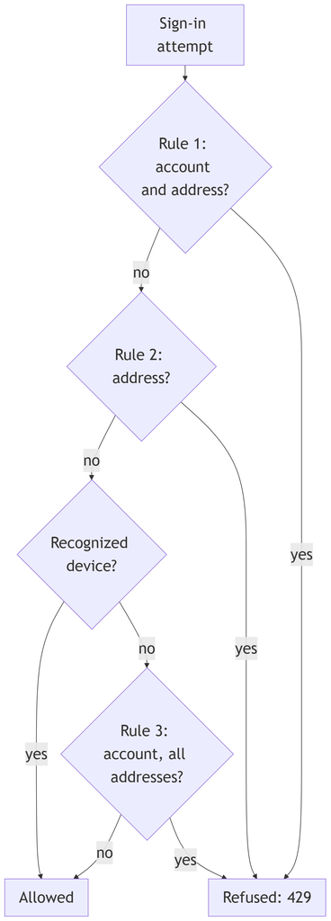

*Figure 16.1 — The three sign-in rules and the recognized-device exemption in `LoginThrottle.checkAllowed`*

*Text description:* A top-to-bottom decision flow with two ends. An attempt meets rule 1 (five or more failures for this account from this address), then rule 2 (twenty or more failures from this address), then asks whether the device is recognized. A recognized device goes straight to "Allowed," while an unrecognized one also meets rule 3 (twenty failures for the account from all addresses). A "yes" at any of the three rules leads to one refusal box, a `429` with `Retry-After`; an allowed attempt is counted in advance and then its password is checked.

The first two rules apply to everyone, including a recognized device: that is why someone sharing the owner's network address still can't guess freely. Only the third rule, the account-wide one, is skipped for a device the account has recently used, which is what stops a stranger from locking the owner out of their usual device.

**The check-then-act race.** The obvious way to write this is: (1) check whether the caller is locked out; (2) verify the password; (3) if wrong, record a failure. There is a gap between steps 1 and 3, and a password check takes about a tenth of a second. An attacker who sends many guesses at the same moment gets them *all* past step 1 before any reaches step 3, so a limit of five doesn't stop nine simultaneous guesses. This is a **race condition**: the result depends on the timing of things that happen at once.

**The incident.** During the final review rounds, the AI technical-manager reviewer (Chapter 32 explains how the reviews worked) asked whether the sign-in protection would survive a serious external review. It then ran a live probe: nine concurrent wrong passwords for one account from one address, with a limit of five. All nine received `401` (their passwords were actually checked) and only the next single attempt got `429`. The cause was exactly the check-then-act gap described earlier in this section. The fix, in commit `708fd8c`, is the code in Listing 16.6: reserve the attempt *before* checking the password, and hand the reservation back on success.

**Listing 16.6 — `LoginThrottle.java` (`book-m6-final`, excerpt: methods `reserve` and `succeeded`)**

```java
public synchronized Instant reserve(String username, String clientIp, boolean recognisedDevice) {
    checkAllowed(username, clientIp, recognisedDevice);
    Instant at = clock.instant();
    recordFailure(username, clientIp, at);
    return at;
}

/** The reserved attempt succeeded: hand back its provisional failure and clear this address's account counter. */
public synchronized void succeeded(String username, String clientIp, Instant reservation) {
    failures.remove(accountKey(username, clientIp));
    removeOne(ipKey(clientIp), reservation);
    removeOne(anyIpKey(username), reservation);
}
```

*Path: `src/main/java/com/example/securedocviewer/security/LoginThrottle.java`*

`synchronized` is a Java keyword meaning "only one thread at a time may run this method on this object." `reserve` therefore checks *and* counts as one indivisible step: the second of nine simultaneous callers can't check until the first has counted. Every attempt is counted as a failure in advance; a correct password calls `succeeded`, which removes that provisional failure and clears the account-and-address counter. The class comment states the guarantee: "a burst of parallel guesses can't all pass the check before any of them is counted." After the fix, the same probe let exactly five through. The test `aBurstOfParallelWrongPasswordsGetsNoMoreThanTheLimit` (Chapter 18, Section 18.10) is the regression guard, and **the lesson generalizes: a check followed by an action is a race unless something makes the two one step.**

Two limits of the design are stated in the class comment: the counters live in memory (a restart clears them), and attempts refused by a lock aren't counted, so being locked out doesn't extend the lock. A `@Scheduled` sweep every five minutes drops counters whose failures have all aged out (Chapter 14).

**A lockout is also an attack surface.** The first version of the account-wide rule locked an account after 20 failures from *any* addresses. The reviewer then pointed out that this lets anyone lock out any user: fail 20 times as the victim from a few addresses and the real owner can't sign in. The project's answer is the **recognized device**. `KnownDevices` remembers, for 30 days, addresses an account has *successfully* signed in from, and the account-wide rule doesn't apply to those. An attacker hammering a username from elsewhere therefore can't lock the owner out of their usual device, while the per-address rule still applies to everyone. Because an address is personal data, only a keyed hash of it is stored (IPv6 addresses grouped by their /64 prefix, since one device rotates addresses within a prefix). Entries expire after 30 days, and they are forgotten when the password changes or the account is disabled. The trade-off is documented: the correct password from a *new* address is refused during an account-wide lockout until an administrator unlocks the account.

### 16.7 Trusting `X-Forwarded-For` only from a proxy

Throttling by address needs the real client address. In a deployment the connection reaches the app through a reverse proxy (a server that receives requests on the app's behalf and forwards them, covered in Part V), so the address on the connection is the proxy's. The original address travels in a header, `X-Forwarded-For`. But any client can write that header. If the app believes it blindly, an attacker can send a different fake address with every attempt and never hit a per-address limit.

*Pattern note: A proxy that owns the trust boundary is the gateway pattern (Chapter 39, Section 39.7).*

**Listing 16.7 — `application.yml` (`book-m6-final`, excerpt: the forwarded-header settings)**

```yaml
server:
  port: 8080
  # Set to "native" only when running behind a trusted reverse proxy (the
  # docker-compose "full" profile does); otherwise X-Forwarded-For is ignored,
  # so clients can't spoof their IP to dodge login throttling.
  forward-headers-strategy: ${FORWARD_HEADERS_STRATEGY:none}
  tomcat:
    remoteip:
      # Which peers may set X-Forwarded-For. Compose pins this to the nginx
      # container's fixed address, so nothing else on the network can spoof it.
      internal-proxies: ${TRUSTED_PROXY_REGEX:127\.0\.0\.1|0:0:0:0:0:0:0:1}
```

*Path: `src/main/resources/application.yml`*

The default, `none`, ignores the header entirely: safe when the app is reached directly. Behind the project's own proxy, the setting becomes `native`, and `internal-proxies` says *which* peers Tomcat may believe; the deployment pins it to the proxy's fixed address. Only then does `request.getRemoteAddr()`, which `AuthController` uses, return the forwarded client address.

**The incident.** An earlier version of the deployment did the opposite of what the setting says: nginx *appended* to an `X-Forwarded-For` header the client had supplied, and the app trusted it, so a client could reset its sign-in lockout by sending a fake address. The description of the pull request that introduced this had claimed direct callers couldn't spoof; that claim was false, and the pull request text was corrected in place. The reviewer found it by testing through the real proxy. The fix made nginx overwrite the header with the real peer address, and a later change made the app trust the header only from the proxy's fixed address. A browser test that goes through nginx now guards it. The lesson: **a header a proxy sets is only as trustworthy as the proxy's configuration, so test through the proxy, not around it.**

The tests inside the Java project can't exercise a proxy, but they follow the principle in a small way. `SecurityIntegrationTest` gives every test that causes failures its own address with a helper `from("198.51.100.61")`, whose comment says why: "Tests that cause failures use their own address, so they don't use up 127.0.0.1's allowance."

### 16.8 Forced password change

An account whose password an administrator set, or whose first password was generated and printed in a log, must choose its own at first sign-in. The check that the UI redirects to a password form is a convenience; the *enforcement* is on the server, in `PasswordChangeRequiredFilter`.

**Listing 16.8 — `PasswordChangeRequiredFilter.java` (`book-m6-final`, excerpt: the check in `doFilterInternal`)**

```java
HttpSession session = request.getSession(false);
String path = request.getRequestURI().substring(request.getContextPath().length());
if (session != null && Boolean.TRUE.equals(session.getAttribute(SESSION_ATTRIBUTE))
        && path.startsWith("/api/") && !path.startsWith("/api/auth/")) {
    response.setStatus(HttpServletResponse.SC_FORBIDDEN);
    response.setContentType(MediaType.APPLICATION_JSON_VALUE);
    response.getWriter().write("{\"error\":\"You must change your password before continuing.\",\"passwordChangeRequired\":true}");
    return;
}
chain.doFilter(request, response);
```

*Path: `src/main/java/com/example/securedocviewer/security/PasswordChangeRequiredFilter.java`*

While the session's flag `sdv.mustChangePassword` is set (Chapter 15's Step 7), everything under `/api/` gets a `403` with an explanation and `passwordChangeRequired: true`. The exception is the `/api/auth/` endpoints, where the user can look up who they are, change the password, or sign out. Note the `return` without `chain.doFilter`: the request stops here. Both custom filters are added around Spring's `AuthorizationFilter` in `SecurityConfig`: the lifetime filter before it and this one after it. Figure 16.2 shows where the two filters sit among the others.

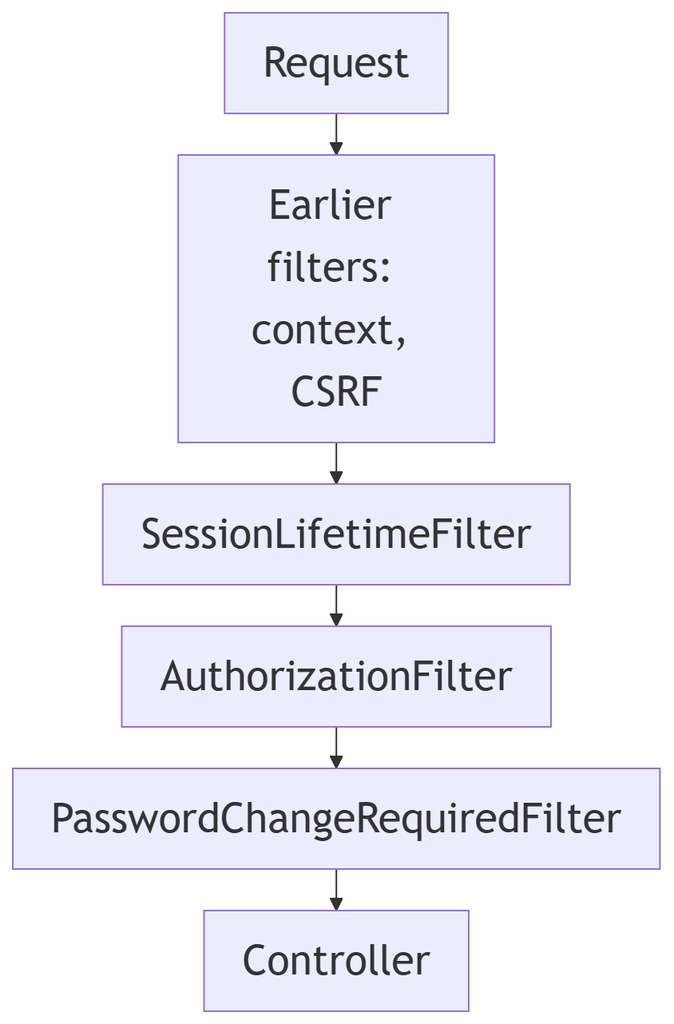

*Figure 16.2 — Where the project's two custom filters sit in the chain*

*Text description:* A top-to-bottom chain of six boxes: the request, the earlier Spring Security filters, `SessionLifetimeFilter`, `AuthorizationFilter`, `PasswordChangeRequiredFilter`, and finally the controller. Notice that the lifetime filter comes before the authorization rules and the password-change filter comes after them.

The order explains the behavior. The lifetime filter runs before the authorization rules, so a session that has outlived its fixed lifetime looks anonymous by the time the rules are applied, and the caller gets the ordinary `401`. The password-change filter runs after them, so it only ever sees requests that authorization has let through, and it blocks those that belong to an account still waiting to choose a password. The test `anAdminSetPasswordMustBeChangedBeforeAnythingElseWorks` walks through the story: an administrator creates a user, the user signs in and is told a change is needed, `GET /api/documents` returns `403` with the flag, `GET /api/auth/me` still works, and after `POST /api/auth/password` the documents endpoint returns `200`.

Changing a password is itself guarded. The endpoint reserves an attempt from the same `LoginThrottle` before checking the current password, because a stolen session shouldn't be a free way to guess it. The commit that added atomic sign-in counting closed this gap too. A successful change also ends the user's other sessions, so anyone who had the old password is signed out.

### 16.9 A real incident: the CSRF cookie that vanished at sign-in

Section 16.2's design had a bug that only a browser could see. At sign-in, Spring's built-in step for rotating the CSRF token (part of protecting against session fixation) deleted the cookie and then re-read the token from the request, which still carried the *old* cookie. The browser ended with no token, and the first write after signing in failed with `403`. It was found in a live check against a real database while building the first accounts milestone. `AuthController` now generates and saves a fresh token itself, so exactly one `Set-Cookie` is sent (its comment on `rotateCsrfToken` explains this), and `CsrfCookieFlowTest` reproduces the browser's steps to guard it. Chapter 18, Section 18.8, explains why the ordinary test helper could never have caught it.

### 16.10 Common mistakes

- **Leaving a path open by omission.** Without `anyRequest().denyAll()`, a new endpoint could be reachable by default. Deny first; open on purpose.
- **Ordering rules wrongly.** A broad rule listed before a specific one shadows it. Put the specific rules first.
- **Answering 403 when you mean "doesn't exist."** It confirms the resource is real. Return `404` when the caller has no right to know.
- **Trusting `X-Forwarded-For` everywhere.** Trust it from a named proxy only.
- **Counting after checking.** Any limit that checks first and counts later can be beaten with parallel requests.
- **Building a lockout with no exceptions.** An attacker can use it against the victim; think about who else could trigger it.
- **Hiding a button and calling it security.** The UI conceals what a role can't use, but the server enforces it on every request. Test the server path, as `readersCannotReachAdminOrUpload` does.
- **Testing security with the shortcut helpers only.** See Chapter 18, Section 18.8.

## In this project

Table 16.3 — Where Chapter 16's ideas live (`book-m6-final`)

| Idea | File |
| --- | --- |
| CSRF | `security/SecurityConfig.java`, `security/SpaCsrfTokenRequestHandler.java`, `controller/AuthController.java` |
| Rules and headers | `security/SecurityConfig.java` |
| Filter-chain JSON errors | `security/SecurityErrorResponses.java` |
| Throttling and recognized devices | `security/LoginThrottle.java`, `security/KnownDevices.java` |
| Session filters and revocation | `security/SessionLifetimeFilter.java`, `security/PasswordChangeRequiredFilter.java`, `security/SessionAdministration.java` |
| Proxy trust, cookie, and timeout settings | `src/main/resources/application.yml` |

Part IV's chapters on milestones 1, 3, and 5 (Chapters 26, 28, and 30) tell when each defense arrived and why.

## Try it

### Exercise 16.1 ★ What does `denyAll()` do?

In Listing 16.3, what happens to a request for `GET /api/does-not-exist` from a signed-in reader? What about `GET /somewhere-else` from anyone? Which rule matches each?

*Solution:* Appendix C, Exercise 16.1.

### Exercise 16.2 ★ Two cookies, two rules

Explain in your own words why the `XSRF-TOKEN` cookie is readable by JavaScript while `SDV_SESSION` is not, and why that difference is safe.

*Solution:* Appendix C, Exercise 16.2.

### Exercise 16.3 ★★ Read the headers on your own copy

Start your own local copy of the app and use `curl -i` (Chapter 8) on `/api/auth/me` without signing in. List every security header in the response and match each to a row of Table 16.1. Which header, if missing, would you notice last, and why?

*Solution:* Appendix C, Exercise 16.3.

### Exercise 16.4 ★★ 404 or 403?

For each request, say which status the server returns and why: (a) a reader asks for a private document that belongs to someone else; (b) a reader asks to share a document that is visible to everyone; (c) a reader asks for the admin audit log; (d) no one is signed in and asks for `/api/documents`.

*Hint:* the answers involve two different layers, the rules in `SecurityConfig` and the checks in `DocumentService`.

*Solution:* Appendix C, Exercise 16.4.

### Exercise 16.5 ★★★ Break the throttle in a scratch copy

On a scratch branch, change `LoginThrottle.reserve` so it calls `checkAllowed` but records the failure only *after* `authenticate` fails (a check-then-act design). Run `aBurstOfParallelWrongPasswordsGetsNoMoreThanTheLimit`. What do you observe? Explain why the original passes and yours doesn't.

*Solution:* Appendix C, Exercise 16.5 (a worked outline).

### Exercise 16.6 ★★★ Design a lockout that can't be abused

Suppose you must protect a "reset PIN" endpoint that allows 3 attempts. Design the counting so that (a) parallel guesses can't exceed 3, and (b) a stranger can't lock the real owner out for good. Say what you count, where you store it, and what happens to a legitimate owner who is locked out.

*Solution:* Appendix C, Exercise 16.6 (a worked outline).

## Summary

- CSRF lets another site borrow your cookie; the project defends with a readable `XSRF-TOKEN` cookie that the app copies into an `X-XSRF-TOKEN` header, which a foreign site can't do.
- Authorization is deny-by-default, with coarse role rules in `SecurityConfig` (first match wins, specific before general) and per-document rules in the service; a document you can't see is reported as not found.
- Security headers instruct the browser to load nothing from the API, refuse framing, and never leak signed URLs in a `Referer`.
- Sessions end by idle timeout, by a fixed maximum lifetime and by administrator revocation; every session is registered so it can be listed and ended.
- `LoginThrottle` reserves each attempt atomically before checking the password; recognized devices stop a lockout from being turned against its owner.
- `X-Forwarded-For` is trusted only from a configured proxy address.
- The forced password change is enforced by a server-side filter, and every one of these defenses has a test.

## Further reading

- *Spring Security Reference Documentation*, "Cross Site Request Forgery (CSRF)." https://docs.spring.io/spring-security/reference/servlet/exploits/csrf.html
- *Spring Security Reference Documentation*, "Authorize HttpServletRequests." https://docs.spring.io/spring-security/reference/servlet/authorization/authorize-http-requests.html
- *Spring Security Reference Documentation*, "Security HTTP Response Headers." https://docs.spring.io/spring-security/reference/servlet/exploits/headers.html
- *OWASP Cheat Sheet Series*, "Cross-Site Request Forgery Prevention Cheat Sheet." https://cheatsheetseries.owasp.org/cheatsheets/Cross-Site_Request_Forgery_Prevention_Cheat_Sheet.html
- *OWASP Cheat Sheet Series*, "Authentication Cheat Sheet." https://cheatsheetseries.owasp.org/cheatsheets/Authentication_Cheat_Sheet.html
- *MDN Web Docs*, "Content Security Policy (CSP)." https://developer.mozilla.org/en-US/docs/Web/HTTP/CSP

# Chapter 17: Files, images, PDFs, and signatures

The heart of the Secure Document Viewer is that the browser never receives your PDF. The server turns each page into a picture, cuts it into small square tiles, stamps the viewer's identity on each tile, and serves them through links that cannot be forged. This chapter teaches the pieces: pixels and images, drawing a PDF page, slicing, drawing text, signing links, limiting how much work runs at once, and handling files on disk so that a failure never leaves a mess.

## Learning objectives

By the end of this chapter, you will be able to:

- Explain what pixels and a PNG image are, and estimate how much memory a rendered page needs.
- Explain how a page image is sliced into a grid of tiles, work out the grid for a given page, and say why edge tiles are cropped.
- Read the rendering loop in `TileGenerationService` and the drawing code in `WatermarkService`.
- Explain what a hash, an HMAC (hash-based message authentication code) and a signed token are, and say what each field of a tile token protects against.
- Explain why the server limits how much work runs at once, and how a semaphore does it.
- Describe how uploaded files are staged, committed, versioned, and cleaned up, and why the order of the steps matters.

## Prerequisites

- Chapter 3: your first Java program (integer division)
- Chapter 5: collections, lambdas, and exceptions
- Chapter 11: Spring Boot foundations
- Chapter 12: REST controllers and JSON
- Chapter 13: Validation, configuration properties, and errors (`BadRequestException`, the upload limits)
- Chapter 15: Spring Security I (what a hash is)

## Beginner tier: Pictures and grids

### 17.1 Pixels, images, and PNG

A digital image is a grid of **pixels**, tiny colored squares. A page rendered at 150 **dots per inch (DPI)**, the project's `render-dpi: 150` in `application.yml`, has 150 pixels for every inch of paper. An A4 sheet is about 8.27 by 11.69 inches, so the arithmetic is width in inches times DPI: about 1,240 by 1,754 pixels.

**PNG** is a file format that stores such a grid compressed *without losing detail*, which suits pages full of text and sharp lines. (JPEG, the format for photographs, discards detail to save space, and blurs text edges.) In Java, `BufferedImage` is the in-memory grid you read pixels from and draw on.

The in-memory form matters more than the file form, because it is what the server holds while it works. Java's common in-memory format uses about four bytes per pixel. That gives a **worked example** for how much memory one rendered page takes:

Table 17.1 — Memory for one rendered page, at about 4 bytes per pixel

| Page | Pixels | Approximate memory |
| --- | --- | --- |
| A4 at 150 DPI (1,240 × 1,754) | 2,174,960 | 8.7 MB |
| The project's limit, `max-page-pixels` | 40,000,000 | 160 MB |

A normal page costs under 10 MB. A page at the limit costs about 160 MB, and two renders may run at once. This is why the limit exists and why it's a *pixel count*, not a page size: a poster-sized page at a high DPI could take gigabytes, and the server would fail before it finished (Chapter 13 shows the check).

Why turn a PDF into pictures at all? A PDF in the browser can be saved, copied and searched. A stack of image tiles can't be saved as a document with one click; it must be reassembled. The project is honest that this raises the effort of copying rather than making it impossible: someone can still photograph the screen. What the design guarantees is that every tile that leaves the server has the viewer's identity drawn into it, and that access can be cut off.

### 17.2 Reading and rendering a PDF

Turning a PDF page into a `BufferedImage` is called **rasterizing**. A PDF describes a page as instructions ("draw this text here, this image there"), and rasterizing carries them out onto a grid of pixels. The project uses the Apache PDFBox library (version 3.0.8, from `pom.xml`), which can open a PDF and draw a page at a chosen DPI. `TileGenerationService` does the work. Listing 17.1 shows the heart of it, and the checks that guard it.

**Listing 17.1 — `TileGenerationService.java` (`book-m6-final`, simplified: the surrounding methods, error handling, and the tile-saving helper are omitted; the two excerpts are from different places in the class)**

```java
try (PDDocument document = loadPdf(source)) {
    requireWithinLimits(document);
    PDFRenderer renderer = new PDFRenderer(document);
    // Decode huge embedded images at reduced resolution instead of in full.
    renderer.setSubsamplingAllowed(true);
    for (int pageIndex = 0; pageIndex < document.getNumberOfPages(); pageIndex++) {
        if (cancelled.get() || Thread.currentThread().isInterrupted()) {
            throw new CancellationException("Render abandoned after render-timeout");
        }
        BufferedImage rendered = renderer.renderImageWithDPI(pageIndex, properties.getRenderDpi());
        pages.add(tileAndSave(stagingDir.resolve("page-" + pageIndex), pageIndex, rendered));
    }
}

// ... elsewhere in the class ...

private void requireWithinLimits(PDDocument document) {
    int pageCount = document.getNumberOfPages();
    if (pageCount == 0) {
        throw new BadRequestException("The PDF has no pages.");
    }
    if (pageCount > properties.getMaxPages()) {
        throw new BadRequestException("The PDF has " + pageCount + " pages; the limit is "
                + properties.getMaxPages() + ".");
    }
    // ... a per-page pixel-size check follows ...
}
```

*Path: `src/main/java/com/example/securedocviewer/service/TileGenerationService.java`*

The method opens the PDF, checks it against the limits before drawing anything, and creates a `PDFRenderer`. Then it loops over the pages: `renderImageWithDPI(pageIndex, properties.getRenderDpi())` draws one page as a `BufferedImage` at 150 DPI, and `tileAndSave` (Section 17.3) slices it and writes the tiles into a per-page directory in a staging area. The `try (...)` closes the PDF when the loop ends, even on error (Chapter 5).

Three details are worth a closer look. First, `setSubsamplingAllowed(true)` lets PDFBox decode an enormous embedded photo at reduced resolution instead of in full, since the output is only 150 DPI anyway; the comment says so. Second, before each page the loop checks a `cancelled` flag, so a render that exceeds `render-timeout` can be abandoned at the next page boundary and free its slot (Section 17.6). Third, the PDF is loaded from a file on disk, not from memory. The upload is streamed into a temporary file first, and `loadPdf` uses a temp-file cache because, as its comment says, "large PDFs are buffered on disk, not in the heap." (The **heap** is the region of memory where Java keeps its objects.)

### 17.3 Slicing an image into a grid

Serving a whole page as one image would hand over everything in one request. Tiles are small: `tile-size: 512` pixels square at the final tag. `TileGrid` is the pure arithmetic, kept separate so it can be tested without any PDF (Chapter 18).

**Listing 17.2 — `TileGrid.java` (`book-m0-mvp`, identical at `book-m6-final`; imports and the class comment are omitted)**

```java
public final class TileGrid {

    private TileGrid() {
    }

    /** Number of tiles needed to cover {@code lengthPx} pixels: ceil(lengthPx / tileSize). */
    public static int tileCount(int lengthPx, int tileSize) {
        if (lengthPx <= 0 || tileSize <= 0) {
            throw new IllegalArgumentException("lengthPx and tileSize must both be positive");
        }
        return (lengthPx + tileSize - 1) / tileSize;
    }

    /** Extracts a single tile, cropped to the image bounds at the right/bottom edges. */
    public static BufferedImage sliceTile(BufferedImage page, int row, int col, int tileSize) {
        int x = col * tileSize;
        int y = row * tileSize;
        if (x >= page.getWidth() || y >= page.getHeight()) {
            throw new IllegalArgumentException("Tile (" + row + "," + col + ") is outside the image bounds");
        }
        int w = Math.min(tileSize, page.getWidth() - x);
        int h = Math.min(tileSize, page.getHeight() - y);
        return page.getSubimage(x, y, w, h);
    }
}
```

*Path: `src/main/java/com/example/securedocviewer/service/TileGrid.java`*

`tileCount` rounds up. Integer division in Java drops the remainder (Chapter 3), so adding `tileSize - 1` before dividing is the standard round-up trick: `(1240 + 511) / 512` is `1751 / 512`, which is 3 (the remainder is dropped). `sliceTile` computes the top-left corner from row and column (`x = col * tileSize`), then takes the smaller of a full tile and what remains, so the last tiles are cropped rather than padded. The class comment states the payoff: reassembling every tile at `(col * tileSize, row * tileSize)` "reproduces the source image exactly, with no seams, and no bleed." The private constructor stops anyone creating an object of a class that only holds static methods.

**A worked example.** Take the A4 page from Section 17.1, 1,240 by 1,754 pixels, and 512-pixel tiles.

Table 17.2 — The tile grid for one A4 page at 150 DPI with 512-pixel tiles

| Direction | Calculation | Result | Sizes of the tiles |
| --- | --- | --- | --- |
| Columns | `tileCount(1240, 512)` | 3 | 512, 512, and 1240 − 1024 = 216 |
| Rows | `tileCount(1754, 512)` | 4 | 512, 512, 512, and 1754 − 1536 = 218 |

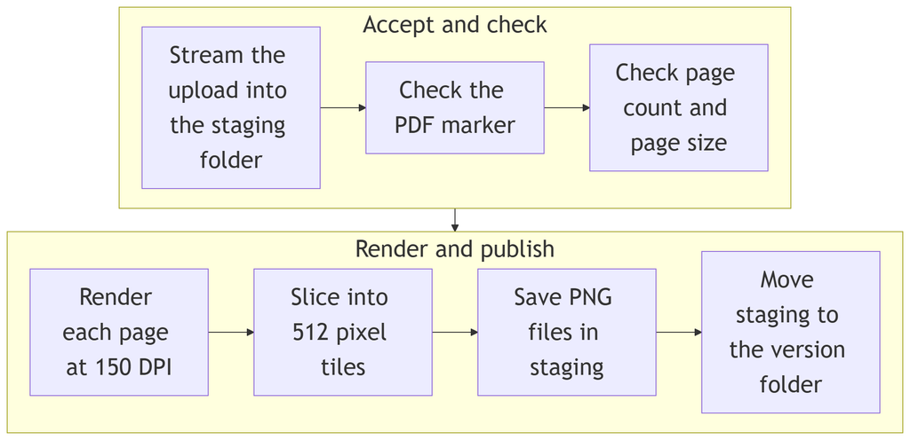

*Figure 17.1 — How an uploaded PDF becomes tiles on disk*

*Text description:* A chain in two rows, read left to right and then down, with seven boxes. The upload is streamed into a staging folder, the PDF marker is checked, and the PDF is opened and checked for page count and size. Each page is then rendered at 150 DPI, sliced into 512-pixel tiles, and saved as PNG files. Finally the staging folder is moved to the version folder in one step. The cheap checks come first and the expensive rendering last.

The cheap checks come first (the marker, then the page count and size), and the expensive work, rendering, comes only after they pass. Everything is written into a staging folder that no reader can see, and the last step makes it visible in a single move (Section 17.7).

The tiles are written by `tileAndSave`, which calls `sliceTile` for each `(row, col)` and saves a PNG named for its position.

**Listing 17.3 — `TileGenerationService.tileAndSave` (`book-m6-final`, excerpt: the loop)**

```java
Files.createDirectories(pageDir);
for (int row = 0; row < rows; row++) {
    for (int col = 0; col < cols; col++) {
        BufferedImage tile = TileGrid.sliceTile(pageImage, row, col, tileSize);
        File tileFile = pageDir.resolve("tile-" + row + "_" + col + ".png").toFile();
        ImageIO.write(tile, "png", tileFile);
    }
}
```

*Path: `src/main/java/com/example/securedocviewer/service/TileGenerationService.java`*

On disk, a document ends up as a tree like this, where `v1` is the render's version (Section 17.7):

```
storage/
  <document-id>/
    v1/
      page-0/
        tile-0_0.png   tile-0_1.png   tile-0_2.png
        tile-1_0.png   ...
      page-1/
        ...
```

### 17.4 Drawing text on an image (watermarks)

A watermark is text drawn into the picture. Here it shows the viewer, a timestamp in UTC (Coordinated Universal Time) and a short trace code that matches the session column of the audit log, so a leaked screenshot points back to a sign-in (a comment in `application.yml` says so). Its look is configurable: `watermark-opacity: 0.2` and `watermark-spacing: 1.5`, the gap between copies as a multiple of the text height. `WatermarkService` does the drawing, and `TileController` applies it to each tile at request time (Chapter 12). The class comment gives the reason for stamping on the way out rather than during upload: "one stored tile serves every viewer, and every response is still individually traceable back to who requested it and when."

**Listing 17.4 — `WatermarkService.applyWatermark` (`book-m6-final`, simplified: the long explanatory comments, the tile-sizing lines, and the closing lines are omitted)**

```java
public BufferedImage applyWatermark(BufferedImage source, String viewerLabel, String traceCode, int nominalTileSize) {
    int width = source.getWidth();
    int height = source.getHeight();
    BufferedImage stamped = new BufferedImage(width, height, BufferedImage.TYPE_INT_ARGB);

    Graphics2D g = stamped.createGraphics();
    try {
        g.setRenderingHint(RenderingHints.KEY_ANTIALIASING, RenderingHints.VALUE_ANTIALIAS_ON);
        g.setRenderingHint(RenderingHints.KEY_TEXT_ANTIALIASING, RenderingHints.VALUE_TEXT_ANTIALIAS_ON);
        g.drawImage(source, 0, 0, null);

        String stamp = TIMESTAMP_FORMAT.format(Instant.now());
        String[] lines = {viewerLabel, traceCode == null ? stamp : stamp + " · " + traceCode};
        // ... choose the font size and compute the spacing (Layout) ...
        g.setComposite(AlphaComposite.getInstance(AlphaComposite.SRC_OVER, opacity));
        g.setColor(Color.RED);
        g.rotate(-Math.PI / 6);
        // ... a loop draws each line at every step of a brick pattern ...
    } finally {
        g.dispose();
    }

    return stamped;
}
```

*Path: `src/main/java/com/example/securedocviewer/service/WatermarkService.java`*

Reading it through: the method creates a new image the same size as the tile and gets a `Graphics2D`, Java's drawing object. It first draws the original tile onto it, then builds two lines of text, the viewer's name and the UTC time (plus the trace code when one is given). It sets a translucent red ink (`opacity`, 0.2 by default) and rotates the drawing surface by 30 degrees (`-Math.PI / 6` radians). A loop, left out here, repeats the two lines across the whole tile in a brick pattern. The `finally` calls `g.dispose()` to release the drawing resources even if something fails.

The repetition is deliberate. Edge tiles are cropped shorter than full ones (Section 17.3), so a single centered mark could land entirely outside a small tile. The source comment explains: repeating the mark "so every tile carries some of it — and a full-size tile carries at least one complete, readable copy." The settings are also clamped inside the service (opacity between 0.05 and 0.6, spacing between 0.5 and 6.0), so a mistaken configuration can't make the mark invisible or overwhelming.

The layout came from a real bug in the first version: copies were spaced a fixed 150 pixels apart, but the label was about 400 pixels wide, so they overprinted and became unreadable. The fix measures the text and derives the spacing from it (`Layout`), splits the label into two short lines, and adds a test that fails if copies overlap (`adjacentCopiesNeverOverprintEachOther` in `WatermarkServiceTest`). The lesson: **derive a layout from the measured content, not from a guess, and add a regression test.**

## Intermediate tier: Proving a link wasn't altered

*If you're reading for the first time, Section 17.5 is the most important one here; 17.6 and 17.7 are about resource limits and files.*

### 17.5 Hashes, HMAC, and signatures: proving a URL wasn't altered

The browser asks for tiles by URL, and anyone could type a different tile or document number into a URL. The server needs a way to hand out links only *it* can create. Here is the idea through an analogy. A signed tile URL works like a wristband at a concert. The box office (the server) checks your ticket once, then gives you a wristband printed with today's date and a hologram that only the box office can make. Security at each door (each tile request) doesn't phone the box office; it checks the hologram and the date.

**Where the analogy breaks down:** a wristband works for anyone wearing it, but a tile URL is also bound to your session: pasted into another browser, it's refused. And a wristband lasts all night, while a tile URL expires after two minutes.

Now the precise version. A hash (Chapter 15) is a fixed-length fingerprint of some data. An HMAC (hash-based message authentication code) is a hash computed from a message *and a secret key*, here with the algorithm HmacSHA256. Without the key, nobody can produce the right fingerprint for a message, and if you change a single character of the message, the fingerprint changes completely. The project's **signed token** is the message plus its fingerprint. What is the message? `SignedTilePayload` says.

**Listing 17.5 — `SignedTilePayload.java` (`book-m6-final`, simplified: the comments and imports are omitted)**

```java
public record SignedTilePayload(
        String documentId,
        int page,
        int row,
        int col,
        int tileVersion,
        String sessionBinding,
        long expiresAtEpochSeconds
) {
    public String canonicalString() {
        return documentId + "|" + page + "|" + row + "|" + col + "|" + tileVersion + "|" + sessionBinding + "|" + expiresAtEpochSeconds;
    }
}
```

*Path: `src/main/java/com/example/securedocviewer/model/SignedTilePayload.java`*

The **canonical string** is the seven fields joined in a fixed order with `|` between them. Signing needs *one exact text* to sign, and the fixed order and separator give that. Each field closes a specific hole, which Table 17.3 spells out.

Table 17.3 — What each field of a tile token protects against

| Field | What it stops |
| --- | --- |
| `documentId`, `page`, `row`, `col` | Using a token for one tile to fetch a different tile |
| `tileVersion` | A stale link showing a tile from a replaced PDF, mixing old and new pages |
| `sessionBinding` | Pasting a link into another browser or account (it is derived from the session, not the id itself) |
| `expiresAtEpochSeconds` | Using a link long after it was issued (the lifetime is `url-ttl-seconds`, 120 by default) |

A worked example of a token, with placeholders (a teaching example, not a real token):

**Example 17.1 — The shape of a token (teaching example)**

```
<base64url(payload)>.<base64url(hmac-of-payload)>

payload, once decoded:
<document-id>|2|1|0|1|<session-binding>|1790000120
```

The two halves are joined with a dot. **base64url** is a way to write arbitrary bytes using only letters, digits, and two symbols, so the token is safe inside a URL. Anyone can decode the first half and read the fields, so a token is *not secret*; what matters is that nobody without the key can produce a matching second half. Now the code that issues and verifies it.

**Listing 17.6 — `SignedUrlService.java` (`book-m6-final`, simplified: `parseCanonical`, the helper methods, and comments are omitted)**

```java
public String issueToken(String documentId, int page, int row, int col, int tileVersion, String sessionBinding) {
    long expiresAt = Instant.now().getEpochSecond() + properties.getUrlTtlSeconds();
    SignedTilePayload payload = new SignedTilePayload(documentId, page, row, col, tileVersion, sessionBinding, expiresAt);
    String payloadEncoded = base64Url(payload.canonicalString().getBytes(StandardCharsets.UTF_8));
    String signature = base64Url(hmac(payload.canonicalString()));
    return payloadEncoded + "." + signature;
}

public SignedTilePayload verifyAndDecode(String token) {
    String[] parts = token.split("\\.", 2);
    if (parts.length != 2) {
        throw new InvalidTokenException("Malformed token");
    }
    // ... decode the payload; a bad encoding throws InvalidTokenException ...
    String expectedSignature = base64Url(hmac(canonical));
    if (!constantTimeEquals(expectedSignature, providedSignature)) {
        throw new InvalidTokenException("Signature mismatch — token was tampered with or forged");
    }

    SignedTilePayload payload = parseCanonical(canonical);
    if (Instant.now().getEpochSecond() > payload.expiresAtEpochSeconds()) {
        throw new InvalidTokenException("Token expired at " + Instant.ofEpochSecond(payload.expiresAtEpochSeconds()));
    }

    return payload;
}
```

*Path: `src/main/java/com/example/securedocviewer/service/SignedUrlService.java`*

Read it as a recipe. `issueToken` fills in one tile's details plus an expiry time (now plus the configured lifetime), writes them as one canonical string, encodes it, and appends the HMAC. `verifyAndDecode` splits the token at the dot, recomputes the HMAC from the received payload with its own key, and compares. A mismatch means the token was altered or forged, so it is refused with `InvalidTokenException`, which `GlobalExceptionHandler` maps to `401`. Only after the signature checks out is the payload parsed and the expiry compared with the clock.

Two details matter. The first is a **constant-time comparison**, a check whose running time does not depend on how many characters match. `constantTimeEquals` compares with `MessageDigest.isEqual`, which takes the same time however many characters match. An attacker therefore can't learn a signature one character at a time by measuring how fast the server refuses ("Avoids leaking timing information about how much of the signature matched," per the source). And the signature covers every field, which the class comment states directly: holders "cannot forge a new one, extend it, or repurpose it for a different tile." The key never leaves the server, and `ViewerProperties` refuses to start without one at least 32 characters long (Chapter 13).

Figure 17.2 shows the life of a token: issued once for a whole page, then presented once per tile.

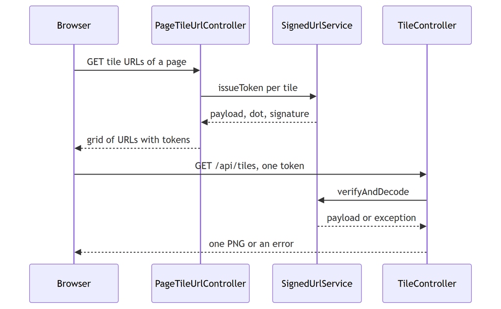

*Figure 17.2 — Issuing and checking a signed tile token*

*Text description:* A sequence with the browser, the URL controller, the signing service, and the tile controller. In the upper half the browser asks for a page's tile URLs and receives a grid whose URLs each carry a signed token. In the lower half the browser sends one token to the tile controller, which asks the signing service to verify it and returns either one PNG or an error status.

The server holds no list of issued tokens. Everything it needs to check a token is in the token itself and in its own secret key, which is why the check in the lower half of the figure is fast and needs no database.

**A stronger claim, and its limit.** Anyone who holds a valid token can use it until it expires; the HMAC proves it was issued by the server, not that the bearer is the right person. That's why `TileController` adds independent checks: the session binding, the rate limit, and a fresh access check on every request (Chapter 12 and Chapter 16). The signature is one layer of several, and Table 17.4 summarizes them at the end of the chapter.

### 17.6 Threads, pools, and limits: bounded work

Watermarking and encoding a tile uses the **CPU** (central processing unit), the processor that does the computing. Rendering a PDF uses a lot more, plus memory. A server serves many users at once, using threads: a thread is one line of work a program runs alongside others. If everyone's request needs a heavy step and there's no limit, a crowd of readers, or one hostile client, can make the machine slow for everyone. The remedy is to **bound** the work: allow so many at once, and refuse or delay the rest.

*Pattern note: A limit that keeps one part from exhausting everything else is the bulkhead pattern, and a render's lifecycle is a small state machine (Chapter 38, Sections 38.9 and 38.8).*

`TileWorkLimiter` bounds tile work across *all* users. The per-user rate limit (`TileRateLimiter`, Chapter 26) bounds each reader; this bounds the server. It uses a **semaphore**, a counter of permits: a task must take a permit to run and returns it when done. Picture a car park with a fixed number of spaces and a barrier. A car enters only if a space is free; otherwise it waits a moment and is turned away.

**Listing 17.7 — `TileWorkLimiter.run` (`book-m6-final`, class comment, and imports omitted)**

```java
public <T> T run(Callable<T> work) throws Exception {
    if (!slots.tryAcquire(WAIT_MILLIS, TimeUnit.MILLISECONDS)) {
        metrics.tileBusy();
        throw new ServiceBusyException("The server is busy. Retrying shortly.", 1);
    }
    try {
        return work.call();
    } finally {
        slots.release();
    }
}
```

*Path: `src/main/java/com/example/securedocviewer/service/TileWorkLimiter.java`*

`tryAcquire(WAIT_MILLIS, ...)` waits up to 2,000 milliseconds for a permit. If none frees up, the request is refused with `ServiceBusyException`, which becomes `503` with `Retry-After` (Chapter 12), and the viewer retries. The `finally` block returns the permit even if the work throws; forgetting it would slowly leak permits until the server refused everything. The number of permits comes from `max-concurrent-tile-renders`, where `0` means twice the CPU count. `Callable<T>` is a lambda-friendly interface (Chapter 5): the caller passes in the work as a small function, and the limiter runs it inside the permit.

The same idea limits PDF rendering, with more care, because a render can take minutes. `TileGenerationService` has a semaphore of `max-concurrent-renders` (2) permits. An upload waits up to `render-queue-timeout-seconds` (30) for a permit, and otherwise gets a `503`. The render itself runs on a *separate* thread from the one handling the request, so the request thread can give up when `render-timeout` (3 minutes) passes. The render then stops at its next page boundary, cleans up after itself, and only *then* returns its permit. The class comment explains why: "a permit is held until its render thread has actually stopped, so abandoned renders still count against `max-concurrent-renders` and can't pile up CPU or heap behind it."

The history explains the design. The first version had no time limit: a pathological PDF could hold one of the two render slots forever, so the AI technical-manager reviewer asked for one. The first fix added the time limit; a later round made the pool queue-free and made each slot stay held until its render had truly stopped. The lesson: **a limit that counts only the work you are waiting for lets abandoned work pile up unseen; count everything that is still running.**

### 17.7 Files on disk safely: staging, atomic move, cleanup

A database transaction can undo itself, but files can't join it. Uploading a document changes both, so the order of the steps decides what a crash leaves behind. The rule the project follows has three parts. *Do the risky work in a place nobody looks. Then make it visible in one step. Make sure every failure path removes the mess.* Listing 17.8 is the upload method, and its comments tell the story.

*Pattern note: Building in staging and switching in one step is the atomic switch idea (Chapter 39, Section 39.11).*

**Listing 17.8 — `DocumentService.upload` (`book-m6-final`)**

```java
public DocumentDetail upload(String rawTitle, String originalFilename, InputStream pdf, Visibility visibility,
                             Viewer viewer, Actor actor) throws IOException {
    String title = validTitle(rawTitle == null || rawTitle.isBlank() ? titleFromFilename(originalFilename) : rawTitle);
    RenderedDocument rendered = tiles.render(pdf);
    String documentId = UUID.randomUUID().toString();
    try {
        tiles.commit(rendered, documentId, 1);
    } catch (IOException | RuntimeException e) {
        tiles.discard(rendered);
        throw e;
    }
    try {
        DocumentDetail created = tx.execute(status -> {
            // Rendering can take a while: the uploader may have been demoted or disabled meanwhile.
            if (!currentRoles(viewer).publisher()) {
                throw new ForbiddenException("Only publishers and admins can upload documents.");
            }
            AppUser owner = users.findByUsername(viewer.username())
                    .orElseThrow(() -> new ResourceNotFoundException("No such user."));
            Document document = documents.save(new Document(documentId, title, owner,
                    visibility == null ? Visibility.PRIVATE : visibility,
                    1, rendered.tileSize(), toPages(rendered)));
            return detail(document, viewer);
        });
        audit.record(AuditEventType.DOCUMENT_UPLOADED, actor,
                Subject.document(documentId, title, rendered.pages().size() + " pages"));
        return created;
    } catch (RuntimeException e) {
        tiles.deleteTiles(documentId);
        throw e;
    }
}
```

*Path: `src/main/java/com/example/securedocviewer/document/DocumentService.java`*

Follow the failure paths. (1) `tiles.render(pdf)` writes everything into a **staging** directory, `.staging/<random-id>/`. If it fails, it deletes its own staging directory. Nobody can see half a render. (2) `tiles.commit(rendered, documentId, 1)` moves the finished render into the document's own folder as version 1. If *that* fails, `tiles.discard` removes the staging copy. (3) The database row is saved inside a short transaction (Chapter 14). If that fails (for example the uploader was demoted while the render ran), the outer `catch` calls `tiles.deleteTiles(documentId)`, removing the committed tiles, because no row points at them. (4) Only after the row exists is the audit event recorded.

The move in step 2 deserves its own attention, because a half-finished move is the worst case.

**Listing 17.9 — `TileGenerationService.commit` (`book-m6-final`)**

```java
public void commit(RenderedDocument rendered, String documentId, int version) throws IOException {
    Path target = versionRoot(documentId, version);
    if (Files.exists(target)) {
        throw new IOException("Tile version already exists: " + target);
    }
    Files.createDirectories(target.getParent());
    FileOperations.moveDirectory(rendered.stagingDir(), target);
}
```

*Path: `src/main/java/com/example/securedocviewer/service/TileGenerationService.java`*

The method refuses to write into a folder that already exists, so a new render can never mix with an old one. And `moveDirectory` renames the whole staging folder to its final name. A rename within one file system is atomic: it either happens completely or not at all, so a reader never sees a folder that is half moved. `FileOperations` uses the operating system's atomic rename (`StandardCopyOption.ATOMIC_MOVE`), and retries it briefly if the file system reports a lock.

**A real incident: locked folders on Windows.** The project was first built in a folder synchronized by OneDrive. Sync clients and antivirus scanners briefly hold files that were written a moment earlier, so renames and deletes of tile folders failed at random with "access denied." *The fix:* `FileOperations` retries each move or delete up to eight times, with pauses that grow from 50 to 800 milliseconds (a little under four seconds in all; the class comment says "about two seconds," but its constants add up to more). It falls back to copy-and-delete if a folder stays locked. The janitor skips a locked folder and tries again next time. The root fix was moving the project out of the synced folder, and `application.yml` now carries a warning: "Keep it out of synced folders (OneDrive, Dropbox)." The developer also noticed a security angle: the sync client was uploading every rendered tile to a cloud service, which defeats the purpose of never handing out the document. The lesson: **file operations fail for reasons outside your program; retry the transient ones and clean up the rest.**

**Versions make replacement safe.** Replacing a PDF doesn't overwrite tiles. It renders into a new version directory (`v2`), and only when that is complete does the database row switch its `tile_version` to 2, in one transaction under a row lock (Chapter 14). The old directory is deleted *afterward*. Readers mid-page still have tokens naming version 1, and they get `410 Gone` on their next tile and reload cleanly, instead of receiving a mix of old and new pages. Two later findings tightened this. At first, tokens did *not* sign the version, so an old link silently served the new render. Now the version is one of the signed fields (Table 17.3). And a leftover `v2` folder from a failed database commit once made every later replacement fail with a `500` until the janitor removed it. Now a leftover target version is cleared under the row lock before the new render is committed. **The janitor cleans what remains.** Some failures can't be undone at the moment they happen (a crash between committing tiles and saving the row, or a delete that hits a locked folder). `StorageJanitor` (Chapter 14) sweeps directories nothing points to. It is deliberately conservative: it touches only directories whose names look like document ids, and only ones older than an hour. It also keeps all versions of a document whose *current* version is missing from disk, because then the others may be the only copy left.

## Advanced tier: A leaked link, layer by layer

*You can skip to "In this project" on a first read; Chapter 32 returns to this threat model.*

### 17.8 What a leaked tile URL can do

Suppose a signed tile URL ends up somewhere it shouldn't: in a browser's history on a shared computer, a support ticket, a screenshot. What can the finder do with it? Following the request through `TileController` shows a stack of independent checks, and each one is there because of a specific weakness.

Table 17.4 — The checks a tile request passes, and what each one stops

| Check | Where | Stops |
| --- | --- | --- |
| HMAC signature | `SignedUrlService.verifyAndDecode` | Forged or edited links |
| Expiry (120 seconds) | `SignedUrlService.verifyAndDecode` | Using an old link |
| Session binding | `SessionKeys.tileBindingMatches` | Pasting a link into another browser or account |
| A live signed-in session | Spring Security | Using the link after sign-out, timeout, or revocation |
| Per-user rate limit | `TileRateLimiter` | Fetching every tile of every page in a burst |
| Fresh access check | `DocumentService.tileAccessIfViewable` | Using a link after the document was unshared or deleted |
| Render version | `TileController` | Mixing tiles of a replaced document |
| Concurrency cap | `TileWorkLimiter` | Overloading the server |
| Watermark | `WatermarkService` | Leaking a tile anonymously: it names the viewer |

Figure 17.3 lays the checks out in the order `TileController` applies them, with the status each one answers.

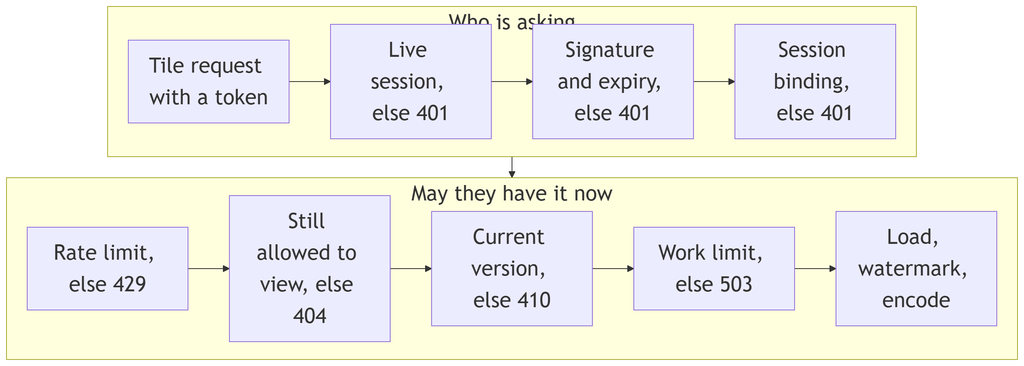

*Figure 17.3 — The chain of checks a tile request passes*

*Text description:* A chain in two rows, read left to right and then down, of eight steps after the request, each with the status returned when it fails: a live session (`401`), signature and expiry (`401`), session binding (`401`), rate limit (`429`), access to the document (`404`), token version (`410`) and the server-wide work limit (`503`). Only a request that passes all of them reaches the last step, which loads, watermarks and encodes the tile.

The cheapest checks come first, and the rate limit sits before the disk read, so a throttled request doesn't pay for the work it would have caused.

Even a token that passes every check yields exactly one tile of one page, watermarked with the requester's own identity. The `TileController` class comment ends: "Passing all five still only gets you ONE tile of ONE page, watermarked with the requester's identity baked in server-side."

**The incident that shaped the token.** In the first version, the token's payload was plain base64 containing the *session id itself* (fields such as `docId|0|0|0|<session-id>|expiry`), so a leaked tile URL leaked the credential that signs you in. A review found it in the first round. The fix replaced the session id with a keyed **session binding** derived from it (`SessionKeys.tileBinding`), and made the tile endpoint require that the request comes from the very session the token was issued to. The lesson repeats the one from Chapter 15: **never put a credential where it can travel; put something derived from it.**

### 17.9 Common mistakes

- **Loading a whole page or PDF into memory unbounded.** Compute the pixel size first and refuse what is too big, as `requireWithinLimits` does.
- **Signing only part of the data.** If a field isn't in the signed text, someone can change it. Sign every field that matters, in a fixed order.
- **Comparing signatures with `equals`.** It stops at the first difference, which leaks timing. Use a constant-time comparison.
- **Putting a secret in a token that isn't encrypted.** A signed token is readable by anyone; a signature proves authenticity, not secrecy.
- **A limit that counts only waiting work.** Abandoned work that is still running must still count against the limit.
- **Writing files in place.** Write in a staging folder and move atomically; readers should never see a half-written result.
- **Cleaning up only the happy path.** Every `catch` and every early exit needs to remove what the steps before it created.
- **Forgetting that files aren't transactional.** Order the steps so that a failure leaves nothing, or something a janitor can identify and remove.

## In this project

Table 17.5 — Where Chapter 17's ideas live

| Idea | File | Tag |
| --- | --- | --- |
| Grid arithmetic | `service/TileGrid.java` | `book-m0-mvp`, `book-m6-final` |
| Rendering and tiling | `service/TileGenerationService.java` | `book-m6-final` |
| Watermark | `service/WatermarkService.java` | `book-m6-final` |
| Signed tokens | `service/SignedUrlService.java`, `model/SignedTilePayload.java` | `book-m6-final` |
| Session-derived values | `security/SessionKeys.java` | `book-m6-final` |
| Bounded work | `service/TileWorkLimiter.java` | `book-m6-final` |
| Disk moves and deletes | `service/FileOperations.java`, `service/StorageJanitor.java` | `book-m6-final` |
| The upload sequence | `document/DocumentService.java` | `book-m6-final` |

Part IV's Chapter 25 shows the first, simplest version of the tiled viewer, and Chapter 29 tells how the watermark was tuned.

## Try it

### Exercise 17.1 ★ Count the tiles

A US letter page is 8.5 by 11 inches. At 150 DPI, how many pixels wide and tall is it? With 512-pixel tiles, how many rows and columns of tiles does it need, and how wide is the last column? Use `TileGrid.tileCount` to check your arithmetic.

*Solution:* Appendix C, Exercise 17.1.

### Exercise 17.2 ★ Why crop, not pad?

Why does `sliceTile` crop edge tiles instead of padding them to full size? What would you see in the viewer if it padded them with white?

*Solution:* Appendix C, Exercise 17.2.

### Exercise 17.3 ★★ Tamper with a token

On your own copy of the app, take a tile URL from the browser's *Network* tab and change one character of the part after the dot. Send it with `curl` while signed in. Which exception is thrown and which status do you get? Then change a character *before* the dot, and explain why the result is the same.

*Solution:* Appendix C, Exercise 17.3.

### Exercise 17.4 ★★ Why `finally`?

Why does `TileWorkLimiter.run` release its permit in a `finally` block? Describe what would happen to the server over time if it released the permit only after the work returned normally.

*Solution:* Appendix C, Exercise 17.4.

### Exercise 17.5 ★★★ Walk the leaked link

A token is valid for 120 seconds and is copied to a friend's browser within that time. Using Table 17.4, list every independent check that still refuses it, and say which single check would refuse it *even if* the friend also somehow signed in as the same user.

*Solution:* Appendix C, Exercise 17.5 (a worked outline).

### Exercise 17.6 ★★★ Design the failure paths

You are adding a "replace thumbnail" feature that writes one image file and updates one database column. List the steps in the order you'd do them, and for each failure point say what is left behind and what cleans it up. Where would you use a staging area, and where an atomic rename?

*Solution:* Appendix C, Exercise 17.6 (a worked outline).

## Summary

- An image is a grid of pixels held in memory at about four bytes each; PNG stores it without loss, and a pixel-count limit protects memory.
- PDFBox rasterizes each page at a chosen DPI; `TileGrid` rounds tile counts up and crops edge tiles so tiles reassemble exactly, and one A4 page becomes 12 tiles.
- Watermarks are drawn per tile at request time in a repeated brick pattern, so each viewer gets different pixels and every tile carries some of the mark.
- An HMAC over every field, with a secret key, makes tokens unforgeable; constant-time comparison, expiry, version, and session binding finish the job, and a leaked token still yields one watermarked tile.
- A semaphore bounds concurrent work; excess requests get `503` with `Retry-After`, and abandoned work still counts.
- Files are staged, committed atomically by version and cleaned by a conservative janitor; the order of the steps decides what a failure leaves behind.

## Further reading

- *Apache PDFBox Documentation*. https://pdfbox.apache.org/
- *Java Platform SE API*, `java.awt.image.BufferedImage`. https://docs.oracle.com/en/java/javase/25/docs/api/java.desktop/java/awt/image/BufferedImage.html
- *Java Platform SE API*, `javax.crypto.Mac`. https://docs.oracle.com/en/java/javase/25/docs/api/java.base/javax/crypto/Mac.html
- *Java Platform SE API*, `java.util.concurrent.Semaphore`. https://docs.oracle.com/en/java/javase/25/docs/api/java.base/java/util/concurrent/Semaphore.html
- *RFC 2104*, "HMAC: Keyed-Hashing for Message Authentication." https://www.rfc-editor.org/rfc/rfc2104
- *RFC 4648*, "The Base16, Base32, and Base64 Data Encodings" (base64url). https://www.rfc-editor.org/rfc/rfc4648

# Chapter 18: Testing the backend

The Secure Document Viewer makes promises: a reader can't open someone else's document, a copied tile link stops working, 12 parallel password guesses don't become 12 guesses. Promises like these are only worth something if a machine checks them every time the code changes. This chapter teaches you how the project's more than 100 backend tests are built, from a three-line check of one method up to a test that starts a real MySQL database. It also shows how to write tests that fail for the right reasons and never fail at random.

## Learning objectives

By the end of this chapter, you will be able to:

- Explain the test pyramid and choose the right level for a new test.
- Write and run a JUnit 5 test using the arrange, act, assert pattern, and read its result.
- Test pure logic, code with a fake collaborator, and code that touches the file system.
- Write a `MockMvc` test that runs a request through the real security filters.
- Explain what H2 in MySQL mode and Testcontainers each prove, and what neither proves.
- Write a concurrency test that is deterministic, and fix a flaky test by controlling time and ordering.

## Prerequisites

- Chapter 4: classes, objects, records and interfaces
- Chapter 5: collections, lambdas, and exceptions
- Chapter 6: Maven and the shape of a project
- Chapters 11 to 16: the backend features under test (you don't need every detail; each test is explained where it appears)

## Beginner tier: Tests are questions the code must keep answering

### 18.1 Why tests matter, and the test pyramid

A test is code that runs other code and checks the result. Think of the checklist a pilot runs before every takeoff. The pilot knows how to fly, and still nobody trusts memory for the twelfth flight of the day: a checklist run the same way every time catches the step that was skipped. A test suite is the checklist for the code. It runs in minutes, doesn't get bored, and doesn't assume that the change you made "couldn't possibly affect that."

**Where the analogy breaks down:** a checklist confirms that steps were performed. A test can only show that the cases someone *thought to write* still behave as expected. A green test run means "no known problem," never "no problem." Most of the skill in testing is choosing the cases well, and this chapter spends as much time on choosing as on syntax.

Tests come in sizes, and a healthy project has a shape, usually drawn as a pyramid (Figure 18.1).

```
              /\
             /  \        few:  the whole system, real browser (Playwright, Chapter 24)
            /----\
           /      \      some: part of the application running (Spring, MockMvc, a real database)
          /--------\
         /          \    many: one class or method, no framework, milliseconds
        /------------\
```

*Figure 18.1 — The test pyramid*

*Text description:* A triangle drawn in text with three bands. The narrow top band holds a few whole-system browser tests, the middle band holds some tests that run part of the application, and the wide bottom band holds many fast tests of one class or method. The shape shows that speed and precision fall as a test covers more.

A **unit test** exercises one small piece, such as a method, or a class, in isolation. It's fast (milliseconds) and, when it fails, it points at the broken line. An **integration test** starts several pieces together, for example the real security filters plus the real controllers plus a database, to check that they cooperate. It is slower and, when it fails, tells you *that* something is wrong but makes you search for where. A **system test** drives the finished app the way a user would (Chapter 24). You want many of the first kind, fewer of the second, and few of the third, because speed and precision fall as scope rises.

The project's backend tests at `book-m6-final` follow this shape. Table 18.1 shows the levels with real examples.

Table 18.1 — Backend tests at `book-m6-final`

| Level | Example classes | What they prove |
| --- | --- | --- |
| Pure logic | `TileGridTest`, `SignedUrlServiceTest`, `LoginThrottleTest`, `WatermarkServiceTest` | Rules and arithmetic, without Spring |
| Logic with collaborators | `StorageJanitorTest`, `TileGenerationServiceTest` | Code that uses files or other classes, using fakes, and temporary folders |
| Application with `MockMvc` | `ErrorContractTest`, `SecurityIntegrationTest`, `CsrfCookieFlowTest`, `SecurityHeadersTest`, `DocumentAccessIntegrationTest` | Endpoints, filters, error shape, access rules |
| Real database | `MySqlIntegrationTest` | Migrations, row locks, UTC timestamps |

All of them live in `src/test/java/com/example/securedocviewer/`, in the same package structure as the code they test. That mirror layout is a Maven convention (Chapter 6): Maven compiles `src/main/java` into the program and `src/test/java` into a separate test program that is never shipped.

Figure 18.2 pairs each layer with the kind of mistake it is best at catching.

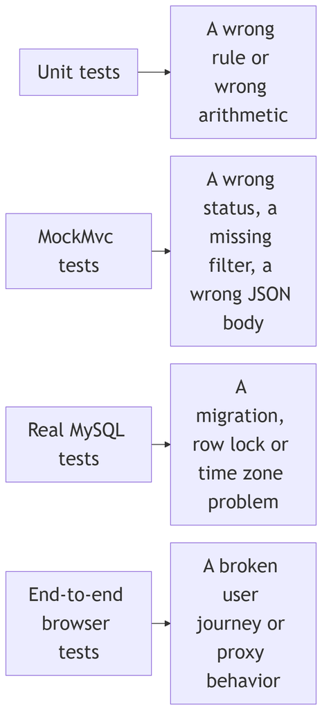

*Figure 18.2 — The layers of tests and what each one catches*

*Text description:* Four rows, each with an arrow from a kind of test to the mistakes it catches best. Unit tests catch wrong rules and arithmetic, MockMvc tests catch wrong statuses, missing filters, and wrong JSON, real-MySQL tests catch migration, row-lock, and time-zone problems, and end-to-end browser tests catch broken user journeys and proxy behavior.

Each layer is slower than the one before it and sees more of the system. A mistake caught by a unit test is cheap to find; a mistake that only the browser layer can see is expensive, so the project pushes each rule down to the lowest layer that can prove it.

### 18.2 JUnit 5 and the anatomy of a test

**JUnit 5** is the Java testing framework. A test is an ordinary method marked with the annotation `@Test`. When you run the tests, JUnit finds every such method, calls it, and records whether it finished normally (pass) or threw an exception (fail). **Assertions** are the methods that do the throwing. `assertEquals(expected, actual)` throws if the two values differ, and the exception carries a message such as `expected: <3> but was: <2>`.

Nearly every good test has the same three parts, which are easiest to remember as a recipe.

1. **Arrange.** Create the objects and data the test needs.
2. **Act.** Do the one thing being tested.
3. **Assert.** Check the outcome.

Here is the pattern with no project code around it, so you can see the bones. Because it is written to teach and is not from the repository, it's an Example, not a Listing.

**Example 18.1 — The shape of a test**

```java
@Test
void aPageOfOneThousandPixelsNeedsTwoTilesOfFiveHundredTwelve() {
    int pageWidth = 1000;                                 // arrange
    int tileSize = 512;

    int tiles = TileGrid.tileCount(pageWidth, tileSize);  // act

    assertEquals(2, tiles);                               // assert
}
```

Notice the long method name. A test name is documentation: when the test fails in the console, the name is the first thing you read, so it should say what was expected to be true. `aPageOfOneThousandPixelsNeedsTwoTilesOfFiveHundredTwelve` tells you what broke before you open the file. The project's tests follow the same habit: `wrongPasswordAndUnknownUserGetTheSameAnswer`, `readersCannotReachAdminOrUpload`, `anAdminSetPasswordMustBeChangedBeforeAnythingElseWorks`. Read down the list of names in `SecurityIntegrationTest` and you have a summary of the security promises the app makes.

You run every test with Maven (Chapter 6):

```bash
./mvnw test
```

You should see something like:

```
[INFO] Tests run: N, Failures: 0, Errors: 0, Skipped: 0, Time elapsed: ... s -- in ...TileGridTest
...
[INFO] Tests run: N, Failures: 0, Errors: 0, Skipped: 0
[INFO] BUILD SUCCESS
```

The exact wording and numbers depend on your Maven version and on how many tests exist, so treat this as an illustration of the format. Three words matter in that summary. A **failure** means an assertion did not hold. An **error** means the test itself crashed with an unexpected exception before it could assert. A **skipped** test was deliberately not run; you will meet a deliberate skip in Section 18.9.

### 18.3 Testing pure logic: `TileGridTest`

The easiest code to test has no dependencies: you give it numbers, it returns numbers. `TileGrid` from Chapter 17 is exactly that, so its test needs no Spring, no database, and no files.

**Listing 18.1 — `TileGridTest.java` (`book-m6-final`, simplified: imports, the image-building helper, and the last two tests are omitted)**

```java
class TileGridTest {

    @Test
    void tileCountRoundsUpForPartialTiles() {
        assertEquals(1, TileGrid.tileCount(1, 256));
        assertEquals(1, TileGrid.tileCount(256, 256));
        assertEquals(2, TileGrid.tileCount(257, 256));
        assertEquals(13, TileGrid.tileCount(612, 50));
        assertEquals(16, TileGrid.tileCount(792, 50));
    }

    @Test
    void tileCountRejectsNonPositiveInputs() {
        assertThrows(IllegalArgumentException.class, () -> TileGrid.tileCount(0, 256));
        assertThrows(IllegalArgumentException.class, () -> TileGrid.tileCount(100, 0));
    }

    @Test
    void edgeTilesAreCroppedNotPadded() {
        BufferedImage page = noiseImage(612, 792);

        BufferedImage interior = TileGrid.sliceTile(page, 0, 0, 50);
        assertEquals(50, interior.getWidth());
        assertEquals(50, interior.getHeight());

        BufferedImage rightEdge = TileGrid.sliceTile(page, 0, 12, 50); // 612 - 600 = 12px wide
        assertEquals(12, rightEdge.getWidth());
        // ...
    }
    // ...
}
```

*Path: `src/test/java/com/example/securedocviewer/service/TileGridTest.java`*

Look at how the first test chooses its inputs. The rule under test is "round up," and the interesting values for a rounding rule are the boundaries. A page one pixel wide needs one tile. A page exactly one tile wide needs one tile, not two. A page one pixel *over* a tile (257 with 256-pixel tiles) needs two. The last two lines use the size of a US letter page in points, 612 by 792. They use a small tile of 50 so you can check the arithmetic by hand: 612 / 50 is 12.24, which rounds up to 13. Whenever you test a rule, ask "where does its behavior change?" and put values on both sides of that line.

The second test uses `assertThrows`, which deserves a slow reading:

```java
assertThrows(IllegalArgumentException.class, () -> TileGrid.tileCount(0, 256));
```

The second argument is a lambda (Chapter 5), a small piece of code handed to `assertThrows` unrun. `assertThrows` runs it inside a `try` block, and passes only if the code throws the named exception type. Without the lambda, the exception would escape from your test line and crash it. This is also a test of a *refusal*: the project cares that bad input fails loudly rather than producing a nonsense grid.

The third test builds a random image (`noiseImage`, omitted here) and checks the dimensions of the tiles cut from it. The comment `// 612 - 600 = 12px wide` is the good kind of comment in a test: it shows the arithmetic that explains the expected number. Tests that assert unexplained numbers are hard to trust and harder to fix.

### 18.4 Common mistakes when starting out

Some mistakes are so common that it's worth naming them early.

- **Testing several things in one test.** A test called `everythingWorks` that asserts 20 things stops at its first failure and hides the other 19. Prefer small tests with one reason to fail. (`tileCountRoundsUpForPartialTiles` makes five assertions, but they all check one rule.)
- **Asserting the code's own answer.** If you compute the expected value with the same formula the code uses, the test can never fail. Use a value you worked out by hand or know independently, like the 13 in Listing 18.1.
- **Forgetting the failure cases.** Code that accepts good input is half the job. The project's tests spend as much effort on "the wrong password is refused" and "a tampered token is rejected" as on the happy path, because security is mostly about refusals.
- **Tests that depend on each other's order.** JUnit doesn't promise an order. Each test must set up what it needs. Section 18.7 shows how tests that share one application avoid stepping on each other.
- **Ignoring a red test.** A test that fails "sometimes" is a flaky test (Section 18.11). Don't merge over it; find the cause.

## Intermediate tier: Tests with collaborators and the whole application

*If you're reading for the first time, Sections 18.5 and 18.6 are the important ones here; you can skim 18.7 and come back once you have written a test or two.*

### 18.5 Setting up: `@BeforeEach`, fakes, and temporary folders

Real code has dependencies. `SignedUrlService` (Chapter 17) needs a `ViewerProperties` object holding the signing secret and the token lifetime. For a unit test you don't start Spring to get one; you create one by hand. `SignedUrlServiceTest` does it in a method annotated `@BeforeEach`, which JUnit runs before every test so each starts from a clean slate.

**Listing 18.2 — `SignedUrlServiceTest.java` (`book-m6-final`, simplified: imports and two tests are omitted; the test's signing secret is replaced by the placeholder `<unit-test-secret>`, as this book never prints secret values)**

```java
class SignedUrlServiceTest {

    private ViewerProperties properties;
    private SignedUrlService service;

    @BeforeEach
    void setUp() {
        properties = new ViewerProperties();
        properties.setSigningSecret("<unit-test-secret>");
        properties.setUrlTtlSeconds(60);
        service = new SignedUrlService(properties);
    }

    @Test
    void issuedTokenRoundTripsToTheSamePayload() {
        String token = service.issueToken("doc-1", 2, 3, 4, 1, "session-abc");

        SignedTilePayload payload = service.verifyAndDecode(token);

        assertEquals("doc-1", payload.documentId());
        assertEquals(2, payload.page());
        // ...
    }

    @Test
    void tamperedSignatureIsRejected() {
        String token = service.issueToken("doc-1", 0, 0, 0, 1, "session-abc");
        String[] parts = token.split("\\.", 2);
        // Flip the last character of the signature — payload is untouched.
        char[] sig = parts[1].toCharArray();
        sig[sig.length - 1] = sig[sig.length - 1] == 'A' ? 'B' : 'A';
        String tampered = parts[0] + "." + new String(sig);

        assertThrows(InvalidTokenException.class, () -> service.verifyAndDecode(tampered));
    }
    // ...
}
```

*Path: `src/test/java/com/example/securedocviewer/service/SignedUrlServiceTest.java`*

Two things are worth noticing. First, the first test is a **round trip**: issue a token, decode it, and check you get back what you put in. Round trips are a cheap, strong test for any pair of "encode" and "decode" operations. Second, the tampering test is an attack in miniature. It flips one character of the signature and checks that the service refuses it. The next test in the file (omitted) splices the signature of one token onto the payload of another and checks that this too is refused. Those tests together are the executable form of the claim in Chapter 17 that the signature covers every field.

There is a subtle point in `setUp`. The signing secret used in the real test (shown here as a placeholder) is a short throwaway value of only 16 characters, while `ViewerProperties` demands at least 32 (Chapter 13). It works because the length rule is enforced only when *Spring* binds the settings from `application.yml`. A plain `new ViewerProperties()` in a unit test skips validation. That is convenient, and it is also a trap: a unit test proves the service works, not that the configuration is valid. The validation itself is exercised when the whole application starts in the integration tests, which use a test secret longer than 32 characters.

Some classes need help that isn't simple to build by hand. `StorageJanitor` (Chapter 14) looks at real folders on disk and asks the `DocumentRepository` which documents exist. Its test uses two tools.

- `@TempDir` gives the test a fresh, empty folder that JUnit deletes afterward, so the test can create and delete real directories without touching your files.
- **Mockito**, a library that comes with Spring Boot's test starter, creates a **mock**: a stand-in object whose answers you script. A mock stands in for a collaborator that is hard to construct (a repository that needs a database).

**Listing 18.3 — `StorageJanitorTest.java` (`book-m6-final`, excerpt: the second test, imports omitted)**

```java
@Test
void keepsEveryVersionWhenTheCurrentOneIsMissing(@TempDir Path root) throws IOException {
    // e.g. a database restored from before a replace, with tiles archived after it
    Instant old = Instant.now().minus(StorageJanitor.MIN_AGE).minusSeconds(60);
    Path onlySurvivor = dir(root.resolve(KNOWN).resolve("v3"), old);

    ViewerProperties properties = new ViewerProperties();
    properties.setStorageRoot(root.toString());
    DocumentRepository documents = mock(DocumentRepository.class);
    when(documents.findAllTileVersions()).thenReturn(List.<Object[]>of(new Object[] {KNOWN, 2}));

    assertEquals(0, new StorageJanitor(properties, documents).removeOrphans(Instant.now()));
    assertTrue(Files.exists(onlySurvivor), "the only tiles left must be kept for recovery");
}
```

*Path: `src/test/java/com/example/securedocviewer/service/StorageJanitorTest.java`*

Two names in the listing come from parts of the file that are not shown: `dir(...)` is a small helper that creates a folder and gives it a chosen age. `KNOWN` is a made-up document id used throughout the class. Read the test as a story. The database (the mock) says "the document's current tile version is 2." The disk contains only `v3`. The janitor must not delete it, because it might be the only surviving copy of someone's tiles. The last argument of `assertTrue` is a message shown if the assertion fails: `"the only tiles left must be kept for recovery"`. It states the *reason*, so a future developer who breaks this rule learns why it existed. Compare it with the first test in the same class. That test builds nine directories of different ages and checks that exactly four are removed. Each `assertTrue` or `assertFalse` carries a message that names the rule ("a very recent directory may be an upload in flight").

This test also shows a rule about scope. It is about a *dangerous* action, deleting files, and it is written to prove what the action must **not** do. Tests for destructive code should spend most of their lines on the things that must survive.

### 18.6 Spring integration tests and `MockMvc`

Most of the app's rules live in how classes work together: a request passes through security filters, reaches a controller, calls a service, and returns JSON, or fails and passes through the exception handler. To test that, you start the application inside the test. Three annotations do it.

- `@SpringBootTest` builds the full application context (Chapter 11): every bean, wired as in production.
- `@ActiveProfiles("test")` makes Spring read `application-test.yml` in addition to `application.yml`.
- `@AutoConfigureMockMvc` provides **MockMvc**, a tool that sends a request into the application's controllers *without opening a network port*. It is faster than a real HTTP call and passes through the same filters and handlers.

The test profile is short enough to read in full.

**Listing 18.4 — `application-test.yml` (`book-m6-final`, simplified: the signing secret and the test administrator's password are replaced by the placeholders `<test-signing-secret>` and `<test-admin-password>`; the real file holds throwaway test values, and this book never prints secret values)**

```yaml
# In-memory H2 in MySQL mode, so the same Flyway migrations run in tests
# without a database server.
spring:
  datasource:
    url: jdbc:h2:mem:securedocs;MODE=MySQL;DATABASE_TO_LOWER=TRUE;DB_CLOSE_DELAY=-1
    username: sa
    password: ""

secure-doc-viewer:
  signing-secret: <test-signing-secret>
  storage-root: ./target/test-storage
  bootstrap-admin:
    username: admin
    password: <test-admin-password>
```

*Path: `src/test/resources/application-test.yml`*

Line by line: `jdbc:h2:mem:securedocs` is an **H2** database that lives in memory and vanishes when the test process ends. `MODE=MySQL` makes it accept MySQL's flavor of SQL, and `DATABASE_TO_LOWER=TRUE` mirrors MySQL's lower-case table names. The *same* Flyway migrations (Chapter 14) therefore run unchanged. The signing secret is a throwaway value longer than the 32-character minimum. The storage root is under `target/`, the folder Maven deletes on `clean`, so tests never litter real storage. The bootstrap admin gets a known username and password so tests can sign in as an administrator; these are test-only placeholders that exist nowhere but in the test profile.

`ErrorContractTest` shows the smallest useful integration test. Its setup is:

**Listing 18.5 — `ErrorContractTest.java` (`book-m6-final`, excerpt: the class header)**

```java
@SpringBootTest
@AutoConfigureMockMvc
@ActiveProfiles("test")
@Import(ErrorContractTest.FailingController.class)
class ErrorContractTest {
```

*Path: `src/test/java/com/example/securedocviewer/controller/ErrorContractTest.java`*

The `@Import` adds a small controller that exists only in this test and throws an exception on purpose, containing a fake SQL statement and a file path in its message. The test calls it and asserts that the response is `500`, that the JSON body says only "Something went wrong on our side. Reference: ...," and that neither the SQL nor the path leaks (Chapter 13). This is a nice example of a test that *creates* its own trouble. There is no natural way to make a healthy app throw an unexpected exception on demand, so the test supplies one.

Now the workhorse. `SecurityIntegrationTest` has 22 tests, and its class comment says they are "one test per property the security review called out." A typical one:

**Listing 18.6 — `SecurityIntegrationTest.java` (`book-m6-final`, excerpt: test `apiRequiresSignIn`)**

```java
@Test
void apiRequiresSignIn() throws Exception {
    mvc.perform(get("/api/documents"))
            .andExpect(status().isUnauthorized())
            .andExpect(jsonPath("$.error").value("Sign-in required."));
}
```

*Path: `src/test/java/com/example/securedocviewer/security/SecurityIntegrationTest.java`*

`mvc.perform(get("/api/documents"))` sends a `GET` request. `andExpect(status().isUnauthorized())` asserts a `401`. `jsonPath("$.error")` looks inside the JSON response: `$` is the whole document and `.error` is the field of that name. The test proves three separate things at once: the security filter chain is active, an anonymous request is refused, and the refusal uses the project's one JSON error shape rather than an HTML page. If someone later changed a rule in `SecurityConfig` by accident, this test would turn red.

### 18.7 Security tests through the real filter chain

Tests that need a signed-in user must sign in first. `SecurityIntegrationTest` has two small helpers that every test uses, and reading them teaches a lot about how the app works.

**Listing 18.7 — `SecurityIntegrationTest.java` (`book-m6-final`, excerpt: the helper methods `user` and `login`)**

```java
private void user(String username, Role role) {
    try {
        accounts.create(username, PASSWORD, role, false);
    } catch (UsernameTakenException alreadyCreated) {
        // Context (and its in-memory database) is shared across tests.
    }
}

private MockHttpSession login(String username, String password) throws Exception {
    MvcResult result = mvc.perform(post("/api/auth/login").with(csrf())
                    .contentType(MediaType.APPLICATION_JSON).content(loginRequest(username, password)))
            .andExpect(status().isOk())
            .andReturn();
    return (MockHttpSession) result.getRequest().getSession(false);
}
```

*Path: `src/test/java/com/example/securedocviewer/security/SecurityIntegrationTest.java`*

`user` creates an account through the real `UserAccountService`, passing `false` for "must change password" so the account is immediately usable. Its `catch` block shows the ordering problem from Section 18.4: Spring reuses one application (and one in-memory database) for all tests in the class, for speed, so a user created by an earlier test may already exist. Each test therefore creates users with *its own distinct name* (`lockout-user`, `cookie-user`, `plain-reader`), and the helper tolerates duplicates. Test data is shared state; naming it uniquely is how tests avoid stepping on each other.

`login` performs a real sign-in through `AuthController`, then captures the resulting session so later requests can present it (`.session(reader)`). The `.with(csrf())` part attaches a valid cross-site request forgery (CSRF) token: without it, the request would be refused with `403` before reaching the controller (Chapter 16).

Here are three of the promises the class checks, with what each proves:

- `wrongPasswordAndUnknownUserGetTheSameAnswer` sends both kinds of bad sign-in and asserts the two response bodies are *equal*, proving the app doesn't reveal which usernames exist (Chapter 15).
- `readersCannotReachAdminOrUpload` signs in as a plain reader and asserts `403` on the admin endpoints and on upload, proving the role rules from Chapter 16 hold through the real chain.
- `tileLinksOnlyWorkForTheSessionTheyWereIssuedTo` checks that a tile link issued to one session is refused for another, proving the session binding described in Chapter 17.

Notice the shape: each test names a promise in plain language, arranges a user, or two, acts by making requests, and asserts on status codes and JSON. That's the method to copy when you add a feature. Write the sentence "a reader must not be able to ...," turn it into a test name, and make it pass.

**Common mistakes with integration tests.**

- *Mocking too much.* If you replace the security filters or the database with mocks, the test no longer proves the real thing works. Use the real components and fake only what is truly outside your control, such as the clock, or the network.
- *Asserting only the status code.* A `400` is also what you get for a hundred unrelated reasons. Check the error message too, as these tests do with `jsonPath`.
- *Sharing users between tests.* See Listing 18.7: give each test its own users.
- *A test that passes because the setup failed.* A test asserting "this request is refused" would pass if the sign-in helper silently failed, and you'd never notice. That is why `login` asserts `isOk()` on the sign-in itself before returning the session.

## Advanced tier: Real databases, time, and concurrency

*You can skip to "In this project" on a first read. Part IV comes back to the incidents described here.*

### 18.8 A test helper that hid a bug: `CsrfCookieFlowTest`

Test helpers are convenient, and every convenience hides something. The helper `csrf()` used in Listing 18.7 makes a request carry a valid CSRF token by quietly replacing Spring's token repository. It is fine for most tests. But it means those tests never exercise the *real* cookie the browser uses.

That gap concealed a real bug. At sign-in, Spring's built-in rotation of the CSRF token deleted the `XSRF-TOKEN` cookie and then re-read the token from the request, which still had the old cookie. The browser was left with no token at all, and its first write after signing in failed with `403`. Tests using `csrf()` could not see it. The fix is in `AuthController.rotateCsrfToken` (Chapter 16), and the guard is `CsrfCookieFlowTest`, which behaves like a browser. It makes a first request and takes the `XSRF-TOKEN` cookie from the response, then signs in presenting that cookie and header. It checks three things: the sign-in response carries a *different, non-empty* token, the old token is refused, and the new one works immediately.

Its class comment explains a constraint worth remembering. The `csrf()` helper permanently swaps the filter's repository in whatever application context it runs in, "after which no real XSRF-TOKEN cookie is ever written." So the test class is annotated `@DirtiesContext(classMode = BEFORE_CLASS)`, which tells Spring to throw away any cached application and start a fresh one. The lesson is general: **when a test uses a shortcut for a mechanism, that mechanism needs at least one test without the shortcut.**

### 18.9 Testcontainers and a real MySQL

H2 in MySQL mode is fast and needs nothing installed, but it is an imitation. Where H2 and MySQL differ (some SQL, locking behavior, how time zones convert), an H2 test can pass while the real database misbehaves. Chapter 14 listed three things the project wanted to check on the real engine: the Flyway migrations, the row lock that serializes PDF replacement, and timestamps in UTC (Coordinated Universal Time). **Testcontainers** is a library that starts a real service, here MySQL, in a Docker container (Chapter 10) for the duration of a test and throws it away afterward.

**Listing 18.8 — `MySqlIntegrationTest.java` (`book-m6-final`, simplified: imports, the JVM time-zone setup, and most tests are omitted)**

```java
@SpringBootTest
@ActiveProfiles("test")
@Testcontainers(disabledWithoutDocker = true)
class MySqlIntegrationTest {

    @Container
    @ServiceConnection
    static final MySQLContainer MYSQL = new MySQLContainer("mysql:8.4")
            .withCommand("--default-time-zone=-03:00")
            .withUrlParam("connectionTimeZone", "UTC")
            .withUrlParam("forceConnectionTimeZoneToSession", "true");

    // ...

    @Test
    void everyMigrationAppliesToMySql() {
        List<String> applied = jdbc.queryForList(
                "select version from flyway_schema_history where success = 1 and version is not null order by installed_rank",
                String.class);
        assertEquals(List.of("1", "2", "3"), applied);
        // ...
    }
}
```

*Path: `src/test/java/com/example/securedocviewer/MySqlIntegrationTest.java`*

`@Container` tells Testcontainers to start the `mysql:8.4` image, the same version production runs, before the tests. `@ServiceConnection` is a Spring Boot feature that reads the container's address and credentials and points the application's datasource at it automatically, overriding the H2 URL from the test profile. `disabledWithoutDocker = true` makes the whole class *skip* (not fail) on a machine where Docker isn't running, which is the deliberate skip promised in Section 18.2. The class comment adds the safety net: "CI always has it" (CI is continuous integration, the automatic build and test run described in Chapter 36), so the tests always run before code reaches `main`.

The container is started with a server time zone of `-03:00`, and the test class also sets the JVM to `Asia/Kolkata` (in the omitted code). Those are two *different, non-UTC* zones on purpose. The test then writes an audit event and reads back the raw stored value to check that it is UTC anyway. The class comment describes the situation: a dev machine in India talking to a database set to local time. A test that only passes when everything is in UTC would prove nothing about that.

Another test in the class starts two threads that replace the same PDF at once and checks that the row lock (Chapter 14) serialized them. The document ends at tile version 3, only the newest version directory exists on disk, and neither thread crashed. No mock can prove that. It needs a real database that really takes row locks.

The project's continuous-integration workflow runs `./mvnw -B verify` on every pull request; Chapter 36 covers it.

### 18.10 Concurrency tests: making a race happen on purpose

Some bugs exist only when two things happen at the same moment. A test for such a bug has a problem: run naively, requests trickle in one after another and never collide, so the buggy code passes. The test must force the collision.

`aBurstOfParallelWrongPasswordsGetsNoMoreThanTheLimit` in `SecurityIntegrationTest` does it. It creates 12 threads, each sending a wrong-password sign-in for the same account from the same address. All 12 *wait* at a gate, and then the gate opens and all go at once. The gate is a `CountDownLatch`:

**Listing 18.9 — `SecurityIntegrationTest.java` (`book-m6-final`, simplified: the loop that submits the threads is omitted; each submitted task calls `start.await()` before it sends its request)**

```java
java.util.concurrent.CountDownLatch start = new java.util.concurrent.CountDownLatch(1);
// ...
start.countDown();
```

*Path: `src/test/java/com/example/securedocviewer/security/SecurityIntegrationTest.java`*

A **latch** is a counter starting at 1: `await()` blocks until the count reaches zero, and `countDown()` lowers it, releasing everyone at once. Twelve threads that have all been created and are all waiting at the gate release together, so they really overlap.

Then the assertions. Every response must be either `401` (the password was checked and was wrong) or `429` (refused by the throttle), and the number of `401`s must equal exactly `MAX_FAILURES_PER_ACCOUNT`, which is 5. That is the atomic-counting promise from Chapter 16 in numbers: of 12 simultaneous guesses, exactly 5 were actually checked. A throttle that counted after checking would let many more through, and this test would fail.

**A test must be able to fail.** Ask of any concurrency test: "if I removed the protection, would it fail?" With the latch it would. Without the latch, threads might finish before the next one starts, and the test could pass even against buggy code. That is a weak test, and the worst kind because it gives false confidence. (Exercise 18.5 asks you to explore this.)

### 18.11 Flaky tests, and controlling time

A **flaky test** passes and fails without any change to the code. It is corrosive: once people stop trusting a red build, they stop reading it. The project's history has one instance, fixed in commit `898d65b` (pull request 9), "Fix flaky render-slot assertion in TileGenerationServiceTest."

**The problem.** The test `aRenderThatTakesTooLongIsAbandonedAndFreesItsSlot` made a render time out, and then asserted that every render slot was free at the same instant the second render returned. **How it was found.** The build on the main branch failed once, after an earlier pull request merged. **The cause.** The render thread frees its slot in a `finally` block that runs *right after* the caller has its result, so on a fast machine the assertion could land in that gap and read 0 where it expected 1. **The fix.** The test now waits, within a limit, for the counters to reach the expected value, and only then asserts. Production behavior was unchanged, because in production the slot frees microseconds after the upload returns. You can see the pattern in the test. A loop of the form "until a deadline, look; if right, stop; otherwise sleep 100 ms" is followed by the real assertion, with the comment "allow a moment rather than checking at the same instant."

**The lesson.** A test that checks a state at the exact moment a result returns is racing the code it tests. Wait *for a condition*, with a generous limit, never for a fixed guess of how long something takes.

The other general cure is to take control of time. `LoginThrottle` and `KnownDevices` each have a second, package-private constructor that accepts a `java.time.Clock` (Chapter 11 noted that classes with two constructors need an explicit `@Autowired`). In production they use the system clock. A test can pass a clock it controls and move it forward by 15 minutes without waiting 15 minutes. Any code that decides "has enough time passed?" should take its clock as a parameter so that the test, not the calendar, decides.

**Common mistakes with slow or timing-dependent tests.**

- *Sleeping for a fixed time.* `Thread.sleep(2000)` is either too short (flaky) or too long (a slow suite). **Poll** instead: check the condition repeatedly, pausing briefly between checks, until it is true or a deadline passes.
- *Reading the real clock in the assertion.* If code stamps "now" and the test compares to "now" a moment later, they can differ. Compare with a tolerance (`MySqlIntegrationTest` accepts a **drift**, a difference between the two times, of under one minute) or inject a clock.
- *Leaving shared files behind.* Use `@TempDir` or a folder under `target/`, as in Listings 18.3 and 18.4.

## In this project

Part IV shows how these tests grew with each milestone. Table 18.2 shows where each idea in this chapter lives at `book-m6-final`.

Table 18.2 — Where Chapter 18's ideas live

| Idea | File |
| --- | --- |
| Pure-logic tests | `service/TileGridTest.java`, `service/SignedUrlServiceTest.java`, `security/LoginThrottleTest.java` |
| Temporary folders and mocks | `service/StorageJanitorTest.java` |
| Test profile (H2, test secret) | `src/test/resources/application-test.yml` |
| Error shape | `controller/ErrorContractTest.java` |
| Security promises | `security/SecurityIntegrationTest.java`, `security/SecurityHeadersTest.java` |
| Browser-like CSRF flow | `security/CsrfCookieFlowTest.java` |
| Real MySQL | `MySqlIntegrationTest.java` |
| Concurrency | `SecurityIntegrationTest` (burst test), `document/ConcurrentServingIntegrationTest.java` |

All paths are under `src/test/java/com/example/securedocviewer/` unless shown otherwise.

## Try it

### Exercise 18.1 ★ Run the tests and read the summary

From the project folder at `book-m6-final`, run `./mvnw test`. Find the line that reports the number of tests run. Which test class was skipped, if any, and why? (If you don't have Docker running, one should be.)

*Solution:* Appendix C, Exercise 18.1.

### Exercise 18.2 ★ Add a boundary case

In `TileGridTest`, add a test that `TileGrid.tileCount(512, 512)` is 1 and `TileGrid.tileCount(513, 512)` is 2. Predict both answers before you run it. Work on your own branch (`git switch -c exercise-18-2`).

*Solution:* Appendix C, Exercise 18.2.

### Exercise 18.3 ★★ Write an unauthenticated test

Write a new test class that starts the application like `ErrorContractTest` does and asserts that `GET /api/admin/audit` without signing in returns `401` with the error `Sign-in required.`. Then change the test to sign in as a reader (copy the `user` and `login` helpers from Listing 18.7) and assert `403`. What is the difference between the two failures, and which layer of the app produces each?

*Hint:* the first is "we don't know who you are," the second is "we know, and you may not."

*Solution:* Appendix C, Exercise 18.3.

### Exercise 18.4 ★★ Break a rule and watch the test

On a scratch branch, first predict what happens if you change `MAX_FAILURES_PER_ACCOUNT` in `LoginThrottle` from 5 to 6. Then change it, run `LoginThrottleTest` and `SecurityIntegrationTest`, and compare. Next, break the rule differently: make `checkAllowed` ignore the account-and-address rule, and run them again. Which tests fail now, and what does each failure message say? Restore the code. What does the difference between the two experiments tell you about how the tests are tied to the rule?

*Solution:* Appendix C, Exercise 18.4.

### Exercise 18.5 ★★★ Is the burst test strong enough?

In a scratch copy, remove the `start.await()` call from the burst test and run it ten times. Then temporarily change `LoginThrottle.reserve` to check first and count after (so the counting is no longer atomic) and run the original test again. Explain what you observe about which version of the test can detect the bug, and write a paragraph on what makes a concurrency test trustworthy.

*Solution:* Appendix C, Exercise 18.5 (a worked outline).

### Exercise 18.6 ★★★ Design a test for a promise

Pick one promise from the app that has no test of its own (for example, that a document unshared from a user stops serving new tiles to them). Write the promise as a one-line test name, list the arrange, act, and assert steps, and say which level of the pyramid it belongs to and why. Implement it if you can.

*Solution:* Appendix C, Exercise 18.6 (a worked outline).

## Summary

- Tests form a pyramid: many fast method-level tests, fewer application tests, few whole-system tests. Choose the lowest level that can prove the promise.
- A JUnit 5 test is a `@Test` method following arrange, act, assert; its name should read as a sentence describing behavior.
- Choose inputs at the boundaries where behavior changes, and spend as many tests on refusals as on successes.
- `@BeforeEach`, `@TempDir`, and Mockito mocks let you test code with collaborators, and `assertTrue` messages should state the reason for the rule.
- `@SpringBootTest` with `MockMvc` runs requests through the real filters, controllers, and handlers; share the application but not the data.
- H2 in MySQL mode gives speed; Testcontainers gives a real MySQL for what H2 can't vouch for, and a test that uses a shortcut needs a partner test without it.
- Concurrency tests use latches to force a collision; flaky tests are fixed by waiting for conditions and injecting clocks, never by guessing how long something takes.

## Further reading

- *JUnit 5 User Guide*. https://docs.junit.org/current/user-guide/
- *Spring Framework Reference Documentation*, "Testing." https://docs.spring.io/spring-framework/reference/testing.html
- *Spring Boot Reference Documentation*, "Testing." https://docs.spring.io/spring-boot/reference/testing/index.html
- *Testcontainers for Java*. https://java.testcontainers.org/
- *Mockito Documentation*. https://site.mockito.org/

# Part III: The frontend

Part II built the server: it stores documents, checks who you are, and hands out watermarked tiles. But a server has no face. Everything a reader actually sees, from the sign-in form to the page they are reading, is drawn in the browser by a program that the server sends along. This part is about that program.

## Where the frontend fits

Chapter 1 introduced the client and the server: the **client** is the program on the reader's device that asks for things, and the **server** is the program that answers. In this project the client is a web application that runs inside the reader's browser, and it is called the **frontend**. The server is the Spring Boot **backend** from Part II. The two never share code. They share only an agreement: a set of web addresses and the shape of the JSON they exchange (Chapters 8 and 12).

That agreement is why the frontend is a separate program with its own language, its own tools, and its own tests, in its own folder, `frontend/`. It is also why some of the most interesting questions in the whole app are asked at the seam between the two. Who checks that a reader may open a document: the button that hides it, or the server that refuses to serve it? (The server; the button is a courtesy.) Where does the session live: in JavaScript the reader could inspect, or in a cookie the browser guards? (A cookie the script can't read.) How does the page know to slow down when the server says "too many requests"? Part III answers these from the browser's side, and Part II showed the other side.

## What this part covers

The frontend is an Angular application written in TypeScript. Six chapters take you from the language to the finished screen:

- **Chapter 19: TypeScript.** The language, taught through the app's own data shapes, a worked reading of the tile-layout function, and its asynchronous tile-fetching code.
- **Chapter 20: Node, npm, and the Angular toolchain.** The tools that compile, run, and package the code, a trace from typing `npm start` to seeing the app, and the development proxy that keeps the browser and the API on one origin.
- **Chapter 21: Angular components and templates.** How a screen is built from components, how signals keep it up to date, and how the theme tokens in `styles.css` handle dark mode and contrast. It ends with how the viewer paints a page from tiles.
- **Chapter 22: Talking to the backend.** Services, `HttpClient`, the interceptor that reacts to expired sessions, the search-as-you-type pipeline, and the viewer's handling of rate limits and replaced documents.
- **Chapter 23: Routing, guards, and forms.** Pages, route guards, sign-in and upload forms, a safe handling of the saved return address, deep links, keyboard navigation, and swiping.
- **Chapter 24: Testing the frontend.** Unit tests with Vitest, end-to-end tests with Playwright, and automated accessibility checks.

## Why this order

Each chapter needs only the ones before it. You need the language before the framework, and the toolchain before you can run anything. Components come before services because a service is only useful once something displays its data. Routing and forms come after HTTP because most screens are reached through a route and finish by sending a request. Testing comes last because you can only test what you can read.

Part III also follows the same three-level structure as the rest of the book (the front matter explains how to read the tiers). The **beginner tier** of each chapter gives you enough to follow the milestone chapters in Part IV. The **intermediate tier** shows how the pieces talk to each other and why this tool was chosen over the obvious alternative. The **advanced tier** covers security, performance, and real incidents from the project. On a first read you may skip the second and third tiers of any chapter and come back later.

## The frontend at a glance

Table III.1 is the map you will fill in as you read. Every path is inside `frontend/`, and every file appears in a chapter.

Table III.1 — The frontend at a glance

| Path | What it is | Chapter |
| --- | --- | --- |
| `package.json`, `package-lock.json`, `angular.json`, `tsconfig*.json`, `proxy.conf.json` | Tooling and configuration | 20 |
| `src/main.ts`, `src/index.html` | Where the app starts | 20 |
| `src/styles.css`, `src/app/app.*` | The shell: theme tokens, top bar, idle banner | 21 |
| `src/app/core/` | Session, interceptor, guards, idle timing | 22, 23 |
| `src/app/features/documents/`, `auth/`, `admin/` | The screens for lists, sign-in, and administration | 21–23 |
| `src/app/features/viewer/` | The page viewer, the capstone | 19, 21–23 |
| `nginx.conf`, `Dockerfile` | How the built app is served in production | 20, 22 |
| `*.spec.ts`, `e2e/`, `playwright.config.ts` | Tests | 24 |

## Getting ready

You need Node 24 and npm installed (the setup chapter in the front matter shows how) and a copy of the repository. You do not need a running backend to read Part III, but you will get more from it if you start one: an exercise in Chapter 22 asks you to look at real requests in your browser's developer tools. Each chapter names the tag its code comes from. The frontend folder first appears at `book-m1-accounts`; the earlier milestone, `book-m0-mvp`, used a single static page served by the backend, which Chapter 25 describes. Every chapter quotes code from `book-m6-final` unless it names another tag, and you can see any file at any tag with `git show <tag>:<path>`.

> **Note:** Tool versions differ slightly between tags. Vitest 5 and jsdom 30 appear only at `book-m6-final`; tags `book-m1-accounts` to `book-m5-platform` use Vitest 4.0.8 and jsdom 28. Angular 22 and TypeScript 6.0 are used throughout.

## A few ideas to carry through the part

- **The browser is not trusted.** Every check in the frontend, from a hidden button to a validated form, exists to help honest readers. Every real rule is enforced again on the server.
- **Say what you mean in types and names.** The frontend's data shapes, its state names (`pending`, `loaded`, `failed`) and its test names are written so that the code explains itself.
- **Small, testable decisions.** Where behavior depends on time or on the network, the project pulls the decision into a small function that can be tested without waiting.
- **One origin.** The page and the API live at the same address from the browser's point of view. Cookies, CSRF protection, and the content security policy all rest on that.

## What you will have at the end

You will be able to open any file under `frontend/src/app/`, say what it does and why it is written that way, and change it safely. Above all you will understand the viewer component, the capstone of the part: how it fetches tiles, waits out a rate limit with a countdown, zooms, turns pages by keyboard and swipe, and warns before your session ends. Part IV then puts the frontend and the backend together, one milestone at a time.

# Chapter 19: TypeScript

Everything you see in the Secure Document Viewer's browser window is driven by TypeScript, the language the frontend is written in. In this chapter you learn enough of it to read every file under `frontend/src/app/`, starting from the small data shapes that mirror the backend's JSON and ending with the `async` code that fetches page tiles. If you know Java from Part I, you will recognize most of the ideas; the chapter points out where the two languages differ, because those differences are where beginners trip.

## Learning objectives

By the end of this chapter, you will be able to:

- Explain what TypeScript adds to JavaScript and why the project compiles it before the browser sees it.
- Write an `interface`, a union type, and a typed function, and read the ones in `document.models.ts` and `idle.ts`.
- Trace a small function line by line, using `buildTileViewModels` as the example.
- Handle missing values with `null`, `?.`, `??` and the spread operator, as the session service does.
- Compare `Promise`, `async`/`await`, and `Observable`, and say which the app uses where.
- Read a TypeScript compiler error and find the line it is really about.
- Check that a frontend type matches the JSON the backend sends, and explain what the check does not cover.

## Prerequisites

- Chapter 4: classes, objects, records, and interfaces (Java's version of the ideas here).
- Chapter 5: collections, generics, lambdas, and exceptions.
- Chapter 8: how the web works (a browser sends HTTP requests and receives JSON).

## Beginner tier: A language that checks your work

### 19.1 JavaScript and TypeScript: what each is

A **browser** runs one programming language natively: **JavaScript**. Every interactive web page, including the Secure Document Viewer's, ultimately runs JavaScript. JavaScript lets you write `total + 1` without ever saying whether `total` holds a number, some text, or nothing at all, and it finds out only when the line runs, in front of a user.

**TypeScript** is JavaScript with a layer of labels added, called types. A type says what kind of value a name holds: `number`, `string`, or a shape you define. A program called the compiler reads your TypeScript before anything runs, checks that every use matches its label, and then removes the labels, producing plain JavaScript for the browser. The browser never sees a type.

Think of a form at a doctor's office with boxes marked "date of birth" and "phone number." The boxes don't make you honest, but the clerk can spot at once that you wrote a phone number in the date box. TypeScript is the clerk, and the compiler runs the check at your desk, before the form is sent.

**Where the analogy breaks down:** a clerk checks the form once, at the counter, and after that the paperwork is trusted. TypeScript checks only your own code. Data that arrives later from the network, such as the JSON from the backend, is not checked at all when the program runs, because the labels are gone by then. Section 19.9 returns to this.

If you know Java (Chapters 3–5), much of this will feel familiar. The syntax differs in one visible way: the type comes after the name, separated by a colon.

**Example 19.1 — Java and TypeScript side by side**

```java
int pageCount = 12;
```

```typescript
const pageCount: number = 12;
```

`const` means the name can't be pointed at a different value later. `let` is the version that can. The project uses `const` almost everywhere.

The project's TypeScript version is 6.0, pinned in `package.json` as `"typescript": "~6.0.2"` (the `~` is explained in Chapter 20, Section 20.8). The lock file records 6.0.3.

### 19.2 Values and variables

Before reading real code, learn the vocabulary of values. TypeScript's basic types are few, and Table 19.1 lists them:

Table 19.1 — The basic types

| Type | Holds | Example | Java counterpart |
| --- | --- | --- | --- |
| `string` | Text | `'PRIVATE'` | `String` |
| `number` | Any number, whole or fractional | `12`, `0.4` | `int`, `long`, `double` (all in one) |
| `boolean` | `true` or `false` | `canManage` | `boolean` |
| `string[]` | A list of strings (an **array**) | `['alice', 'bob']` | `List<String>` |
| `null` | Deliberately "no value" | `null` | `null` |
| `undefined` | "Never given a value" | (a variable never set) | (no direct equivalent) |

Two differences from Java matter immediately. First, there is only one kind of number: the same `number` type holds page counts, pixel sizes, and timestamps. That's why the Java record in Section 19.9 has `int` and `long` fields where the TypeScript interface has `number` for all of them. Second, JavaScript has two "nothing" values, `null` (put there on purpose) and `undefined` (never assigned). The project's own types use `null` for "not applicable"; `undefined` shows up when you read something that isn't there, such as a missing property.

Text can be assembled with **template literals**, written with backticks, where `${...}` inserts a value. You have already met them: `documents.service.ts` builds its address with `` `${API_BASE_URL}/api/documents` ``, and the viewer builds CSS values such as `` `${info.pageWidthPx}px` ``.

**Example 19.2 — Values in a few lines (teaching example, not repository code)**

```typescript
const title: string = 'Quarterly report';
const pages: number = 12;
const labels: string[] = ['draft', 'internal'];
let note: string | null = null;      // may hold text, or nothing
const summary = `${title} (${pages} pages)`;
note = 'Reviewed';                   // allowed: it's a string
// pages = 'twelve';                 // compile error: a string is not a number
```

Line by line: the first three lines declare a text, a number, and a list, with their types after the colons. The fourth uses `let` because `note` will change, and `string | null` says "text or nothing" (Section 19.3 explains the `|`). `summary` has no type written: TypeScript **infers** it from the right-hand side, so `const summary = ...` is a `string` without anyone saying so. The project relies on inference heavily; types are written where the compiler can't guess, such as function parameters and the data shapes in `*.models.ts`. The last line is commented out because it would not compile: assigning text to a `number` is exactly the mistake TypeScript exists to catch.

### 19.3 Types, interfaces, unions

An interface names a shape: which properties an object has and what type each one is. It is the closest thing to a Java record (Chapter 4), except that it exists only for the compiler.

*Pattern note: The idle-state union is a small state machine (Chapter 38, Section 38.8).*

**Listing 19.1 — `document.models.ts` (book-m6-final, excerpt: `PageInfo` and `DocumentSummary`)**

```typescript
export type Visibility = 'PRIVATE' | 'EVERYONE';

export interface PageInfo {
  page: number;
  rows: number;
  cols: number;
  tileSize: number;
  pageWidthPx: number;
  pageHeightPx: number;
}

/** A row in the document library. */
export interface DocumentSummary {
  documentId: string;
  title: string;
  pageCount: number;
  owner: string;
  visibility: Visibility;
  createdAtEpochSeconds: number;
  updatedAtEpochSeconds: number;
  canManage: boolean;
  /** Only present when canManage is true. */
  sharedWithCount: number | null;
}
```

*Path: `frontend/src/app/features/documents/document.models.ts`*

Reading it top to bottom:

- `export` makes the name available to other files (Section 19.4).
- `type Visibility = 'PRIVATE' | 'EVERYONE'` defines a **union type**: a value that must be one of the listed alternatives. Here the alternatives are two exact pieces of text. Writing `'PUBLIC'` where a `Visibility` is expected is a compile error, and so is a typo like `'PRIVAT'`. The `|` reads as "or."
- `interface PageInfo { ... }` lists six properties, all numbers.
- `sharedWithCount: number | null` is another union: a number, or `null`. The comment says when it's `null`. The compiler forces every piece of code that reads this property to handle both cases; you can see that in `accessLabel` in `document-list.component.ts`, which checks `doc.sharedWithCount === null` first.
- `/** ... */` is a documentation comment; editors show it when you hover over the name.

The same union idea appears for the three user roles: `export type Role = 'READER' | 'PUBLISHER' | 'ADMIN';` in `session.service.ts`. The backend has an enum with the same three constants (Chapter 15); on this side, a union of strings plays that part.

A union can also mix *shapes*. `idle.ts` describes the three states of the idle-timeout countdown (Chapter 22) this way:

**Listing 19.2 — `idle.ts` (book-m6-final, excerpt: the type)**

```typescript
export type IdleState =
  | { kind: 'active' }
  | { kind: 'warning'; secondsLeft: number }
  | { kind: 'expired' };
```

*Path: `frontend/src/app/core/idle.ts`*

Each alternative carries a `kind` label. Only the `warning` alternative has `secondsLeft`. When code checks `state.kind === 'warning'`, the compiler knows that inside that branch `state.secondsLeft` exists, and outside it, doesn't. This pattern is a **discriminated union**, and it turns "which fields are valid right now?" from a comment into something the compiler enforces. The screen that shows the countdown makes exactly this kind of check on `state.kind` before it reads `state.secondsLeft`. Angular's template syntax, which that screen is written in, is the subject of Chapter 21; for now, only notice the check.

Figure 19.1 shows the same idea as a picture: the three alternatives are the three states of the idle countdown, and the arrows are what moves the app from one to the next.

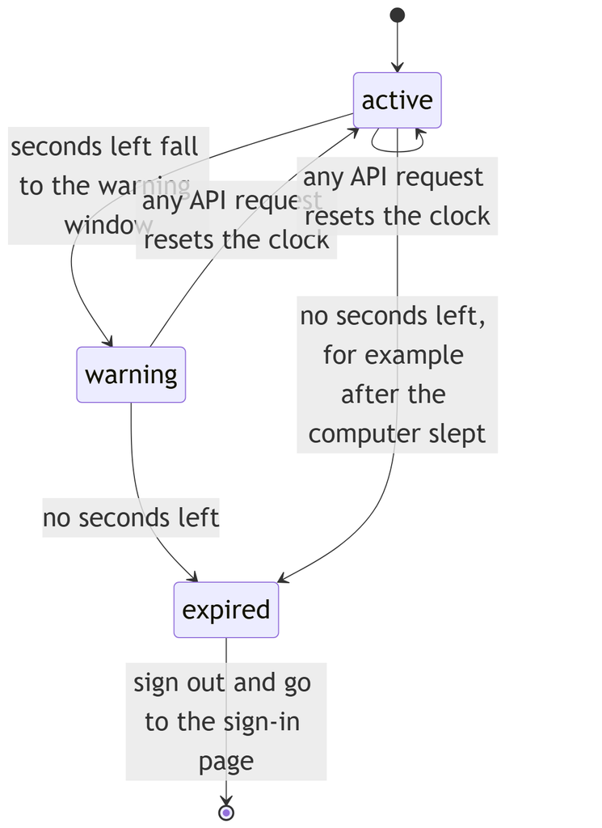

*Figure 19.1 — The idle states of `IdleState` and what moves between them*

*Text description:* A state diagram with three states: active, warning, and expired. The reader starts in active. Active moves to warning when the seconds left fall into the warning window, and warning moves to expired when no seconds are left. Active can also move straight to expired if the check is late, for example after the computer slept. Any API request returns active or warning to active, and expired ends the diagram with the reader signed out and sent to the sign-in page.

Notice that the diagram has exactly the states the type has, and no others: a value can never be "half-expired." `idleState` itself only *computes* which state applies from the current time and the last activity. The arrows that reset to `active` happen because every successful API request updates the last-activity time (Chapter 22). The last arrow happens in `App.checkIdle`, which signs the reader out when the state is `expired`.

### 19.4 Functions, arrow functions, modules

A function declares typed parameters and, after the parameter list, a return type.

**Listing 19.3 — `idle.ts` (book-m6-final, excerpt: the function)**

```typescript
export function idleState(nowMs: number, lastActivityMs: number, timeoutSeconds: number): IdleState {
  if (timeoutSeconds <= 0) {
    return { kind: 'active' };
  }
  const secondsLeft = Math.ceil(timeoutSeconds - (nowMs - lastActivityMs) / 1000);
  if (secondsLeft <= 0) {
    return { kind: 'expired' };
  }
  return secondsLeft <= Math.min(IDLE_WARNING_SECONDS, timeoutSeconds / 2)
    ? { kind: 'warning', secondsLeft }
    : { kind: 'active' };
}
```

*Path: `frontend/src/app/core/idle.ts`*

`IDLE_WARNING_SECONDS` is a constant defined near the top of `idle.ts`, before the function (`export const IDLE_WARNING_SECONDS = 5 * 60;`, so 300 seconds), left out of this excerpt. The function takes three numbers, returns an `IdleState`, and has no side effects (it changes nothing outside itself and reads nothing but its inputs): given the same three numbers it always gives the same answer. The compiler checks every `return` against `IdleState`; returning `{ kind: 'warnng' }` would be rejected. Notice `{ kind: 'warning', secondsLeft }`: when a variable has the same name as the property, TypeScript lets you write it once (`secondsLeft` instead of `secondsLeft: secondsLeft`). The condition `cond ? a : b` is the **conditional expression**, the same as in Java: "if `cond`, then `a`, otherwise `b`."

Read the arithmetic once, because the rest of the chapter assumes you can follow such lines. `nowMs - lastActivityMs` is how many milliseconds have passed since the last activity. Dividing by 1000 converts to seconds, and subtracting that from the timeout gives the seconds left. `Math.ceil` rounds up, so 0.2 seconds left still counts as one second (the countdown never shows zero while there is time). If nothing is left, the session has expired. Otherwise the reader is warned when the seconds left are within the warning window: the smaller of five minutes and half the timeout.

Small functions are often written as an **arrow function**, `(x) => expression`, which is the same idea as a Java lambda (Chapter 5). `this.tiles().filter((t) => t.status === 'loaded')` passes an arrow function that answers "is this tile loaded?" for each element.

A **module** is a file that lists what it shares with `export` and pulls in what it needs with `import`. That's how `viewer.component.ts` uses code from other files:

**Listing 19.4 — `viewer.component.ts` (book-m6-final, excerpt: two of its import lines, not adjacent in the file)**

```typescript
import { API_BASE_URL } from '../../core/config';
import { buildTileViewModels, TileViewModel } from './tile-view-model';
```

*Path: `frontend/src/app/features/viewer/viewer.component.ts`*

The path after `from` is where the code lives: `./` is "this folder" and `../` is "one folder up." Modules replace Java's `package` and `import` pair with a single mechanism where the file path is the address.

### 19.5 Worked example: reading a whole function

The best way to gain fluency is to read a real function slowly. `tile-view-model.ts` turns the server's description of a page into the rectangles the viewer draws (Chapter 21). Here is the function:

**Listing 19.5 — `tile-view-model.ts` (book-m6-final, excerpt: the function; the imports and the interface are omitted)**

```typescript
export function buildTileViewModels(grid: TileUrlGrid, pageInfo: PageInfo, apiBaseUrl: string): TileViewModel[] {
  const tiles: TileViewModel[] = [];
  for (let row = 0; row < grid.rows; row++) {
    for (let col = 0; col < grid.cols; col++) {
      const left = col * grid.tileSize;
      const top = row * grid.tileSize;
      const width = Math.min(grid.tileSize, pageInfo.pageWidthPx - left);
      const height = Math.min(grid.tileSize, pageInfo.pageHeightPx - top);
      tiles.push({
        key: `${row}-${col}`,
        url: `${apiBaseUrl}${grid.tileUrls[row][col]}`,
        top,
        left,
        width,
        height,
      });
    }
  }
  return tiles;
}
```

*Path: `frontend/src/app/features/viewer/tile-view-model.ts`*

Go through it in order.

1. **The signature.** It takes a `TileUrlGrid` (the server's answer to "which tile addresses for this page?"), a `PageInfo` (from Listing 19.1: the page's size in pixels), and a string to put in front of each address. It returns `TileViewModel[]`, an array of tile descriptions.
2. **`const tiles: TileViewModel[] = [];`** starts an empty array. `const` doesn't stop you from adding items; it only stops you from pointing `tiles` at a different array.
3. **Two nested loops.** `for (let row = 0; row < grid.rows; row++)` counts rows from 0, and the inner loop counts columns. `row++` adds one each time. Together they visit every cell of the grid, row by row.
4. **Position.** A tile's `left` edge is its column times the tile size, and its `top` is its row times the tile size.
5. **Size.** Most tiles are exactly `tileSize` wide and high, but the last column and row are usually smaller, because a page is rarely an exact multiple of the tile size. `Math.min(grid.tileSize, pageInfo.pageWidthPx - left)` picks the smaller of "a full tile" and "what remains of the page." The comment in the file says why: edge tiles are cropped, so each tile's size has to be derived from the page's dimensions rather than assumed to equal `tileSize`.
6. **`tiles.push({...})`** adds one description. `key` is a stable label made from the row and column with a template literal. `url` joins the base and the tile's address, found by a two-step lookup `grid.tileUrls[row][col]` (an array of arrays). The shorthand `top,` and `left,` means `top: top` and `left: left`.

A concrete case makes the edge logic visible. Suppose a page is 1,000 pixels wide and 1,300 pixels tall, and tiles are 512 pixels. Table 19.2 shows each tile:

Table 19.2 — Positions and sizes of four of the six tiles

| Tile (row, col) | left | top | width | height |
| --- | --- | --- | --- | --- |
| (0, 0) | 0 | 0 | 512 | 512 |
| (0, 1) | 512 | 0 | 488 (1,000 − 512) | 512 |
| (1, 0) | 0 | 512 | 512 | 512 |
| (2, 1) | 512 | 1,024 | 488 | 276 (1,300 − 1,024) |

The grid has 2 columns and 3 rows (1,000 ÷ 512 rounds up to 2, and 1,300 ÷ 512 rounds up to 3), so six tiles. Only the tiles outside the last row and the last column are full-size: here, the two tiles in the first column, in rows 0 and 1. This is the kind of small, self-contained, testable logic that TypeScript is good at, and it lives in its own file precisely so it can be understood in isolation.

### 19.6 Missing values and safe access

Real data has gaps: nobody is signed in yet, a document has no share count, a property is absent. TypeScript 6.0 helps by insisting you deal with them. The project's compiler options (Chapter 20) don't mention the `strict` setting. In TypeScript 6.0 the strict checks are switched on by default. Compiling a test file with this project's options rejects `let a: string = null;` (error `TS2322`) and a parameter with no type (error `TS7006`, "implicitly has an 'any' type"). So the compiler will not let you use a value that might be `null` as if it were surely there.

Three small tools make the handling readable, all visible in `session.service.ts`:

- **Optional chaining, `?.`,** stops and yields `undefined` if the thing before it is `null` or `undefined`. `this.current()?.username` means "the username, if there is a current user; otherwise nothing, and no crash."
- **Nullish coalescing, `??`,** supplies a default for `null` or `undefined`. `x ?? null` means "`x`, or `null` if `x` is missing."
- **The spread operator, `...`,** copies the properties of an object into a new one. `{ ...user, mustChangePassword: false }` means "a new object with everything `user` has, but with `mustChangePassword` set to false." The original isn't modified.

**Listing 19.6 — `session.service.ts` (book-m6-final, excerpts from two places in the class)**

```typescript
  readonly username = computed(() => this.current()?.username ?? null);
  // ...
        const user = this.current();
        if (user) {
          this.current.set({ ...user, mustChangePassword: false });
        }
```

*Path: `frontend/src/app/core/session.service.ts`*

The first line combines the first two tools: "the current user's name, or `null` if nobody is signed in." The second block is the end of the change-password method: it reads the current user, and only `if (user)`, meaning only when a user exists, does it store a *new* object with the flag turned off. Storing a new object rather than editing the old one matters in Chapter 21: signals notice a *replaced* value, not an edited one.

Arrays have handy methods you will see everywhere. `filter` keeps the elements that pass a test, `map` transforms each element, `some` asks "does any element pass?," and `includes` asks "is this in the list?." For example, the viewer counts loaded tiles with `this.tiles().filter((t) => t.status === 'loaded').length`, and the admin screen checks whether an event is a warning with `[...].includes(event.type)`.

## Intermediate tier: Asynchronous code, errors, and generics

*On a first read you can skip to "In this project"; Part IV comes back to this.*

### 19.7 `async`, promises and observables (only what the app uses)

A browser must never freeze while it waits for the network. So operations that take time don't return their result; they return a stand-in for it. TypeScript has two stand-ins that matter here.

A **Promise** stands for one result that will arrive later, or fail. An `async` function returns a promise, and inside it the keyword `await` pauses that function (not the browser) until the promise settles. Think of ordering at a coffee counter: you get a buzzer immediately, keep talking with friends, and collect the drink when the buzzer goes off.

**Where the analogy breaks down:** a buzzer goes off once, and so does a promise. But a promise can also end in failure, and a real buzzer has no such state. In code, a failed `await` throws an exception, which you catch with the `try`/`catch` you know from Java (Chapter 5).

An **Observable** stands for a *stream* of results over time: zero, one, or many values. It comes from a library called RxJS, which Angular's `HttpClient` uses (Chapter 22). You start it by calling `.subscribe(...)` with functions for "a value arrived" and "it failed." The project's rule of thumb: Angular's `HttpClient` gives Observables; the browser's `fetch()` gives Promises. You see the Promise side in `viewer.component.ts`:

**Listing 19.7 — `viewer.component.ts` (book-m6-final, excerpt: fetching one tile inside `fetchPendingTiles`)**

```typescript
        let response: Response;
        try {
          response = await fetch(tile.url, { signal, cache: 'no-store' });
        } catch {
          if (signal.aborted) {
            return;
          }
          this.updateTile(tile.key, { status: 'failed' });
          continue;
        }
```

*Path: `frontend/src/app/features/viewer/viewer.component.ts`*

`fetch(...)` returns a promise of a `Response`. `await` waits for it. If the network fails, the promise is rejected and the `catch` block runs. `signal` is an `AbortSignal`, which lets the viewer cancel every in-flight request at once when the reader turns the page, so a canceled fetch is not treated as an error. `cache: 'no-store'` tells the browser not to keep a copy of the tile. The annotation `let response: Response` is needed because the value is assigned inside `try`. `catch` without a name is allowed when you don't need the error object, and `continue` skips to the next loop round.

Several `await` loops can also run side by side. The viewer starts a fixed number of "workers" and waits for all of them:

```typescript
await Promise.all(Array.from({ length: MAX_CONCURRENT_TILE_FETCHES }, () => worker()));
```

`Array.from({ length: 6 }, () => worker())` creates six calls to `worker()`, each returning a promise (the constant is 6). `Promise.all` gives back one promise that settles when all six are done. Chapter 22 explains why the pool is small.

A function that hands out its result through an Observable can be converted for callers that need a Promise. `session.service.ts` uses `firstValueFrom(...)` to turn an HTTP Observable into a Promise, because Angular's startup hook (`provideAppInitializer`, Chapter 22) waits for a promise.

### 19.8 Reading TypeScript errors

The compiler's messages look intimidating, but they follow a pattern: a code (such as `TS2322`), a sentence saying what it found versus what it expected, and often extra lines drilling into why. Read the first line and the last line; the middle is detail.

**Example 19.3 — A typical error and how to read it**

```
error TS2322: Type '"PUBLIC"' is not assignable to type 'Visibility'.
```

Read it as: "you gave me `'PUBLIC'`, but this place accepts only a `Visibility`, and `'PUBLIC'` isn't one." The fix is on the line the error names: either the value is a typo, or the union (Listing 19.1) needs a new alternative, which then makes the compiler point at every place that must handle it.

Here are two errors that were produced by compiling a small test file with the project's compiler options and TypeScript 6.0.3 (the file is the author's experiment, not repository code):

```
t.ts(1,5): error TS2322: Type 'null' is not assignable to type 'string'.
t.ts(2,12): error TS7006: Parameter 'x' implicitly has an 'any' type.
```

The prefix `t.ts(1,5)` gives the file, line, and column, so you can jump straight to the spot. The first says a variable declared as `string` was given `null`: the fix is either to allow it (`string | null`) or to not assign it. The second says a function parameter has no type and the compiler can't work one out; `any` would switch checking off, so the compiler asks you to write a type. Two habits help when a message is long: fix the *first* error first, since later ones are often consequences, and read the last line of a multi-line message, which usually names the actual mismatch.

The project turns on a few extra checks in `tsconfig.json` (Chapter 20, Section 20.7). Two are worth knowing now: `noImplicitReturns` (a function whose branches sometimes return a value and sometimes don't is an error) and `noFallthroughCasesInSwitch` (a `switch` case that runs into the next one is an error).

> **Note:** The file doesn't contain the word `strict`. That is not the same as "not strict": in TypeScript 6.0 the strict family of checks is on unless you turn it off. Check the behavior of your own compiler version rather than the presence of a setting.

### 19.9 Types that mirror the API

The backend (Part II) sends JSON. The frontend describes what it expects with interfaces, one per response shape, kept in `*.models.ts` files. `DocumentDetail` in `document.models.ts`, for example, lists the fields the viewer needs: the page list, the `tileVersion`, and `canManage`.

Here is the backend's side of the same shape, the Java record from Part II:

**Listing 19.8 — `DocumentSummary.java` (book-m6-final, simplified: the package line and a documentation comment omitted)**

```java
public record DocumentSummary(
        String documentId,
        String title,
        int pageCount,
        String owner,
        Visibility visibility,
        long createdAtEpochSeconds,
        long updatedAtEpochSeconds,
        boolean canManage,
        Integer sharedWithCount
) {
}
```

*Path: `src/main/java/com/example/securedocviewer/document/DocumentSummary.java`*

Compare it with Listing 19.1 line by line. `String` becomes `string`, and `int` and `long` both become `number` (JavaScript has one number type). `boolean` stays. The Java enum `Visibility` becomes a union of its constant names. `Integer sharedWithCount`, which can be `null` in Java, becomes `number | null`. The names are identical because Jackson, the backend's JSON library, uses the record's field names as JSON keys.

Two rules keep these honest:

- **Field names and types must match the backend's response exactly.** `createdAtEpochSeconds: number` is a number of seconds since 1970 because that is what the backend sends; the frontend converts it for display (`new Date(epochSeconds * 1000)` in `document-list.component.ts`). When the backend changes a field, the interface must change in the same commit.
- **Nullable on the wire means `| null` in the type.** `sharedWithCount: number | null` exists because the count is only present when the reader can manage the document.

Now the limit promised in Section 19.1: these interfaces are a promise, not a check. `this.http.get<DocumentSummary[]>(this.base)` tells the compiler what to expect; nothing verifies the actual JSON at run time. If the backend sent a different shape, the compiler would stay silent and the page would break in front of a user. That is why the project's tests (Chapter 24) feed realistic JSON to the components, and why the server, not the frontend, is the authority on what is allowed (Chapter 23).

### 19.10 Generics: one function, many types

You met generics in Java (`List<String>`, Chapter 5). TypeScript's are the same idea. `HttpClient.get<T>` returns `Observable<T>`, and `signal<T>` (Chapter 21) holds a `T`. The project also defines one. In `manage.component.ts`, several server actions need the same busy flag and error notice, so one helper handles them:

**Listing 19.9 — `manage.component.ts` (book-m6-final, excerpt: method `run`)**

```typescript
  private run<T>(request: Observable<T>, onSuccess: (value: T) => void): void {
    this.busy.set(true);
    this.notice.set(null);
    request.subscribe({
      next: (value) => {
        this.busy.set(false);
        onSuccess(value);
      },
      error: (err: HttpErrorResponse) => {
        this.busy.set(false);
        this.confirmingDelete.set(false);
        this.notice.set({ kind: 'error', text: err.error?.error ?? 'Something went wrong.' });
      },
    });
  }
```

*Path: `frontend/src/app/features/documents/manage.component.ts`*

`<T>` is a placeholder filled in at each call: for `unshare` the request is an `Observable<string[]>`, so `T` is `string[]` and `onSuccess` must accept a `string[]`; for `replaceFile` it's `DocumentDetail`. The compiler checks each call separately. Without a generic, the project would need either a copy of `run` for every response type, or a version that accepts `any` and loses the checking.

### 19.11 Small type tools the app uses

Four small tools appear in the project, and a fifth, `as const`, follows them:

- `Partial<TileState>` means "an object with any subset of `TileState`'s properties." `updateTile(key, patch)` in the viewer uses it so callers can change only `{ status: 'failed' }`.
- `Record<string, () => void>` means "an object whose keys are strings and whose values are functions taking nothing." The viewer's keyboard handler (Chapter 23) uses it to map key names to actions.
- **Type assertions,** written `value as Type`, tell the compiler "trust me, this is a `Type`." They bypass a check, so they are used sparingly; the upload component uses one for `event.target as HTMLInputElement`, because the browser's generic event type doesn't know the target is a file input.
- **Extending an interface** adds properties to an existing shape, as Java's `extends` does. Listing 19.10 shows the viewer's tile state, which builds on the tile description this way.

**Listing 19.10 — `viewer.component.ts` (book-m6-final, excerpt: the tile state types)**

```typescript
type TileStatus = 'pending' | 'loaded' | 'failed';

interface TileState extends TileViewModel {
  /** Object URL of the fetched PNG, once loaded. */
  src: string | null;
  status: TileStatus;
}
```

*Path: `frontend/src/app/features/viewer/viewer.component.ts`*

A `TileState` has everything from Listing 19.5's `TileViewModel` (key, url, position, size) plus a `src` and a `status` that can only be one of three words. Because `status` is a union, a typo such as `'laoded'` fails to compile, and the `if (tile.status === 'loaded')` checks throughout the viewer can never silently compare against a word that doesn't exist.

The fifth tool is `as const`. It freezes an array of literals into exact types, and `typeof` reads the type of a value, so a list and its type stay in step. The admin screen's list of audit event types does this (Listing 19.11):

**Listing 19.11 — `admin.models.ts` (book-m6-final, simplified: the event names after `'SIGN_IN'`, 18 in all, are omitted at the `// ...` line)**

```typescript
export const AUDIT_EVENT_TYPES = [
  'PAGE_VIEWED',
  'TILE_VIEWED',
  'SIGN_IN',
  // ...
] as const;

export type AuditEventType = (typeof AUDIT_EVENT_TYPES)[number];
```

*Path: `frontend/src/app/features/admin/admin.models.ts`*

`as const` says the array is fixed and its elements are these exact words, not merely "some strings." `(typeof AUDIT_EVENT_TYPES)[number]` reads: the type of the array, indexed by any number, that is, "any one element": a union of all 21 names. The same list can drive a drop-down menu in the admin screen (it does), while the type prevents a filter from being set to a name that isn't in the list. One source of truth, no drift.

## Advanced tier: What types can't prevent

*On a first read you can skip to "In this project"; Part IV comes back to this.*

### 19.12 Stale answers: guarding async code with a generation counter

Types can't prevent a whole class of bugs that async code invites: an answer arriving after it has stopped being relevant. A reader flips from page 3 to page 4 while page 3's tiles are still downloading. If page 3's late responses were allowed to write into the page state, page 4 would show page 3's pixels.

The viewer prevents this with a plain counter, `loadGeneration`, incremented on every page change. Each fetch remembers the value it started with and drops its result if the value has moved on (`if (generation !== this.loadGeneration) { return; }`). The reset code shows the other half of the cleanup:

**Listing 19.12 — `viewer.component.ts` (book-m6-final, excerpt: method `resetPageState`)**

```typescript
  private resetPageState(): void {
    this.loadGeneration++;
    this.abortController.abort();
    this.abortController = new AbortController();
    this.gridSub?.unsubscribe();
    this.reloadSub?.unsubscribe();
    this.clearThrottle();
    for (const tile of this.tiles()) {
      if (tile.src) {
        URL.revokeObjectURL(tile.src);
      }
    }
    this.tiles.set([]);
  }
```

*Path: `frontend/src/app/features/viewer/viewer.component.ts`*

Step by step: bumping `loadGeneration` invalidates every answer still in flight. `abort()` cancels the network requests, and a fresh `AbortController` is made for the next page (a controller can be used only once). The two subscriptions are canceled with `?.unsubscribe()` (the `?.` from Section 19.6: "if there is one"). The throttle timers are cleared. Each tile's temporary `blob:` address is released with `URL.revokeObjectURL`, so the browser can free the image memory. The code comments in `viewer.component.ts` give the reason for bounding the requests: outstanding requests would otherwise keep spending the reader's rate-limit budget (Chapter 22). Nothing here is enforced by the compiler; it takes discipline, and `viewer.component.spec.ts` (Chapter 24) checks the visible consequences.

### 19.13 Why `fetch()` for tiles and not `HttpClient` or plain image URLs

The obvious alternatives are to let the browser load tiles itself from an image URL, or to use `HttpClient` like every other call. The comment on `MAX_CONCURRENT_TILE_FETCHES` in `viewer.component.ts` gives the project's reason: only `fetch()` exposes the response status, and a throttled (429) or expired (401) tile is otherwise indistinguishable from a blank one, so the page silently renders with holes. Chapter 22 shows the outcome handling; the point here is that these language choices (Promise-based `fetch`, `AbortSignal`) follow from what information the code needs.

### 19.14 Numbers and user input: two small traps

JavaScript numbers are double-precision floating point, which cannot represent most decimal fractions exactly. Adding 0.2 repeatedly to 1 shows the effect. Run in Node (Chapter 20):

```
1.2, 1.4, 1.5999999999999999, 1.7999999999999998
```

The viewer's zoom buttons add or subtract 0.2, so the project rounds after each step:

**Listing 19.13 — `viewer.component.ts` (book-m6-final, excerpt: method `zoomIn`)**

```typescript
  zoomIn(): void {
    this.zoom.update((z) => Math.min(MAX_ZOOM, +(z + 0.2).toFixed(2)));
  }
```

*Path: `frontend/src/app/features/viewer/viewer.component.ts`*

Read from the inside out: `z + 0.2` is the new zoom; `.toFixed(2)` rounds it to two decimals but returns *text*; the leading `+` converts the text back to a number; `Math.min(MAX_ZOOM, ...)` caps it at the maximum. With the rounding, the sequence is a clean 1.2, 1.4, 1.6, 1.8. The reader-visible percentage would look right either way, but other code compares the zoom with plain numbers (the swipe handler ignores swipes when `zoom() > 1`), and clean values keep those comparisons predictable.

The second trap is turning text from a form into a number. `Number('')` is `0`, `Number(' 3 ')` is `3`, `Number(null)` is `0`, and `Number('abc')` is `NaN` ("not a number"), which is not even equal to itself. So `Number(x)` alone can't tell "the user typed nothing" from "the user typed 0." The viewer's page-jump code guards against exactly that:

**Listing 19.14 — `viewer.component.ts` (book-m6-final, excerpt: method `goToPage`)**

```typescript
  goToPage(raw: string): void {
    const pageCount = this.manifest()?.pageCount ?? 0;
    const pageNumber = Number(raw);
    if (!raw.trim() || !Number.isInteger(pageNumber) || pageNumber < 1 || pageNumber > pageCount) {
      this.pageInputError.set(`Enter a whole number from 1 to ${pageCount}.`);
      return;
    }
    this.pageInputError.set(null);
    if (pageNumber - 1 !== this.currentPage()) {
      this.loadPage(pageNumber - 1);
    }
  }
```

*Path: `frontend/src/app/features/viewer/viewer.component.ts`*

The condition rejects, in order: blank text (`!raw.trim()`), anything that is not a whole number (`Number.isInteger` is false for `NaN` and for 2.5), and anything outside 1 to the page count. Only then does the code go on. Note the conversion at the end: the reader's page 3 becomes the code's index 2 (`pageNumber - 1`). This is user input; the type `string` on `raw` tells you nothing about whether it is *sensible*, which is why validation is code, not a type (Chapter 23 returns to this).

## Common mistakes

- **Using `==` instead of `===`.** The double-equals version converts types before comparing (`0 == ''` is true); the triple-equals version doesn't. The project uses `===` and `!==` throughout.
- **Forgetting `await`.** `const r = fetch(url)` gives you a promise, not a response. The compiler usually catches it when you then use `r.ok`.
- **Assuming a type checks the data.** `get<DocumentSummary[]>` is a promise to the compiler, not a validation of the JSON (Section 19.9).
- **Reaching for `any`.** It switches checking off for that value. Prefer a real type, a union, or `unknown` when you don't know the shape yet.
- **Mutating what a signal holds.** Editing an array or object in place doesn't tell Angular anything changed. Build a new value (`{ ...user, ... }`, `.map(...)`) and set it (Chapter 21).
- **Writing `Number(x)` and stopping.** It accepts blanks and returns `NaN` for junk. Combine it with `Number.isInteger` or `Number.isFinite`, and a range check.
- **Comparing floats for equality.** Round first, or compare within a tolerance, as the zoom code does.
- **Treating `null` and `undefined` as the same by accident.** `x ?? y` handles both; `x === null` only one. Know which your data can produce.
- **Leaving a `try`/`catch` empty.** The project's empty `catch` blocks carry a comment saying why ignoring is safe (for example, storage being unavailable); an unexplained empty `catch` hides bugs.

## In this project

| File | First appears | What it shows |
| --- | --- | --- |
| `frontend/src/app/features/documents/document.models.ts` | `book-m1-accounts` | Interfaces and unions mirroring the API |
| `frontend/src/app/core/idle.ts` | `book-m4-reading` | Discriminated union and a pure function |
| `frontend/src/app/features/viewer/tile-view-model.ts` | `book-m1-accounts` | A pure function with loops and `Math.min` |
| `frontend/src/app/core/session.service.ts` | `book-m1-accounts` | `Role` union, `Observable`, `?.`, `??`, spread, `firstValueFrom` |
| `frontend/src/app/features/viewer/viewer.component.ts` | `book-m1-accounts` | `async`/`await`, `fetch`, `Promise.all`, `AbortController`, number handling |
| `frontend/src/app/features/documents/manage.component.ts` | `book-m2-documents` | The generic helper `run<T>` |
| `frontend/src/app/features/admin/admin.models.ts` | `book-m1-accounts` | `as const` and derived union types |

See any of them at a tag with `git show book-m6-final:frontend/src/app/core/idle.ts`. The viewer grew over the milestones: its fetch loop and `AbortController` exist at `book-m1-accounts`, while page memory, swipe, and replaced-document handling arrive in later tags.

## Try it

### Exercise 19.1 ★ The nullable property

In `document.models.ts`, which property of `DocumentDetail` can be `null`, and for whom?

*Solution:* Appendix C, Exercise 19.1.

### Exercise 19.2 ★ A Direction type

Write a type `Direction` that allows only `'next'` or `'previous'`, and a function `step(current: number, d: Direction): number`.

*Solution:* Appendix C, Exercise 19.2.

### Exercise 19.3 ★★ Extend IdleState

In a scratch copy, add a fourth alternative `{ kind: 'paused' }` to `IdleState`. Does the compiler complain anywhere? Why or why not?

*Solution:* Appendix C, Exercise 19.3.

### Exercise 19.4 ★★ A fetchOrNull helper

Rewrite the `try`/`catch` in Listing 19.7 as a helper `fetchOrNull(url, signal): Promise<Response | null>`. How can a caller tell an abort from a network failure?

*Solution:* Appendix C, Exercise 19.4.

### Exercise 19.5 ★★★ A generic firstWhere

Write a generic function `firstWhere<T>(items: T[], test: (item: T) => boolean): T | null` and use it to find the first loaded tile.

*Solution:* Appendix C, Exercise 19.5.

### Exercise 19.6 ★★ Tile arithmetic

Using Listing 19.5, work out the position and size of every tile for a page 600 pixels wide and 800 pixels tall with tiles of 256 pixels. How many tiles are there, and what are the width and height of the bottom-right one?

*Solution:* Appendix C, Exercise 19.6.

## Summary

- TypeScript is JavaScript plus labels that a compiler checks and then erases; the browser runs plain JavaScript.
- Interfaces describe shapes, and unions restrict a value to a list of alternatives, which the app uses for roles, visibility, tile status, and idle states.
- Discriminated unions let the compiler track which fields exist in which state.
- Missing values are handled explicitly with `null`, `?.`, `??` and spreading into new objects; in TypeScript 6.0 the strict checks are on by default, even though this project's `tsconfig.json` never says `strict`.
- Promises and `await` handle a single delayed result, Observables handle streams; the app uses Observables for `HttpClient` and Promises for `fetch`.
- Generics such as `run<T>` share behavior across types while the compiler checks each use.
- Types mirror the API by agreement only; nothing checks JSON at run time.
- Async code and user input need discipline that types can't provide: the generation counter, number validation, and rounding.

Next, Chapter 20 introduces Node and npm, the tools that compile and run all of this.

## Further reading

- TypeScript Handbook, "Everyday Types" and "Narrowing": https://www.typescriptlang.org/docs/handbook/
- MDN Web Docs, "Using promises" and "Fetch API": https://developer.mozilla.org/
- RxJS documentation, "Observable": https://rxjs.dev/guide/observable

# Chapter 20: Node, npm, and the Angular toolchain

Browsers understand JavaScript, but you write TypeScript, split across dozens of files, using libraries other people wrote. Something has to fetch those libraries, compile your code, bundle it into a few files, and serve it while you work. That something is a set of tools built on Node.js and npm, and this chapter shows how the Secure Document Viewer's `frontend/` folder uses them, from the first command you type to the container image that goes to production.

## Learning objectives

By the end of this chapter, you will be able to:

- Explain what Node.js and npm are and why a browser application needs them at build time but not at run time.
- Read `package.json` and `package-lock.json` and say what each is for.
- Run the project's scripts and say what `ng serve`, `ng build` and `ng test` do.
- Trace what happens between typing `npm start` and seeing the app in a browser.
- Explain how the development proxy keeps the browser and the API on the same origin.
- Interpret `^` and `~` version ranges and the settings in the three `tsconfig` files.
- Explain why the project installs with `npm ci` and how it keeps its dependencies current and safe.

## Prerequisites

- Chapter 2: the command line (you will type commands).
- Chapter 6: Maven and project layout (npm plays the same role as Maven for the frontend).
- Chapter 8: how the web works (origins, cookies).
- Chapter 10: containers and Docker (images and build stages).
- Chapter 19: TypeScript.

If you have not installed Node yet, follow the setup chapter in the front matter first. You need Node 24 and the npm that comes with it.

## Beginner tier: Tools that turn source into a website

### 20.1 What Node is; why a frontend needs it

**Node.js** (Node for short) is a program that runs JavaScript outside a browser, on your own computer. Nobody uses Node to show pages to readers. It's used as a workshop: the compiler that turns TypeScript into JavaScript is itself a JavaScript program, so it runs on Node. So do the **bundler**, which gathers your many source files and the libraries they use into a few files a browser can download efficiently, and the test runner.

Think of a print shop. Readers only ever see the finished pamphlet, but to produce it the shop needs presses, cutters, and staplers, and someone who knows the order in which to run them. Node is the building's power supply and the operator's hands: it runs the machines and follows the instructions. Once the pamphlets are printed, you can switch the machines off.

**Where the analogy breaks down:** a print shop's pamphlets contain no trace of the machines. A web bundle does contain some code from the libraries you used (Angular itself is shipped to every reader). What stays behind is the tooling: the compiler and test runner never reach the reader.

That is why the project's production image uses two stages (Chapter 10). In the `frontend/Dockerfile`, the first stage starts from a Node image, installs dependencies, and builds. The second stage is only nginx, a web server, holding the finished files. The final image contains no Node at all. The project uses Node 24 (`node:24-alpine`).

### 20.2 Your first contact with Node

You can check that Node is installed, and see what it does, in a terminal (Chapter 2).

```bash
node --version
npm --version
```

You should see something like:

```
v24.x.x
11.x.x
```

The exact numbers depend on what you installed. The project's `package.json` names npm 11.19.0 (Section 20.3), so a much older npm may print warnings. Now run one line of JavaScript with Node, with no browser involved:

```bash
node -e "console.log(2 + 3)"
```

`-e` tells Node to evaluate the text that follows. `console.log` prints to the terminal. The output is `5`. This is the whole idea of Node: the same language the browser runs, but with your terminal as its screen and your files as its world. The Angular compiler is a much bigger program run the same way.

### 20.3 npm, `package.json`, `package-lock.json`

**npm** is Node's package manager: a tool that downloads libraries (packages) from a public registry (an online catalog of published packages, at npmjs.com) and puts them in a folder called `node_modules/`. It plays the role that Maven played for Java (Chapter 6), and `package.json` is the counterpart of `pom.xml`.

**Listing 20.1 — `package.json` (book-m6-final)**

```json
{
  "name": "frontend",
  "version": "0.0.0",
  "scripts": {
    "ng": "ng",
    "start": "ng serve",
    "build": "ng build",
    "watch": "ng build --watch --configuration development",
    "test": "ng test",
    "e2e": "playwright test"
  },
  "private": true,
  "packageManager": "npm@11.19.0",
  "dependencies": {
    "@angular/common": "^22.1.0",
    "@angular/compiler": "^22.1.0",
    "@angular/core": "^22.1.0",
    "@angular/forms": "^22.1.0",
    "@angular/platform-browser": "^22.1.0",
    "@angular/router": "^22.1.0",
    "rxjs": "~7.8.0",
    "tslib": "^2.3.0"
  },
  "devDependencies": {
    "@angular/build": "^22.1.8",
    "@angular/cli": "^22.1.8",
    "@angular/compiler-cli": "^22.1.0",
    "@axe-core/playwright": "^4.13.0",
    "@playwright/test": "^1.63.0",
    "jsdom": "^30.0.1",
    "prettier": "^3.8.1",
    "typescript": "~6.0.2",
    "vitest": "^5.0.1"
  }
}
```

*Path: `frontend/package.json`*

Read it top to bottom.

- `"name"` and `"version"` identify the project. The version `0.0.0` is a placeholder because the app is never published as a package.
- `"scripts"` names shortcuts you run with `npm run <name>` (or `npm start` and `npm test`, which npm treats specially). `npm test` runs `ng test`. The first script, `"ng": "ng"`, lets you run the Angular CLI (command line interface, Section 20.4) through npm as `npm run ng -- <arguments>`.
- `"private": true` stops the project from being published to the public registry by accident.
- `"packageManager"` records which npm version the project expects.
- `"dependencies"` are libraries the shipped app uses: Angular's pieces, RxJS (Chapter 19), and `tslib`, a small helper library the compiled code shares.
- `"devDependencies"` are tools used only while building and testing. They are the Angular CLI and build tooling, TypeScript, the test tools (`vitest`, `jsdom`, Chapter 24), Playwright and its accessibility add-on, and Prettier. Prettier is a code formatter, and `.prettierrc` sets a 100-column width and single quotes.

The split between the two groups matters. Anything in `dependencies` ends up, at least in part, inside the files readers download. Anything in `devDependencies` never leaves the build machine. When you add a library, ask which group it belongs to: "does the reader's browser need this code?"

> **Note:** Vitest 5.0.1 and jsdom 30 appear only at `book-m6-final`. Tags `book-m1-accounts` to `book-m5-platform` use Vitest 4.0.8 and jsdom 28, and Playwright and the accessibility add-on arrive at `book-m5-platform`.

`package-lock.json` is a much longer file (about 8,000 lines at this tag) that the tools write for you. `package.json` says "Angular 22.1 or newer, but not 23"; the lock file records the exact version that was actually installed, along with a fingerprint of each downloaded file. Here is the first part of one entry, the one for RxJS:

**Listing 20.2 — `package-lock.json` (book-m6-final, excerpt: the first lines of the `rxjs` entry)**

```json
    "node_modules/rxjs": {
      "version": "7.8.2",
      "resolved": "https://registry.npmjs.org/rxjs/-/rxjs-7.8.2.tgz",
      "integrity": "sha512-dhKf903U/PQZY6boNNtAGdWbG85WAbjT/1xYoZIC7FAY0yWapOBQVsVrDl58W86//e1VpMNBtRV4MaXfdMySFA==",
      "license": "Apache-2.0",
```

*Path: `frontend/package-lock.json`*

### 20.4 The Angular CLI: `ng serve`, `ng build`, `ng test`

The **Angular CLI** (command line interface) is the `ng` program. Three commands cover almost everything:

```bash
npm ci          # first install: an exact copy of the tested versions (use npm install when you add or change a dependency)
npm start       # ng serve: dev server at http://localhost:4200, reloads on save
npm test        # ng test: run the Vitest specs (keeps running in a terminal; see Section 24.2)
npm run build   # ng build: produce the deployable files under dist/
```

`ng serve` compiles the app in memory and serves it with a small **development server**, refreshing the browser whenever you save a file. `ng build` does the same once, with optimization. It shrinks the code (removing spaces and shortening names). It also adds a fingerprint to each filename, such as `main-AB12CD34.js`, so browsers can cache the files for a year and a changed file gets a new name. The nginx setup in Chapters 30 and 33 relies on that. The build settings live in `angular.json`. Its `build` target names the entry point (`src/main.ts`), the global stylesheet (`src/styles.css`) and size **budgets**, which are limits that raise a warning or an error when the build output grows too large. In production the initial bundle warns at 500 kB and fails at 1 MB, and any one component's styles warn at 4 kB and fail at 8 kB.

### 20.5 Worked example: from `npm start` to the browser

Suppose you have cloned the repository and want to see the frontend. Follow the sequence, and notice which file drives each step.

1. **You type `npm start` in `frontend/`.** npm looks in `package.json` under `"scripts"`, finds `"start": "ng serve"`, and runs that command.
2. **`ng` starts.** The Angular CLI reads `angular.json`. The `serve` target says which builder to use and points at `proxy.conf.json`. Its default configuration is `development`, which turns optimization off and turns on source maps (files that let the browser's developer tools show your TypeScript instead of the generated JavaScript).
3. **The build target is compiled.** The `build` target names `src/main.ts` as the entry point and `tsconfig.app.json` as the compiler settings. The compiler follows every `import` from `main.ts` outward, so it finds every file that matters without you listing them. TypeScript becomes JavaScript, templates are compiled (Chapter 21), and everything is bundled.
4. **The dev server listens.** By default the Angular CLI serves at `http://localhost:4200`; you can confirm it in the terminal output when `ng serve` starts.
5. **The browser asks for `/`.** The server answers with `src/index.html`, which is almost empty:

**Listing 20.3 — `index.html` (book-m6-final)**

```html
<!doctype html>
<html lang="en">
<head>
  <meta charset="utf-8">
  <title>Secure Doc Viewer</title>
  <base href="/">
  <meta name="referrer" content="no-referrer">
  <meta name="viewport" content="width=device-width, initial-scale=1">
  <link rel="icon" type="image/x-icon" href="favicon.ico">
</head>
<body>
  <app-root></app-root>
</body>
</html>
```

*Path: `frontend/src/index.html`*

Line by line: `<!doctype html>` says this is a modern HTML page. `lang="en"` states the language, which screen readers use to pick a pronunciation. `<meta charset="utf-8">` fixes the text encoding (Chapter 2). `<base href="/">` tells the router (Chapter 23) that every relative address starts from the root. `<meta name="referrer" content="no-referrer">` asks the browser not to tell other sites which page a reader came from; the viewport line makes the page fit phone screens. Inside `<body>`, the only content is the custom tag `<app-root>`. The bundler has quietly added `<script>` tags for the compiled files; you don't write them.

6. **The scripts run `main.ts`,** which starts the application:

**Listing 20.4 — `main.ts` (book-m6-final)**

```typescript
import { bootstrapApplication } from '@angular/platform-browser';
import { appConfig } from './app/app.config';
import { App } from './app/app';

bootstrapApplication(App, appConfig)
  .catch((err) => console.error(err));
```

*Path: `frontend/src/main.ts`*

`bootstrapApplication(App, appConfig)` creates the root component `App` (Chapter 21) at the place where `<app-root>` sits, and gives it the app-wide settings from `appConfig` (Chapter 22). `.catch(...)` prints a startup error to the browser's console instead of failing silently. From here on, Angular draws the screen.

7. **You edit a file and save.** The dev server notices, recompiles only what changed, and tells the browser to reload. That loop, edit, save, see the result within seconds, is the main reason the tooling exists.

## Intermediate tier: Same origin, compiler settings, and choosing tools

*On a first read you can skip to "In this project"; Part IV comes back to this.*

### 20.6 The dev proxy (`proxy.conf.json`) and same origin

An origin is the combination of scheme, host, and port: `http://localhost:4200` and `http://localhost:8080` are different origins. Browsers keep origins apart; a page from one may not freely call another. Cookies and the Cross-Site Request Forgery (CSRF) protection from Part II (Chapter 16) assume the page and the API share an origin.

In development the pieces run on two ports: `ng serve` on 4200 and Spring Boot on 8080. The dev server bridges them with a proxy: it forwards any request whose path starts with `/api` to the backend, so the browser thinks it is talking to one server.

**Listing 20.5 — `proxy.conf.json` (book-m6-final)**

```json
{
  "/api": {
    "target": "http://localhost:8080",
    "secure": false,
    "changeOrigin": false,
    "logLevel": "warn"
  }
}
```

*Path: `frontend/proxy.conf.json`*

`angular.json` points the dev server at this file (`"proxyConfig": "proxy.conf.json"`). `target` is where Spring Boot listens. `secure: false` means the proxy doesn't insist on a valid HTTPS certificate for the target (it's plain HTTP on your own machine). `changeOrigin: false` leaves the `Host` header as the browser sent it. `logLevel: "warn"` prints only warnings and errors.

Figure 20.1 shows the path a request takes while you develop.

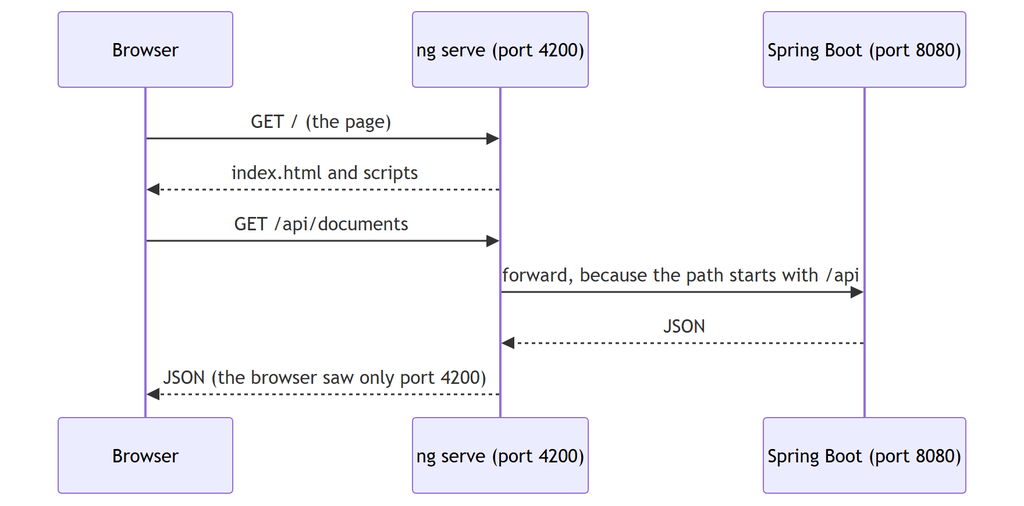

*Figure 20.1 — Requests in development*

*Text description:* A sequence diagram with three participants: the browser, the `ng serve` development server on port 4200, and Spring Boot on port 8080. The browser asks the development server for the page and receives `index.html` and the scripts. It then asks the same server for `/api/documents`, and the development server forwards that request to Spring Boot and passes the JSON back. Notice that the browser only ever talks to port 4200.

The frontend code itself stays free of this: `core/config.ts` sets `API_BASE_URL = ''`, so every call is a relative URL such as `/api/documents`. In production the same job is done by nginx, whose `location ^~ /api/` block forwards to the backend (Chapters 30 and 33). The same code therefore works unchanged in both places.

**Why not let the browser call port 8080 directly?** It is the obvious alternative: fewer moving parts, and you would see the backend's errors straight away. But a page on port 4200 calling port 8080 is a cross-origin request, which the browser allows only if the backend explicitly permits it (a mechanism called cross-origin resource sharing, or CORS). It would also work against the project's cookie-based sign-in design. The project relies on the browser sending its session cookie and Angular copying the CSRF cookie into a header (Chapter 22). Both are simplest and safest when the page and the API share one origin. Keeping one origin in development means the code you test is the code you ship. The price is a small config file and one more process in the picture.

### 20.7 Project layout and tsconfig

Table 20.1 lists the contents of `frontend/`, from the top:

Table 20.1 — The layout of `frontend/`

| Path | Purpose |
| --- | --- |
| `src/main.ts` | The entry point: starts the app |
| `src/index.html` | The one HTML page; contains `<app-root>` |
| `src/styles.css` | Global styles and theme tokens (Chapter 21) |
| `src/app/` | The application: `core/` (session, guards), `features/` (screens) |
| `public/` | Files copied unchanged (the favicon) |
| `e2e/` | Playwright tests (Chapter 24) |
| `tsconfig*.json` | TypeScript settings |
| `Dockerfile`, `nginx.conf` | How the production image is built and served |
| `.dockerignore`, `.gitignore` | What to leave out of the image and out of Git |
| `.editorconfig`, `.prettierrc` | Formatting rules shared by editors and the formatter |

Inside `src/app/`, two folders organize the code. `core/` holds things the whole app shares (the session service, the interceptor, the route guards, idle-timeout arithmetic). `features/` holds one folder per screen area: `auth`, `documents`, `viewer`, `admin`. A new reader can find code by asking "is it shared, or does it belong to one screen?"

Three `tsconfig` files exist: `tsconfig.json` (shared settings), `tsconfig.app.json` (the app: all `src/**/*.ts` except specs) and `tsconfig.spec.json` (the specs, with Vitest's global functions such as `describe` and `it` available). The app file sets `"types": []`, so no test globals leak into production code. The shared file's options are short enough to read in full:

**Listing 20.6 — `tsconfig.json` (book-m6-final, excerpt: the `compilerOptions` block)**

```json
  "compilerOptions": {
    "noImplicitOverride": true,
    "noPropertyAccessFromIndexSignature": true,
    "noImplicitReturns": true,
    "noFallthroughCasesInSwitch": true,
    "skipLibCheck": true,
    "isolatedModules": true,
    "experimentalDecorators": true,
    "importHelpers": true,
    "target": "ES2022",
    "module": "preserve"
  },
```

*Path: `frontend/tsconfig.json`*

- `noImplicitOverride` requires the word `override` when a class replaces a method from its parent, so an accidental name clash can't slip through.
- `noPropertyAccessFromIndexSignature` makes you write `process.env['CI']` (brackets) rather than `process.env.CI` for values found by key. You can see the effect in `playwright.config.ts`, which uses `process.env['CI']`.
- `noImplicitReturns` and `noFallthroughCasesInSwitch` are the two checks described in Chapter 19.
- `skipLibCheck` skips re-checking the type declarations of installed libraries, which saves time.
- `isolatedModules` requires each file to be understandable on its own, which fast tools need.
- `experimentalDecorators` enables the `@Component(...)` labels from Chapter 21.
- `importHelpers` reuses the small helpers in `tslib` rather than copying them into every file.
- `"target": "ES2022"` is the JavaScript version to produce, and `"module": "preserve"` leaves `import` statements alone for the bundler.

As Chapter 19 noted, the file never mentions `strict`. That does not mean the strict checks are off: in TypeScript 6.0 they are on by default (compiling a test file with these options rejects assigning `null` to a `string` and untyped parameters). If you need to know what a setting is at your compiler version, test it, as the chapter did, rather than reading the absence of a line as "off."

### 20.8 Semantic versions, `^` and `~`

Most packages number releases `MAJOR.MINOR.PATCH`, such as 22.1.8. By convention a patch fixes bugs, a minor adds features without breaking anything, and a major may break things. This is **semantic versioning**.

- `^22.1.0` accepts any 22.x.y that is 22.1.0 or newer (minor and patch updates, never 23).
- `~6.0.2` accepts only 6.0.x from 6.0.2 up (patches only).

The project uses `~` on TypeScript because each Angular release supports a narrow range of TypeScript versions, and on RxJS to stay on the 7.8 line. The lock file, not the range, decides what you actually get: TypeScript is `~6.0.2` in `package.json` and 6.0.3 in the lock.

Table 20.2 makes the rule concrete. Suppose a project asks for `^22.1.8` and the registry later publishes these versions:

Table 20.2 — Which new versions the range `^22.1.8` accepts

| New version | Accepted by `^22.1.8`? | Reason |
| --- | --- | --- |
| 22.1.9 | Yes | Patch update |
| 22.4.0 | Yes | Minor update, same major |
| 23.0.0 | No | New major: may break things |
| 22.1.7 | No | Older than the stated minimum |

Remember that "accepted" describes what an update *may* pick. With a lock file, `npm ci` installs exactly the locked version regardless (Section 20.10).

### 20.9 Why npm and the Angular CLI, and not the alternatives

Every choice in this chapter has an obvious alternative, and it's worth naming them so you can judge the project's choices.

- **npm versus other package managers.** Yarn and pnpm do the same job and are popular. They are faster in some situations and store shared libraries more economically. The project's files show that it uses plain npm (the Dockerfile and CI both call it, and the `packageManager` field pins its version); the project records no reasoning for preferring it to Yarn or pnpm. Reasons a team might have: npm comes with Node, so there is nothing extra to install, and for a small team "fewer tools" can be worth more than a speed gain.
- **The Angular CLI versus assembling your own build.** You could wire together a compiler, a bundler, a dev server, and a test runner yourself. The CLI packages those with defaults chosen and updated together by the Angular team (`@angular/build`, `@angular/cli`), so an upgrade is one coordinated step. The cost is that you accept its conventions and its configuration file, `angular.json`.
- **Vitest through the CLI versus a separate runner.** The `test` target in `angular.json` uses the CLI's own unit-test builder, so `ng test` and `npm test` behave the same locally and in CI (Chapter 24).

None of these is "the right answer" in general; they are reasonable defaults for a project whose priority is a small, reviewable toolchain.

## Advanced tier: Reproducible and safe installs

*On a first read you can skip to "In this project"; Part IV comes back to this.*

### 20.10 `npm install` versus `npm ci`

`npm install` may update the lock file if ranges allow newer versions. `npm ci` installs exactly what the lock file says and fails if `package.json` and the lock file disagree. The Dockerfile uses `npm ci --no-audit --no-fund`, so an image rebuilt next month contains the same packages that were tested. (`--no-audit` and `--no-fund` switch off two informational steps npm otherwise performs: a vulnerability report and a funding message. CI has its own vulnerability scan, Section 20.12.) The base images are also pinned by digest, a fingerprint (hash) of the exact image contents, so a rebuild can't silently pick up a different one.

**Listing 20.7 — `Dockerfile` (book-m6-final, excerpt: the build stage)**

```
FROM node:24-alpine@sha256:ebfe2f90462722a7a4de65e91990e97fe0d401c70e0e762c5b53302f905ec1c1 AS build
WORKDIR /src
COPY package.json package-lock.json ./
RUN npm ci --no-audit --no-fund
COPY . .
RUN npx ng build --configuration production
```

*Path: `frontend/Dockerfile`*

The order of these lines is deliberate. Docker builds an image in layers and reuses a layer if none of the earlier lines changed (Chapter 10). Copying only `package.json` and `package-lock.json` first, and running `npm ci`, means the slow download step is repeated only when the dependency files change. Copying the rest of the source afterward means an ordinary code edit re-runs only the fast `ng build`. `.dockerignore` keeps `node_modules/`, `dist/` and `.angular/` (the compiler's cache) out of the build, so your local installation never leaks into the image.

### 20.11 Automated updates, deliberately limited

Dependencies age, and old ones carry known security problems. The project uses GitHub's Dependabot (`.github/dependabot.yml`) to open weekly pull requests, and its configuration for the frontend is worth reading:

**Listing 20.8 — `dependabot.yml` (book-m6-final, excerpt: the npm section)**

```yaml
  - package-ecosystem: npm
    directory: /frontend
    schedule:
      interval: weekly
    groups:
      angular:
        patterns: ['@angular/*', '@angular-devkit/*']
      npm-other:
        patterns: ['*']
        exclude-patterns: ['@angular/*', '@angular-devkit/*']
        # Majors arrive as separate PRs, so one breaking upgrade can't hold back the rest.
        update-types: ['minor', 'patch']
    ignore:
      # Angular pins the TypeScript range it supports; TypeScript moves with Angular upgrades.
      - dependency-name: typescript
        update-types: ['version-update:semver-major', 'version-update:semver-minor']
```

*Path: `.github/dependabot.yml`*

Angular packages are grouped so they upgrade together (mixing versions of Angular's parts risks a broken build). All other packages are grouped as minor and patch updates, and major upgrades arrive as separate pull requests so one breaking change can't hold back the rest. It never proposes TypeScript major or minor upgrades, because TypeScript moves with Angular. The same file has a rule for container images: it ignores Node's non-LTS lines. **LTS** means "long-term support" and marks the releases that receive fixes for years. The file's comment says odd-numbered Node releases never become LTS, and it skips Node 25, 27, and 29. The history shows this working. The Vitest 4 to 5 upgrade (pull request 11) and the jsdom 28 to 30 upgrade (pull request 12) arrived as separate, reviewable changes after `book-m5-platform`, which is why Vitest 5 appears only at `book-m6-final`. Chapter 36 covers the supply chain in full.

### 20.12 What the CI does with the frontend

Two jobs in `.github/workflows/ci.yml` tie the toolchain together. The "Frontend tests & build" job installs Node 24, runs `npm ci --no-audit --no-fund`, then `npx ng test --watch=false` and `npx ng build --configuration production`. A separate "dependency-scan" job runs a scanner over `frontend/package-lock.json` (and the backend's `pom.xml`) and fails the build if any library, direct or indirect, has a published vulnerability. That explains why the lock file, which lists every indirect library, matters for security as well as for reproducibility: it is the list the scanner reads.

## Common mistakes

- **Running commands in the wrong folder.** `npm start` in the repository root fails with a message that no `package.json` was found. The frontend lives in `frontend/`; `cd frontend` first.
- **Starting the frontend without the backend.** The page loads, but every call to `/api/...` fails, and the dev server prints a proxy error to the terminal (its `logLevel` is `warn`, so problems are shown). Start Spring Boot on port 8080 first.
- **Port already in use.** If another program holds port 4200, `ng serve` says so and offers another port. Stop the other program, or accept the offer; the proxy still works on a different port.
- **Editing `package-lock.json` by hand,** or resolving a merge conflict in it by picking lines. Fix `package.json`, then run `npm install` and let npm rewrite the lock file.
- **Committing `node_modules/`.** It is huge and machine-specific. `.gitignore` lists it for that reason; if Git shows it as changed, something is wrong with your ignore file.
- **Using `npm install` in CI and Docker.** It may quietly change versions. Use `npm ci` where you need the tested set.
- **Changing a version range to "fix" a problem.** If a build fails after an update, look at the error first; loosening a range to `*` invites the next surprise.
- **Mixing versions of Angular's packages.** All the `@angular/*` packages should be on the same major version. That is why the project updates them as one group.

## In this project

| File | First appears | What it does |
| --- | --- | --- |
| `frontend/package.json`, `package-lock.json` | `book-m1-accounts` | Scripts, dependencies, exact versions |
| `frontend/angular.json` | `book-m1-accounts` | Build, serve and test targets; size budgets; proxy setting |
| `frontend/proxy.conf.json` | `book-m1-accounts` | Dev-time forwarding of `/api` |
| `frontend/tsconfig.json`, `tsconfig.app.json`, `tsconfig.spec.json` | `book-m1-accounts` | Compiler settings |
| `frontend/Dockerfile`, `.dockerignore` | `book-m5-platform` | Node build stage, nginx serving stage, `npm ci` |
| `.github/dependabot.yml` | `book-m5-platform` (see Chapter 36) | Weekly grouped update pull requests |

Try `git show book-m6-final:frontend/package.json`, and compare it with `git show book-m1-accounts:frontend/package.json` to see what testing added.

## Try it

### Exercise 20.1 ★ Which script needs more than Node?

Which of the six `scripts` in Listing 20.1 needs a running stack besides Node? (Hint: read `frontend/playwright.config.ts`.)

*Solution:* Appendix C, Exercise 20.1.

### Exercise 20.2 ★ Reading a version range

What range of versions does `^22.1.8` accept? Would 22.9.0 be accepted? 23.0.0?

*Solution:* Appendix C, Exercise 20.2.

### Exercise 20.3 ★★ Why `secure: false` is fine here

Explain in your own words why `"secure": false` in Listing 20.5 is acceptable in development but would be a concern for a production proxy.

*Solution:* Appendix C, Exercise 20.3.

### Exercise 20.4 ★★ Build the app

Install Node 24 and npm as described in the setup chapter (front matter), then run `npm ci` in `frontend/` and `npm run build`. What folder appears, and what do the filenames inside look like?

*Solution:* Appendix C, Exercise 20.4.

### Exercise 20.5 ★★★ No lock file

Suppose `package.json` says `~6.0.2` but the lock file is deleted. Explain what `npm install` may now do and why `npm ci` refuses to run.

*Solution:* Appendix C, Exercise 20.5.

### Exercise 20.6 ★★ Reorder the Dockerfile

Suppose someone rewrites Listing 20.7 so that `COPY . .` comes before `npm ci`. What changes for a developer who edits one component file and rebuilds the image? Why?

*Solution:* Appendix C, Exercise 20.6.

## Summary

- Node runs JavaScript tools on your machine; the reader's browser never sees it, and the production image contains no Node.
- `package.json` declares what the project needs; `package-lock.json` records exactly what was installed, with a fingerprint for each file.
- `ng serve`, `ng build` and `ng test` are the daily commands; `npm start` runs `ng serve` through the `scripts` table.
- The chain from command to browser is: script, `angular.json`, `main.ts`, `index.html`, the compiled `App` component.
- The dev proxy forwards `/api` to Spring Boot so the browser sees one origin, and nginx does the same in production.
- `^` allows minor and patch updates; `~` allows only patches; the lock file decides the actual version.
- `npm ci`, layer-ordered Dockerfiles and digest-pinned images make builds reproducible; grouped Dependabot pull requests and a lock-file scan keep them current and safe.

Next, Chapter 21 opens `src/app/` and builds screens from components.

## Further reading

- Node.js documentation: https://nodejs.org/docs/latest/api/
- npm documentation, "package.json" and "npm ci": https://docs.npmjs.com/
- Angular documentation, "Angular CLI" and "Workspace configuration": https://angular.dev/tools/cli
- Semantic Versioning 2.0.0: https://semver.org/
- TypeScript documentation, "tsconfig reference": https://www.typescriptlang.org/tsconfig/

# Chapter 21: Angular components and templates

Every screen of the Secure Document Viewer is an Angular component: the top bar, the sign-in form, the document list, and the page viewer. In this chapter you learn what a component is, how its template shows data and reacts to change, and how the app's stylesheet gives every screen a consistent look in light and dark themes. You will also see how the viewer paints a PDF page out of many small pieces without using an image tag, and why.

## Learning objectives

By the end of this chapter, you will be able to:

- Explain the three parts of a component (class, template, style) and read `app.ts`.
- Describe a component's life, from creation to removal, using lifecycle hooks.
- Write a template that shows a value, a condition, and a list, using `{{ }}`, `@if` and `@for`.
- Explain what a signal is, and use `signal`, `set`, `update` and `computed`.
- Read the theme tokens in `styles.css` and explain how dark mode and contrast are handled.
- Explain how the viewer paints page tiles without an `<img>` tag.

## Prerequisites

- Chapter 19: TypeScript (classes, types, arrow functions).
- Chapter 20: Node, npm, and the Angular toolchain (`ng serve`, project layout).

## Beginner tier: A screen is a small machine with three parts

### 21.1 Components: a class, a template, a style

An **Angular** component is one reusable piece of screen. Think of a name badge holder at a conference: the plastic holder is always the same, and you slide a different card in. The component is the holder; the data it displays is the card.

**Where the analogy breaks down:** a badge holder is passive, and you swap the card by hand. A component watches its data and redraws itself when the data changes.

A component has three parts. The class holds the data and actions, in TypeScript. The **template** is the HTML that shows them; HTML is the markup language that describes the structure of a web page, such as headings, buttons, and links. The **stylesheet** is CSS, the language that sets colors, spacing, and layout. The top-level component of the app is short enough to read whole:

**Listing 21.1 — `app.ts` (book-m6-final, excerpt: imports and decorator)**

```typescript
import { LowerCasePipe } from '@angular/common';
import { Component, OnDestroy, OnInit, signal } from '@angular/core';
import { Router, RouterLink, RouterLinkActive, RouterOutlet } from '@angular/router';
import { IdleState, idleState } from './core/idle';
import { SessionService } from './core/session.service';

@Component({
  selector: 'app-root',
  standalone: true,
  imports: [RouterOutlet, RouterLink, RouterLinkActive, LowerCasePipe],
  templateUrl: './app.html',
  styleUrl: './app.css',
})
export class App implements OnInit, OnDestroy {
  readonly idle = signal<IdleState>({ kind: 'active' });
```

*Path: `frontend/src/app/app.ts`*

Line by line:

- `@Component({ ... })` is a **decorator**: a label attached to the class it decorates that tells Angular "this class is a component, configured like so."
- `selector: 'app-root'` is the custom HTML tag that shows this component. `src/index.html` contains `<app-root></app-root>` (Chapter 20, Listing 20.3), and that is where the whole application appears.
- `standalone: true` means the component lists its own dependencies rather than relying on a shared module. (Angular 22 treats components as standalone by default; the project states it explicitly.)
- `imports: [...]` lists the other building blocks that this component's template uses: other components, pipes (formatters, Section 21.3), and directives (extra behavior attached to an element, such as `routerLink`, which turns an ordinary link into an in-app one). If the template uses `routerLink` but `RouterLink` isn't listed here, the compiler complains.
- `templateUrl` and `styleUrl` point to the files `app.html` and `app.css` beside it.
- `export class App implements OnInit, OnDestroy` defines the class. `OnInit` and `OnDestroy` are **lifecycle hooks**: methods (`ngOnInit`, `ngOnDestroy`) that Angular calls when the component appears and when it is removed. Section 21.2 shows what `App` does in them.
- `readonly idle = signal<IdleState>(...)` is a piece of reactive data; Section 21.5 explains it.

The app starts in `main.ts` with `bootstrapApplication(App, appConfig)`, which creates the root component and hands it the app-wide settings (Chapter 22).

Figure 21.1 shows how the pieces you have met so far nest. The page contains one tag, `<app-root>`; the root component draws the top bar, the idle banner, and a `<router-outlet />`; and the outlet holds whichever screen component the current address selects (Chapter 23).

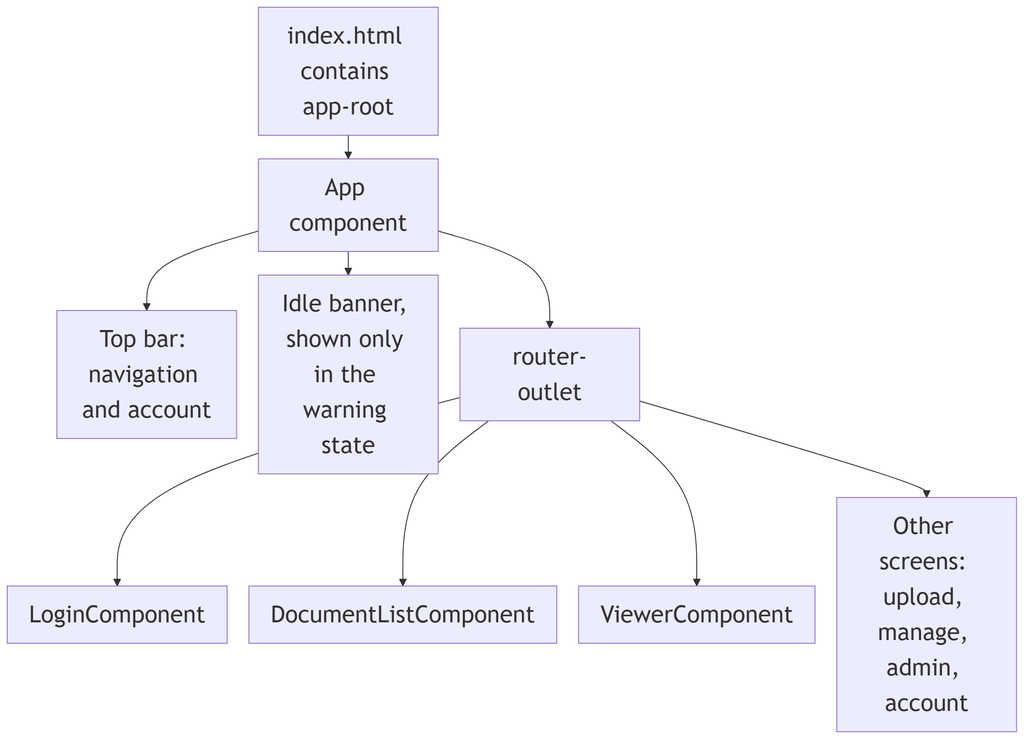

*Figure 21.1 — The component tree: from `index.html` to the current screen*

*Text description:* A tree diagram drawn top to bottom. `index.html` contains the `app-root` tag, which shows the App component. App has three children: the top bar, the idle banner (shown only in the warning state) and the router outlet. The router outlet holds one screen at a time: the sign-in screen, the document list, the viewer, or another screen. Notice that the top bar and banner belong to App, so they stay while the screens change.

Only one of the screen components exists at a time: when the reader navigates, Angular destroys the old one and creates the new one inside the same outlet. The top bar and the idle banner belong to `App`, so they survive every navigation.

### 21.2 A component's life: creation, hooks, and cleanup

A component isn't a permanent object. Angular **creates** it when it's needed (when the router visits its route, or when a parent's template contains its tag), **runs** it while it's on screen, and **destroys** it when it's removed. Lifecycle hooks let the class react at those moments. `App` uses two of them for a single job: a one-second timer that checks whether the reader has been idle.

**Listing 21.2 — `app.ts` (book-m6-final, excerpt: the timer and its cleanup)**

```typescript
export class App implements OnInit, OnDestroy {
  readonly idle = signal<IdleState>({ kind: 'active' });
  private idleTimer: ReturnType<typeof setInterval> | null = null;

  constructor(
    readonly sessionService: SessionService,
    private readonly router: Router,
  ) {}

  ngOnInit(): void {
    this.idleTimer = setInterval(() => this.checkIdle(), 1000);
  }

  ngOnDestroy(): void {
    if (this.idleTimer !== null) {
      clearInterval(this.idleTimer);
    }
  }
```

*Path: `frontend/src/app/app.ts`*

(Excerpt: the rest of the class, which holds `staySignedIn`, `formatCountdown`, `checkIdle` and `logout`, is omitted.)

- The constructor runs first, when the object is created. Its parameters are how Angular hands over the services the class needs (dependency injection, Chapter 22). Here it asks for the `SessionService` and the `Router`. `private readonly` and `readonly` in front of a parameter declare it as a field in one step; `readonly` means the field can't be reassigned, and leaving out `private` (as with `sessionService`) lets the template read it, which it does.
- `ngOnInit` runs once, after the constructor, when the component is ready. It starts a timer with `setInterval(() => this.checkIdle(), 1000)`: "every 1,000 milliseconds, call `checkIdle`." `setInterval` returns a number-like handle, which the class stores in `idleTimer` so it can be stopped later. Its type, `ReturnType<typeof setInterval> | null`, means "whatever `setInterval` returns, or `null` before it starts."
- `ngOnDestroy` runs when the component is removed. It stops the timer with `clearInterval`. Forgetting this is a classic leak: the timer would keep calling `checkIdle` on a component that no longer exists.

The same start-then-clean-up habit appears wherever a component starts something that outlives a single call: timers, subscriptions to Observables, and in the viewer, in-flight requests and temporary image addresses (Chapter 22).

### 21.3 Templates: binding, conditionals, loops

A template is HTML with extra syntax that connects it to the class. Here is the top-level template:

**Listing 21.3 — `app.html` (book-m6-final)**

```html
<header class="topbar">
  <div class="brand">Secure Doc Viewer</div>

  @if (sessionService.user(); as user) {
    <nav>
      <a routerLink="/documents" routerLinkActive="active">Documents</a>
      @if (sessionService.isAdmin()) {
        <a routerLink="/admin" routerLinkActive="active">Admin</a>
      }
    </nav>
    <div class="account">
      <a class="account-link" routerLink="/account" routerLinkActive="active">
        {{ user.username }} <span class="role-badge">{{ user.role | lowercase }}</span>
      </a>
      <button (click)="logout()">Sign out</button>
    </div>
  }
</header>

@if (idle(); as state) {
  @if (state.kind === 'warning') {
    <div class="idle-banner" role="alert">
      You'll be signed out in {{ formatCountdown(state.secondsLeft) }} because of inactivity.
      <button (click)="staySignedIn()">Stay signed in</button>
    </div>
  }
}

<main>
  <router-outlet />
</main>
```

*Path: `frontend/src/app/app.html`*

The template syntax comes in a handful of forms:

- `{{ user.username }}` is **interpolation**: it inserts the value of an expression as text. Angular escapes it, so a username containing `<script>` appears as harmless text, not code. That is a security property you get for free, as long as you use interpolation and not raw HTML insertion.
- `{{ user.role | lowercase }}` pipes the value through a **pipe**, a small formatter. `lowercase` is why the imports list has `LowerCasePipe`.
- `@if (condition) { ... }` shows its block only when the condition is true. `@if (sessionService.user(); as user)` also names the value `user` for use inside the block. The nav bar therefore exists only when someone is signed in, and the Admin link only for administrators.
- `(click)="logout()"` is an **event binding**: when the button is clicked, call the class's `logout` method.
- `routerLink="/documents"` makes a link that changes pages without reloading the browser (Chapter 23), and `routerLinkActive="active"` adds the CSS class `active` to the link when its address is the current one, which `app.css` uses to underline it. `<router-outlet />` is the spot where the current page's component appears.
- The `role="alert"` attribute tells screen readers to announce the banner when it appears (Section 21.7).

Read the idle banner as a nested question. The outer `@if (idle(); as state)` always succeeds (the signal always holds a state) and names it; the inner `@if (state.kind === 'warning')` shows the banner only in the warning state. Inside, `state.secondsLeft` is available because the check on `kind` narrows the type (Chapter 19, Section 19.3).

Two more forms appear in other templates. `@for` repeats a block for each item, and needs a `track` expression so that Angular can tell items apart when the list changes:

**Listing 21.4 — `document-list.component.html` (book-m6-final, excerpt: the card grid)**

```html
  <div class="doc-grid">
    @for (doc of filtered(); track doc.documentId) {
      <article class="doc-card">
        <a class="doc-open" [routerLink]="['/viewer', doc.documentId]">
          <h2>{{ doc.title }}</h2>
```

*Path: `frontend/src/app/features/documents/document-list.component.html`*

`track doc.documentId` says each card is identified by its document id, so when the list is filtered, Angular keeps the cards that remain instead of rebuilding all of them. And square brackets, as in `[routerLink]="[...]"`, are a **property binding**: the attribute's value is computed from an expression instead of being fixed text. The viewer uses the same form to move tiles, for example `[style.top.px]="tile.top"` (Section 21.9) and `[class.pending]="tile.status !== 'loaded'"`.

Table 21.1 lists the three binding forms worth memorizing:

Table 21.1 — The three binding forms

| Syntax | Direction | Example in the project | Meaning |
| --- | --- | --- | --- |
| `{{ expr }}` | class to page, as text | `{{ doc.title }}` | Show a value |
| `[property]="expr"` | class to page, as a property | `[disabled]="currentPage() === 0"` | Set a property from a value |
| `(event)="statement"` | page to class | `(click)="logout()"` | Run code when something happens |

### 21.4 Worked example: a small component from scratch

The best way to absorb the parts is to build one. This is a teaching example, not repository code. It counts how many times a button was clicked and shows a message once the count reaches three.

**Example 21.1 — A click counter (teaching example, not repository code)**

```typescript
import { Component, computed, signal } from '@angular/core';

@Component({
  selector: 'app-counter',
  standalone: true,
  template: `
    <button (click)="add()">Clicked {{ count() }} times</button>
    @if (enough()) {
      <p>That's plenty.</p>
    }
  `,
})
export class CounterComponent {
  readonly count = signal(0);
  readonly enough = computed(() => this.count() >= 3);

  add(): void {
    this.count.update((c) => c + 1);
  }
}
```

Walk through what happens. The template is written inline (`template:` instead of `templateUrl:`), which suits tiny components; the project's own `AccountComponent` does the same. `count` is a signal that starts at 0. `enough` is a computed signal that says whether `count` has reached three. `add` increases the count by one. When you click the button, Angular calls `add()`; that changes `count`; the template read `count()` (in the button label) and `enough()` (in the `@if`), so Angular redraws exactly those two spots. Nothing else on the page is touched. You never wrote "update the button text": you declared *what* the screen should show for a given state, and Angular does the *when*.

## Intermediate tier: Signals and how a screen stays current

*On a first read you can skip to "In this project"; Part IV comes back to this.*

### 21.5 Reactivity: signals and change detection

If the class holds `count = 0` as a plain variable and later sets it to 1, how does the screen learn about it? Angular's answer, used throughout this project, is the **signal**: a box that holds a value and remembers who has read it. You read a signal by calling it like a function (`idle()`), and change it with `set` or `update`:

*Pattern note: Signals track their dependents automatically, an observer-style pattern (Chapter 38, Section 38.7).*

```typescript
readonly zoom = signal(1);          // create, starting at 1
this.zoom.set(1.4);                 // replace the value
this.zoom.update((z) => z + 0.2);   // compute the new value from the old
```

Because templates call the signal (`{{ zoom() }}`), Angular knows that this template depends on `zoom`, and redraws only that part when it changes. Deciding what to redraw is **change detection**. A **computed signal** is a value derived from others; it is recalculated only when a signal it read has changed, and is otherwise cached. The document list uses one for its search box:

**Listing 21.5 — `document-list.component.ts` (book-m6-final, excerpt)**

```typescript
  readonly documents = signal<DocumentSummary[]>([]);
  readonly loading = signal(true);
  readonly errorMessage = signal<string | null>(null);
  readonly query = signal('');

  /** Client-side filter on title and owner; the server already returned only what this user may see. */
  readonly filtered = computed(() => {
    const q = this.query().trim().toLowerCase();
    return q
      ? this.documents().filter((d) => d.title.toLowerCase().includes(q) || d.owner.toLowerCase().includes(q))
      : this.documents();
  });
```

*Path: `frontend/src/app/features/documents/document-list.component.ts`*

Typing in the search box sets `query`, which invalidates `filtered` (marks its saved answer as out of date), which the `@for` in Listing 21.4 reads, so the grid updates. No code says "redraw the grid"; the dependencies do it. Notice `computed` is *lazy*: `filtered` isn't recalculated when `query` changes, only when something next reads it, and then the answer is cached until a dependency changes again.

The comment on `filtered` also carries a security idea worth pausing on: this is a filter over what the server already sent. The server decided which documents this reader may see; the frontend only narrows the list on screen. It never widens it.

A single component can have many signals; the viewer has more than a dozen, and one of its `computed` values does real work. It converts the page's size and the zoom level into the CSS the stage needs:

**Listing 21.6 — `viewer.component.ts` (book-m6-final, excerpt: `stageStyle`)**

```typescript
  readonly stageStyle = computed(() => {
    const info = this.pageInfo();
    if (!info) {
      return {};
    }
    const fitScale = Math.min(1, this.fitWidth() / info.pageWidthPx);
    const scale = fitScale * this.zoom();
    return {
      width: `${info.pageWidthPx}px`,
      height: `${info.pageHeightPx}px`,
      transform: `scale(${scale})`,
      'transform-origin': 'top left',
    };
  });
```

*Path: `frontend/src/app/features/viewer/viewer.component.ts`*

Read it as a small pipeline. `pageInfo()` (itself a `computed`) gives the current page's pixel size, or nothing before the document has loaded, in which case the style is empty. `fitScale` shrinks a page that is wider than the available space (`fitWidth()` is derived from the window width, capped at 900 pixels) but never enlarges it (`Math.min(1, ...)`). `scale` multiplies that by the reader's zoom. The result is the CSS to apply: the page at its natural pixel size, then scaled down or up by a transform. When the window is resized, the zoom changes, or the page turns, the signals it read change, and the style recomputes automatically; no line of code says "on resize, recompute."

Figure 21.2 draws these dependencies for the viewer. Boxes on the left are signals that something changes; the middle boxes are `computed` values; the right-hand boxes are the parts of the template that read them. An arrow means "is read by."

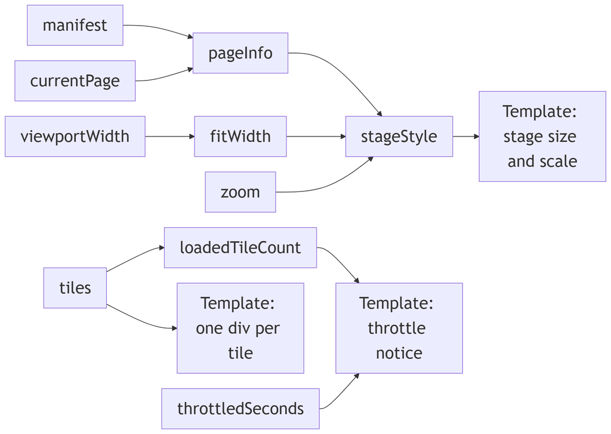

*Figure 21.2 — How signals flow through the viewer: from changed values to the parts of the screen that redraw*

*Text description:* A dependency diagram drawn left to right. Changed values on the left (manifest, current page, viewport width, zoom, tiles, and throttled seconds) feed computed values (page info, fit width, and loaded tile count). Those and the raw signals feed the parts of the template on the right: the stage size and scale, the throttle notice, and one div per tile. Notice that zoom reaches only the stage style, and tiles reach only the tile divs and the throttle notice.

Read it as a map of consequences. If the reader zooms, only `zoom` changes, so only `stageStyle` and the template part that uses it are recalculated; the tiles and the throttle notice are untouched. If a tile finishes loading, `tiles` changes, so the per-tile `div`s and the "N of M tiles loaded" count update, but the page size doesn't. The diagram is simplified: the viewer has more signals (errors, loading state, access-lost) and a second style computed (`stageWrapperStyle`) that follows the same pattern as `stageStyle`.

The same pattern protects who-is-signed-in state. `SessionService` (Chapter 22) keeps the user in a private signal and shares it read-only:

**Listing 21.7 — `session.service.ts` (book-m6-final, excerpt: three lines from the class body, not adjacent)**

```typescript
  private readonly current = signal<CurrentUser | null>(null);
  readonly user = this.current.asReadonly();
  readonly isAdmin = computed(() => this.current()?.role === 'ADMIN');
```

*Path: `frontend/src/app/core/session.service.ts`*

Other classes can read `user()` but cannot call `set` on it; only `SessionService` can change who is signed in. That is the same principle as a private field with a public getter in Java (Chapter 4).

> **Note:** Signals also drive who-is-signed-in state across the whole app. `app.html` can write `sessionService.isAdmin()` and the nav bar updates itself on sign-in and sign-out.

### 21.6 Component inputs and outputs

Angular components normally receive data through **inputs** and report events through **outputs**. This app doesn't need them: a search of `frontend/src/app` finds none. Each screen is a routed page that gets its data from services (Chapter 22) and its parameters from the URL (Chapter 23), so the components don't pass data to one another. We simplify here; Angular's documentation covers `input()` and `output()` if you build reusable widgets later.

For orientation, this is what an input would look like (a teaching example, not repository code):

**Example 21.2 — A component with an input (teaching example, not repository code)**

```typescript
export class PageBadgeComponent {
  readonly page = input.required<number>();   // the parent must supply it
}
```

A parent would write `<app-page-badge [page]="currentPage()" />`, using the same square-bracket property binding as before. Inputs are also signals, read as `page()`. The project's shape, "screens as pages, shared state in services," is a legitimate design for a small app. The price is that a screen can grow large (the viewer is about 500 lines). A larger team might split it into smaller child components with inputs.

### 21.7 Styling, light, and dark themes, and accessibility basics

Component stylesheets are scoped: rules in `app.css` affect only the `App` component. To read them you need a few CSS ideas. A **selector** picks elements (`.topbar` picks elements with `class="topbar"`; `nav a` picks links inside a `nav`). A **declaration** sets a property (`padding: 0.85rem 1.5rem;`). Sizes in `rem` are multiples of the page's base font size, so layouts scale with a reader's font setting. **Flexbox** (`display: flex`) lays children out in a row and lets you align and space them. Here is the top bar:

**Listing 21.8 — `app.css` (book-m6-final, excerpt: the top bar)**

```css
.topbar {
  display: flex;
  align-items: center;
  gap: 1.5rem;
  padding: 0.85rem 1.5rem;
  border-bottom: 1px solid var(--border);
  background: var(--surface);
}

.brand {
  font-weight: 700;
}
```

*Path: `frontend/src/app/app.css`*

`display: flex` puts the brand, the navigation, and the account area side by side; `align-items: center` centers them vertically; `gap` spaces them; `padding` and `border-bottom` frame the bar; `background: var(--surface)` uses a theme color (Listing 21.9).

Look-and-feel that every screen shares lives in one global file, `styles.css`, built on **CSS custom properties** (also called variables): named values, written `--name`, that any rule can read with `var(--name)`.

**Listing 21.9 — `styles.css` (book-m6-final, excerpt: the tokens)**

```css
:root {
  --bg: #f6f7f9;
  --surface: #ffffff;
  --fg: #16181d;
  /* Text colours meet WCAG AA (4.5:1) on both --bg and --surface. */
  --muted: #5d6470;
  --border: #e2e4e9;
  --accent: #2458d6;
  /* Text on an --accent background. */
  --on-accent: #ffffff;
  --danger: #c1272f;
}

@media (prefers-color-scheme: dark) {
  :root {
    --bg: #101114;
    --surface: #191b1f;
    --fg: #eceef1;
    --muted: #9aa0aa;
    --border: #2a2d33;
    --accent: #5b8dfd;
    --on-accent: #0b1020;
    --danger: #f0787e;
  }
}
```

*Path: `frontend/src/styles.css`*

`:root` selects the whole page, so these values are available everywhere. Components never write a color; they write `var(--surface)` or `var(--border)` (see `app.css`). The `@media (prefers-color-scheme: dark)` block applies only when the reader's operating system is set to dark mode, and redefines the same names, so one block swaps the whole theme. There is no switch in the app: it follows the system.

The naming is by *role*, not by color: `--surface` is "what cards and bars are painted on," not "white." That's why the dark block can give `--surface` a near-black value without any component changing. It is also why there is a separate `--on-accent`: "the color of text sitting on the accent color," which is white in light mode and near-black in dark mode, because the accent itself is a lighter blue in dark mode.

**Contrast** is the difference in brightness between text and its background, measured as a ratio. The Web Content Accessibility Guidelines (WCAG) level AA asks for a ratio of at least 4.5:1 for normal text, so people with low vision or a dim screen can read it. Table 21.2 lists the ratios of the project's main text pairings, computed with the WCAG formula.

Table 21.2 — Contrast ratios (computed by the author from the token values in Listing 21.9; the automated check in Chapter 24 is the project's own guard)

| Pairing | Light theme | Dark theme |
| --- | --- | --- |
| Body text `--fg` on `--bg` | 16.6 : 1 | 16.2 : 1 |
| `--muted` on `--surface` | 6.0 : 1 | 6.6 : 1 |
| `--muted` on `--bg` | 5.6 : 1 | 7.2 : 1 |
| `--on-accent` on `--accent` (buttons) | 6.1 : 1 | 6.0 : 1 |
| `--danger` on `--surface` (error text) | 5.8 : 1 | 6.3 : 1 |

Two things show why tokens matter. First, at `book-m5-platform` the `--muted` color in light mode was changed from `#6b7280` to `#5d6470`. The old value scored 4.8 : 1 on white and only 4.5 : 1 on the page background, right at the limit, and the new one has real margin. Second, the button text color changed from a hard-coded white to `var(--on-accent)`. With white text on the dark theme's lighter accent, the ratio would be only about 3.2 : 1, under the AA threshold; `--on-accent` fixes that by using dark text there. The git diff of `styles.css` between `book-m4-reading` and `book-m5-platform` shows both changes. Because colors live in one place, each fix was a small edit, and Chapter 24 shows the automated check that keeps this true in both themes.

Accessibility basics are visible in the templates. Form fields are paired with `<label for="...">`. The search box has `aria-label="Search documents"`. Error text uses `role="alert"` and status messages use `role="status"`, so screen readers announce them. Buttons are real `<button>` elements, so they work with the keyboard for free. The top-bar links use real `<a>` elements with meaningful text.

## Advanced tier: How the viewer paints a page

*On a first read you can skip to "In this project"; Part IV comes back to this.*

### 21.8 Tiles, briefly

A PDF page is cut into rectangular tiles on the server (Part II), each a small image, so no single request carries the whole page and each can carry its own watermark. The frontend's job is to put the tiles back together on screen. It asks for a *grid* of signed tile addresses (Chapter 22), downloads each tile, and places it at the right position. Chapter 25 tells the story of the first prototype; here the focus is how the Angular viewer does the placing.

### 21.9 CSS backgrounds instead of images or a canvas

The Angular viewer places each tile as an absolutely positioned `<div>` whose CSS background is the tile's picture:

**Listing 21.10 — `viewer.component.html` (book-m6-final, excerpt: the tiles)**

```html
      @for (tile of tiles(); track tile.key) {
        <div
          class="tile"
          [class.pending]="tile.status !== 'loaded'"
          [style.top.px]="tile.top"
          [style.left.px]="tile.left"
          [style.width.px]="tile.width + 1"
          [style.height.px]="tile.height + 1"
          [style.background-image]="tile.src ? 'url(' + tile.src + ')' : null"
        ></div>
      }
```

*Path: `frontend/src/app/features/viewer/viewer.component.html`*

`tile.src` is a temporary `blob:` address the viewer creates for the bytes it fetched (Chapter 22). Each `div` is one tile, positioned by `top` and `left` in page pixels. Note the bindings. `[style.top.px]="tile.top"` sets the CSS `top` property and adds the unit `px` for you. `[class.pending]="..."` turns the `pending` class on or off. `track tile.key` identifies each tile by its row and column (`"row-col"`), so when a tile's status changes from pending to loaded, Angular updates that one `div` and leaves the others alone. The milestone-zero prototype drew the page on a `<canvas>` element (`book-m0-mvp`'s static page; Chapter 25); the Angular viewer, from its first appearance at `book-m1-accounts`, uses divs. A canvas is a rectangle you draw pixels onto with code; a `div` with a background is an ordinary page element the browser lays out. The second is simpler to position, scale, and make responsive, and lets each tile appear the moment it arrives.

> **Note:** At `book-m6-final` the repository's README still says the browser reassembles the tiles on a canvas. A later documentation-only pull request (#13) corrected that sentence. At the tag, trust the code (`viewer.component.html` and `viewer.component.css`), which uses positioned `div` elements.

The stylesheet's comment states the design intent:

**Listing 21.11 — `viewer.component.css` (book-m6-final, excerpt)**

```css
/*
 * Deliberately no <img> tags: page content is painted as CSS
 * background-image on plain divs, and every layer disables selection and
 * native drag. This is the exact client-side technique discussed for
 * why flipbook readers don't offer "Save Image As" on right-click. It is
 * a UX nicety, not real protection — real protection is the short-lived
 * signed URL, per-request watermark, and rate limit behind each tile.
 */
.stage {
  position: relative;
  background: #fff;
  user-select: none;
  -webkit-user-select: none;
  -webkit-user-drag: none;
}
```

*Path: `frontend/src/app/features/viewer/viewer.component.css`*

Read it honestly: this stops a casual right-click "Save image as" and drag-out of an image, nothing more. Anyone can still open the browser's developer tools, and a screenshot needs no tools at all. The protection that matters is on the server: short-lived signed URLs, a per-viewer watermark, and a rate limit (Chapters 16 and 17). The viewer also swallows the context menu (`blockContextMenu`), and its own comment says the same thing: cosmetic only, and the design stays secure with that handler removed.

### 21.10 A rendering detail: the one-pixel overlap

A second detail from the same file shows how small rendering bugs are solved. The stage is scaled by a fractional amount for zoom (`scale(0.83)`, say), and that fractional scaling left hairline gaps between neighboring tiles, visible over dark page content. The stylesheet's own comment describes the problem; the usual cause is that each scaled edge lands between two screen pixels and is anti-aliased separately. The template makes each tile one pixel wider and taller than its slice (`tile.width + 1`, `tile.height + 1`), so neighbors overlap by a pixel and the seams disappear; the comment on `.tile` in the stylesheet explains why. The trade-off is that the last row and column of a tile are drawn twice, which is invisible because they show the same image, and the tile's stretched background (`background-size: 100% 100%`) absorbs the extra pixel.

### 21.11 Blending colors: the idle banner

One more line from `app.css` shows a modern CSS tool the theme makes possible. The idle warning banner is tinted with the accent color:

```css
.idle-banner {
  background: color-mix(in srgb, var(--accent) 15%, var(--surface));
}
```

*Excerpt: `.idle-banner` in `frontend/src/app/app.css` (book-m6-final); other declarations omitted.*

`color-mix` blends two colors: 15 percent accent, 85 percent surface. Because both come from tokens, the banner gets a suitable tint in light and dark themes without a separate dark-mode rule. The design principle: express colors in terms of tokens, and derived colors follow the theme automatically.

## Common mistakes

- **Forgetting to import what the template uses.** Using `routerLink`, a pipe, or another component's tag without listing it in the component's `imports` produces a compile error. Add it to `imports`.
- **Forgetting the parentheses on a signal.** `{{ count }}` shows the signal object, not its value; write `{{ count() }}`. In code, `this.count = 5` doesn't set a signal; call `this.count.set(5)`.
- **Changing an object inside a signal without setting it.** If a signal holds an array or object, mutating it in place (`this.tiles().push(x)`) doesn't notify anyone. Create a new one and set or update it, as the viewer does with `this.tiles.update((tiles) => tiles.map(...))`.
- **A `@for` without a good `track`.** Tracking by position makes Angular rebuild items when a list changes; track by a stable id.
- **Hard-coding colors in component CSS.** A stray `#fff` won't follow the dark theme. Use a token. (The viewer's page stage uses real `#fff` deliberately, because it stands for white paper.)
- **Forgetting to clean up.** Timers and subscriptions started in `ngOnInit` should be stopped in `ngOnDestroy`.
- **Using color alone to convey meaning.** The project pairs color with words and roles (`role="alert"`, a text label like "Failed"), so people who can't tell the colors apart still get the message.
- **Relying on the right-click block for protection.** Section 21.9 explains why it isn't protection.

## In this project

| File | First appears | What it does |
| --- | --- | --- |
| `frontend/src/app/app.ts`, `app.html`, `app.css` | `book-m1-accounts` (idle banner from `book-m4-reading`) | Root component: top bar, idle banner, router outlet |
| `frontend/src/styles.css` | `book-m1-accounts` (contrast tokens at `book-m5-platform`) | Global theme tokens, dark mode, buttons |
| `frontend/src/app/features/documents/document-list.component.*` | `book-m2-documents` | Signals, `computed` filter, `@for` |
| `frontend/src/app/features/viewer/viewer.component.*` | `book-m1-accounts` | Tiles as divs with CSS backgrounds |

View one with `git show book-m6-final:frontend/src/styles.css`.

## Try it

### Exercise 21.1 ★ The Admin link

In `app.html`, which condition decides whether the Admin link appears? Which class property does it read?

*Solution:* Appendix C, Exercise 21.1.

### Exercise 21.2 ★ Changing the accent

Change the accent color in a scratch copy of `styles.css` and reload `ng serve`. Which screens change?

*Solution:* Appendix C, Exercise 21.2.

### Exercise 21.3 ★★ A toggled hint

Add a signal `showHint` to a scratch component with a button that toggles it (`update((v) => !v)`) and an `@if` that shows a paragraph.

*Solution:* Appendix C, Exercise 21.3.

### Exercise 21.4 ★★ Check the contrast

Use a contrast checker to compute the ratio of `--muted` on `--surface` in both themes. Compare your numbers with Table 21.2.

*Solution:* Appendix C, Exercise 21.4.

### Exercise 21.5 ★★★ Why track by id

Explain why `track doc.documentId` is better than tracking by position when the list is filtered.

*Solution:* Appendix C, Exercise 21.5.

### Exercise 21.6 ★★ Extend the counter

Extend Example 21.1 so that the button label shows "Clicked once" for a count of one and "Clicked N times" otherwise, using a `computed` signal for the label. Then add a reset button.

*Solution:* Appendix C, Exercise 21.6.

## Summary

- A component is a class, a template, and a stylesheet, shown through its selector, and it has a life: the constructor, `ngOnInit`, and `ngOnDestroy` for cleanup.
- Templates show values with `{{ }}`, decide with `@if`, repeat with `@for`, and respond with `(event)` bindings; `[property]` bindings set values from the class.
- Signals hold values, `computed` derives new ones, and Angular redraws only what read a changed signal; `asReadonly` lets a service share state without sharing the power to change it.
- The app has no component inputs or outputs; screens get data from services and the URL.
- Theme colors are CSS custom properties named by role, redefined under `prefers-color-scheme: dark`; contrast fixes are made in the tokens.
- Tiles are positioned divs with CSS backgrounds, a convenience layer, not protection; a one-pixel overlap hides seams from fractional scaling.

Next, Chapter 22 connects these screens to the backend.

## Further reading

- Angular documentation, "Components", "Templates" and "Signals": https://angular.dev/
- MDN Web Docs, "Using CSS custom properties" and "prefers-color-scheme": https://developer.mozilla.org/
- W3C, "Web Content Accessibility Guidelines (WCAG) 2.1": https://www.w3.org/TR/WCAG21/

# Chapter 22: Talking to the backend

A screen with no data is a mockup. In this chapter you follow a request from a button click in the browser, through Angular's `HttpClient`, across the same-origin proxy, to Spring Boot and back. You also see how the frontend copes when the backend says no: expired sessions, rate limits, and documents replaced while someone is reading them.

## Learning objectives

By the end of this chapter, you will be able to:

- Explain what a service is and how Angular's dependency injection provides one to a component.
- Write a typed `HttpClient` call for a GET, a POST, and a file upload, and read the ones in `documents.service.ts`.
- Explain how the Cross-Site Request Forgery (CSRF) cookie becomes a request header, and where the session cookie is handled.
- Read `session.interceptor.ts` and say what happens on a 401.
- Explain how the viewer reacts to 429, 401, 404, and 410 responses when fetching tiles.
- Explain the idle warning and why background polling must not keep a session alive.
- Read an RxJS pipeline that uses `debounceTime`, `switchMap` and `catchError`, and say why each operator is placed where it is.
- Explain what the Content-Security-Policy header allows and how it constrains the frontend.

## Prerequisites

- Chapter 8: HTTP requests, status codes, cookies.
- Chapter 12: the REST (representational state transfer) endpoints this chapter calls.
- Chapter 16: CSRF protection and rate limiting on the server.
- Chapters 19–21: TypeScript, Observables, components, and signals.

## Beginner tier: A service is a shared helper

### 22.1 Services and dependency injection in Angular

Several screens need the same things: to know who is signed in, to fetch documents. Copying that code into each component would be wasteful and error-prone. Instead the code goes into a service: a plain class, marked `@Injectable`, that Angular creates once and hands to whoever asks. Think of a shared office printer: nobody buys their own, and everyone who needs one is pointed to the same machine.

**Where the analogy breaks down:** a printer sits in the office whether or not anyone prints. Angular creates a service only when something first asks for it.

Asking is called dependency injection, the same idea as Spring's (Chapter 11): a class declares what it needs, and the framework supplies it. Here, in the constructor:

**Listing 22.1 — `documents.service.ts` (book-m6-final, excerpt)**

```typescript
@Injectable({ providedIn: 'root' })
export class DocumentsService {
  private readonly base = `${API_BASE_URL}/api/documents`;

  constructor(private readonly http: HttpClient) {}

  list(): Observable<DocumentSummary[]> {
    return this.http.get<DocumentSummary[]>(this.base);
  }

  get(documentId: string): Observable<DocumentDetail> {
    return this.http.get<DocumentDetail>(`${this.base}/${encodeURIComponent(documentId)}`);
  }
```

*Path: `frontend/src/app/features/documents/documents.service.ts`*

- `providedIn: 'root'` means one shared instance for the whole app.
- `constructor(private readonly http: HttpClient) {}` asks Angular for an `HttpClient`. The words `private readonly` in front of the parameter are TypeScript shorthand that also create a field named `http`. This is constructor injection, as in Chapter 11.
- `list()` returns `Observable<DocumentSummary[]>` (Chapter 19): a stand-in for a list of summaries that will arrive later. Nothing is sent until someone calls `.subscribe(...)`.
- `encodeURIComponent(documentId)` makes the id safe to put in a URL path, so a strange character can't change which endpoint is called.

The `API_BASE_URL` constant (`core/config.ts`) is the empty string, so the resulting address is the relative URL `/api/documents`. Section 22.12 explains why that matters.

A component then calls the service and shows the outcome:

**Listing 22.2 — `document-list.component.ts` (book-m6-final, excerpt: method `refresh`)**

```typescript
  refresh(): void {
    this.loading.set(true);
    this.documentsService.list().subscribe({
      next: (docs) => {
        this.documents.set(docs);
        this.loading.set(false);
      },
      error: () => {
        this.errorMessage.set('Could not load documents.');
        this.loading.set(false);
      },
    });
  }
```

*Path: `frontend/src/app/features/documents/document-list.component.ts`*

The `subscribe` call takes an object with two functions: `next` runs when data arrives, `error` when the request fails. Each updates signals (Chapter 21), and the template's `@if (loading()) ... @else if (errorMessage()) ... @else if (documents().length === 0) ...` chain in `document-list.component.html` shows one of four states: loading, error, empty, or the list. Deciding all four up front, rather than only the happy path, is what makes a screen feel finished.

### 22.2 `HttpClient`: GET, POST, uploads

`HttpClient` is Angular's built-in tool for HTTP. Each method matches an HTTP verb: `get`, `post`, `put`, `patch`, `delete`. The type in angle brackets is the shape you expect back (with the caveat from Chapter 19, Section 19.9: it is a promise, not a check). Sending data means passing a body, which `HttpClient` turns into JSON:

**Listing 22.3 — `session.service.ts` (book-m6-final, excerpt: method `login`)**

```typescript
  login(username: string, password: string): Observable<CurrentUser> {
    return this.http
      .post<CurrentUser>(`${API_BASE_URL}/api/auth/login`, { username, password })
      .pipe(tap((user) => this.current.set(user)));
  }
```

*Path: `frontend/src/app/core/session.service.ts`*

`.pipe(...)` adds steps that run on the result. `tap` performs a side effect without changing the value: here it stores the signed-in user in a signal, so the whole app (the nav bar, the guards) sees the new state at once. Note what is missing: no token is stored, and no `Authorization` header is set. The backend's session cookie is `HttpOnly`, meaning JavaScript can't read it; the browser attaches it automatically (Chapter 15).

Uploads use the browser's `FormData` and ask for progress events:

**Listing 22.4 — `documents.service.ts` (book-m6-final, excerpt: method `upload`)**

```typescript
  upload(title: string, file: File, visibility: Visibility): Observable<HttpEvent<DocumentDetail>> {
    const formData = new FormData();
    formData.append('title', title);
    formData.append('visibility', visibility);
    formData.append('file', file);
    return this.http.post<DocumentDetail>(this.base, formData, { reportProgress: true, observe: 'events' });
  }
```

*Path: `frontend/src/app/features/documents/documents.service.ts`*

`observe: 'events'` makes the Observable emit a series of events (progress reports, then the final response) instead of only the final body. `upload.component.ts` reads `HttpEventType.UploadProgress` to fill a progress bar, and treats "all bytes sent" as the point where the server starts rendering pages.

### 22.3 Observables in five minutes

Every `HttpClient` method returns an **Observable** (Chapter 19), and this chapter reads better with a few habits in mind.

*Pattern note: Observables are the observer pattern in stream form (Chapter 38, Section 38.7).*

- **Nothing happens until you subscribe.** `this.http.get(...)` only *describes* a request. The request is sent when someone calls `.subscribe(...)`. Two subscriptions send two requests.
- **An HTTP Observable delivers one result and ends.** Unlike a stream of key presses, a request produces a single response (or an error) and completes, so a component doesn't have to unsubscribe from it to avoid leaks. Long-lived Observables, such as a timer, are different; those need cleanup (Chapter 21).
- **`.pipe(...)` adds steps.** The steps are small functions called operators. The project uses a handful. `map` changes each value. `tap` does something on the side, such as storing a result, without changing it. `catchError` turns a failure into something else. `switchMap` starts a new Observable for each incoming value and cancels the previous one. `debounceTime` waits until values stop arriving.
- **`subscribe({ next, error })` is where the component reacts.** `next` runs for each value, `error` for a failure.

A useful mental picture is a pipeline of pipes: the request flows in at one end, each operator does its small job, and the component's `next` function is the tap at the other end.

### 22.4 Worked example: what happens when the document list loads

Follow one request from the code you have seen to the pixels, so that every piece has a place.

1. The reader visits `/documents`. The router (Chapter 23) creates `DocumentListComponent`, whose `ngOnInit` calls `refresh()` (Listing 22.2).
2. `refresh()` sets `loading` to true, so the template shows "Loading…", then calls `this.documentsService.list()`.
3. `list()` calls `this.http.get<DocumentSummary[]>('/api/documents')`. That returns an Observable; nothing has been sent yet.
4. `.subscribe(...)` in `refresh()` starts the request. `HttpClient` builds a `GET` request. Because it is a read, it doesn't need the CSRF header. It passes through the interceptor (Section 22.5), which adds nothing on the way out.
5. The browser sends the request to its own origin, with the session cookie attached automatically. In development the dev server forwards it to Spring Boot (Chapter 20); in production nginx does (Section 22.12).
6. Spring Boot checks the session, finds the documents this reader may see, and answers with JSON (Part II).
7. The response passes back through the interceptor's `tap` step, which records the activity for the idle timer (Section 22.8).
8. The Observable emits the parsed list to `next`; the component stores it with `this.documents.set(docs)` and sets `loading` to false.
9. The template reads those signals (Chapter 21), so Angular redraws: "Loading…" goes away, and the `@for` draws one card per document.

If step 6 answers with an error instead, the `error` callback runs, the component sets `errorMessage`, and the template shows the error state. If it answers with a 401, the interceptor also signs the reader out and redirects to sign-in, and only then does the component's `error` callback run.

## Intermediate tier: Cookies, CSRF, and an interceptor

*On a first read you can skip to "In this project"; Part IV comes back to this.*

### 22.5 Interceptors: CSRF header and 401 handling

Cross-Site Request Forgery (CSRF, Chapter 16) is an attack in which another website tricks your browser into sending a request to the app, and the browser helpfully attaches your session cookie. The server's defense is to require a secret that only pages from the app itself can supply. The pattern used here: the server sets a cookie named `XSRF-TOKEN` that JavaScript is allowed to read, and the frontend copies its value into a header, `X-XSRF-TOKEN`, on every state-changing request. A foreign site can't read the app's cookie, so it can't set the header.

*Pattern note: An interceptor is a chain of responsibility with one link (Chapter 38, Section 38.3).*

Angular's `HttpClient` does this copying by default for same-origin requests. `app.config.ts` says so in a comment:

**Listing 22.5 — `app.config.ts` (book-m6-final)**

```typescript
export const appConfig: ApplicationConfig = {
  providers: [
    provideBrowserGlobalErrorListeners(),
    provideRouter(routes),
    // HttpClient's built-in XSRF support is on by default: it copies the
    // XSRF-TOKEN cookie into the X-XSRF-TOKEN header on same-origin writes,
    // which is exactly what the backend's CSRF protection expects.
    provideHttpClient(withInterceptors([sessionInterceptor])),
    // Resolve "who am I" before the first route guard runs.
    provideAppInitializer(() => inject(SessionService).restore()),
  ],
};
```

*Path: `frontend/src/app/app.config.ts`*

There is no CSRF code to write in the app, which is the point: the project relies on the framework's default. The last provider runs `SessionService.restore()` before the first page is shown. It calls `/api/auth/me` to ask the server who is signed in (so a reload keeps you signed in), and its comment in `session.service.ts` notes that this call also primes the CSRF cookie.

Figure 22.1 shows the conversation for a state-changing request, such as signing out.

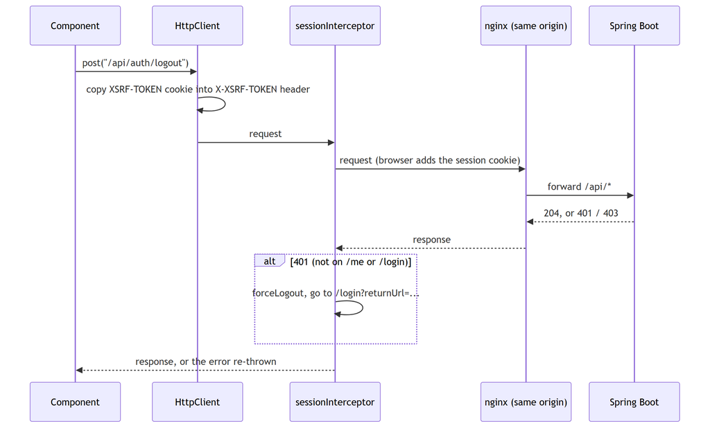

*Figure 22.1 — A write request from the browser to the API*

*Text description:* A sequence diagram with five participants: the component, HttpClient, the session interceptor, nginx, and Spring Boot. The component posts a request, HttpClient copies the anti-forgery cookie into a request header, and the request passes through the interceptor and nginx to Spring Boot. The response comes back the same way. If the status is 401 on any address except the sign-in and who-am-I endpoints, the interceptor signs the reader out locally and redirects to the sign-in page. Otherwise the response, or the error, goes back to the component.

An **interceptor** is a function that sees every request and response that passes through `HttpClient`. `sessionInterceptor` handles the case where the session has ended:

**Listing 22.6 — `session.interceptor.ts` (book-m6-final, excerpt: the `catchError` step)**

```typescript
    catchError((error: unknown) => {
      const isAuthProbe = AUTH_PROBES.some((path) => req.url.endsWith(path));
      if (error instanceof HttpErrorResponse && error.status === 403 && error.error?.passwordChangeRequired) {
        router.navigate(['/account'], { queryParams: { required: 1 } });
      }
      if (!isAuthProbe && error instanceof HttpErrorResponse && error.status === 401) {
        sessionService.forceLogout();
        // Same returnUrl contract as authGuard, so signing back in lands
        // where the user was rather than on the documents list.
        const returnUrl = router.url.startsWith('/login') ? undefined : router.url;
        router.navigate(['/login'], { queryParams: returnUrl ? { returnUrl } : {} });
      }
      return throwError(() => error);
    }),
```

*Path: `frontend/src/app/core/session.interceptor.ts`*

- A **401** means "not authenticated." Whatever request received it, the session is gone (timed out, ended elsewhere, or revoked by an administrator), so the interceptor clears local state and sends the reader to the sign-in page, remembering where they were in `returnUrl`.
- The exception is `/api/auth/me` and `/api/auth/login` (the `AUTH_PROBES`): a 401 there means "not signed in" or "wrong password," and redirecting would loop.
- A **403** with `passwordChangeRequired` sends a user whose password was set by an administrator to the account page (Chapter 23).
- `throwError(() => error)` passes the failure on, so the calling component's own `error:` handler still runs.

The interceptor also has a `tap` step, added at `book-m4-reading`, that calls `sessionService.touch()` on every successful response to record activity for the idle warning (Section 22.8).

### 22.6 Loading, error, and empty states

Every screen that loads data has four states, and the project treats each as a design decision, not an afterthought. *Loading* shows "Loading…". *Error* is a sentence saying what failed, in `role="alert"` so screen readers announce it. *Empty* says "No documents yet," with different advice for people who can upload. *Content* is the list itself. Error messages from the server are shown when they exist (`err.error?.error`), falling back to a generic sentence; the backend's error contract (Chapter 13) guarantees they carry no internals.

### 22.7 Handling 429 with `Retry-After`, and 410 Gone

Tiles are not fetched with `HttpClient`. The reason is in a comment in `viewer.component.ts`: only the browser's `fetch()` exposes each response's status, and a throttled or expired tile is otherwise indistinguishable from a blank one, so the page would silently render with holes. Each tile URL is a signed, short-lived address (Chapter 25). The viewer runs six fetches at a time (`MAX_CONCURRENT_TILE_FETCHES`), because a page change would otherwise leave dozens of now-irrelevant requests in flight, each still spending the reader's rate-limit budget.

**Listing 22.7 — `viewer.component.ts` (book-m6-final, excerpt: how one tile response is handled)**

```typescript
        if (response.ok) {
          this.sessionService.touch();
          const blob = await response.blob();
          if (generation !== this.loadGeneration) {
            return;
          }
          this.updateTile(tile.key, { status: 'loaded', src: URL.createObjectURL(blob) });
        } else if (response.status === 429 || response.status === 503) {
          // Over this reader's limit, or the server is briefly busy: wait and resume.
          outcome.retryAfterSeconds = parseRetryAfter(response.headers.get('Retry-After'));
        } else if (response.status === 401) {
          outcome.unauthorized = true;
        } else if (response.status === 404) {
          // Unshared or deleted while open: access is re-checked on every tile.
          outcome.accessRevoked = true;
        } else if (response.status === 410) {
          // The PDF was replaced while open: these URLs point at the old render.
          outcome.replaced = true;
        } else {
          this.updateTile(tile.key, { status: 'failed' });
        }
```

*Path: `frontend/src/app/features/viewer/viewer.component.ts`*

Each status has its own meaning and its own recovery:

- **200:** the response body is a PNG. `URL.createObjectURL(blob)` makes a temporary `blob:` address the tile's CSS background can use (Chapter 21).
- **429 or 503:** too many requests, or the server is briefly busy. The `Retry-After` header says how many seconds to wait. The viewer stops issuing further requests (they would be rejected too), shows "Viewing speed limit reached: N of M tiles loaded. The rest of this page will load in Ns" and counts down each second. When the countdown ends it asks for a *fresh* grid of signed URLs, because waiting can outlast the old URLs' lifetime. If `Retry-After` is missing or unusable, it waits 5 seconds (`FALLBACK_RETRY_AFTER_SECONDS`).
- **401:** a tile URL expired before the worker reached it, or the session is gone. The viewer re-issues the grid once (`allowUrlReissue`); if the session really is gone, that request fails with 401 and the interceptor signs the user out.
- **404:** the document was unshared or deleted while open (access is re-checked on every tile), so the viewer shows a "no longer available to you" state.
- **410 Gone:** the owner replaced the PDF; these URLs point at the old rendering. The viewer reloads the document description and shows a notice, "This document was updated while you were reading." It passes the stale version number so that if the reload finds the same version, it stops with an error instead of looping forever (a case the spec `viewer.component.spec.ts` covers).

### 22.8 Session state and idle warnings

The server ends a session after a period without requests. Readers reading quietly would be surprised by that, so the app warns them. `core/idle.ts` (Chapter 19) is pure arithmetic: from the current time, the time of the last request, and the server's timeout (delivered as `sessionTimeoutSeconds` in the sign-in response), it returns `active`, `warning` with the seconds left, or `expired`. The warning window is the last five minutes, or half the timeout if that is shorter (`idle.spec.ts` has the cases). `App` checks once a second and shows the banner from Listing 21.3; "Stay signed in" calls `/api/auth/me`, and any request extends the server's session.

Two details keep this honest. First, the last-activity time is written to `localStorage` under `sdv.lastActivity` and read back when another tab writes it, so activity in one tab stops another tab from warning wrongly; if storage is unavailable, each tab tracks its own activity. Second, every successful API call (including tile fetches, via `touch()`) counts as activity, matching what the server does.

### 22.9 Asking "who am I?" at startup, and sharing activity between tabs

Two methods in `session.service.ts` carry most of the session logic. The first runs once, at startup:

**Listing 22.8 — `session.service.ts` (book-m6-final, excerpt: method `restore`)**

```typescript
  restore(): Promise<void> {
    return firstValueFrom(
      this.http.get<CurrentUser>(`${API_BASE_URL}/api/auth/me`).pipe(
        tap((user) => this.current.set(user)),
        map(() => undefined),
        catchError(() => {
          this.current.set(null);
          return of(undefined);
        }),
      ),
    );
  }
```

*Path: `frontend/src/app/core/session.service.ts`*

Read the pipeline from the inside out. `http.get` asks the server who the cookie belongs to. `tap` stores the answer in the signal. `map(() => undefined)` discards the user, because the caller only needs to know the check has finished. `catchError` handles the failure case. If the server says "nobody" (a 401 for a signed-out visitor), the service records "nobody signed in" and continues with a normal completion. A signed-out visitor therefore sees the sign-in page and not a startup crash. `firstValueFrom` turns the whole thing into a Promise, because Angular's `provideAppInitializer` (Listing 22.5) waits for a promise before it lets the first route run. Note also that `/api/auth/me` is one of the two "auth probe" addresses the interceptor ignores (Listing 22.6): its 401 is an expected answer, not an ended session.

The second piece is the idle bookkeeping:

**Listing 22.9 — `session.service.ts` (book-m6-final, excerpt: the storage listener and `touch`)**

```typescript
  constructor(private readonly http: HttpClient) {
    window.addEventListener('storage', (event) => {
      if (event.key === LAST_ACTIVITY_KEY && event.newValue) {
        this.activity.set(Math.max(this.activity(), Number(event.newValue)));
      }
    });
  }

  /** Called after every successful API request; the server has just extended the session. */
  touch(): void {
    const now = Date.now();
    this.activity.set(now);
    try {
      localStorage.setItem(LAST_ACTIVITY_KEY, String(now));
    } catch {
      // Other tabs just won't hear about it; this tab still tracks its own activity.
    }
  }
```

*Path: `frontend/src/app/core/session.service.ts`*

`touch()` records "the server was reached a moment ago" in two places: the signal (for this tab) and `localStorage` (for other tabs). Browsers fire a `storage` event in *other* tabs of the same site when one writes to `localStorage`, and the constructor's listener uses it to update that tab's signal, keeping the later of the two times (`Math.max`). The result: if you read in one tab while another sits idle, the idle tab won't pop up a "you'll be signed out" banner that would be wrong. The stored value is only a timestamp, and the code comment says it is not sensitive. Failing to write (private mode, blocked storage) is caught and tolerated.

### 22.10 Search as you type: debouncing and `switchMap`

When an owner shares a document, the manage screen suggests usernames as they type. Sending a request on every keystroke would waste effort and, worse, answers could arrive out of order. The component solves both with an Observable pipeline:

*Pattern note: Debouncing with `switchMap` is the observer idea in practice (Chapter 38, Section 38.7).*

**Listing 22.10 — `manage.component.ts` (book-m6-final, excerpt: the suggestion pipeline)**

```typescript
    this.userQuerySub = this.userQuery
      .pipe(
        debounceTime(200),
        distinctUntilChanged(),
        // The server returns nothing under two characters; don't even ask.
        switchMap((q) => (q.trim().length >= 2 ? this.documentsService.findUsers(q).pipe(catchError(() => of([]))) : of([]))),
      )
      .subscribe((names) => {
        const shared = new Set(this.document()?.sharedWith ?? []);
        this.suggestions.set(names.filter((n) => n !== this.document()?.owner && !shared.has(n)));
      });
```

*Path: `frontend/src/app/features/documents/manage.component.ts`*

`userQuery` is a `Subject`, an Observable you can push values into by hand; the input's handler calls `this.userQuery.next(value)` on each keystroke (`onShareInput`). The operators then do four jobs:

- `debounceTime(200)` waits until 200 milliseconds pass without a new value, so fast typing produces one search, not one per letter.
- `distinctUntilChanged()` ignores a value identical to the previous one.
- `switchMap(...)` starts a request for the latest value and **cancels** the previous one if it's still running, so a slow answer for "al" can never overwrite a fast answer for "alice." Short queries skip the request entirely, mirroring the server's rule, by returning `of([])`, an Observable that immediately emits an empty list.
- `catchError(() => of([]))` sits *inside* the `switchMap`, on the request only. That placement matters: an error caught on the outer pipeline would end the whole stream and suggestions would stop working forever after one failure. Caught on the inner request, one failed search yields an empty list and the stream lives on. The same care appears in the admin dashboard's polling, whose comment says "One failed refresh must not end the polling for good."

The final `subscribe` filters the suggestions to hide the owner and anyone the document is already shared with, using a `Set` for fast lookups. The service method underneath builds the query safely: `this.http.get<string[]>(`${API_BASE_URL}/api/users`, { params: new HttpParams().set('q', prefix) })`. `HttpParams` encodes the value, so a prefix containing `&` or `#` can't alter the address.

### 22.11 Why cookies and not tokens in web storage

The obvious alternative to what this chapter shows is the pattern many tutorials teach: after sign-in the server returns a token, the frontend saves it in `localStorage`, and an interceptor adds an `Authorization` header to every request. It has real advantages: it works across different origins with no cookie rules, and it suits mobile apps and APIs used by other programs. The project chose otherwise, and the comment on `SessionService` states why: "The credential itself is an httpOnly cookie the browser manages — nothing secret is held here or in web storage." An `HttpOnly` cookie can't be read by JavaScript, so a script injected through some bug in the page (a cross-site scripting attack) can't steal it. A token in `localStorage` can be read by any script on the page. The trade-off is that cookies are sent automatically, which is what makes CSRF possible and why the CSRF header (Section 22.5) is needed, and why the app must live on one origin. Neither approach is free; the project accepted the second set of costs in exchange for the first set of protections, and its content security policy (Section 22.12) adds a further barrier against injected scripts.

## Advanced tier: One origin, and quiet polling

*On a first read you can skip to "In this project"; Part IV comes back to this.*

### 22.12 Why one origin: nginx and the proxy

Chapter 20 showed the development proxy. In production, `frontend/nginx.conf` does the same job with more care. The comment at its top says the design goal: "Serves the Angular app and proxies the API, so browser, session cookie and CSRF cookie all share one origin." With one origin there is no cross-origin resource sharing (CORS) setup to get wrong, no cookie policies to loosen, and the relative URLs in the frontend work unchanged.

*Pattern note: One origin behind a proxy is the client-server single-page-app pattern (Chapter 39, Section 39.4).*

**Listing 22.11 — `nginx.conf` (book-m6-final, excerpt: the API location)**

```
    # ^~ so no regex location (e.g. the static-asset rule below) can capture an API path.
    location ^~ /api/ {
        proxy_pass http://app:8080;
        proxy_set_header Host $host;
        # OVERWRITE (never append to) X-Forwarded-For with the address of the TCP
        # peer. The backend trusts this header (server.forward-headers-strategy),
        # so passing through a client-supplied value would let anyone choose the
        # IP that login throttling and the audit log see.
        proxy_set_header X-Forwarded-For $remote_addr;
```

*Path: `frontend/nginx.conf`*

The comment records a real security fix (fix commit `65f2530`, pull request 1). During a live test through nginx, one of the project's AI review agents found that the proxy appended to a client-supplied `X-Forwarded-For` header and the backend trusted it, so changing the header on each attempt reset the sign-in throttle. The fix made nginx overwrite the header with the real peer address. An end-to-end test in `e2e/secure-viewing.spec.ts` now sends six wrong passwords with different spoofed addresses and expects the sixth to be refused with 429 (Chapter 24). The same file sets a Content Security Policy for the app's pages that allows images only from `'self'`, `blob:` and `data:`; the `blob:` allowance is exactly what the viewer's tiles need.

### 22.13 Polling that must not keep a session alive

The admin dashboard refreshes its session list every five seconds. But a request counts as activity, so a forgotten admin tab would keep the most privileged session alive forever. The code therefore polls only while the page is visible and someone touched it in the last two minutes:

**Listing 22.12 — `admin-dashboard.component.ts` (book-m6-final, excerpt)**

```typescript
export const POLL_IDLE_MS = 2 * 60_000;

export function shouldPoll(now: number, lastInputAt: number, hidden: boolean): boolean {
  return !hidden && now - lastInputAt < POLL_IDLE_MS;
}
```

*Path: `frontend/src/app/features/admin/admin-dashboard.component.ts`*

The doc comment on `shouldPoll` says why: "An unattended admin page must not keep polling: every poll would count as activity and keep the most privileged session alive past its idle timeout." The function is pure and tested in `admin-dashboard.component.spec.ts`.

### 22.14 The throttle countdown, mechanically

Section 22.7 described what the viewer shows when it is throttled. Here is how the countdown is built, because it combines two timers, a signal, and a guard against stale work:

**Listing 22.13 — `viewer.component.ts` (book-m6-final, excerpt: `startThrottleCountdown` and `parseRetryAfter`)**

```typescript
  private startThrottleCountdown(page: number, generation: number, seconds: number): void {
    this.clearThrottle();
    this.throttledSeconds.set(seconds);
    this.countdownTimer = setInterval(
      () => this.throttledSeconds.update((s) => (s === null ? null : Math.max(0, s - 1))),
      1000,
    );
    this.retryTimer = setTimeout(() => {
      this.clearThrottle();
      if (generation === this.loadGeneration) {
        // Fresh URLs, not the old ones: waiting out the window can take
        // long enough for the original tokens to have expired.
        this.requestGrid(page, generation, true);
      }
    }, seconds * 1000);
  }

function parseRetryAfter(header: string | null): number {
  const seconds = Number(header);
  return Number.isFinite(seconds) && seconds > 0 ? Math.ceil(seconds) : FALLBACK_RETRY_AFTER_SECONDS;
}
```

*Path: `frontend/src/app/features/viewer/viewer.component.ts`*

(Excerpt: the two pieces are not adjacent in the file; `parseRetryAfter` is a plain function after the class.) Step by step:

1. `parseRetryAfter` turns the `Retry-After` header into whole seconds. `Number(null)` is 0 and `Number('abc')` is `NaN`, so the check `Number.isFinite(seconds) && seconds > 0` rejects a missing, garbled, or zero header, and falls back to 5 seconds. `Math.ceil` rounds a fractional wait up, never down, so the retry isn't sent a moment too early.
2. `startThrottleCountdown` first clears any earlier countdown (`clearThrottle`), so two can't overlap, then puts the number of seconds in the `throttledSeconds` signal, which the template shows ("will load in 12s").
3. `setInterval` ticks once a second and lowers the signal, never lower than zero. This timer is purely cosmetic; it doesn't decide when to retry.
4. `setTimeout` fires once, after the whole wait, and *is* the retry. It asks for a fresh grid of signed URLs (`requestGrid`), not for the old URLs to be tried again, because the tokens in them may have expired while the reader waited (Chapter 25).
5. The `generation === this.loadGeneration` check drops the retry if the reader has turned to another page in the meantime (Chapter 19, Section 19.12).

Splitting the display timer from the action timer is a small robustness choice: if the display drifted or a tab's timers were slowed by the browser, the retry would still happen at the right moment.

### 22.15 The Content Security Policy

nginx sends one more protection for the app's own pages, in the `location /` block:

**Listing 22.14 — `nginx.conf` (book-m6-final, excerpt: the Content-Security-Policy header)**

```
        add_header Content-Security-Policy "default-src 'self'; script-src 'self'; style-src 'self' 'unsafe-inline'; img-src 'self' blob: data:; connect-src 'self'; font-src 'self'; object-src 'none'; base-uri 'self'; form-action 'self'; frame-ancestors 'none'" always;
```

*Path: `frontend/nginx.conf`*

A Content Security Policy (CSP) is a header that tells the browser which sources of content the page may use. Anything else is blocked, which limits what an injected script could do. Read the directives as a list of rules:

- `default-src 'self'` allows resources only from the app's own origin unless a later directive says otherwise.
- `script-src 'self'` allows scripts only from this origin (no inline scripts, and no scripts from other sites).
- `style-src 'self' 'unsafe-inline'` allows own-origin styles plus inline ones. The file doesn't say why the looser rule is needed; it is the one place the policy allows something inline.
- `img-src 'self' blob: data:` allows images from the origin, from `blob:` addresses (the viewer's tiles) and from `data:` addresses.
- `connect-src 'self'` restricts where `fetch` and `HttpClient` may talk to, so injected code couldn't send data to another server.
- `object-src 'none'` forbids plug-ins, and `base-uri 'self'` blocks changing the base address.
- `form-action 'self'` stops forms posting elsewhere.
- `frame-ancestors 'none'` forbids embedding the app in another site's frame. `always` makes nginx send the header even on error responses.

The CSP explains a constraint on the frontend code: tiles must come from `blob:` URLs and not from another origin, and scripts can't be inline. It is also why the viewer's approach (fetch the bytes, then make a `blob:` address) fits the policy so naturally.

## Common mistakes

- **Forgetting to subscribe.** A service method that returns an Observable does nothing on its own. If a save button "does nothing," check that something subscribes.
- **Subscribing twice by accident.** Two subscriptions send two requests. If one Observable feeds two places, share the result in a signal instead.
- **Putting `catchError` in the wrong place.** Caught on an outer, long-lived pipeline, an error ends the stream (Section 22.10). Catch it on the inner request.
- **Building URLs by string concatenation.** Use `encodeURIComponent` for path parts and `HttpParams` for query values, as the project does, so user input can't change the address.
- **Storing secrets in `localStorage`.** The project stores a timestamp and a page number only, and says so in comments.
- **Treating a 401 as an ordinary error.** The interceptor handles it centrally; a component shouldn't also redirect, or the reader is bounced twice.
- **Forgetting the CSRF header in a raw client.** Angular adds it for you; `curl` and Playwright's raw API client don't (Chapter 24).
- **Retrying with old signed URLs.** After a wait, ask for fresh ones, as the viewer does.
- **Polling without a stop rule.** Background requests count as activity and keep sessions alive; see Section 22.13.
- **Assuming the `<Type>` on `get<Type>` checks anything.** It is a promise to the compiler only (Chapter 19, Section 19.9).

## In this project

| File | First appears | What it does |
| --- | --- | --- |
| `frontend/src/app/core/session.service.ts` | `book-m1-accounts` | Who is signed in, as signals; login, logout, restore |
| `frontend/src/app/core/session.interceptor.ts` | `book-m1-accounts` (activity and 403 handling later) | 401 handling |
| `frontend/src/app/app.config.ts` | `book-m1-accounts` | Providers: router, HttpClient, startup restore |
| `frontend/src/app/features/documents/documents.service.ts` | `book-m1-accounts` (grew in m2) | Document API calls |
| `frontend/src/app/features/viewer/viewer.component.ts` | `book-m1-accounts` | Tile fetch pool, throttle countdown (429) and 401 handling from m1; tile 404 handling by m4; 410 Gone and replaced-document reload from m5 |
| `frontend/src/app/core/idle.ts` | `book-m4-reading` | Idle-timeout arithmetic |
| `frontend/nginx.conf` | `book-m5-platform` | Production same-origin proxy and headers |

See one with `git show book-m6-final:frontend/src/app/core/session.interceptor.ts`.

## Try it

### Exercise 22.1 ★ The HTTP methods

Which HTTP methods does `DocumentsService` use, and which one sends a file?

*Solution:* Appendix C, Exercise 22.1.

### Exercise 22.2 ★ The interceptor and a 401

What does the interceptor do with a 401 from `/api/auth/login`? Why?

*Solution:* Appendix C, Exercise 22.2.

### Exercise 22.3 ★★ Find the CSRF header

Open the browser's developer tools, Network tab, sign in, then make any `POST`. Find the `X-XSRF-TOKEN` request header and the `XSRF-TOKEN` cookie. Do the values match?

*Solution:* Appendix C, Exercise 22.3.

### Exercise 22.4 ★★ The fallback retry time

In a scratch copy, change `FALLBACK_RETRY_AFTER_SECONDS`. Which situation does it affect?

*Solution:* Appendix C, Exercise 22.4.

### Exercise 22.5 ★★★ A reload without the version check

Explain what could go wrong if the viewer, after a 410, reloaded the document without the `staleVersion` check.

*Solution:* Appendix C, Exercise 22.5.

### Exercise 22.6 ★★ Why `switchMap`

In Listing 22.10, suppose `switchMap` were replaced by `mergeMap`, which does not cancel earlier requests. Describe a sequence of typing and slow responses in which the wrong suggestions would end up on screen.

*Solution:* Appendix C, Exercise 22.6.

Next, Chapter 23 covers the pages themselves: routing, guards, and forms.

## Further reading

- Angular documentation, "HttpClient", "Interceptors" and "Dependency injection": https://angular.dev/
- MDN Web Docs, "Fetch API" and "Retry-After": https://developer.mozilla.org/
- OWASP Cheat Sheet Series, "Cross-Site Request Forgery Prevention": https://cheatsheetseries.owasp.org/

# Chapter 23: Routing, guards, and forms

A single-page application has one HTML page, but readers expect many: a sign-in page, a document list, a viewer you can bookmark. This chapter shows how Angular's router creates that illusion, how guards keep readers out of screens they can't use, how the forms collect input, and how the viewer supports deep links, keyboard navigation, and swiping. Along the way it keeps returning to one theme that runs through the whole project: the browser is friendly territory for convenience and hostile territory for security, so every check made here is also made again on the server.

## Learning objectives

By the end of this chapter, you will be able to:

- Read `app.routes.ts` and say which URL shows which component.
- Trace what the router does between a click on a link and a new screen.
- Explain what a route guard does, and why it is a convenience and not a security control.
- Write a template-driven form with `ngModel` and explain why client-side validation is not security.
- Explain how `returnUrl` is validated, and what that check does and does not protect against.
- Explain how `?page=N` deep links and the viewer's "resume reading" work.
- Explain how the viewer handles keyboard and swipe input safely.

## Prerequisites

- Chapter 8: URLs, including query strings (the `?page=3` part of an address, which carries extra named values).
- Chapter 16: what the server enforces (authorization on every request).
- Chapters 21–22: components, signals, services, and the interceptor.

## Beginner tier: Pages without page loads

### 23.1 Routes and pages (`app.routes.ts`)

A single-page application (SPA) loads one HTML document once. When you click a link, Angular's **router** changes the address in the address bar, swaps which component is shown in the `<router-outlet />` (Chapter 21), and never reloads the browser. Think of a hotel lobby with one desk and many rooms: the front door never changes, but the desk directs you to a different room depending on what you ask for.

**Where the analogy breaks down:** a hotel's rooms exist whether or not you visit. Angular creates a route's component when you arrive and destroys it when you leave, so its signals start fresh each time.

The routes are a list that maps URL paths to components:

**Listing 23.1 — `app.routes.ts` (book-m6-final, simplified: the `admin` and `account` routes and the catch-all route are omitted at the `// ...` line)**

```typescript
export const routes: Routes = [
  { path: '', pathMatch: 'full', redirectTo: 'documents' },
  {
    path: 'login',
    loadComponent: () => import('./features/auth/login.component').then((m) => m.LoginComponent),
  },
  {
    path: 'documents',
    canActivate: [authGuard],
    loadComponent: () =>
      import('./features/documents/document-list.component').then((m) => m.DocumentListComponent),
  },
  {
    path: 'documents/upload',
    canActivate: [roleGuard('PUBLISHER', 'ADMIN')],
    loadComponent: () => import('./features/documents/upload.component').then((m) => m.UploadComponent),
  },
  {
    path: 'documents/:documentId/manage',
    canActivate: [authGuard],
    loadComponent: () =>
      import('./features/documents/manage.component').then((m) => m.ManageDocumentComponent),
  },
  {
    path: 'viewer/:documentId',
    canActivate: [authGuard],
    loadComponent: () => import('./features/viewer/viewer.component').then((m) => m.ViewerComponent),
  },
  // ...
];
```

*Path: `frontend/src/app/app.routes.ts`*

(Simplified: the `admin` and `account` entries, which follow the same pattern, and the catch-all `{ path: '**', redirectTo: 'documents' }` are omitted.)

- `path: ''` with `redirectTo: 'documents'` sends the bare address to the document list. `pathMatch: 'full'` means "only when the path is exactly empty." Without it, every address would match the empty prefix.
- `:documentId` is a **route parameter**: `viewer/abc123` matches, with `documentId` set to `abc123`. The viewer reads it with `this.route.snapshot.paramMap.get('documentId')`.
- `loadComponent: () => import(...)` is lazy loading. The `() =>` is an arrow function (Chapter 19) that Angular calls only when the route is first needed; inside, `import('./features/...')` asks the browser to download that file then, and `.then((m) => m.LoginComponent)` picks the component class out of it. The effect: the component's code is downloaded only when someone first visits that route, which keeps the initial download small. The build budget in `angular.json` (Chapter 20) enforces a size limit on the first download.
- `canActivate: [...]` lists **guards**, covered in Section 23.5.

Routes are matched from the top of the list to the bottom, and the first match wins. That is why the catch-all `**` pattern, which matches everything, must be last: placed earlier, it would swallow every other route.

The other routes follow the same pattern. `admin` is guarded by `roleGuard('ADMIN')`, `account` (the change-password screen) by `authGuard`, and the catch-all sends unknown addresses to the document list. At `book-m1-accounts` the list was the same except for the `documents/:documentId/manage` route, which arrived with document ownership and sharing at `book-m2-documents`.

### 23.2 Worked example: what happens when you click a link

Suppose a signed-in reader is on the document list and clicks the card for a document whose id is `abc123`. Follow the steps:

1. The card contains `<a [routerLink]="['/viewer', doc.documentId]">` (Chapter 21, Listing 21.4). The `routerLink` directive turns the array `['/viewer', 'abc123']` into the address `/viewer/abc123`.
2. Angular intercepts the click, prevents the browser's normal "load a new page" behavior, and tells the router the new address.
3. The router walks the list of routes and finds `viewer/:documentId`. It records that `documentId` is `abc123`.
4. Before entering, it runs the route's guards: `authGuard` (Section 23.5). Signed in? Yes, so the guard returns `true`.
5. It calls the `loadComponent` function; the first time, the browser downloads the viewer's code. Later visits reuse it.
6. It creates the `ViewerComponent`, places it in `<router-outlet />`, and removes the document list component from the screen.
7. The address bar now shows `/viewer/abc123`. The browser's Back button works, because the router added a history entry.
8. `ViewerComponent`'s `ngOnInit` (Chapter 21) reads `documentId` from the route and asks the API for the document (Chapter 22).

Nothing in this sequence reloaded the page: the header, the idle timer in `App` and the signed-in state all survived. That is what "single page" buys: continuity.

### 23.3 Reading route information in a component

A component receives route information by injecting `ActivatedRoute` (Chapter 22 explained injection). Two parts matter here.

- `route.snapshot.paramMap.get('documentId')` reads a **route parameter**, the `:documentId` part of the path.
- `route.snapshot.queryParamMap.get('page')` reads a **query parameter**, the `?page=3` part.

Both return a string, or `null` when the value is absent. Both are text, even when they look like numbers, so code that wants a number must convert and check it (Section 23.11). A "snapshot" is the value at the moment the component was created. The viewer uses snapshots because it is created fresh for each document; a component that stays on screen while its parameters change would subscribe to changes instead.

Navigation in code uses the `Router` service. Two methods appear in the project, and the difference is worth knowing: `router.navigate(['/account'], { queryParams: { required: 1 } })` builds an address from parts (which Angular encodes safely), while `router.navigateByUrl(returnUrl)` takes an address that is already a complete string. The login component uses the second for the saved `returnUrl`, and the first when it builds an address with query parameters.

## Intermediate tier: Guards, forms, and the trust boundary

*On a first read you can skip to "In this project"; Part IV comes back to this.*

### 23.4 A trust boundary, in one paragraph

Everything that runs in the browser is under the reader's control. The reader can open developer tools, edit the JavaScript, change a variable, or skip the frontend and send requests with `curl`. So the frontend can never *enforce* a rule; it can only *express* rules for honest users. The **trust boundary** is the line between what the project controls (the server) and what it doesn't (the browser). This chapter's checks (guards, form validation, `returnUrl` cleaning) sit on the untrusted side. They exist to make the app pleasant and to reduce mistakes. The enforcement is on the server, in Part II. Keep that in mind as you read on. It is the same idea as Chapter 1, Section 1.3.

### 23.5 Guards: `auth.guard.ts`

A **route guard** is a function that Angular runs before entering a route. It returns `true` to allow entry, or a redirect.

*Pattern note: A guard is a guard clause (Chapter 38, Sections 38.11 and 38.13).*

**Listing 23.2 — `auth.guard.ts` (book-m6-final)**

```typescript
export const authGuard: CanActivateFn = (_route, state) => {
  const sessionService = inject(SessionService);
  const router = inject(Router);

  if (sessionService.isLoggedIn()) {
    // An admin-set password must be replaced first; the server enforces the same rule.
    if (sessionService.mustChangePassword() && !state.url.startsWith('/account')) {
      return router.createUrlTree(['/account'], { queryParams: { required: 1, returnUrl: state.url } });
    }
    return true;
  }
  return router.createUrlTree(['/login'], { queryParams: { returnUrl: state.url } });
};

/**
 * UX only: keeps users off screens their role can't use. The server
 * enforces the same rules on every API call regardless of this guard.
 */
export const roleGuard =
  (...roles: Role[]): CanActivateFn =>
  (route, state) => {
    const signedIn = authGuard(route, state);
    if (signedIn !== true) {
      return signedIn;
    }
    return inject(SessionService).hasAnyRole(...roles) ? true : inject(Router).createUrlTree(['/documents']);
  };
```

*Path: `frontend/src/app/core/auth.guard.ts`*

Line by line:

- `CanActivateFn` is the type of a guard function. It receives the route and a `state`; `state.url` is the address being visited.
- `inject(SessionService)` and `inject(Router)` fetch services inside a plain function (Chapter 22).
- `sessionService.isLoggedIn()` reads a computed signal (Chapter 21): true when a user is stored.
- A guard may return `true`, `false`, or a **URL tree**, an object describing a redirect. `router.createUrlTree(['/login'], { queryParams: { returnUrl: state.url } })` builds "go to `/login?returnUrl=<where you wanted to go>`." Returning a URL tree is better than calling `navigate` from inside the guard, because the router can cancel the original navigation cleanly.
- `roleGuard('ADMIN')` is a function that *builds* a guard: `(...roles: Role[])` collects any number of roles into an array, and the inner function first runs `authGuard`, then checks the role. A signed-out visitor to `/admin` is therefore sent to sign in, while a signed-in reader is sent to the documents list.
- The middle `if` handles a special case: a person whose password was set by an administrator must choose their own before going anywhere else. The guard sends them to `/account` with `required=1`. The `!state.url.startsWith('/account')` part prevents an endless loop of redirects to the very page that fixes the problem.

Because `restore()` runs at startup (Chapter 22, `provideAppInitializer`), the guard knows who is signed in before it first runs. Without that, a page reload would look "signed out" for a moment and bounce the reader to sign-in.

The doc comment on `roleGuard` says it plainly: **UX only**, meaning a user-experience convenience. A guard runs in the reader's own browser, which the reader controls. The real check is the server's, on every call (Chapter 16). Guards exist so that honest users don't land on screens that would only show errors.

### 23.6 Worked example: four visits

Figure 23.1 shows the decision `authGuard` and `roleGuard` make, and Table 23.1 shows what `authGuard` and `roleGuard` decide in four situations. The behavior comes from `auth.guard.spec.ts` (Chapter 24) and Listing 23.2.

Table 23.1 — What the guards decide in four visits

| Who is visiting | Address | Guard result |
| --- | --- | --- |
| Nobody signed in | `/viewer/abc?page=3` | Redirect to `/login?returnUrl=%2Fviewer%2Fabc%3Fpage%3D3` |
| A reader | `/admin` | Redirect to `/documents` |
| A reader | `/documents` | Allowed |
| A reader whose password was set by an admin | `/documents` | Redirect to `/account?required=1&returnUrl=%2Fdocuments` |

In the first row, the address is *encoded* (`%2F` for `/`, `%3F` for `?`) so that it can travel inside another address as a query value. After the reader signs in, the login component decodes and validates it (Section 23.8) and returns them to the same page.

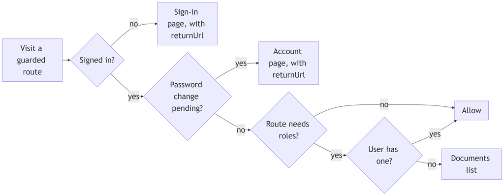

*Figure 23.1 — The route guard decision flow (`authGuard`, then `roleGuard`)*

In the diagram, "password change pending" stands for the guard's exact test: a change is required and the visit is not already to the account page, so the account page itself always opens. The first two questions belong to `authGuard`, which every guarded route uses. `roleGuard` runs `authGuard` first and adds the last two questions. Every "redirect" leaves the reader somewhere that makes sense, and none of the boxes says "deny with an error": the guard's job is to steer, and the server does the refusing (Section 23.4).

Figure 23.2 follows one signed-out visit from start to finish, including the round trip of `returnUrl`.

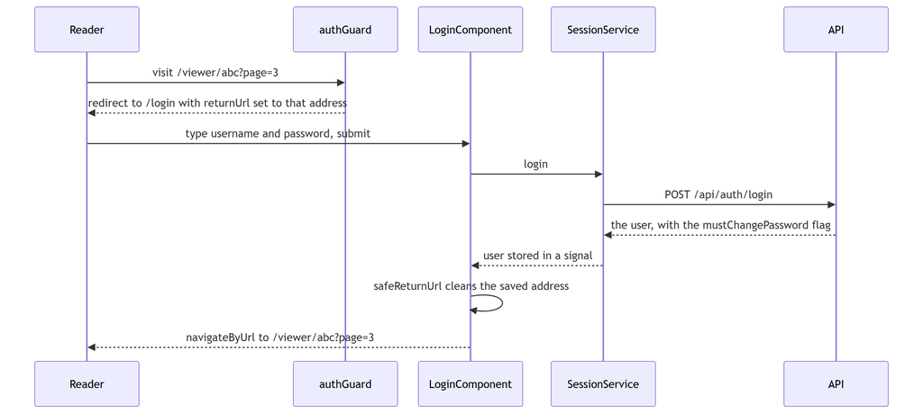

*Figure 23.2 — A signed-out visit to a deep link, and the return trip after sign-in*

*Text description:* A sequence diagram with five participants: the reader, the auth guard, the login component, the session service, and the API. A signed-out reader visits a deep link and the guard redirects to the sign-in page with the address saved. The reader submits the form, the session service posts to the API and stores the returned user, and the login component cleans the saved address and navigates to it. Notice that the address travels in the sign-in address and back, with nothing stored in the browser.

Notice that the reader ends on the page they originally asked for, with `?page=3` intact, without the frontend having stored anything: the address traveled inside the sign-in address and came back. If `mustChangePassword` were true, the login component would send the reader to the account page first, carrying the same `returnUrl` (Section 23.15).

### 23.7 Forms and client-side validation (and why it's not security)

A **form** collects typed input. The project uses Angular's template-driven forms: importing `FormsModule` lets you tie an input to a class field with `[(ngModel)]`, which keeps them in sync in both directions.

```html
  <form (ngSubmit)="submit()">
    <label for="username">Username</label>
    <input
      id="username"
      name="username"
      type="text"
      [(ngModel)]="username"
      autocomplete="username"
      autocapitalize="none"
      spellcheck="false"
      required
    />
        <button type="submit" [disabled]="submitting() || !username.trim() || !password">
      {{ submitting() ? 'Signing in…' : 'Sign in' }}
    </button>
  </form>
```

*Path: `frontend/src/app/features/auth/login.component.html`*

(Simplified: the password field, which is the same shape with `type="password"` and `autocomplete="current-password"`, and the error paragraph are omitted.)

- `(ngSubmit)="submit()"` runs the method when the form is submitted, whether by button or by pressing Enter.
- `<label for="username">` is tied to the input whose `id` is `username`. Clicking the label focuses the input, and screen readers announce the label when the input gets focus (Chapter 21, accessibility).
- `[(ngModel)]="username"` reads and writes the class field `username`. The square-bracket-and-parentheses "banana in a box" form means: the value flows from the class into the input, and each keystroke flows back. `name` is required by `ngModel` inside a form.
- `autocomplete="username"` lets password managers recognize the field; `autocapitalize="none"` and `spellcheck="false"` stop phones from "correcting" a username.
- `required` marks the field as mandatory for the browser's own validation.
- `[disabled]="..."` disables the button while a request is in flight or a field is empty, preventing double submissions.

The class behind it is short:

**Listing 23.4 — `login.component.ts` (book-m6-final, excerpt: method `submit`)**

```typescript
  submit(): void {
    if (!this.username.trim() || !this.password) {
      return;
    }
    this.submitting.set(true);
    this.errorMessage.set(null);

    this.sessionService.login(this.username.trim(), this.password).subscribe({
      next: (user) => {
        this.password = '';
        const returnUrl = safeReturnUrl(this.route.snapshot.queryParamMap.get('returnUrl'));
        if (user.mustChangePassword) {
          this.router.navigate(['/account'], { queryParams: { required: 1, returnUrl } });
        } else {
          this.router.navigateByUrl(returnUrl);
        }
      },
      error: (err: HttpErrorResponse) => {
        this.submitting.set(false);
        this.password = '';
        this.errorMessage.set(loginErrorMessage(err));
      },
    });
  }
```

*Path: `frontend/src/app/features/auth/login.component.ts`*

The method is a small story. It refuses to send an empty form. It marks itself busy, clears any old error, and asks the session service (Chapter 22) to sign in. On success it wipes the password from memory (`this.password = ''`) and moves on, to the password-change screen if an administrator set the password, or otherwise to the saved `returnUrl`. On failure it also wipes the password, so a mistyped one isn't left sitting in the field, and shows a message. Note that success and failure both clear the password: a small habit that reduces what could be shoulder-surfed or inspected.

How the message is chosen is a small function of its own:

**Listing 23.5 — `login.component.ts` (book-m6-final, excerpt: `loginErrorMessage`)**

```typescript
function loginErrorMessage(err: HttpErrorResponse): string {
  if (err.status === 429) {
    const minutes = Math.max(1, Math.ceil(Number(err.headers.get('Retry-After') ?? 60) / 60));
    return `Too many failed attempts. Try again in about ${minutes} minute${minutes === 1 ? '' : 's'}.`;
  }
  if (err.status === 401) {
    return 'Incorrect username or password.';
  }
  return 'Sign-in failed. Please try again.';
}
```

*Path: `frontend/src/app/features/auth/login.component.ts`*

A 429 here is the sign-in throttle from Chapter 16: too many wrong passwords. The response's `Retry-After` header gives seconds; the function turns them into whole minutes, at least one (`Math.max(1, Math.ceil(x / 60))`), and handles the singular ("1 minute") and plural. `?? 60` means "if the header is missing, assume 60 seconds." A 401 means wrong credentials; anything else gets a generic sentence. The message never says *which* of username or password was wrong, so the screen doesn't help someone guess which usernames exist.

### 23.8 Cleaning `returnUrl`: what it protects, and what it doesn't

The saved address travels in a query parameter, and that parameter is controlled by whoever built the link. Anyone can send a reader a link such as `/login?returnUrl=//evil.example/fake`. What could such a value do?

The classic attack is an **open redirect**: a site that, after sign-in, sends the browser to whatever address the link names, so a genuine sign-in page can be used to send a victim on to a lookalike site. That attack needs code that hands the raw string to the browser itself, for example by assigning it to `window.location` or using it as a link's address.

This project's code doesn't do that. After signing in, the login component calls Angular's `router.navigateByUrl(returnUrl)` (Listing 23.4), and that method treats the string as an address *inside the application*, not as a web address. This was checked against Angular 22.1.7's own URL parser in a scratch project: `//evil.example/fake` is read as two path segments, `evil.example` and `fake`; `https://evil.example` becomes the single segment `https:`; and `javascript:alert(1)` becomes one segment `javascript:alert`. None of them leaves the site. With no matching route, the router falls through to the catch-all route, which shows the document list. So a crafted `returnUrl` cannot, through `navigateByUrl`, send the reader to another site, and the code as written has no path by which it could.

Why then is there a check? The function's own comment states the intent: "Only ever navigate within the app." It is **defense in depth**, a second barrier in case the first one changes. It keeps `returnUrl` a plain in-app path (starting with a single `/`) so that:

- a strange value lands on the intended default, `/documents`, instead of being interpreted as an odd route;
- the value is safe to reuse if a later change ever hands it to something that *would* trust it, such as a full-page redirect or a link; and
- the same value passes through the account screen and back with the same guarantee.

This is a useful habit, but be honest about its size: it is a cheap guard on a path that was already contained, not the fix for an exploit that existed.

The defense is small:

**Listing 23.6 — `login.component.ts` (book-m6-final, excerpt: `safeReturnUrl`)**

```typescript
/** Only ever navigate within the app — a crafted ?returnUrl=//evil.example must not redirect off-site. */
function safeReturnUrl(returnUrl: string | null): string {
  return returnUrl && returnUrl.startsWith('/') && !returnUrl.startsWith('//') ? returnUrl : '/documents';
}
```

*Path: `frontend/src/app/features/auth/login.component.ts`*

Read the condition as three questions, all of which must be yes: is there a value (`returnUrl &&`)? Does it start with a single `/` (an address inside this site)? And does it *not* start with `//`? A browser treats a leading `//` as "same scheme, different host," so a value like `//evil.example` is exactly what you would refuse to hand to a browser-level redirect. Angular's router, as tested earlier in this section, would not follow it off-site anyway. If any answer is no, the function returns the safe default, `/documents`. Table 23.2 runs it on some inputs:

Table 23.2 — `safeReturnUrl` on sample inputs

| `returnUrl` value | Result | Why |
| --- | --- | --- |
| `null` (no parameter) | `/documents` | Nothing to follow |
| `/viewer/abc?page=3` | `/viewer/abc?page=3` | Inside the app |
| `//evil.example` | `/documents` | Starts with `//` |
| `https://evil.example` | `/documents` | Doesn't start with `/` |
| `viewer/abc` | `/documents` | Not an absolute path; refused to be safe |

This function has existed since the first frontend milestone (`book-m1-accounts`); it was written with the guard's `returnUrl` design, not added after an incident. The account screen (`account.component.ts`) applies the same rule to its own `returnUrl`. It is duplicated there rather than shared, which is a small piece of technical debt a maintainer might tidy.

### 23.9 Client-side validation is not security

`required`, the 12-character minimum on the password form (`account.component.ts`), and the PDF-only and 50 MB checks in `upload.component.ts` are for the reader's benefit: fast feedback without a round trip. **None of it is security**, because anyone can bypass the browser and send requests directly. The upload component says so in its comment: the size constant "mirrors the server limit ... the server still enforces it." Chapter 13 covered the server-side validation that does the real work.

Why keep the client checks at all? Two reasons. Speed: telling someone their 60 MB file is too large before uploading it saves a long, useless upload. Kindness: an inline sentence next to a field is clearer than a generic error from the server. The rule of thumb is *validate twice, trust once*: check in the browser for the user, check on the server for the system, and only the second counts.

> **Note:** The viewer's page-number form uses `novalidate` on purpose: the component's `goToPage` method does all validation, so every bad value (blank, decimal, out of range) produces the same inline message, "Enter a whole number from 1 to N."

### 23.10 Why template-driven forms and not reactive forms

Angular has two form styles. **Template-driven** forms, used here, put the setup in the template (`ngModel`) and suit small forms with a handful of fields. **Reactive** forms describe the form as objects in the class (form groups and controls with validators), which is more code up front and better for large or dynamic forms, complex cross-field rules, or heavy testing of form logic. The project's forms are small (sign in, change password, upload, share, a page number), and their validation is a few lines of plain code, so the lighter style wins. If a form grew to dozens of fields with interdependent rules, switching to reactive forms would be the natural step.

## Advanced tier: Deep links, resuming, and keyboard

*On a first read you can skip to "In this project"; Part IV comes back to this.*

### 23.11 Deep links and query parameters (page numbers)

A **deep link** is an address that leads straight to a specific state, for example the viewer at page 3 of a document. Query parameters make it possible: `/viewer/<id>?page=3`. At `book-m4-reading` the viewer gained this (commit "Phase 4a: page deep links, keyboard navigation, resume reading"). The rule, from the comment on `initialPage`: `?page=N` (1-based) wins; otherwise resume where this user left off; otherwise page 1.

**Listing 23.7 — `viewer.component.ts` (book-m6-final, excerpt: `initialPage` and `rememberPage`)**

```typescript
  private initialPage(pageCount: number): number {
    const requested = Number(this.route.snapshot.queryParamMap.get('page'));
    if (Number.isInteger(requested) && requested >= 1 && requested <= pageCount) {
      return requested - 1;
    }
    try {
      const saved = Number(localStorage.getItem(this.lastPageKey()));
      return Number.isInteger(saved) && saved >= 0 && saved < pageCount ? saved : 0;
    } catch {
      return 0;
    }
  }

  /** Keeps the URL shareable (?page=N) and remembers the page for next time. */
  private rememberPage(page: number): void {
    void this.router.navigate([], {
      relativeTo: this.route,
      queryParams: { page: page + 1 },
      queryParamsHandling: 'merge',
      replaceUrl: true,
    });
    try {
      localStorage.setItem(this.lastPageKey(), String(page));
    } catch {
      // Storage unavailable (private mode, quota); resuming is just a convenience.
    }
  }
```

*Path: `frontend/src/app/features/viewer/viewer.component.ts`*

Notes on the details:

- The page in the URL is 1-based (people say "page 1"), while the code counts from 0, hence `requested - 1` and `page + 1`. Mixing these up is the classic off-by-one mistake; the project keeps the conversion at the edges (this pair of methods and `goToPage`) so that everywhere else the code counts from 0.
- The URL value is user-controlled input. `Number(...)` turns text into a number (`Number(null)` is 0, and `Number('abc')` is `NaN`, "not a number"), and the `Number.isInteger` check plus the range check reject everything that isn't a whole number in range. A bad value such as `?page=99` falls back to the remembered page, which a spec confirms (`viewer.component.spec.ts`).
- `router.navigate([], { relativeTo: this.route, queryParams: {...}, queryParamsHandling: 'merge', replaceUrl: true })` says: stay on this route (an empty path array), set `page`, keep any other query parameters (`merge`), and *replace* the current history entry instead of adding one. With `replaceUrl: true`, turning ten pages doesn't create ten Back-button steps; Back leaves the viewer.
- `localStorage` remembers the last page per user and document (key `sdv.lastPage.<username>.<documentId>`). The try/catch exists because browsers can disable storage; in that case the feature quietly doesn't work. It stores a page number, nothing sensitive. Keying by username means two people sharing one browser don't see each other's reading position.

### 23.12 The page-number form

The viewer also has a small form for jumping to a page. It is a form without `ngModel`: it reads the field straight from the DOM (the browser's live model of the page) when submitted.

**Listing 23.8 — `viewer.component.html` (book-m6-final, excerpt: the page-jump form)**

```html
            <form class="page-jump" novalidate (submit)="$event.preventDefault(); goToPage(pageInput.value)">
        <label for="page-input">Page</label>
        <input
          #pageInput
          id="page-input"
          type="number"
          inputmode="numeric"
          min="1"
          [max]="doc.pageCount"
          [value]="currentPage() + 1"
          [attr.aria-invalid]="pageInputError() ? true : null"
          aria-describedby="page-input-error"
        />
```

*Path: `frontend/src/app/features/viewer/viewer.component.html`*

(Excerpt: the closing of the form, the page count, and the Go button are omitted.) `#pageInput` gives the input a name inside the template, so `pageInput.value` can be read when the form is submitted. `$event.preventDefault()` stops the browser's default form submission, which would reload the page. `inputmode="numeric"` asks phones for a number keypad. `[attr.aria-invalid]` sets an accessibility attribute only when there's an error (`null` removes it), and `aria-describedby` points to the error paragraph so screen readers read the message with the field. The `goToPage` method (in `viewer.component.ts`) checks the value is a whole number from 1 to the page count, and otherwise sets `pageInputError`, the same rule as for the URL.

### 23.13 Keyboard navigation

Readers expect arrows and Page Down to turn pages. The viewer listens for keys on the whole document:

**Listing 23.9 — `viewer.component.ts` (book-m6-final, excerpt: `onKeydown`)**

```typescript
  @HostListener('document:keydown', ['$event'])
  onKeydown(event: KeyboardEvent): void {
    const target = event.target as HTMLElement | null;
    if (event.ctrlKey || event.metaKey || event.altKey || !this.manifest() || this.accessLost()
        || (target && /^(INPUT|TEXTAREA|SELECT)$/.test(target.tagName)) || target?.isContentEditable) {
      return;
    }
    const last = this.manifest()!.pageCount - 1;
    const actions: Record<string, () => void> = {
      ArrowRight: () => this.nextPage(),
      PageDown: () => this.nextPage(),
      ArrowLeft: () => this.prevPage(),
      PageUp: () => this.prevPage(),
      Home: () => this.currentPage() !== 0 && this.loadPage(0),
      End: () => this.currentPage() !== last && this.loadPage(last),
      '+': () => this.zoomIn(),
      '=': () => this.zoomIn(),
      '-': () => this.zoomOut(),
    };
    const action = actions[event.key];
    if (action) {
      event.preventDefault();
      action();
    }
  }
```

*Path: `frontend/src/app/features/viewer/viewer.component.ts`*

`@HostListener('document:keydown', ['$event'])` attaches a listener for key presses anywhere on the page and passes it the event. The first `if` lists when to do nothing. It stops when Ctrl, Meta, or Alt is held (so browser shortcuts such as Ctrl+Plus still work). It stops while the page-number field or another text box has focus (so typing "12" doesn't turn pages). It stops when there is no document yet, or when access was lost. Otherwise the pressed key is looked up in a `Record` of actions (Chapter 19, Section 19.11). Unknown keys find nothing (`action` is `undefined`), so they fall through untouched; known ones call `preventDefault()` so the browser doesn't also scroll.

Every page turn goes through the same `loadPage` method as the Prev/Next buttons, which is a security point stated in the code: "there is no shortcut route to a page," so signed URLs, watermarking, and the rate limit apply identically. A keyboard user cannot get to a page any faster or less watched than a mouse user.

### 23.14 Swiping on a phone

*You can skip this section without losing the thread; it is a small geometry exercise.*

Touch users get the same via swipe. The two handlers are short:

**Listing 23.10 — `viewer.component.ts` (book-m6-final, excerpt: swipe handlers)**

```typescript
  onTouchStart(event: TouchEvent): void {
    const touch = event.touches[0];
    this.touchStart = event.touches.length === 1 && touch ? { x: touch.clientX, y: touch.clientY } : null;
  }

  /** Swipe left/right to turn pages; ignored when zoomed in, where a swipe pans instead. */
  onTouchEnd(event: TouchEvent): void {
    const start = this.touchStart;
    const touch = event.changedTouches[0];
    this.touchStart = null;
    if (!start || !touch || this.zoom() > 1) {
      return;
    }
    const dx = touch.clientX - start.x;
    const dy = touch.clientY - start.y;
    if (Math.abs(dx) >= SWIPE_MIN_PX && Math.abs(dx) > 2 * Math.abs(dy)) {
      if (dx < 0) {
        this.nextPage();
      } else {
        this.prevPage();
      }
    }
  }
```

*Path: `frontend/src/app/features/viewer/viewer.component.ts`*

On finger-down the handler remembers where the touch began, but only if exactly one finger is used (`event.touches.length === 1`), so a two-finger pinch is never mistaken for a swipe. On finger-up it computes `dx` and `dy`, the distances moved sideways and up or down. A page turn needs a horizontal movement of at least `SWIPE_MIN_PX` (50 pixels) that is also more than twice the vertical movement, so a diagonal scroll doesn't turn the page. Swiping left (negative `dx`) goes to the next page, like turning a paper page. When the page is zoomed in, swipes are ignored, because then a swipe pans across the enlarged page. Swipe and the mobile layout arrived at `book-m5-platform`, in the commit that made the viewer usable on phones.

### 23.15 The forced password change

One flow crosses most of this chapter and shows how the pieces cooperate. When an administrator creates an account or resets a password, the temporary password works only to reach the change-password screen. The server enforces this (Chapter 16); the frontend mirrors it in three places so that the experience is smooth instead of full of errors:

1. The sign-in response says `mustChangePassword: true`, and `login.component.ts` (Listing 23.4) navigates straight to `/account` with `required=1` and the saved `returnUrl`.
2. `authGuard` (Listing 23.2) sends that user back to `/account` from every other route, so typing an address by hand doesn't get around it.
3. If some request still reaches the server first, the server answers 403 with a marker, and the interceptor (Chapter 22, Listing 22.6) navigates to `/account` too.

Afterward, `changePassword` in `SessionService` sets `mustChangePassword` to false locally, and the account component moves the reader on to their `returnUrl`. This flow was added at `book-m5-platform`; the end-to-end test (Chapter 24) signs new users in this way. The design shows the pattern: the server refuses, and the frontend explains and redirects.

## Common mistakes

- **Treating a guard as a lock.** A guard that hides `/admin` doesn't protect any data. If an API endpoint lacks a server-side check, anyone can call it. Always ask "what does the server do if I skip the screen?"
- **Putting the catch-all route first.** `{ path: '**' }` matches everything, so routes listed after it are unreachable. The symptom: every address shows the documents list.
- **Forgetting `pathMatch: 'full'` on an empty-path redirect.** Without it the empty path matches as a prefix of every address.
- **Forgetting `name` on an `ngModel` input inside a form.** Angular reports an error at run time that the `name` attribute must be set. The fix is one attribute.
- **Off-by-one page numbers.** The URL says `?page=1` for the first page; the code's index is 0. Convert at the edges only.
- **Handing `returnUrl` to a browser-level redirect unchecked.** Angular's `navigateByUrl` keeps you inside the app, but `window.location` or a link would not. See Section 23.8.
- **Handling keys everywhere.** A document-wide key handler that doesn't check the event target steals keystrokes from text fields, and one that doesn't check modifier keys breaks Ctrl+F and Ctrl+Plus.
- **Trusting query parameters.** `?page=abc` yields `NaN`, which is not an integer; always check before using a value from the address.
- **Showing different errors for "no such user" and "wrong password."** It helps an attacker enumerate accounts. The login screen shows one message for both.

## In this project

| File | First appears | What it does |
| --- | --- | --- |
| `frontend/src/app/app.routes.ts` | `book-m1-accounts` (manage route at `book-m2-documents`) | URL to component map, lazy loading, guards |
| `frontend/src/app/core/auth.guard.ts` | `book-m1-accounts` (password-change redirect at `book-m5-platform`) | `authGuard`, `roleGuard` |
| `frontend/src/app/features/auth/login.component.*` | `book-m1-accounts` (idle notice at `book-m4-reading`, forced change at `book-m5-platform`) | Sign-in form, `safeReturnUrl`, error messages |
| `frontend/src/app/features/auth/account.component.ts` | `book-m1-accounts` | Change-password form |
| `frontend/src/app/features/viewer/viewer.component.ts` | `book-m1-accounts` (deep links and keys at `book-m4-reading`, swipe at `book-m5-platform`) | Page jump, deep links, keyboard, swipe |

See one with `git show book-m4-reading:frontend/src/app/features/viewer/viewer.component.ts`.

## Try it

### Exercise 23.1 ★ Who can reach what

Which routes require the `ADMIN` role? Which only require being signed in?

*Solution:* Appendix C, Exercise 23.1.

### Exercise 23.2 ★ The redirect address

What URL does a signed-out visitor to `/documents` get redirected to?

*Solution:* Appendix C, Exercise 23.2.

### Exercise 23.3 ★★ Deleting a guard

Explain why deleting `authGuard` from a route would not let a reader see a document they aren't allowed to see.

*Solution:* Appendix C, Exercise 23.3.

### Exercise 23.4 ★★ Add a route

Add a route `about` (lazy-loaded, no guard) for a scratch component that shows a paragraph. Where in the list must it go?

*Solution:* Appendix C, Exercise 23.4.

### Exercise 23.5 ★★★ Keys and text fields

The viewer ignores key presses when the target is an input. Describe what would go wrong for someone typing a page number if it didn't.

*Solution:* Appendix C, Exercise 23.5.

### Exercise 23.6 ★★ Run `safeReturnUrl`

For each of these values, say what `safeReturnUrl` returns: `/documents/abc/manage`, `///x`, `javascript:alert(1)`, and the empty string.

*Solution:* Appendix C, Exercise 23.6.

## Summary

- The router maps URL paths to components and swaps them without reloading; lazy loading downloads a route's code on first visit, and routes match top to bottom.
- Route and query parameters arrive as text; validate them before use.
- Guards run before a route is entered and redirect when the reader isn't signed in or lacks the role; they are a courtesy, not a defense, because the browser is on the untrusted side of the trust boundary.
- Forms tie inputs to fields with `ngModel`; client-side checks give fast feedback but never replace server validation.
- `returnUrl` is cleaned as defense in depth: it must start with one slash and not two. Angular's `navigateByUrl` treats the string as an in-app address, so it could not leave the site anyway; the check keeps the value predictable and safe to reuse.
- `?page=N` is user input: keep it 1-based, validate it, fall back gracefully, and update it with `replaceUrl` so Back still works.
- Keyboard handling steps aside for modifier keys and text fields; swipe needs distance and direction; every route to a page passes through the same server-checked path.

Next, Chapter 24 shows how all of this is tested.

## Further reading

- Angular documentation, "Routing", "Route guards" and "Template-driven forms": https://angular.dev/
- OWASP, "Unvalidated Redirects and Forwards Cheat Sheet": https://cheatsheetseries.owasp.org/
- MDN Web Docs, "KeyboardEvent", "Touch events" and "Window: localStorage": https://developer.mozilla.org/

# Chapter 24: Testing the frontend

The frontend makes promises: a reader who wasn't given a document never sees it, a page turn asks for exactly one new page of tiles, every screen is readable in light and dark themes. Tests turn those promises into checks that run on every change. This chapter shows the two layers the project uses: fast unit tests with Vitest, and slow, realistic end-to-end tests with Playwright, including automated accessibility checks. It also shows how to read tests as documentation, because in this project the test names are the most honest list of what the frontend is supposed to do.

## Learning objectives

By the end of this chapter, you will be able to:

- Explain the difference between a unit test and an end-to-end test, and why the project has both.
- Read a Vitest spec, including its `describe`, `it` and `expect` structure.
- Write a new test for a pure function and run it.
- Test a component and a service without a real server using `HttpTestingController`.
- Show that something did *not* happen, using `expectNone`.
- Read the Playwright test and explain what the axe accessibility check verifies.
- Explain what CI runs on the frontend.

## Prerequisites

- Chapter 18: testing the backend (the idea of assertions, test isolation).
- Chapters 19–23: TypeScript, components, services, routing.

## Beginner tier: Two kinds of check

### 24.1 Why test at all

A program is a pile of promises, and you can't see a broken promise by looking at code. You see it when a reader is locked out, sees a blank page, or sees a page they shouldn't. **Testing** is the practice of writing small programs that check the main program's promises, so a broken one is caught by a machine within seconds of the change that broke it, rather than by a reader weeks later.

Think of a restaurant kitchen. A cook tastes each sauce before it leaves the kitchen: quick, cheap, done constantly, and it finds a badly seasoned sauce. That's a unit test. Before opening night, the staff also run a full dress rehearsal with real orders, real plates, and real waiters. It is slow and involves everyone, but it finds the problems that only appear when everything works together (the sauce is fine, but it's cold by the time it reaches the table). That's an **end-to-end test**.

**Where the analogy breaks down:** a cook tastes a sauce once, by judgment. A test is code: it runs identically every time, on every change, on machines nobody is watching. Its verdict is a plain pass or fail, and it can only check what somebody thought to write down.

The project has both layers, because each finds problems the other can't (Section 24.9). Figure 24.1 shows where each layer runs, in what job of the automated pipeline, and where the accessibility check fits.

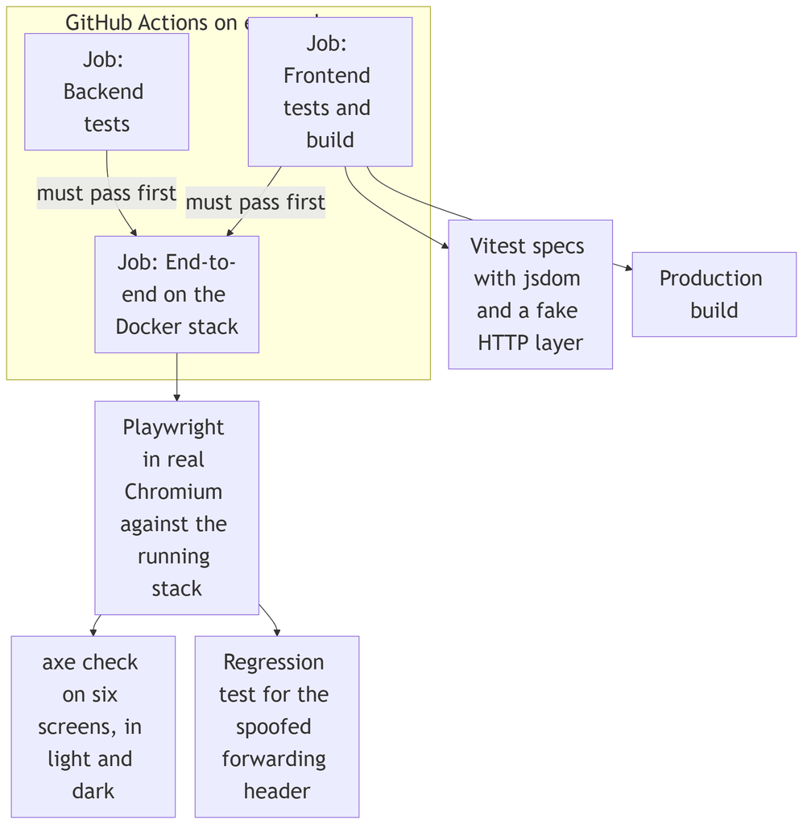

*Figure 24.1 — The frontend test layers and where the accessibility checks run*

*Text description:* A diagram drawn top to bottom with three jobs in a box for the automated pipeline: backend tests, frontend tests, and build, and end-to-end tests on the Docker stack. The frontend job runs the Vitest specs and the production build. Both the backend job and the frontend job must pass before the end-to-end job starts. The end-to-end job runs Playwright in a real browser, and that run includes the accessibility check on six screens in both themes and the regression test for the spoofed forwarding header.

The end-to-end job starts only after both the backend job and the frontend job have passed (`needs: [backend, frontend]` in `ci.yml`). The frontend job is fast and isolated; the end-to-end job is slow and realistic. The accessibility check is not a separate tool run on its own: it is a step inside the end-to-end test, so it looks at the pages exactly as the real stack serves them.

### 24.2 Unit tests with Vitest

A unit test runs a small piece of code in isolation and checks its result. **Vitest** is the test runner: it finds files ending in `.spec.ts` (a **spec** is a file of tests, short for specification), runs them, and reports which checks passed. It plays the role JUnit did for Java (Chapter 18). You run it with `npm test` (which is `ng test`, Chapter 20). The simplest specs in the project test a pure function, like the idle-timeout arithmetic from Chapter 19:

**Listing 24.1 — `idle.spec.ts` (book-m6-final)**

```typescript
import { idleState } from './idle';

describe('idleState', () => {
  const t0 = 1_000_000;

  it('is active well before the timeout', () => {
    expect(idleState(t0 + 10 * 60_000, t0, 1800)).toEqual({ kind: 'active' });
  });

  it('warns in the last five minutes, counting down', () => {
    expect(idleState(t0 + 26 * 60_000, t0, 1800)).toEqual({ kind: 'warning', secondsLeft: 240 });
  });

  it('expires once the timeout has passed', () => {
    expect(idleState(t0 + 30 * 60_000, t0, 1800)).toEqual({ kind: 'expired' });
  });

  it('scales the warning window down for short timeouts', () => {
    expect(idleState(t0 + 30_000, t0, 120)).toEqual({ kind: 'active' });
    expect(idleState(t0 + 70_000, t0, 120)).toEqual({ kind: 'warning', secondsLeft: 50 });
  });
});
```

*Path: `frontend/src/app/core/idle.spec.ts`*

- `describe('idleState', () => { ... })` groups related tests under a name.
- `it('...', () => { ... })` is one test, named as a sentence about behavior. When it fails, the name tells you what broke.
- `expect(actual).toEqual(expected)` compares values, looking inside objects. If they differ, the test fails and shows both.
- `1_000_000` is a number written with underscores to make it readable. `60_000` is 60,000 milliseconds, one minute, so `t0 + 26 * 60_000` means "26 minutes after time zero."
- Notice `describe`, `it` and `expect` are never imported. `tsconfig.spec.json` (Chapter 20) loads `vitest/globals`, which makes them available everywhere in spec files.

Read the second test as arithmetic. The timeout is 1,800 seconds (30 minutes) and 26 minutes have passed, so 4 minutes, or 240 seconds, remain; that is inside the last five minutes, so the state is a warning with 240 seconds left. The last test shows a design detail. With a 120-second timeout, the warning window shrinks to half the timeout (60 seconds). At 30 seconds in, with 90 seconds left, the state is still `active`. At 70 seconds in, with 50 left, it is a warning.

Times are passed in as arguments rather than read from the clock, so the tests are instant and repeatable: this is why `idleState` was written as a pure function (Chapter 19). If it called `Date.now()` inside, the test would need to freeze or fake time, which is clumsier.

> **Note:** Vitest 5.0.1 and its browser simulator jsdom 30 are used at `book-m6-final`. Tags `book-m1-accounts` to `book-m5-platform` use Vitest 4.0.8 and jsdom 28. The specs quoted here read the same either way.

The **jsdom** package is a pretend browser written in JavaScript, so component specs can create elements and read `localStorage` without opening a real browser.

**Running the specs.** In a terminal, `npm test` starts in *watch mode*: it runs the specs once, then keeps running and runs them again whenever you save a file. Angular's test builder turns watch mode on when a terminal is attached and off otherwise (its schema says "Defaults to `true` in TTY (interactive terminal) environments and `false` otherwise"). That can look like a hang if you expect the command to finish. Press Ctrl+C to stop it. For a single run that exits, as in CI and in this chapter's exercises, use `npx ng test --watch=false`. No browser is needed for either: the specs run in Node with jsdom.

### 24.3 Worked example: adding a test

The best way to learn a test framework is to add a test. Suppose you want to pin down the exact moment the warning starts, the *boundary*, because boundaries are where bugs live. Reading `idleState` (Chapter 19, Listing 19.3): with a 1,800-second timeout, the warning window is `Math.min(300, 1800 / 2)`, which is 300. The state is a warning when `secondsLeft <= 300`. So exactly 1,500 seconds after activity, 300 seconds remain and the state should be a warning; one second earlier, 301 remain and it should be active.

Add these to the `describe` block in `idle.spec.ts`:

**Example 24.1 — Two boundary tests for `idleState` (teaching example, not repository code)**

```typescript
  it('starts warning exactly when five minutes remain', () => {
    expect(idleState(t0 + 1_500_000, t0, 1800)).toEqual({ kind: 'warning', secondsLeft: 300 });
  });

  it('is still active one second earlier', () => {
    expect(idleState(t0 + 1_499_000, t0, 1800)).toEqual({ kind: 'active' });
  });
```

Run the specs from `frontend/` (Section 24.2 explains watch mode; `npx ng test --watch=false` runs once and exits). Both should pass. Now try the experiment that makes tests worth having: change `<=` to `<` in `idle.ts` (in a scratch copy) and run again. The first new test fails, and the output shows the expected `warning` and the received `active`. The test noticed a one-character change that no reader would have spotted for weeks. Put the character back.

Three habits are visible in this small example: name the test after the behavior, test the edges of a rule and not only the middle, and make a test *fail* at least once to prove it can.

### 24.4 Testing components and services

Components and services need Angular around them. Angular's **TestBed** builds a small test-only application: you tell it which providers to use (the services and settings, Chapter 22), ask it for objects, and it wires dependencies as in the real app. The trick for HTTP is to swap the real network for a fake: `provideHttpClientTesting()` replaces it, and `HttpTestingController` lets the test say exactly which request it expects and what answer to give.

**Listing 24.2 — `auth.guard.spec.ts` (book-m6-final, excerpt)**

```typescript
describe('route guards', () => {
  beforeEach(() => {
    TestBed.configureTestingModule({ providers: [provideRouter([]), provideHttpClient(), provideHttpClientTesting()] });
  });

  function signIn(role: 'READER' | 'ADMIN', mustChangePassword: boolean): void {
    TestBed.inject(SessionService).login('someone', 'pw').subscribe();
    TestBed.inject(HttpTestingController).expectOne('/api/auth/login')
      .flush({ username: 'someone', role, sessionTimeoutSeconds: 1800, mustChangePassword });
  }
  // ... helpers `run` and `path` omitted

  it('sends signed-out users to login with a return URL', () => {
    expect(path(run(authGuard, '/viewer/abc?page=3'))).toBe('/login?returnUrl=%2Fviewer%2Fabc%3Fpage%3D3');
  });

  it('keeps readers out of admin screens', () => {
    signIn('READER', false);
    expect(path(run(roleGuard('ADMIN'), '/admin'))).toBe('/documents');
    expect(run(authGuard, '/documents')).toBe(true);
  });
});
```

*Path: `frontend/src/app/core/auth.guard.spec.ts`*

(Excerpt: the second test in the file, about a password that an administrator set, is omitted, as are the two helper functions.)

- `beforeEach` runs before every test, giving each a fresh setup so tests can't affect each other. This is **test isolation**: the outcome of one test must never depend on another having run.
- `provideRouter([])` gives the guards a router with no routes, which is enough to build redirect addresses. `provideHttpClient()` plus `provideHttpClientTesting()` provides an HTTP client that never touches a network.
- `TestBed.inject(SessionService)` retrieves the real service, wired to the fake HTTP layer.
- `.login('someone', 'pw').subscribe()` starts the request (nothing is sent until someone subscribes, Chapter 22).
- `expectOne('/api/auth/login')` asserts that exactly one request to that address was made, and `.flush({...})` answers it with the given JSON, as if the server had replied. The test never opens a network connection.
- The signed-in state is created by *performing a real sign-in against the fake*, not by poking the service's internals, so the test exercises the same path the app uses.

The helper functions the excerpt omits deserve a sentence. `run` calls a guard inside `TestBed.runInInjectionContext`, because guards use `inject(...)` and that only works inside an injection context (Chapter 22). `path` turns a redirect object into its text form, so tests can compare plain strings.

Figure 24.2 shows what happens when a test uses the fake HTTP layer. The service believes it is talking to a server; the controller is listening instead.

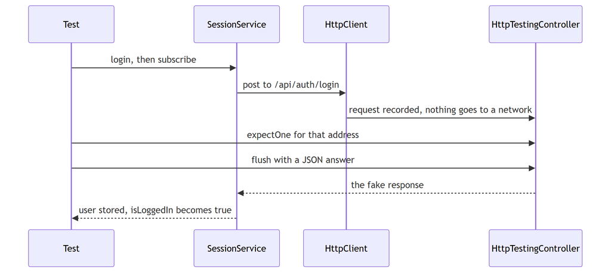

*Figure 24.2 — Testing a service with `HttpTestingController`*

*Text description:* A sequence diagram with four participants: the test, the session service, HttpClient, and the HttpTestingController. The test calls login and subscribes. The service posts through HttpClient, and the request is recorded by the controller instead of going to a network. The test then tells the controller which request it expects and supplies a fake JSON answer. The controller delivers that answer to the service, which stores the user, and the test checks that the reader is signed in.

The point to notice is that the test sits on both sides: it starts the request through the service and then plays the server through the controller. The service code under test is the same code that runs in the browser.

### 24.5 Testing a big component: the viewer

The viewer is the biggest component, and its spec needs a setup helper, `create`, used by every test:

**Listing 24.3 — `viewer.component.spec.ts` (book-m6-final, excerpt: the fixture and `create`)**

```typescript
const DOC: DocumentDetail = {
  documentId: 'doc-1',
  title: 'Doc',
  pageCount: 5,
  owner: 'owner',
  visibility: 'EVERYONE',
  createdAtEpochSeconds: 0,
  updatedAtEpochSeconds: 0,
  canManage: false,
  sharedWith: null,
  pages: Array.from({ length: 5 }, (_, page) => ({
    page, rows: 1, cols: 1, tileSize: 256, pageWidthPx: 200, pageHeightPx: 200,
  })),
  tileVersion: 1,
};

describe('ViewerComponent navigation', () => {
  let http: HttpTestingController;

  function create(queryParams: Record<string, string> = {}): ViewerComponent {
    TestBed.configureTestingModule({
      imports: [ViewerComponent],
      providers: [
        provideRouter([]),
        provideHttpClient(),
        provideHttpClientTesting(),
        {
          provide: ActivatedRoute,
          useValue: {
            snapshot: {
              paramMap: convertToParamMap({ documentId: 'doc-1' }),
              queryParamMap: convertToParamMap(queryParams),
            },
          },
        },
      ],
    });
    http = TestBed.inject(HttpTestingController);
    const component = TestBed.createComponent(ViewerComponent).componentInstance;
    component.ngOnInit();
    http.expectOne('/api/documents/doc-1').flush(DOC);
    return component;
  }
```

*Path: `frontend/src/app/features/viewer/viewer.component.spec.ts`*

Several ideas at once:

- `DOC` is a **fixture**: a realistic sample of the data the API would return, typed with the same `DocumentDetail` interface the app uses (Chapter 19). Because it's typed, the compiler checks that the fixture matches the interface; if the API's shape changes and the interface is updated, this fixture stops compiling, which alerts the developer to update it. That is a benefit of types: the test data can't quietly drift. (The type is still a promise about the real server, Chapter 19, Section 19.9.)
- `Array.from({ length: 5 }, (_, page) => ({...}))` builds five page descriptions. The underscore names an argument the code doesn't use.
- The provider `{ provide: ActivatedRoute, useValue: {...} }` replaces the real route information with a hand-made object: "the address is `.../doc-1`, and the query parameters are these." It is a **stub**, a stand-in with only enough behavior. The viewer only reads `snapshot.paramMap` and `snapshot.queryParamMap`, so that is all the stub provides. This is how a test controls "what if the address says `?page=3`?" without a browser.
- `component.ngOnInit()` is called by hand (Chapter 21 lifecycle hooks) so the test decides exactly when the viewer starts loading, and the `expectOne` right after it proves that it asked for the document, and `flush(DOC)` supplies the answer.

With that in place, the individual tests are short, as the keyboard test shows:

**Listing 24.4 — `viewer.component.spec.ts` (book-m6-final, excerpt: keyboard navigation)**

```typescript
  it('turns pages with the arrow keys and jumps with Home/End', () => {
    const viewer = create();
    expectGridRequestFor(0);

    viewer.onKeydown(new KeyboardEvent('keydown', { key: 'ArrowRight' }));
    expect(viewer.currentPage()).toBe(1);
    expectGridRequestFor(1);

    viewer.onKeydown(new KeyboardEvent('keydown', { key: 'End' }));
    expect(viewer.currentPage()).toBe(4);
    expectGridRequestFor(4);
    // ... Home key check omitted
  });
```

*Path: `frontend/src/app/features/viewer/viewer.component.spec.ts`*

The helper `expectGridRequestFor(page)` asserts that the viewer asked the API for that page's signed tile URLs. The test proves two things at once: the keyboard moves the page number, and each page turn triggers exactly one new request. The spec builds a `KeyboardEvent` by hand and hands it to the component's method, the same method the real `@HostListener` (Chapter 23) calls.

## Intermediate tier: What each spec protects

*On a first read you can skip to "In this project"; Part IV comes back to this.*

### 24.6 Specs as executable requirements

Read the test *names* in the project and you get a list of promises. Seven of them are about the viewer:

- "opens the page named in ?page= (1-based)"
- "ignores an out-of-range ?page= and resumes the last page read instead"
- "leaves keys alone while typing in a field or with modifiers held"
- "turns pages with a horizontal swipe, but not when zoomed in"
- "notices a replaced document from its tile URLs and reloads it with a notice"
- "stops instead of reloading forever when tiles are gone but the document has not changed"
- "shows the access-lost state when the document stops being available mid-read"

Each corresponds to a behavior from Chapters 22 and 23. The other specs cover other screens. The document list's filter and access labels are tested. So is the manage screen asking for confirmation before removing someone's access. The upload component's refusal of non-PDFs and oversized files before anything is uploaded is tested, and so is the admin screen's polling rule.

A useful discipline follows from this: **name tests as sentences about behavior**, not about methods. "opens the page named in ?page=" tells a future maintainer what must stay true, even if the method that does it is renamed. A test called `testInitialPage` tells them nothing when it fails.

### 24.7 Proving that nothing happened

Some of the most important behaviors are *non-events*: a request that must not be sent. The manage screen asks for a second click before removing someone's access, because removal takes effect immediately, even for pages already open (Chapter 22). The spec proves that the first click sends nothing:

**Listing 24.5 — `manage-upload.component.spec.ts` (book-m6-final, excerpt: the unshare test)**

```typescript
describe('ManageDocumentComponent sharing', () => {
  it('asks before removing someone, and only then calls the server', () => {
    TestBed.configureTestingModule({
      imports: [ManageDocumentComponent],
      providers: [
        provideRouter([]), provideHttpClient(), provideHttpClientTesting(),
        {
          provide: ActivatedRoute,
          useValue: { snapshot: { paramMap: convertToParamMap({ documentId: 'doc-1' }), queryParamMap: convertToParamMap({}) } },
        },
      ],
    });
    const http = TestBed.inject(HttpTestingController);
    const manage = TestBed.createComponent(ManageDocumentComponent).componentInstance;
    manage.ngOnInit();
    http.expectOne('/api/documents/doc-1').flush(DOC);

    manage.unshare('reader');
    expect(manage.confirmingUnshare()).toBe('reader');
    http.expectNone((req) => req.method === 'DELETE');

    manage.unshare('reader');
    http.expectOne((req) => req.method === 'DELETE' && req.url.endsWith('/doc-1/shares/reader')).flush([]);
    expect(manage.document()?.sharedWith).toEqual([]);
  });
});
```

*Path: `frontend/src/app/features/documents/manage-upload.component.spec.ts`*

Follow the middle of the test. The first `unshare('reader')` should only set the "confirming" state; `expectNone(...)` asserts that no request matching the function was made (here: any `DELETE`). The second `unshare('reader')` is the confirmation, and now `expectOne` finds exactly one `DELETE` to `.../doc-1/shares/reader`, which the test answers with an empty list; the last line checks the component updated its own copy of who has access. Notice that `expectOne` and `expectNone` can take a function instead of a string, to match on method or address flexibly.

### 24.8 Testing a form's checks without a browser

The upload component checks a chosen file before uploading anything. To test it, the spec must fake a file being picked, which is a good look at how tests bend the platform:

**Listing 24.6 — `manage-upload.component.spec.ts` (book-m6-final, excerpt: file checks)**

```typescript
describe('UploadComponent file checks', () => {
  function pick(upload: UploadComponent, file: File): void {
    const input = document.createElement('input');
    Object.defineProperty(input, 'files', { value: [file] });
    upload.onFileSelected({ target: input } as unknown as Event);
  }

  function create(): UploadComponent {
    TestBed.configureTestingModule({
      imports: [UploadComponent],
      providers: [provideRouter([]), provideHttpClient(), provideHttpClientTesting()],
    });
    return TestBed.createComponent(UploadComponent).componentInstance;
  }

  it('refuses a file that is not a PDF before uploading anything', () => {
    const upload = create();
    pick(upload, new File(['hello'], 'notes.txt', { type: 'text/plain' }));
    expect(upload.errorMessage()).toBe('Please choose a PDF file.');
  });

  it('refuses a PDF over the size limit and says how big it was', () => {
    const upload = create();
    const big = new File(['x'], 'big.pdf', { type: 'application/pdf' });
    Object.defineProperty(big, 'size', { value: 60 * 1024 * 1024 });
    pick(upload, big);
    expect(upload.errorMessage()).toBe('That file is 60.0 MB; the limit is 50 MB.');
  });
```

*Path: `frontend/src/app/features/documents/manage-upload.component.spec.ts`*

These tests protect the *convenience* checks from Chapter 23. They do not, and cannot, prove the server refuses oversized uploads; that is a backend test (Chapter 18).

### 24.9 What unit tests can't catch

Not everything is testable at unit level. The specs in Listings 24.1 to 24.6 run with a fake network and a pretend browser. The viewer's real `fetch()` calls, the actual signed URLs, the nginx proxy, the cookies, and the real backend are absent. A bug in how nginx forwards a header, or in a real cookie's attributes, is invisible to them. That is what the second layer is for. It is slower, needs a running stack, and fails for more reasons (a network hiccup, a slow machine), so the project keeps it to a few carefully chosen journeys and relies on the unit layer for detail.

### 24.10 End-to-end tests with Playwright

**Playwright** drives a real browser (Chromium) against a real running stack: it clicks, types, and reads what the page shows, as a person would. The configuration says where the stack lives:

**Listing 24.7 — `playwright.config.ts` (book-m6-final)**

```typescript
export default defineConfig({
  testDir: './e2e',
  timeout: 120_000,
  retries: process.env['CI'] ? 1 : 0,
  reporter: process.env['CI'] ? [['list'], ['html', { open: 'never' }]] : 'list',
  use: {
    baseURL: process.env['E2E_BASE_URL'] ?? 'http://localhost:8081',
    trace: 'retain-on-failure',
  },
  projects: [{ name: 'chromium', use: { ...devices['Desktop Chrome'] } }],
});
```

*Path: `frontend/playwright.config.ts`*

(Excerpt: the file's leading comment and import are omitted.) The comment in the file says the tests need a running full stack (`docker compose --profile full up -d --build`, served at port 8081, Chapter 10) and an admin account supplied through `E2E_ADMIN_USER` and `E2E_ADMIN_PASSWORD` environment variables. Never write a password into a file; the test reads it from the environment and skips itself if it's missing. Line by line: `timeout: 120_000` allows a test two minutes, because uploading and rendering a PDF takes time. `retries` allows one automatic retry only in CI (locally you want failures to show at once). The reporter prints a plain list, and in CI also writes an HTML report. `baseURL` lets tests write `page.goto('/login')` instead of a full address, and can be overridden with `E2E_BASE_URL`. `trace: 'retain-on-failure'` saves a recording of a failed run, screenshots and network calls included, so a failure in CI can be replayed on your machine.

**Running the end-to-end tests yourself.** You need the full stack running, a browser for Playwright to drive, and the administrator password. Follow these steps once, and repeat the last step whenever you want to run the suite.

*Step 1.* From the repository root, start the stack: `docker compose --profile full up -d --build`. The web app is then at `http://localhost:8081`, which is where the tests look by default (the `E2E_BASE_URL` variable overrides it).

*Step 2.* Make sure you know a working administrator password. On an empty database the first start creates an `admin` account, and how its password was chosen matters. If you set `BOOTSTRAP_ADMIN_PASSWORD` in your own `.env` file before that first start, that password works as it is. If you left it empty, the app generates a random password, prints it once in the startup log (`docker compose logs app`), and marks the account as *must change password*. The suite signs in as `admin` and expects to land on the document list, but an account with that flag is sent to the account page (Chapter 23, Section 23.15), so the run fails there.

The simplest way is to set `BOOTSTRAP_ADMIN_PASSWORD=<your-admin-password>` in `.env` before you start a stack for the first time, which is what the project's own CI does with a throwaway value. If the stack has already started with a generated password, sign in once in the browser at `http://localhost:8081`, choose your own password on the account page, and use that new password as `E2E_ADMIN_PASSWORD`. (On a throwaway stack you can also delete its data with `docker compose down -v` and start again with the variable set.) Treat the password as a secret: type it into your terminal, and never put it in a file you commit.

*Step 3.* Install the dependencies and the browser Playwright drives. A first run without the browser download fails with an error saying the browser executable doesn't exist.

**Example 24.2 — Installing the test dependencies and the browser (teaching example, not repository code)**

```bash
cd frontend
npm ci
npx playwright install chromium
```

On Linux, Playwright may also need system libraries; the project's CI uses `npx playwright install --with-deps chromium` for that reason.

*Step 4.* Put the password in an environment variable for the current terminal session and run the suite. The variable name is what the spec reads; the value is yours.

**Example 24.3 — Running the suite on each platform (teaching example, not repository code)**

```bash
E2E_ADMIN_PASSWORD='<your-admin-password>' npm run e2e
```

```powershell
$env:E2E_ADMIN_PASSWORD = '<your-admin-password>'
npm run e2e
```

```
set E2E_ADMIN_PASSWORD=<your-admin-password>
npm run e2e
```

The first block is for bash (macOS, Linux, and Git Bash on Windows), the second for PowerShell, and the third for the Windows Command Prompt. `E2E_ADMIN_USER` defaults to `admin`. Without `E2E_ADMIN_PASSWORD` the main test skips itself. The suite creates accounts, so run it only against a stack you can throw away.

The main test, `e2e/secure-viewing.spec.ts`, tells one story in five steps:

1. An administrator creates three users: a publisher, a reader, and an outsider.
2. The publisher signs in for the first time with a temporary password and is forced to change it (the flow from Chapter 23).
3. The publisher uploads a two-page PDF that the test generates, and shares it with the reader.
4. The reader sees every tile load and turns the page with the keyboard (the URL changes to `?page=2`).
5. The outsider can neither see the document in their list nor open it by address, and gets "hasn't been shared with you."

Playwright's own helpers make each step readable, for example `page.fill('#username', username)` and `page.click('button[type=submit]')`. Every username is unique per run (`e2e-pub-<time>`), and an `afterAll` disables the created accounts, with a warning in the source: never point this suite at production, since it creates accounts.

One story with several actors, rather than many small tests, is a deliberate economy: the setup (three users, a PDF) is the expensive part, so the test reuses it for several assertions. The cost is that a failure early in the story hides everything after it; the trace helps.

### 24.11 Why Playwright and not the alternatives

The obvious alternatives are other browser-automation tools, such as Cypress or Selenium, and the simpler alternative of testing only with unit tests. The project uses Playwright with a `@axe-core/playwright` add-on. It records no comparison with other tools, so what follows are features its tests rely on, not recorded reasons. Playwright can run several independent browser contexts in one test (the administrator, publisher, reader, and outsider each have their own cookies, `browser.newContext()`). It can emulate the reader's color scheme for the theme checks (Section 24.12). It can also make raw API requests with a browser's cookies for the header test (Section 24.13). Skipping the end-to-end layer would have left the proxy, the cookies, and the real tile pipeline untested by any automation.